# PCA Model

Janou Roubroeks

15-11-2020

## Xi analysis

While examining the effect of diagnosis on Xi methylation, the effects of cell type proportions and batches will be controlled for. As inflation of p-values was observed in a previous analysis, the model will now include principal components.

### Generation of principal components

These are the first 10 principal components:

|  | PC1 | PC2 | PC3 | PC4 | PC5 | PC6 | PC7 | PC8 | PC9 | PC10 |
| --- | --- | --- | --- | --- | --- | --- | --- | --- | --- | --- |
| Standard deviation | 0.9491219 | 0.6751222 | 0.6487814 | 0.6232306 | 0.6135439 | 0.6084281 | 0.5646046 | 0.5570909 | 0.5512593 | 0.5425068 |
| Proportion of Variance | 0.0475000 | 0.0240300 | 0.0221900 | 0.0204800 | 0.0198500 | 0.0195200 | 0.0168100 | 0.0163600 | 0.0160200 | 0.0155200 |
| Cumulative Proportion | 0.0475000 | 0.0715300 | 0.0937300 | 0.1142100 | 0.1340600 | 0.1535700 | 0.1703800 | 0.1867500 | 0.2027700 | 0.2182900 |

### Correlation of PCs to variables of interest

|  | est | pval |
| --- | --- | --- |
| PC1-Diagnosis | 0.1702694 | 0.0264257 |
| PC2-Diagnosis | 0.1604399 | 0.0366173 |
| PC3-Diagnosis | 0.0999871 | 0.1945252 |
| PC4-Diagnosis | -0.0781023 | 0.3113641 |
| PC5-Diagnosis | 0.2047614 | 0.0073951 |
| PC6-Diagnosis | -0.0833779 | 0.2797071 |
| PC7-Diagnosis | -0.0840451 | 0.2758636 |
| PC8-Diagnosis | -0.0205854 | 0.7898940 |
| PC9-Diagnosis | -0.2594800 | 0.0006332 |
| PC10-Diagnosis | 0.0647204 | 0.4017478 |

## ANOVA models

### Model 1 - 1PC

One PC is regressed out, and the ANOVA for diagnosis has been run. Tables of the top 1000 DMPs for diagnosis have been produced and saved separately.

#### Top DMPs

**ANOVA:**  
51 probes pass the epigenome-wide significance threshold of 2.4x10-7 *The top 50 diagnosis associated DMPs:*

| ProbeID | Position | F | p (F) | FDR.Anova | Difference | CI lower | CI upper | pCvM | FDR | Difference | CI lower | CI upper | pCvA | FDR | Difference | CI lower | CI upper | pMvA | FDR | UCSC Gene | UCSC Gene Group | UCSC Relation to CpG Island | Gene Closest TSS | Distance Closest TSS | GREAT Annotation 1 | GREAT Annotation 2 |
| --- | --- | --- | --- | --- | --- | --- | --- | --- | --- | --- | --- | --- | --- | --- | --- | --- | --- | --- | --- | --- | --- | --- | --- | --- | --- | --- |
| cg22822140 | chr X: 153046577 | 53.823 | 9.10e-19 | 8.78e-15 | -0.008 | -0.031 | 0.015 | 0.693 | 1 | -0.092 | -0.116 | -0.069 | 4.83e-14 | 4.66e-10 | -0.084 | -0.107 | -0.061 | 6.28e-14 | 2.02e-10 | SRPK3;SRPK3;SRPK3 | 1stExon;1stExon;1stExon | Island | SRPK3 | 122 | SRPK3 (122) | (NA) |
| cg12230162 | chr X: 153046482 | 46.573 | 8.44e-17 | 4.07e-13 | 0.005 | -0.021 | 0.030 | 0.907 | 1 | -0.087 | -0.113 | -0.062 | 4.36e-13 | 1.40e-09 | -0.092 | -0.117 | -0.067 | 6.27e-14 | 2.02e-10 | SRPK3;SRPK3;SRPK3;SRPK3;SRPK3;SRPK3 | 5'UTR;1stExon;1stExon;5'UTR;5'UTR;1stExon | Island | SRPK3 | 27 | SRPK3 (27) | (NA) |
| cg24496423 | chr X: 153046480 | 43.776 | 5.18e-16 | 1.67e-12 | 0.003 | -0.016 | 0.023 | 0.911 | 1 | -0.067 | -0.087 | -0.047 | 1.70e-12 | 4.11e-09 | -0.07 | -0.09 | -0.05 | 1.14e-13 | 2.74e-10 | SRPK3;SRPK3;SRPK3;SRPK3;SRPK3;SRPK3 | 5'UTR;1stExon;1stExon;5'UTR;5'UTR;1stExon | Island | SRPK3 | 25 | SRPK3 (25) | (NA) |
| cg13009143 | chr X: 100548223 | 39.121 | 1.16e-14 | 2.80e-11 | -0.016 | -0.023 | -0.009 | 4.95e-07 | 2.17e-04 | 0.009 | 0.002 | 0.016 | 0.005 | 0.117 | 0.025 | 0.018 | 0.032 | 5.61e-14 | 2.02e-10 | TAF7L | TSS200 | S_Shore | TAF7L | -164 | TAF7L (-165) | (NA) |
| cg16152676 | chr X: 10126878 | 33.515 | 5.79e-13 | 1.12e-09 | 0.041 | 0.027 | 0.056 | 9.48e-10 | 1.83e-06 | -0.004 | -0.019 | 0.011 | 0.802 | 1 | -0.045 | -0.06 | -0.031 | 2.28e-11 | 3.67e-08 | CLCN4 | 5'UTR | Island | CLCN4 | 550 | CLCN4 (1894) | MID1 (724930) |
| cg12468189 | chr X: 153046767 | 32.745 | 1.00e-12 | 1.62e-09 | -0.025 | -0.04 | -0.009 | 5.41e-04 | 0.027 | -0.053 | -0.068 | -0.037 | 4.13e-13 | 1.40e-09 | -0.028 | -0.043 | -0.013 | 6.05e-05 | 0.011 | SRPK3;SRPK3;SRPK3 | Body;Body;Body | Island | SRPK3 | 312 | SRPK3 (312) | (NA) |
| cg16529483 | chr X: 153046451 | 31.499 | 2.47e-12 | 3.41e-09 | -0.008 | -0.033 | 0.017 | 0.749 | 1 | -0.077 | -0.103 | -0.052 | 7.15e-11 | 1.15e-07 | -0.07 | -0.095 | -0.044 | 1.92e-09 | 2.05e-06 | SRPK3;SRPK3;SRPK3 | TSS200;TSS200;TSS200 | Island | SRPK3 | -4 | SRPK3 (-4) | (NA) |
| cg19280671 | chr X: 149013642 | 30.788 | 4.15e-12 | 5.00e-09 | 0.018 | 0.012 | 0.024 | 1.42e-10 | 6.86e-07 | 0.002 | -0.004 | 0.008 | 0.81 | 1 | -0.016 | -0.022 | -0.01 | 3.60e-09 | 3.47e-06 | MAGEA8;MAGEA8;MAGEA8 | Body;Body;Body |  | MAGEA8 | 596 | MAMLD1 (-517908) | MAGEA8 (3702) |
| cg03360001 | chr X: 53453272 | 29.792 | 8.61e-12 | 8.32e-09 | -0.009 | -0.015 | -0.003 | 0.001 | 0.051 | 0.010 | 0.004 | 0.016 | 2.19e-04 | 0.017 | 0.019 | 0.013 | 0.025 | 3.15e-12 | 6.08e-09 | RIBC1;RIBC1 | Body;Body | S_Shelf | RIBC1 | 3434 | SMC1A (-3655) | (NA) |
| cg09768654 | chr X: 153046386 | 29.664 | 9.47e-12 | 8.32e-09 | 0.011 | -0.012 | 0.034 | 0.514 | 1 | -0.059 | -0.082 | -0.036 | 3.76e-08 | 2.59e-05 | -0.07 | -0.092 | -0.047 | 5.79e-11 | 7.98e-08 | SRPK3;SRPK3;SRPK3 | TSS200;TSS200;TSS200 | Island | SRPK3 | -69 | SRPK3 (-69) | (NA) |
| cg24605338 | chr X: 17395856 | 29.661 | 9.49e-12 | 8.32e-09 | -0.037 | -0.048 | -0.025 | 3.43e-12 | 3.31e-08 | -0.019 | -0.030 | -0.007 | 5.02e-04 | 0.03 | 0.018 | 0.007 | 0.029 | 5.38e-04 | 0.052 | NHS | Body | S_Shore | NHS | 2314 | SCML1 (-359735) | NHS (2314) |
| cg19938385 | chr X: 107020894 | 29.456 | 1.10e-11 | 8.88e-09 | -0.047 | -0.066 | -0.029 | 2.24e-08 | 1.66e-05 | -0.056 | -0.075 | -0.037 | 8.83e-11 | 1.22e-07 | -0.009 | -0.027 | 0.01 | 0.496 | 1 |  |  | S_Shore | TSC22D3 | -1692 | TSC22D3 (-1878) | (NA) |
| cg17405188 | chr X: 73164102 | 28.101 | 3.02e-11 | 2.24e-08 | 0.009 | 0.004 | 0.015 | 2.58e-04 | 0.015 | 0.017 | 0.012 | 0.023 | 1.12e-11 | 2.16e-08 | 0.008 | 0.003 | 0.014 | 0.001 | 0.094 | LOC554203 | TSS200 | Island | JPX | -56 | ZCCHC13 (-359922) | CHIC1 (381119) |
| cg17003204 | chr X: 102861456 | 25.415 | 2.31e-10 | 1.59e-07 | -0.037 | -0.05 | -0.024 | 2.26e-10 | 7.25e-07 | -0.012 | -0.025 | 8.04e-04 | 0.072 | 0.547 | 0.025 | 0.013 | 0.038 | 1.38e-05 | 0.004 | TCEAL3;TCEAL3 | TSS1500;TSS1500 | N_Shore | TCEAL3 | -1377 | TCEAL3 (-1377) | (NA) |
| cg21252909 | chr X: 30326328 | 24.460 | 4.82e-10 | 3.10e-07 | 0.038 | 0.016 | 0.061 | 3.15e-04 | 0.018 | -0.029 | -0.052 | -0.005 | 0.011 | 0.189 | -0.067 | -0.09 | -0.044 | 2.21e-10 | 2.66e-07 | NR0B1 | 1stExon | N_Shore | NR0B1 | 1167 | NR0B1 (1166) | (NA) |
| cg16122592 | chr X: 26210712 | 23.264 | 1.22e-09 | 7.37e-07 | -0.031 | -0.043 | -0.020 | 3.49e-09 | 4.82e-06 | -0.025 | -0.037 | -0.014 | 1.68e-06 | 5.22e-04 | 0.006 | -0.006 | 0.017 | 0.466 | 1 | MAGEB6 | 5'UTR |  | MAGEB6 | 156 | MAGEB6 (156) | (NA) |
| cg21364342 | chr X: 107226611 | 22.918 | 1.60e-09 | 9.10e-07 | -0.022 | -0.032 | -0.012 | 5.25e-07 | 2.20e-04 | -0.025 | -0.035 | -0.016 | 1.07e-08 | 1.14e-05 | -0.003 | -0.013 | 0.006 | 0.662 | 1 | TEX13B | TSS1500 |  | TEX13B | -1011 | VSIG1 (-61588) | MID2 (157528) |
| cg17219209 | chr X: 149009840 | 22.703 | 1.90e-09 | 1.02e-06 | 0.022 | 0.014 | 0.030 | 8.58e-09 | 9.07e-06 | 0.004 | -0.004 | 0.012 | 0.514 | 1 | -0.018 | -0.026 | -0.01 | 1.84e-06 | 8.89e-04 | MAGEA8;MAGEA8;MAGEA8 | TSS200;TSS200;TSS200 |  | MAGEA8 | -100 | MAGEA8 (-100) | (NA) |
| cg17513789 | chr X: 73073251 | 22.633 | 2.01e-09 | 1.02e-06 | -0.046 | -0.062 | -0.030 | 9.02e-10 | 1.83e-06 | -0.027 | -0.043 | -0.011 | 3.68e-04 | 0.023 | 0.019 | 0.003 | 0.035 | 0.019 | 0.435 | XIST | TSS1500 |  | XIST | -663 | ZCCHC13 (-450773) | CHIC1 (290268) |
| cg06452970 | chr X: 13835264 | 22.482 | 2.26e-09 | 1.09e-06 | 0.05 | 0.031 | 0.069 | 1.09e-08 | 9.07e-06 | 0.009 | -0.011 | 0.028 | 0.543 | 1 | -0.042 | -0.061 | -0.023 | 1.84e-06 | 8.89e-04 | GPM6B;GPM6B;GPM6B;GPM6B;GPM6B;GPM6B;GPM6B | 1stExon;5'UTR;5'UTR;Body;5'UTR;1stExon;1stExon |  | GPM6B | 50 | GPM6B (49) | (NA) |
| cg15907464 | chr X: 70712790 | 21.571 | 4.64e-09 | 2.13e-06 | -0.034 | -0.047 | -0.022 | 2.01e-09 | 3.23e-06 | -0.020 | -0.032 | -0.007 | 7.70e-04 | 0.04 | 0.015 | 0.002 | 0.027 | 0.016 | 0.401 | BCYRN1;INGX | Body;TSS200 | Island | INGX | -186 | OGT (-40121) | TAF1 (126677) |
| cg04768884 | chr X: 19443172 | 21.427 | 5.21e-09 | 2.28e-06 | 0.008 | -0.006 | 0.022 | 0.368 | 1 | 0.037 | 0.023 | 0.051 | 1.30e-08 | 1.26e-05 | 0.029 | 0.015 | 0.043 | 5.45e-06 | 0.002 | MAP3K15 | Body |  | MAP3K15 | 35099 | PDHA1 (81162) | MAP3K15 (90206) |
| cg22926378 | chr X: 6144633 | 21.030 | 7.15e-09 | 3.00e-06 | 0.015 | 0.008 | 0.022 | 5.79e-06 | 0.001 | -0.003 | -0.011 | 0.004 | 0.517 | 1 | -0.018 | -0.025 | -0.011 | 2.45e-08 | 1.69e-05 | NLGN4X;NLGN4X | 5'UTR;5'UTR | Island | NLGN4X | 483 | NLGN4X (2072) | (NA) |
| cg23914849 | chr X: 52950051 | 20.640 | 9.76e-09 | 3.80e-06 | 0.003 | 0.001 | 0.006 | 0.002 | 0.068 | 0.006 | 0.004 | 0.009 | 4.02e-09 | 4.85e-06 | 0.003 | 6.79e-04 | 0.005 | 0.007 | 0.265 |  |  | Island | FAM156A | 13799 | FAM156B (21967) | FAM156A (74599) |
| cg14917571 | chr X: 79269151 | 20.631 | 9.84e-09 | 3.80e-06 | -0.052 | -0.071 | -0.033 | 4.33e-09 | 5.22e-06 | -0.030 | -0.049 | -0.011 | 9.93e-04 | 0.047 | 0.022 | 0.003 | 0.041 | 0.02 | 0.451 | TBX22;TBX22 | TSS1500;TSS1500 |  | TBX22 | -1103 | ITM2A (-646103) | TBX22 (-8590) |
| cg09513996 | chr X: 48685182 | 20.469 | 1.12e-08 | 4.16e-06 | 0.007 | -0.007 | 0.021 | 0.439 | 1 | -0.028 | -0.042 | -0.014 | 1.19e-05 | 0.002 | -0.036 | -0.049 | -0.022 | 2.28e-08 | 1.69e-05 |  |  | Island | ERAS | -2100 | ERAS (-2100) | (NA) |
| cg00123001 | chr X: 13395880 | 20.249 | 1.34e-08 | 4.78e-06 | -0.018 | -0.026 | -0.010 | 1.26e-06 | 3.67e-04 | -0.020 | -0.028 | -0.012 | 1.18e-07 | 7.58e-05 | -0.002 | -0.01 | 0.006 | 0.837 | 1 |  |  | N_Shore | LOC100133123 | 42521 | EGFL6 (-191813) | ATXN3L (-57363) |
| cg26484667 | chr X: 2733164 | 20.021 | 1.61e-08 | 5.46e-06 | -0.03 | -0.042 | -0.018 | 3.65e-08 | 2.52e-05 | -0.007 | -0.019 | 0.005 | 0.385 | 1 | 0.023 | 0.012 | 0.035 | 1.78e-05 | 0.005 | XG;XG;XG | 3'UTR;3'UTR;3'UTR |  | GYG2 | -13698 | GYG2 (-13698) | XG (63072) |
| cg25896901 | chr X: 125300481 | 19.994 | 1.64e-08 | 5.46e-06 | 0.009 | -0.016 | 0.035 | 0.658 | 1 | -0.054 | -0.080 | -0.028 | 5.68e-06 | 0.001 | -0.064 | -0.089 | -0.038 | 5.85e-08 | 3.76e-05 | DCAF12L2 | TSS1500 | S_Shore | DCAF12L2 | -401 | DCAF12L1 (386360) | (NA) |
| cg08630881 | chr X: 70713213 | 19.842 | 1.86e-08 | 5.97e-06 | -0.029 | -0.04 | -0.018 | 9.57e-09 | 9.07e-06 | -0.018 | -0.029 | -0.007 | 5.29e-04 | 0.03 | 0.011 | 1.08e-04 | 0.022 | 0.047 | 0.7 | BCYRN1;INGX | Body;TSS1500 | S_Shore | INGX | -609 | OGT (-39698) | TAF1 (127100) |
| cg07069575 | chr X: 49688313 | 19.797 | 1.93e-08 | 5.99e-06 | 0.009 | -0.004 | 0.021 | 0.213 | 0.866 | -0.023 | -0.035 | -0.01 | 7.05e-05 | 0.007 | -0.032 | -0.044 | -0.019 | 1.93e-08 | 1.69e-05 | CLCN5;CLCN5 | 5'UTR;5'UTR | S_Shore | CLCN5 | 1089 | CLCN5 (1089) | AKAP4 (277350) |
| cg09953945 | chr X: 150345040 | 19.741 | 2.01e-08 | 6.07e-06 | -0.029 | -0.04 | -0.018 | 1.13e-08 | 9.07e-06 | -0.019 | -0.030 | -0.007 | 3.81e-04 | 0.023 | 0.011 | -4.59e-04 | 0.022 | 0.063 | 0.809 | GPR50 | TSS200 | N_Shore | GPR50 | -15 | GPR50 (-15) | (NA) |
| cg00805156 | chr X: 3264341 | 19.588 | 2.28e-08 | 6.67e-06 | 0.037 | 0.02 | 0.053 | 1.65e-06 | 4.31e-04 | 0.040 | 0.023 | 0.057 | 2.09e-07 | 1.01e-04 | 0.004 | -0.013 | 0.02 | 0.867 | 1 | MXRA5 | 5'UTR | Island | MXRA5 | 343 | MXRA5 (342) | (NA) |
| cg01737010 | chr X: 101772014 | 19.524 | 2.40e-08 | 6.81e-06 | 0.007 | -0.003 | 0.017 | 0.208 | 0.859 | -0.018 | -0.028 | -0.008 | 8.57e-05 | 0.008 | -0.025 | -0.035 | -0.015 | 2.33e-08 | 1.69e-05 | TMSB15A | TSS1500 | S_Shore | TMSB15A | -315 | TMSB15A (-316) | (NA) |
| cg06068202 | chr X: 150343148 | 19.272 | 2.95e-08 | 8.12e-06 | 0.041 | 0.021 | 0.060 | 4.81e-06 | 9.48e-04 | 0.047 | 0.028 | 0.067 | 1.34e-07 | 8.06e-05 | 0.007 | -0.012 | 0.026 | 0.68 | 1 |  |  | Island | GPR50 | -1907 | GPR50 (-1907) | (NA) |
| cg22574818 | chr X: 55479616 | 19.142 | 3.28e-08 | 8.78e-06 | -0.033 | -0.056 | -0.011 | 0.002 | 0.066 | -0.061 | -0.084 | -0.037 | 1.44e-08 | 1.26e-05 | -0.027 | -0.05 | -0.004 | 0.015 | 0.388 | MAGEH1;MAGEH1 | 1stExon;3'UTR |  | MAGEH1 | 1079 | MAGEH1 (1079) | USP51 (36014) |
| cg08464958 | chr X: 2852845 | 18.776 | 4.41e-08 | 1.15e-05 | -0.023 | -0.032 | -0.013 | 1.44e-07 | 8.19e-05 | -0.004 | -0.014 | 0.005 | 0.558 | 1 | 0.019 | 0.009 | 0.028 | 1.64e-05 | 0.004 | ARSE | 3'UTR |  | ARSD | -5429 | ARSD (-5430) | ARSE (29648) |
| cg04710661 | chr X: 2848381 | 18.712 | 4.65e-08 | 1.18e-05 | 0.007 | -9.37e-05 | 0.014 | 0.054 | 0.457 | 0.018 | 0.011 | 0.025 | 2.72e-08 | 2.19e-05 | 0.011 | 0.004 | 0.018 | 5.56e-04 | 0.053 | ARSD;ARSD | TSS1500;TSS1500 | S_Shore | ARSD | -965 | ARSD (-966) | (NA) |
| cg09661041 | chr X: 153141905 | 18.604 | 5.08e-08 | 1.26e-05 | -0.009 | -0.034 | 0.015 | 0.641 | 1 | -0.059 | -0.084 | -0.034 | 2.07e-07 | 1.01e-04 | -0.05 | -0.074 | -0.026 | 8.73e-06 | 0.003 | L1CAM;L1CAM;L1CAM | TSS1500;TSS1500;TSS1500 |  | L1CAM | -506 | L1CAM (-507) | (NA) |
| cg11179997 | chr X: 119125670 | 18.373 | 6.14e-08 | 1.48e-05 | 0.027 | 0.015 | 0.038 | 7.37e-07 | 2.63e-04 | 0.002 | -0.010 | 0.014 | 0.934 | 1 | -0.025 | -0.036 | -0.013 | 3.44e-06 | 0.001 |  |  | Island | AK123976 | -44530 | NKAP (-47936) | RHOXF2 (86036) |
| cg26101161 | chr X: 122736584 | 18.115 | 7.58e-08 | 1.74e-05 | -0.023 | -0.034 | -0.013 | 7.96e-07 | 2.74e-04 | -0.022 | -0.033 | -0.012 | 2.90e-06 | 7.67e-04 | 9.25e-04 | -0.009 | 0.011 | 0.975 | 1 | THOC2 | 3'UTR |  | THOC2 | 8230 | THOC2 (130319) | GRIA3 (418489) |
| cg00072799 | chr X: 78427682 | 18.093 | 7.72e-08 | 1.74e-05 | -0.008 | -0.022 | 0.006 | 0.38 | 1 | -0.035 | -0.049 | -0.02 | 1.42e-07 | 8.07e-05 | -0.027 | -0.041 | -0.013 | 3.98e-05 | 0.008 | GPR174;GPR174 | 1stExon;3'UTR |  | GPR174 | 1214 | GPR174 (1214) | ITM2A (195366) |
| cg02329520 | chr X: 153740317 | 18.088 | 7.75e-08 | 1.74e-05 | -0.015 | -0.023 | -0.008 | 1.48e-05 | 0.002 | -0.019 | -0.026 | -0.011 | 2.39e-07 | 1.10e-04 | -0.003 | -0.011 | 0.005 | 0.595 | 1 | FAM3A;FAM3A;FAM3A;FAM3A;FAM3A | Body;Body;Body;Body;Body | N_Shelf | FAM3A | 4249 | SLC10A3 (-21316) | FAM3A (4248) |
| cg07344627 | chr X: 125687011 | 17.984 | 8.44e-08 | 1.85e-05 | -0.033 | -0.057 | -0.008 | 0.005 | 0.125 | -0.063 | -0.087 | -0.038 | 3.63e-08 | 2.59e-05 | -0.03 | -0.054 | -0.006 | 0.011 | 0.331 | DCAF12L1 | TSS200 | S_Shore | DCAF12L1 | -169 | DCAF12L1 (-170) | (NA) |
| cg02754763 | chr X: 44403388 | 17.799 | 9.84e-08 | 2.11e-05 | -8.79e-04 | -0.008 | 0.006 | 0.957 | 1 | -0.017 | -0.024 | -0.009 | 1.26e-06 | 4.19e-04 | -0.016 | -0.023 | -0.008 | 3.05e-06 | 0.001 | FUNDC1 | TSS1500 |  | FUNDC1 | -1167 | DUSP21 (-299860) | EFHC2 (-200466) |
| cg04817724 | chr X: 103809991 | 17.582 | 1.18e-07 | 2.47e-05 | 0.051 | 0.03 | 0.071 | 5.19e-08 | 3.34e-05 | 0.028 | 0.007 | 0.048 | 0.004 | 0.109 | -0.023 | -0.043 | -0.003 | 0.023 | 0.477 | IL1RAPL2 | TSS1500 | Island | IL1RAPL2 | -1004 | IL1RAPL2 (-1004) | (NA) |
| cg05889382 | chr X: 70887722 | 17.155 | 1.68e-07 | 3.44e-05 | -0.02 | -0.029 | -0.011 | 1.48e-06 | 3.96e-04 | -0.019 | -0.029 | -0.01 | 5.72e-06 | 0.001 | 9.03e-04 | -0.008 | 0.01 | 0.97 | 1 | BCYRN1 | Body | Island | LOC100132741 | -29323 | PIN4 (-513803) | CXCR3 (-49356) |
| cg24834461 | chr X: 153637645 | 17.105 | 1.75e-07 | 3.50e-05 | 0.017 | 0.01 | 0.024 | 8.94e-08 | 5.39e-05 | 0.010 | 0.003 | 0.017 | 0.002 | 0.06 | -0.007 | -0.014 | 2.46e-04 | 0.061 | 0.798 | DNASE1L1;DNASE1L1;DNASE1L1;DNASE1L1 | TSS200;5'UTR;5'UTR;5'UTR | N_Shelf | DNASE1L1 | -70 | TAZ (-2231) | (NA) |
| cg24352688 | chr X: 13751727 | 17.082 | 1.78e-07 | 3.50e-05 | 0.001 | -0.006 | 0.008 | 0.903 | 1 | 0.016 | 0.009 | 0.023 | 1.49e-06 | 4.80e-04 | 0.014 | 0.007 | 0.021 | 7.03e-06 | 0.002 | TRAPPC2;OFD1;TRAPPC2;TRAPPC2 | 5'UTR;TSS1500;5'UTR;5'UTR | N_Shore | TRAPPC2 | 1027 | OFD1 (-1104) | TRAPPC2 (1026) |
| cg07892139 | chr X: 84192519 | 16.886 | 2.09e-07 | 4.04e-05 | -0.044 | -0.065 | -0.024 | 2.19e-06 | 5.29e-04 | -0.043 | -0.064 | -0.023 | 5.40e-06 | 0.001 | 0.001 | -0.019 | 0.022 | 0.99 | 1 |  |  | S_Shelf | UBE2DNL | 3363 | APOOL (-66378) | UBE2DNL (3363) |

**CTL vs MCI:**  
20 probes pass the epigenome-wide significance threshold of 2.4x10-7

*The top 50 CTL vs MCI associated DMPs:*

| ProbeID | Position | F | p (F) | FDR.Anova | Difference | CI lower | CI upper | pCvM | FDR | Difference | CI lower | CI upper | pCvA | FDR | Difference | CI lower | CI upper | pMvA | FDR | UCSC Gene | UCSC Gene Group | UCSC Relation to CpG Island | Gene Closest TSS | Distance Closest TSS | GREAT Annotation 1 | GREAT Annotation 2 |
| --- | --- | --- | --- | --- | --- | --- | --- | --- | --- | --- | --- | --- | --- | --- | --- | --- | --- | --- | --- | --- | --- | --- | --- | --- | --- | --- |
| cg24605338 | chr X: 17395856 | 29.661 | 9.49e-12 | 8.32e-09 | -0.037 | -0.048 | -0.025 | 3.43e-12 | 3.31e-08 | -0.019 | -0.03 | -0.007 | 5.02e-04 | 0.03 | 0.018 | 0.007 | 0.029 | 5.38e-04 | 0.052 | NHS | Body | S_Shore | NHS | 2314 | SCML1 (-359735) | NHS (2314) |
| cg19280671 | chr X: 149013642 | 30.788 | 4.15e-12 | 5.00e-09 | 0.018 | 0.012 | 0.024 | 1.42e-10 | 6.86e-07 | 0.002 | -0.004 | 0.008 | 0.81 | 1 | -0.016 | -0.022 | -0.01 | 3.60e-09 | 3.47e-06 | MAGEA8;MAGEA8;MAGEA8 | Body;Body;Body |  | MAGEA8 | 596 | MAMLD1 (-517908) | MAGEA8 (3702) |
| cg17003204 | chr X: 102861456 | 25.415 | 2.31e-10 | 1.59e-07 | -0.037 | -0.050 | -0.024 | 2.26e-10 | 7.25e-07 | -0.012 | -0.025 | 8.04e-04 | 0.072 | 0.547 | 0.025 | 0.013 | 0.038 | 1.38e-05 | 0.004 | TCEAL3;TCEAL3 | TSS1500;TSS1500 | N_Shore | TCEAL3 | -1377 | TCEAL3 (-1377) | (NA) |
| cg17513789 | chr X: 73073251 | 22.633 | 2.01e-09 | 1.02e-06 | -0.046 | -0.062 | -0.030 | 9.02e-10 | 1.83e-06 | -0.027 | -0.043 | -0.011 | 3.68e-04 | 0.023 | 0.019 | 0.003 | 0.035 | 0.019 | 0.435 | XIST | TSS1500 |  | XIST | -663 | ZCCHC13 (-450773) | CHIC1 (290268) |
| cg16152676 | chr X: 10126878 | 33.515 | 5.79e-13 | 1.12e-09 | 0.041 | 0.027 | 0.056 | 9.48e-10 | 1.83e-06 | -0.004 | -0.019 | 0.011 | 0.802 | 1 | -0.045 | -0.06 | -0.031 | 2.28e-11 | 3.67e-08 | CLCN4 | 5'UTR | Island | CLCN4 | 550 | CLCN4 (1894) | MID1 (724930) |
| cg15907464 | chr X: 70712790 | 21.571 | 4.64e-09 | 2.13e-06 | -0.034 | -0.047 | -0.022 | 2.01e-09 | 3.23e-06 | -0.020 | -0.032 | -0.007 | 7.70e-04 | 0.04 | 0.015 | 0.002 | 0.027 | 0.016 | 0.401 | BCYRN1;INGX | Body;TSS200 | Island | INGX | -186 | OGT (-40121) | TAF1 (126677) |
| cg16122592 | chr X: 26210712 | 23.264 | 1.22e-09 | 7.37e-07 | -0.031 | -0.043 | -0.020 | 3.49e-09 | 4.82e-06 | -0.025 | -0.037 | -0.014 | 1.68e-06 | 5.22e-04 | 0.006 | -0.006 | 0.017 | 0.466 | 1 | MAGEB6 | 5'UTR |  | MAGEB6 | 156 | MAGEB6 (156) | (NA) |
| cg14917571 | chr X: 79269151 | 20.631 | 9.84e-09 | 3.80e-06 | -0.052 | -0.071 | -0.033 | 4.33e-09 | 5.22e-06 | -0.030 | -0.049 | -0.011 | 9.93e-04 | 0.047 | 0.022 | 0.003 | 0.041 | 0.02 | 0.451 | TBX22;TBX22 | TSS1500;TSS1500 |  | TBX22 | -1103 | ITM2A (-646103) | TBX22 (-8590) |
| cg17219209 | chr X: 149009840 | 22.703 | 1.90e-09 | 1.02e-06 | 0.022 | 0.014 | 0.030 | 8.58e-09 | 9.07e-06 | 0.004 | -0.004 | 0.012 | 0.514 | 1 | -0.018 | -0.026 | -0.01 | 1.84e-06 | 8.89e-04 | MAGEA8;MAGEA8;MAGEA8 | TSS200;TSS200;TSS200 |  | MAGEA8 | -100 | MAGEA8 (-100) | (NA) |
| cg08630881 | chr X: 70713213 | 19.842 | 1.86e-08 | 5.97e-06 | -0.029 | -0.040 | -0.018 | 9.57e-09 | 9.07e-06 | -0.018 | -0.029 | -0.007 | 5.29e-04 | 0.03 | 0.011 | 1.08e-04 | 0.022 | 0.047 | 0.7 | BCYRN1;INGX | Body;TSS1500 | S_Shore | INGX | -609 | OGT (-39698) | TAF1 (127100) |
| cg06452970 | chr X: 13835264 | 22.482 | 2.26e-09 | 1.09e-06 | 0.050 | 0.031 | 0.069 | 1.09e-08 | 9.07e-06 | 0.009 | -0.011 | 0.028 | 0.543 | 1 | -0.042 | -0.061 | -0.023 | 1.84e-06 | 8.89e-04 | GPM6B;GPM6B;GPM6B;GPM6B;GPM6B;GPM6B;GPM6B | 1stExon;5'UTR;5'UTR;Body;5'UTR;1stExon;1stExon |  | GPM6B | 50 | GPM6B (49) | (NA) |
| cg09953945 | chr X: 150345040 | 19.741 | 2.01e-08 | 6.07e-06 | -0.029 | -0.040 | -0.018 | 1.13e-08 | 9.07e-06 | -0.019 | -0.03 | -0.007 | 3.81e-04 | 0.023 | 0.011 | -4.59e-04 | 0.022 | 0.063 | 0.809 | GPR50 | TSS200 | N_Shore | GPR50 | -15 | GPR50 (-15) | (NA) |
| cg19938385 | chr X: 107020894 | 29.456 | 1.10e-11 | 8.88e-09 | -0.047 | -0.066 | -0.029 | 2.24e-08 | 1.66e-05 | -0.056 | -0.075 | -0.037 | 8.83e-11 | 1.22e-07 | -0.009 | -0.027 | 0.01 | 0.496 | 1 |  |  | S_Shore | TSC22D3 | -1692 | TSC22D3 (-1878) | (NA) |
| cg26484667 | chr X: 2733164 | 20.021 | 1.61e-08 | 5.46e-06 | -0.030 | -0.042 | -0.018 | 3.65e-08 | 2.52e-05 | -0.007 | -0.019 | 0.005 | 0.385 | 1 | 0.023 | 0.012 | 0.035 | 1.78e-05 | 0.005 | XG;XG;XG | 3'UTR;3'UTR;3'UTR |  | GYG2 | -13698 | GYG2 (-13698) | XG (63072) |
| cg04817724 | chr X: 103809991 | 17.582 | 1.18e-07 | 2.47e-05 | 0.051 | 0.030 | 0.071 | 5.19e-08 | 3.34e-05 | 0.028 | 0.007 | 0.048 | 0.004 | 0.109 | -0.023 | -0.043 | -0.003 | 0.023 | 0.477 | IL1RAPL2 | TSS1500 | Island | IL1RAPL2 | -1004 | IL1RAPL2 (-1004) | (NA) |
| cg24834461 | chr X: 153637645 | 17.105 | 1.75e-07 | 3.50e-05 | 0.017 | 0.010 | 0.024 | 8.94e-08 | 5.39e-05 | 0.010 | 0.003 | 0.017 | 0.002 | 0.06 | -0.007 | -0.014 | 2.46e-04 | 0.061 | 0.798 | DNASE1L1;DNASE1L1;DNASE1L1;DNASE1L1 | TSS200;5'UTR;5'UTR;5'UTR | N_Shelf | DNASE1L1 | -70 | TAZ (-2231) | (NA) |
| cg08464958 | chr X: 2852845 | 18.776 | 4.41e-08 | 1.15e-05 | -0.023 | -0.032 | -0.013 | 1.44e-07 | 8.19e-05 | -0.004 | -0.014 | 0.005 | 0.558 | 1 | 0.019 | 0.009 | 0.028 | 1.64e-05 | 0.004 | ARSE | 3'UTR |  | ARSD | -5429 | ARSD (-5430) | ARSE (29648) |
| cg08867267 | chr X: 130033963 | 16.486 | 2.92e-07 | 5.22e-05 | -0.024 | -0.034 | -0.014 | 1.69e-07 | 9.06e-05 | -0.015 | -0.026 | -0.005 | 0.001 | 0.052 | 0.009 | -0.001 | 0.019 | 0.1 | 0.95 | ENOX2;ENOX2 | 5'UTR;5'UTR | N_Shelf | ENOX2 | 3245 | ENOX2 (3244) | RBMX2 (498021) |
| cg14306994 | chr X: 49019804 | 16.205 | 3.70e-07 | 6.37e-05 | 0.032 | 0.019 | 0.046 | 1.91e-07 | 9.67e-05 | 0.014 | 1.61e-04 | 0.027 | 0.047 | 0.437 | -0.018 | -0.032 | -0.005 | 0.004 | 0.186 | MAGIX;MAGIX;MAGIX;MAGIX | Body;Body;Body;TSS1500 | Island | MAGIX | -316 | GPKOW (-39726) | PLP2 (-8379) |
| cg12461113 | chr X: 13587550 | 16.011 | 4.35e-07 | 6.87e-05 | -0.083 | -0.118 | -0.048 | 2.22e-07 | 1.07e-04 | -0.036 | -0.071 | -5.30e-04 | 0.046 | 0.432 | 0.047 | 0.012 | 0.082 | 0.004 | 0.202 | EGFL6;EGFL6 | TSS200;TSS200 | N_Shore | EGFL6 | -143 | EGFL6 (-143) | (NA) |
| cg25433595 | chr X: 100183764 | 16.748 | 2.35e-07 | 4.45e-05 | 0.044 | 0.025 | 0.063 | 3.23e-07 | 1.48e-04 | 0.034 | 0.015 | 0.053 | 1.11e-04 | 0.01 | -0.01 | -0.029 | 0.009 | 0.415 | 1 | XKRX;XKRX | 5'UTR;1stExon | N_Shore | XKRX | 134 | XKRX (133) | (NA) |
| cg13009143 | chr X: 100548223 | 39.121 | 1.16e-14 | 2.80e-11 | -0.016 | -0.023 | -0.009 | 4.95e-07 | 2.17e-04 | 0.009 | 0.002 | 0.016 | 0.005 | 0.117 | 0.025 | 0.018 | 0.032 | 5.61e-14 | 2.02e-10 | TAF7L | TSS200 | S_Shore | TAF7L | -164 | TAF7L (-165) | (NA) |
| cg21364342 | chr X: 107226611 | 22.918 | 1.60e-09 | 9.10e-07 | -0.022 | -0.032 | -0.012 | 5.25e-07 | 2.20e-04 | -0.025 | -0.035 | -0.016 | 1.07e-08 | 1.14e-05 | -0.003 | -0.013 | 0.006 | 0.662 | 1 | TEX13B | TSS1500 |  | TEX13B | -1011 | VSIG1 (-61588) | MID2 (157528) |
| cg25396787 | chr X: 3733991 | 14.981 | 1.04e-06 | 1.39e-04 | 0.029 | 0.016 | 0.041 | 5.67e-07 | 2.28e-04 | 0.018 | 0.005 | 0.03 | 0.003 | 0.089 | -0.011 | -0.023 | 0.001 | 0.097 | 0.948 |  |  | Island | TRNA_Ile | 22500 | PRKX (-102317) | (NA) |
| cg25177692 | chr X: 129193893 | 16.246 | 3.57e-07 | 6.27e-05 | -0.026 | -0.037 | -0.015 | 6.46e-07 | 2.49e-04 | -0.021 | -0.032 | -0.009 | 8.27e-05 | 0.008 | 0.005 | -0.006 | 0.016 | 0.546 | 1 |  |  | N_Shore | BCORL1 | 34929 | ELF4 (50794) | BCORL1 (54730) |
| cg25958561 | chr X: 110187179 | 15.560 | 6.36e-07 | 9.16e-05 | 0.033 | 0.018 | 0.047 | 7.23e-07 | 2.63e-04 | 0.024 | 0.01 | 0.039 | 2.77e-04 | 0.019 | -0.008 | -0.022 | 0.006 | 0.376 | 1 | PAK3;PAK3 | TSS1500;TSS1500 |  | PAK3 | -333 | PAK3 (-179125) | CHRDL1 (-148104) |
| cg11179997 | chr X: 119125670 | 18.373 | 6.14e-08 | 1.48e-05 | 0.027 | 0.015 | 0.038 | 7.37e-07 | 2.63e-04 | 0.002 | -0.01 | 0.014 | 0.934 | 1 | -0.025 | -0.036 | -0.013 | 3.44e-06 | 0.001 |  |  | Island | AK123976 | -44530 | NKAP (-47936) | RHOXF2 (86036) |
| cg26101161 | chr X: 122736584 | 18.115 | 7.58e-08 | 1.74e-05 | -0.023 | -0.034 | -0.013 | 7.96e-07 | 2.74e-04 | -0.022 | -0.033 | -0.012 | 2.90e-06 | 7.67e-04 | 9.25e-04 | -0.009 | 0.011 | 0.975 | 1 | THOC2 | 3'UTR |  | THOC2 | 8230 | THOC2 (130319) | GRIA3 (418489) |
| cg09979033 | chr X: 16726904 | 15.818 | 5.12e-07 | 7.71e-05 | -0.018 | -0.026 | -0.010 | 1.07e-06 | 3.56e-04 | -0.015 | -0.023 | -0.007 | 7.83e-05 | 0.008 | 0.003 | -0.005 | 0.011 | 0.623 | 1 | CTPS2;CTPS2;CTPS2 | 5'UTR;5'UTR;5'UTR | N_Shelf | CTPS2 | 3436 | CTPS2 (4154) | S100G (58624) |
| cg07089438 | chr X: 133988190 | 14.206 | 2.01e-06 | 2.42e-04 | -0.025 | -0.037 | -0.014 | 1.12e-06 | 3.61e-04 | -0.016 | -0.027 | -0.004 | 0.004 | 0.104 | 0.01 | -0.002 | 0.021 | 0.113 | 0.977 | FAM122C;FAM122C | 3'UTR;Body |  | MOSPD1 | 45374 | PLAC1 (-195678) | MOSPD1 (61106) |
| cg11315455 | chr X: 122997585 | 15.706 | 5.62e-07 | 8.34e-05 | -0.028 | -0.040 | -0.015 | 1.17e-06 | 3.64e-04 | -0.006 | -0.018 | 0.007 | 0.52 | 1 | 0.022 | 0.01 | 0.034 | 1.29e-04 | 0.018 | XIAP | 5'UTR | S_Shelf | XIAP | 3569 | STAG2 (-96889) | XIAP (3569) |
| cg00123001 | chr X: 13395880 | 20.249 | 1.34e-08 | 4.78e-06 | -0.018 | -0.026 | -0.010 | 1.26e-06 | 3.67e-04 | -0.020 | -0.028 | -0.012 | 1.18e-07 | 7.58e-05 | -0.002 | -0.01 | 0.006 | 0.837 | 1 |  |  | N_Shore | LOC100133123 | 42521 | EGFL6 (-191813) | ATXN3L (-57363) |
| cg27558057 | chr X: 70712724 | 13.939 | 2.52e-06 | 2.62e-04 | -0.030 | -0.043 | -0.016 | 1.26e-06 | 3.67e-04 | -0.014 | -0.027 | -1.31e-04 | 0.047 | 0.44 | 0.016 | 0.003 | 0.029 | 0.013 | 0.356 | BCYRN1;INGX | Body;TSS200 | Island | INGX | -120 | OGT (-40187) | TAF1 (126611) |
| cg26468081 | chr X: 69501565 | 14.157 | 2.09e-06 | 2.48e-04 | -0.014 | -0.021 | -0.008 | 1.36e-06 | 3.77e-04 | -0.005 | -0.012 | 0.001 | 0.13 | 0.729 | 0.009 | 0.003 | 0.016 | 0.003 | 0.17 | ARR3;RAB41 | Body;TSS1500 |  | RAB41 | -456 | RAB41 (-456) | (NA) |
| cg03035653 | chr X: 99662932 | 14.125 | 2.15e-06 | 2.48e-04 | 0.041 | 0.022 | 0.059 | 1.37e-06 | 3.77e-04 | 0.015 | -0.003 | 0.034 | 0.123 | 0.714 | -0.025 | -0.043 | -0.007 | 0.004 | 0.18 | PCDH19;PCDH19 | 1stExon;1stExon | Island | PCDH19 | 2339 | PCDH19 (2338) | (NA) |
| cg05889382 | chr X: 70887722 | 17.155 | 1.68e-07 | 3.44e-05 | -0.020 | -0.029 | -0.011 | 1.48e-06 | 3.96e-04 | -0.019 | -0.029 | -0.01 | 5.72e-06 | 0.001 | 9.03e-04 | -0.008 | 0.01 | 0.97 | 1 | BCYRN1 | Body | Island | LOC100132741 | -29323 | PIN4 (-513803) | CXCR3 (-49356) |
| cg00805156 | chr X: 3264341 | 19.588 | 2.28e-08 | 6.67e-06 | 0.037 | 0.020 | 0.053 | 1.65e-06 | 4.31e-04 | 0.040 | 0.023 | 0.057 | 2.09e-07 | 1.01e-04 | 0.004 | -0.013 | 0.02 | 0.867 | 1 | MXRA5 | 5'UTR | Island | MXRA5 | 343 | MXRA5 (342) | (NA) |
| cg26747413 | chr X: 15807140 | 16.160 | 3.84e-07 | 6.50e-05 | -0.037 | -0.054 | -0.020 | 1.73e-06 | 4.38e-04 | -0.034 | -0.051 | -0.016 | 2.15e-05 | 0.003 | 0.004 | -0.013 | 0.02 | 0.867 | 1 | INE2;ZRSR2 | TSS1500;TSS1500 | N_Shore | INE2 | -1428 | ZRSR2 (-1433) | (NA) |
| ch.X.153018199F | chr X: 153365005 | 14.710 | 1.31e-06 | 1.70e-04 | -0.010 | -0.015 | -0.006 | 1.83e-06 | 4.53e-04 | -0.003 | -0.007 | 0.002 | 0.405 | 1 | 0.008 | 0.003 | 0.012 | 4.04e-04 | 0.041 |  |  | S_Shore | MECP2 | -1817 | MECP2 (-1818) | (NA) |
| cg07892139 | chr X: 84192519 | 16.886 | 2.09e-07 | 4.04e-05 | -0.044 | -0.065 | -0.024 | 2.19e-06 | 5.29e-04 | -0.043 | -0.064 | -0.023 | 5.40e-06 | 0.001 | 0.001 | -0.019 | 0.022 | 0.99 | 1 |  |  | S_Shelf | UBE2DNL | 3363 | APOOL (-66378) | UBE2DNL (3363) |
| cg16508637 | chr X: 132094977 | 15.180 | 8.77e-07 | 1.21e-04 | 0.026 | 0.014 | 0.039 | 2.65e-06 | 6.24e-04 | 0.004 | -0.008 | 0.017 | 0.685 | 1 | -0.022 | -0.034 | -0.01 | 9.06e-05 | 0.014 | HS6ST2;HS6ST2 | 5'UTR;5'UTR | S_Shelf | HS6ST2 | 446 | HS6ST2 (445) | (NA) |
| cg25831435 | chr X: 137714452 | 13.958 | 2.48e-06 | 2.60e-04 | -0.030 | -0.044 | -0.016 | 2.95e-06 | 6.63e-04 | -0.023 | -0.037 | -0.009 | 5.14e-04 | 0.03 | 0.007 | -0.007 | 0.021 | 0.454 | 1 | FGF13;FGF13;FGF13;FGF13;FGF13;FGF13 | 3'UTR;3'UTR;3'UTR;3'UTR;3'UTR;3'UTR |  | LOC158696 | -14653 | FGF13 (572732) | (NA) |
| cg06068891 | chr X: 135228207 | 14.140 | 2.12e-06 | 2.48e-04 | -0.048 | -0.070 | -0.025 | 2.96e-06 | 6.63e-04 | -0.037 | -0.06 | -0.015 | 3.47e-04 | 0.023 | 0.01 | -0.012 | 0.032 | 0.519 | 1 | FHL1;FHL1;FHL1;FHL1 | TSS1500;TSS1500;TSS1500;TSS1500 | N_Shore | FHL1 | -653 | FHL1 (-1351) | (NA) |
| cg06138173 | chr X: 16668923 | 12.824 | 6.59e-06 | 5.39e-04 | -0.030 | -0.045 | -0.016 | 3.48e-06 | 7.62e-04 | -0.018 | -0.032 | -0.004 | 0.01 | 0.184 | 0.012 | -0.002 | 0.027 | 0.098 | 0.948 | CTPS2;S100G;CTPS2;CTPS2 | Body;5'UTR;Body;Body |  | S100G | 643 | S100G (643) | (NA) |
| cg17397814 | chr X: 100670855 | 12.831 | 6.55e-06 | 5.39e-04 | 0.046 | 0.024 | 0.068 | 3.79e-06 | 8.14e-04 | 0.029 | 0.007 | 0.051 | 0.006 | 0.138 | -0.017 | -0.039 | 0.004 | 0.144 | 1 |  |  | N_Shelf | ARMCX4 | -2410 | ARMCX1 (-134658) | HNRNPH2 (7735) |
| cg05860920 | chr X: 11679501 | 13.983 | 2.43e-06 | 2.58e-04 | 0.057 | 0.030 | 0.084 | 4.16e-06 | 8.72e-04 | 0.046 | 0.019 | 0.073 | 2.57e-04 | 0.019 | -0.011 | -0.037 | 0.016 | 0.617 | 1 | ARHGAP6;ARHGAP6 | Body;Body | N_Shelf | ARHGAP6 | 4320 | ARHGAP6 (4319) | AMELX (367969) |
| cg03800724 | chr X: 53253348 | 13.788 | 2.87e-06 | 2.91e-04 | 0.025 | 0.013 | 0.036 | 4.27e-06 | 8.75e-04 | 0.020 | 0.008 | 0.031 | 3.60e-04 | 0.023 | -0.005 | -0.017 | 0.007 | 0.564 | 1 | KDM5C;KDM5C | Body;Body | N_Shore | KDM5C | 1256 | KDM5C (1255) | TSPYL2 (141807) |
| ch.X.112118442F | chr X: 112231786 | 12.543 | 8.42e-06 | 6.58e-04 | 0.012 | 0.007 | 0.018 | 4.35e-06 | 8.75e-04 | 0.007 | 0.001 | 0.013 | 0.014 | 0.215 | -0.005 | -0.011 | 5.99e-04 | 0.088 | 0.915 |  |  |  | U6 | 69427 | AMOT (-165415) | (NA) |
| cg06068202 | chr X: 150343148 | 19.272 | 2.95e-08 | 8.12e-06 | 0.041 | 0.021 | 0.060 | 4.81e-06 | 9.48e-04 | 0.047 | 0.028 | 0.067 | 1.34e-07 | 8.06e-05 | 0.007 | -0.012 | 0.026 | 0.68 | 1 |  |  | Island | GPR50 | -1907 | GPR50 (-1907) | (NA) |
| cg06915915 | chr X: 129657974 | 13.020 | 5.56e-06 | 4.79e-04 | 0.039 | 0.021 | 0.058 | 4.94e-06 | 9.54e-04 | 0.012 | -0.007 | 0.031 | 0.276 | 1 | -0.027 | -0.046 | -0.008 | 0.002 | 0.131 |  |  |  | BC043223 | 257 | RBMX2 (122032) | ENOX2 (379233) |

**CTL vs AD:**  
21 probes pass the epigenome-wide significance threshold of 2.4x10-7  
*The top 50 CTL vs AD associated DMPs:*

| ProbeID | Position | F | p (F) | FDR.Anova | Difference | CI lower | CI upper | pCvM | FDR | Difference | CI lower | CI upper | pCvA | FDR | Difference | CI lower | CI upper | pMvA | FDR | UCSC Gene | UCSC Gene Group | UCSC Relation to CpG Island | Gene Closest TSS | Distance Closest TSS | GREAT Annotation 1 | GREAT Annotation 2 |
| --- | --- | --- | --- | --- | --- | --- | --- | --- | --- | --- | --- | --- | --- | --- | --- | --- | --- | --- | --- | --- | --- | --- | --- | --- | --- | --- |
| cg22822140 | chr X: 153046577 | 53.823 | 9.10e-19 | 8.78e-15 | -0.008 | -0.031 | 0.015 | 0.693 | 1 | -0.092 | -0.116 | -0.069 | 4.83e-14 | 4.66e-10 | -0.084 | -0.107 | -0.061 | 6.28e-14 | 2.02e-10 | SRPK3;SRPK3;SRPK3 | 1stExon;1stExon;1stExon | Island | SRPK3 | 122 | SRPK3 (122) | (NA) |
| cg12468189 | chr X: 153046767 | 32.745 | 1.00e-12 | 1.62e-09 | -0.025 | -0.04 | -0.009 | 5.41e-04 | 0.027 | -0.053 | -0.068 | -0.037 | 4.13e-13 | 1.40e-09 | -0.028 | -0.043 | -0.013 | 6.05e-05 | 0.011 | SRPK3;SRPK3;SRPK3 | Body;Body;Body | Island | SRPK3 | 312 | SRPK3 (312) | (NA) |
| cg12230162 | chr X: 153046482 | 46.573 | 8.44e-17 | 4.07e-13 | 0.005 | -0.021 | 0.03 | 0.907 | 1 | -0.087 | -0.113 | -0.062 | 4.36e-13 | 1.40e-09 | -0.092 | -0.117 | -0.067 | 6.27e-14 | 2.02e-10 | SRPK3;SRPK3;SRPK3;SRPK3;SRPK3;SRPK3 | 5'UTR;1stExon;1stExon;5'UTR;5'UTR;1stExon | Island | SRPK3 | 27 | SRPK3 (27) | (NA) |
| cg24496423 | chr X: 153046480 | 43.776 | 5.18e-16 | 1.67e-12 | 0.003 | -0.016 | 0.023 | 0.911 | 1 | -0.067 | -0.087 | -0.047 | 1.70e-12 | 4.11e-09 | -0.07 | -0.09 | -0.05 | 1.14e-13 | 2.74e-10 | SRPK3;SRPK3;SRPK3;SRPK3;SRPK3;SRPK3 | 5'UTR;1stExon;1stExon;5'UTR;5'UTR;1stExon | Island | SRPK3 | 25 | SRPK3 (25) | (NA) |
| cg17405188 | chr X: 73164102 | 28.101 | 3.02e-11 | 2.24e-08 | 0.009 | 0.004 | 0.015 | 2.58e-04 | 0.015 | 0.017 | 0.012 | 0.023 | 1.12e-11 | 2.16e-08 | 0.008 | 0.003 | 0.014 | 0.001 | 0.094 | LOC554203 | TSS200 | Island | JPX | -56 | ZCCHC13 (-359922) | CHIC1 (381119) |
| cg16529483 | chr X: 153046451 | 31.499 | 2.47e-12 | 3.41e-09 | -0.008 | -0.033 | 0.017 | 0.749 | 1 | -0.077 | -0.103 | -0.052 | 7.15e-11 | 1.15e-07 | -0.07 | -0.095 | -0.044 | 1.92e-09 | 2.05e-06 | SRPK3;SRPK3;SRPK3 | TSS200;TSS200;TSS200 | Island | SRPK3 | -4 | SRPK3 (-4) | (NA) |
| cg19938385 | chr X: 107020894 | 29.456 | 1.10e-11 | 8.88e-09 | -0.047 | -0.066 | -0.029 | 2.24e-08 | 1.66e-05 | -0.056 | -0.075 | -0.037 | 8.83e-11 | 1.22e-07 | -0.009 | -0.027 | 0.01 | 0.496 | 1 |  |  | S_Shore | TSC22D3 | -1692 | TSC22D3 (-1878) | (NA) |
| cg23914849 | chr X: 52950051 | 20.640 | 9.76e-09 | 3.80e-06 | 0.003 | 0.001 | 0.006 | 0.002 | 0.068 | 0.006 | 0.004 | 0.009 | 4.02e-09 | 4.85e-06 | 0.003 | 6.79e-04 | 0.005 | 0.007 | 0.265 |  |  | Island | FAM156A | 13799 | FAM156B (21967) | FAM156A (74599) |
| cg21364342 | chr X: 107226611 | 22.918 | 1.60e-09 | 9.10e-07 | -0.022 | -0.032 | -0.012 | 5.25e-07 | 2.20e-04 | -0.025 | -0.035 | -0.016 | 1.07e-08 | 1.14e-05 | -0.003 | -0.013 | 0.006 | 0.662 | 1 | TEX13B | TSS1500 |  | TEX13B | -1011 | VSIG1 (-61588) | MID2 (157528) |
| cg04768884 | chr X: 19443172 | 21.427 | 5.21e-09 | 2.28e-06 | 0.008 | -0.006 | 0.022 | 0.368 | 1 | 0.037 | 0.023 | 0.051 | 1.30e-08 | 1.26e-05 | 0.029 | 0.015 | 0.043 | 5.45e-06 | 0.002 | MAP3K15 | Body |  | MAP3K15 | 35099 | PDHA1 (81162) | MAP3K15 (90206) |
| cg22574818 | chr X: 55479616 | 19.142 | 3.28e-08 | 8.78e-06 | -0.033 | -0.056 | -0.011 | 0.002 | 0.066 | -0.061 | -0.084 | -0.037 | 1.44e-08 | 1.26e-05 | -0.027 | -0.05 | -0.004 | 0.015 | 0.388 | MAGEH1;MAGEH1 | 1stExon;3'UTR |  | MAGEH1 | 1079 | MAGEH1 (1079) | USP51 (36014) |
| cg04710661 | chr X: 2848381 | 18.712 | 4.65e-08 | 1.18e-05 | 0.007 | -9.37e-05 | 0.014 | 0.054 | 0.457 | 0.018 | 0.011 | 0.025 | 2.72e-08 | 2.19e-05 | 0.011 | 0.004 | 0.018 | 5.56e-04 | 0.053 | ARSD;ARSD | TSS1500;TSS1500 | S_Shore | ARSD | -965 | ARSD (-966) | (NA) |
| cg07344627 | chr X: 125687011 | 17.984 | 8.44e-08 | 1.85e-05 | -0.033 | -0.057 | -0.008 | 0.005 | 0.125 | -0.063 | -0.087 | -0.038 | 3.63e-08 | 2.59e-05 | -0.03 | -0.054 | -0.006 | 0.011 | 0.331 | DCAF12L1 | TSS200 | S_Shore | DCAF12L1 | -169 | DCAF12L1 (-170) | (NA) |
| cg09768654 | chr X: 153046386 | 29.664 | 9.47e-12 | 8.32e-09 | 0.011 | -0.012 | 0.034 | 0.514 | 1 | -0.059 | -0.082 | -0.036 | 3.76e-08 | 2.59e-05 | -0.07 | -0.092 | -0.047 | 5.79e-11 | 7.98e-08 | SRPK3;SRPK3;SRPK3 | TSS200;TSS200;TSS200 | Island | SRPK3 | -69 | SRPK3 (-69) | (NA) |
| cg00123001 | chr X: 13395880 | 20.249 | 1.34e-08 | 4.78e-06 | -0.018 | -0.026 | -0.01 | 1.26e-06 | 3.67e-04 | -0.020 | -0.028 | -0.012 | 1.18e-07 | 7.58e-05 | -0.002 | -0.01 | 0.006 | 0.837 | 1 |  |  | N_Shore | LOC100133123 | 42521 | EGFL6 (-191813) | ATXN3L (-57363) |
| cg06068202 | chr X: 150343148 | 19.272 | 2.95e-08 | 8.12e-06 | 0.041 | 0.021 | 0.06 | 4.81e-06 | 9.48e-04 | 0.047 | 0.028 | 0.067 | 1.34e-07 | 8.06e-05 | 0.007 | -0.012 | 0.026 | 0.68 | 1 |  |  | Island | GPR50 | -1907 | GPR50 (-1907) | (NA) |
| cg00072799 | chr X: 78427682 | 18.093 | 7.72e-08 | 1.74e-05 | -0.008 | -0.022 | 0.006 | 0.38 | 1 | -0.035 | -0.049 | -0.020 | 1.42e-07 | 8.07e-05 | -0.027 | -0.041 | -0.013 | 3.98e-05 | 0.008 | GPR174;GPR174 | 1stExon;3'UTR |  | GPR174 | 1214 | GPR174 (1214) | ITM2A (195366) |
| cg01975035 | chr X: 24761808 | 15.974 | 4.49e-07 | 6.87e-05 | -0.012 | -0.023 | -0.001 | 0.023 | 0.293 | -0.026 | -0.037 | -0.015 | 2.06e-07 | 1.01e-04 | -0.014 | -0.024 | -0.003 | 0.007 | 0.267 | SCARNA23;POLA1 | TSS1500;Body |  | SCARNA23 | -749 | POLA1 (49745) | ARX (272256) |
| cg09661041 | chr X: 153141905 | 18.604 | 5.08e-08 | 1.26e-05 | -0.009 | -0.034 | 0.015 | 0.641 | 1 | -0.059 | -0.084 | -0.034 | 2.07e-07 | 1.01e-04 | -0.05 | -0.074 | -0.026 | 8.73e-06 | 0.003 | L1CAM;L1CAM;L1CAM | TSS1500;TSS1500;TSS1500 |  | L1CAM | -506 | L1CAM (-507) | (NA) |
| cg00805156 | chr X: 3264341 | 19.588 | 2.28e-08 | 6.67e-06 | 0.037 | 0.02 | 0.053 | 1.65e-06 | 4.31e-04 | 0.040 | 0.023 | 0.057 | 2.09e-07 | 1.01e-04 | 0.004 | -0.013 | 0.02 | 0.867 | 1 | MXRA5 | 5'UTR | Island | MXRA5 | 343 | MXRA5 (342) | (NA) |
| cg02329520 | chr X: 153740317 | 18.088 | 7.75e-08 | 1.74e-05 | -0.015 | -0.023 | -0.008 | 1.48e-05 | 0.002 | -0.019 | -0.026 | -0.011 | 2.39e-07 | 1.10e-04 | -0.003 | -0.011 | 0.005 | 0.595 | 1 | FAM3A;FAM3A;FAM3A;FAM3A;FAM3A | Body;Body;Body;Body;Body | N_Shelf | FAM3A | 4249 | SLC10A3 (-21316) | FAM3A (4248) |
| ch.X.1639000R | chr X: 113225430 | 15.682 | 5.74e-07 | 8.39e-05 | 0.009 | 0.002 | 0.017 | 0.006 | 0.131 | 0.017 | 0.010 | 0.024 | 2.71e-07 | 1.19e-04 | 0.008 | 4.91e-04 | 0.015 | 0.033 | 0.581 |  |  |  | HTR2C | -593120 | HTR2C (-593120) | (NA) |
| cg20814574 | chr X: 92928640 | 16.097 | 4.05e-07 | 6.73e-05 | 0.004 | -0.001 | 0.01 | 0.148 | 0.736 | 0.013 | 0.008 | 0.019 | 3.11e-07 | 1.30e-04 | 0.009 | 0.003 | 0.014 | 6.56e-04 | 0.06 | FAM133A;FAM133A;NAP1L3;FAM133A;FAM133A | TSS1500;TSS1500;TSS200;TSS1500;TSS1500 | Island | NAP1L3 | 42 | NAP1L3 (41) | (NA) |
| cg08850124 | chr X: 118207749 | 16.618 | 2.62e-07 | 4.77e-05 | -0.012 | -0.019 | -0.005 | 1.35e-04 | 0.01 | -0.017 | -0.024 | -0.010 | 3.36e-07 | 1.35e-04 | -0.004 | -0.011 | 0.003 | 0.324 | 1 |  |  | Island | KIAA1210 | 76793 | PGRMC1 (-162461) | LONRF3 (99037) |
| cg00928753 | chr X: 36976515 | 15.096 | 9.41e-07 | 1.28e-04 | 0.024 | 0.002 | 0.046 | 0.025 | 0.306 | 0.051 | 0.029 | 0.073 | 4.38e-07 | 1.64e-04 | 0.027 | 0.005 | 0.048 | 0.01 | 0.319 |  |  | S_Shore | FAM47C | -49916 | PRRG1 (-232012) | CXorf59 (911463) |
| cg12039689 | chr X: 153141750 | 16.062 | 4.17e-07 | 6.79e-05 | -0.015 | -0.036 | 0.007 | 0.253 | 0.934 | -0.051 | -0.073 | -0.029 | 4.43e-07 | 1.64e-04 | -0.036 | -0.058 | -0.015 | 2.92e-04 | 0.033 | L1CAM;L1CAM;L1CAM | TSS1500;TSS1500;TSS1500 |  | L1CAM | -351 | L1CAM (-352) | (NA) |
| cg06616051 | chr X: 153094332 | 15.223 | 8.45e-07 | 1.18e-04 | 0.017 | -0.002 | 0.035 | 0.08 | 0.554 | 0.042 | 0.024 | 0.061 | 4.87e-07 | 1.74e-04 | 0.026 | 0.008 | 0.044 | 0.002 | 0.141 | PDZD4 | Body | Island | PDZD4 | 1019 | IDH3G (-34366) | PDZD4 (1670) |
| cg16170760 | chr X: 153708103 | 14.119 | 2.16e-06 | 2.48e-04 | -0.008 | -0.017 | -1.46e-04 | 0.045 | 0.411 | -0.019 | -0.027 | -0.010 | 1.07e-06 | 3.69e-04 | -0.01 | -0.019 | -0.002 | 0.009 | 0.302 | LAGE3 | TSS1500 | S_Shore | LAGE3 | -507 | LAGE3 (-508) | (NA) |
| cg02754763 | chr X: 44403388 | 17.799 | 9.84e-08 | 2.11e-05 | -8.79e-04 | -0.008 | 0.006 | 0.957 | 1 | -0.017 | -0.024 | -0.009 | 1.26e-06 | 4.19e-04 | -0.016 | -0.023 | -0.008 | 3.05e-06 | 0.001 | FUNDC1 | TSS1500 |  | FUNDC1 | -1167 | DUSP21 (-299860) | EFHC2 (-200466) |
| cg24352688 | chr X: 13751727 | 17.082 | 1.78e-07 | 3.50e-05 | 0.001 | -0.006 | 0.008 | 0.903 | 1 | 0.016 | 0.009 | 0.023 | 1.49e-06 | 4.80e-04 | 0.014 | 0.007 | 0.021 | 7.03e-06 | 0.002 | TRAPPC2;OFD1;TRAPPC2;TRAPPC2 | 5'UTR;TSS1500;5'UTR;5'UTR | N_Shore | TRAPPC2 | 1027 | OFD1 (-1104) | TRAPPC2 (1026) |
| cg16122592 | chr X: 26210712 | 23.264 | 1.22e-09 | 7.37e-07 | -0.031 | -0.043 | -0.02 | 3.49e-09 | 4.82e-06 | -0.025 | -0.037 | -0.014 | 1.68e-06 | 5.22e-04 | 0.006 | -0.006 | 0.017 | 0.466 | 1 | MAGEB6 | 5'UTR |  | MAGEB6 | 156 | MAGEB6 (156) | (NA) |
| cg02048654 | chr X: 132551786 | 13.994 | 2.40e-06 | 2.58e-04 | 0.022 | -0.007 | 0.05 | 0.17 | 0.783 | 0.063 | 0.034 | 0.092 | 1.74e-06 | 5.25e-04 | 0.041 | 0.013 | 0.069 | 0.002 | 0.121 |  |  | S_Shore | GPC4 | -2581 | GPC4 (-2582) | (NA) |
| cg20784188 | chr X: 44703983 | 15.992 | 4.42e-07 | 6.87e-05 | -0.003 | -0.013 | 0.007 | 0.786 | 1 | -0.023 | -0.033 | -0.012 | 2.01e-06 | 5.89e-04 | -0.02 | -0.03 | -0.01 | 2.56e-05 | 0.006 | DUSP21;DUSP21 | 3'UTR;1stExon | S_Shore | DUSP21 | 735 | DUSP21 (735) | (NA) |
| cg13492609 | chr X: 151308320 | 13.328 | 4.26e-06 | 3.95e-04 | -0.01 | -0.02 | 2.26e-04 | 0.057 | 0.468 | -0.022 | -0.032 | -0.012 | 2.17e-06 | 6.17e-04 | -0.012 | -0.022 | -0.002 | 0.011 | 0.333 | MAGEA10;MAGEA10 | TSS1500;TSS1500 |  | MAGEA10 | -1270 | MAGEA5 (-21910) | GABRA3 (311510) |
| cg27250462 | chr X: 119250508 | 12.957 | 5.87e-06 | 4.93e-04 | -0.009 | -0.018 | -6.66e-04 | 0.031 | 0.346 | -0.018 | -0.027 | -0.010 | 2.85e-06 | 7.67e-04 | -0.009 | -0.018 | -9.01e-04 | 0.026 | 0.512 | RHOXF1 | TSS1500 | S_Shore | RHOXF1 | -661 | RHOXF1 (-662) | (NA) |
| cg26101161 | chr X: 122736584 | 18.115 | 7.58e-08 | 1.74e-05 | -0.023 | -0.034 | -0.013 | 7.96e-07 | 2.74e-04 | -0.022 | -0.033 | -0.012 | 2.90e-06 | 7.67e-04 | 9.25e-04 | -0.009 | 0.011 | 0.975 | 1 | THOC2 | 3'UTR |  | THOC2 | 8230 | THOC2 (130319) | GRIA3 (418489) |
| cg01988541 | chr X: 125683904 | 13.404 | 3.99e-06 | 3.81e-04 | -0.013 | -0.022 | -0.004 | 0.002 | 0.068 | -0.019 | -0.028 | -0.010 | 2.94e-06 | 7.67e-04 | -0.006 | -0.015 | 0.002 | 0.203 | 1 | DCAF12L1 | 3'UTR | N_Shore | DCAF12L1 | 2687 | DCAF12L1 (2937) | (NA) |
| ch.X.188238R | chr X: 12813542 | 13.262 | 4.51e-06 | 4.07e-04 | 0.007 | -0.003 | 0.017 | 0.207 | 0.859 | 0.022 | 0.011 | 0.032 | 3.46e-06 | 8.77e-04 | 0.014 | 0.004 | 0.024 | 0.002 | 0.131 | PRPS2;PRPS2 | Body;Body | S_Shelf | PRPS2 | -3783 | TLR7 (-71659) | PRPS2 (4069) |
| cg25549901 | chr X: 137951118 | 16.046 | 4.23e-07 | 6.79e-05 | -0.024 | -0.035 | -0.012 | 7.94e-06 | 0.001 | -0.025 | -0.036 | -0.013 | 4.62e-06 | 0.001 | -9.10e-04 | -0.012 | 0.011 | 0.981 | 1 | FGF13;FGF13;FGF13;FGF13 | 5'UTR;Body;TSS1500;Body |  | FGF13 | -1401 | FGF13 (336066) | (NA) |
| cg07892139 | chr X: 84192519 | 16.886 | 2.09e-07 | 4.04e-05 | -0.044 | -0.065 | -0.024 | 2.19e-06 | 5.29e-04 | -0.043 | -0.064 | -0.023 | 5.40e-06 | 0.001 | 0.001 | -0.019 | 0.022 | 0.99 | 1 |  |  | S_Shelf | UBE2DNL | 3363 | APOOL (-66378) | UBE2DNL (3363) |
| cg25896901 | chr X: 125300481 | 19.994 | 1.64e-08 | 5.46e-06 | 0.009 | -0.016 | 0.035 | 0.658 | 1 | -0.054 | -0.080 | -0.028 | 5.68e-06 | 0.001 | -0.064 | -0.089 | -0.038 | 5.85e-08 | 3.76e-05 | DCAF12L2 | TSS1500 | S_Shore | DCAF12L2 | -401 | DCAF12L1 (386360) | (NA) |
| cg05889382 | chr X: 70887722 | 17.155 | 1.68e-07 | 3.44e-05 | -0.02 | -0.029 | -0.011 | 1.48e-06 | 3.96e-04 | -0.019 | -0.029 | -0.010 | 5.72e-06 | 0.001 | 9.03e-04 | -0.008 | 0.01 | 0.97 | 1 | BCYRN1 | Body | Island | LOC100132741 | -29323 | PIN4 (-513803) | CXCR3 (-49356) |
| cg01004447 | chr X: 44699940 | 13.680 | 3.15e-06 | 3.16e-04 | -0.003 | -0.009 | 0.004 | 0.557 | 1 | -0.014 | -0.020 | -0.007 | 5.73e-06 | 0.001 | -0.011 | -0.017 | -0.004 | 2.96e-04 | 0.033 |  |  | N_Shelf | DUSP21 | -3308 | DUSP21 (-3308) | (NA) |
| cg05152459 | chr X: 75005087 | 12.135 | 1.20e-05 | 8.64e-04 | -0.023 | -0.043 | -0.003 | 0.019 | 0.267 | -0.042 | -0.062 | -0.022 | 6.13e-06 | 0.001 | -0.019 | -0.039 | 8.05e-04 | 0.063 | 0.807 | MAGEE2 | TSS200 |  | MAGEE2 | -8 | CXorf26 (-387683) | TTC3P1 (-42174) |
| cg26809968 | chr X: 153409414 | 12.342 | 1.00e-05 | 7.56e-04 | -0.008 | -0.019 | 0.003 | 0.173 | 0.791 | -0.022 | -0.033 | -0.012 | 6.71e-06 | 0.001 | -0.014 | -0.025 | -0.004 | 0.005 | 0.216 | OPN1LW | TSS1500 |  | OPN1LW | -310 | OPN1LW (-310) | (NA) |
| cg14403309 | chr X: 37213086 | 12.496 | 8.76e-06 | 6.71e-04 | -0.02 | -0.034 | -0.006 | 0.003 | 0.082 | -0.030 | -0.044 | -0.015 | 6.75e-06 | 0.001 | -0.01 | -0.024 | 0.005 | 0.245 | 1 | PRRG1;PRRG1 | 5'UTR;5'UTR | S_Shelf | PRRG1 | 4504 | LANCL3 (-217735) | PRRG1 (4559) |
| cg23247524 | chr X: 35816354 | 13.530 | 3.58e-06 | 3.45e-04 | -0.029 | -0.046 | -0.012 | 2.64e-04 | 0.016 | -0.036 | -0.054 | -0.019 | 6.86e-06 | 0.001 | -0.007 | -0.024 | 0.01 | 0.611 | 1 | MAGEB16 | TSS200 |  | MAGEB16 | -104 | CXorf59 (-248698) | (NA) |
| cg23693475 | chr X: 13393496 | 14.068 | 2.26e-06 | 2.50e-04 | -0.019 | -0.029 | -0.008 | 7.89e-05 | 0.007 | -0.021 | -0.031 | -0.011 | 8.27e-06 | 0.002 | -0.003 | -0.013 | 0.008 | 0.822 | 1 |  |  | N_Shelf | LOC100133123 | 40137 | EGFL6 (-194197) | ATXN3L (-54979) |
| cg25877387 | chr X: 49965358 | 12.940 | 5.96e-06 | 4.96e-04 | -0.016 | -0.026 | -0.006 | 6.07e-04 | 0.029 | -0.021 | -0.031 | -0.011 | 8.27e-06 | 0.002 | -0.005 | -0.015 | 0.005 | 0.498 | 1 | AKAP4;AKAP4 | TSS1500;Body |  | AKAP4 | 306 | AKAP4 (305) | (NA) |
| cg25551840 | chr X: 44703819 | 14.070 | 2.25e-06 | 2.50e-04 | -0.017 | -0.026 | -0.008 | 7.55e-05 | 0.007 | -0.019 | -0.028 | -0.010 | 8.52e-06 | 0.002 | -0.002 | -0.011 | 0.007 | 0.831 | 1 | DUSP21 | 1stExon | Island | DUSP21 | 571 | DUSP21 (571) | (NA) |

**MCI vs AD:**  
16 probes pass the epigenome-wide significance threshold of 2.4x10-7

*The top 50 MCI vs AD associated DMPs:*

| ProbeID | Position | F | p (F) | FDR.Anova | Difference | CI lower | CI upper | pCvM | FDR | Difference | CI lower | CI upper | pCvA | FDR | Difference | CI lower | CI upper | pMvA | FDR | UCSC Gene | UCSC Gene Group | UCSC Relation to CpG Island | Gene Closest TSS | Distance Closest TSS | GREAT Annotation 1 | GREAT Annotation 2 |
| --- | --- | --- | --- | --- | --- | --- | --- | --- | --- | --- | --- | --- | --- | --- | --- | --- | --- | --- | --- | --- | --- | --- | --- | --- | --- | --- |
| cg13009143 | chr X: 100548223 | 39.121 | 1.16e-14 | 2.80e-11 | -0.016 | -0.023 | -0.009 | 4.95e-07 | 2.17e-04 | 0.009 | 0.002 | 0.016 | 0.005 | 0.117 | 0.025 | 0.018 | 0.032 | 5.61e-14 | 2.02e-10 | TAF7L | TSS200 | S_Shore | TAF7L | -164 | TAF7L (-165) | (NA) |
| cg12230162 | chr X: 153046482 | 46.573 | 8.44e-17 | 4.07e-13 | 0.005 | -0.021 | 0.030 | 0.907 | 1 | -0.087 | -0.113 | -0.062 | 4.36e-13 | 1.40e-09 | -0.092 | -0.117 | -0.067 | 6.27e-14 | 2.02e-10 | SRPK3;SRPK3;SRPK3;SRPK3;SRPK3;SRPK3 | 5'UTR;1stExon;1stExon;5'UTR;5'UTR;1stExon | Island | SRPK3 | 27 | SRPK3 (27) | (NA) |
| cg22822140 | chr X: 153046577 | 53.823 | 9.10e-19 | 8.78e-15 | -0.008 | -0.031 | 0.015 | 0.693 | 1 | -0.092 | -0.116 | -0.069 | 4.83e-14 | 4.66e-10 | -0.084 | -0.107 | -0.061 | 6.28e-14 | 2.02e-10 | SRPK3;SRPK3;SRPK3 | 1stExon;1stExon;1stExon | Island | SRPK3 | 122 | SRPK3 (122) | (NA) |
| cg24496423 | chr X: 153046480 | 43.776 | 5.18e-16 | 1.67e-12 | 0.003 | -0.016 | 0.023 | 0.911 | 1 | -0.067 | -0.087 | -0.047 | 1.70e-12 | 4.11e-09 | -0.070 | -0.090 | -0.050 | 1.14e-13 | 2.74e-10 | SRPK3;SRPK3;SRPK3;SRPK3;SRPK3;SRPK3 | 5'UTR;1stExon;1stExon;5'UTR;5'UTR;1stExon | Island | SRPK3 | 25 | SRPK3 (25) | (NA) |
| cg03360001 | chr X: 53453272 | 29.792 | 8.61e-12 | 8.32e-09 | -0.009 | -0.015 | -0.003 | 0.001 | 0.051 | 0.010 | 0.004 | 0.016 | 2.19e-04 | 0.017 | 0.019 | 0.013 | 0.025 | 3.15e-12 | 6.08e-09 | RIBC1;RIBC1 | Body;Body | S_Shelf | RIBC1 | 3434 | SMC1A (-3655) | (NA) |
| cg16152676 | chr X: 10126878 | 33.515 | 5.79e-13 | 1.12e-09 | 0.041 | 0.027 | 0.056 | 9.48e-10 | 1.83e-06 | -0.004 | -0.019 | 0.011 | 0.802 | 1 | -0.045 | -0.060 | -0.031 | 2.28e-11 | 3.67e-08 | CLCN4 | 5'UTR | Island | CLCN4 | 550 | CLCN4 (1894) | MID1 (724930) |
| cg09768654 | chr X: 153046386 | 29.664 | 9.47e-12 | 8.32e-09 | 0.011 | -0.012 | 0.034 | 0.514 | 1 | -0.059 | -0.082 | -0.036 | 3.76e-08 | 2.59e-05 | -0.070 | -0.092 | -0.047 | 5.79e-11 | 7.98e-08 | SRPK3;SRPK3;SRPK3 | TSS200;TSS200;TSS200 | Island | SRPK3 | -69 | SRPK3 (-69) | (NA) |
| cg21252909 | chr X: 30326328 | 24.460 | 4.82e-10 | 3.10e-07 | 0.038 | 0.016 | 0.061 | 3.15e-04 | 0.018 | -0.029 | -0.052 | -0.005 | 0.011 | 0.189 | -0.067 | -0.090 | -0.044 | 2.21e-10 | 2.66e-07 | NR0B1 | 1stExon | N_Shore | NR0B1 | 1167 | NR0B1 (1166) | (NA) |
| cg16529483 | chr X: 153046451 | 31.499 | 2.47e-12 | 3.41e-09 | -0.008 | -0.033 | 0.017 | 0.749 | 1 | -0.077 | -0.103 | -0.052 | 7.15e-11 | 1.15e-07 | -0.070 | -0.095 | -0.044 | 1.92e-09 | 2.05e-06 | SRPK3;SRPK3;SRPK3 | TSS200;TSS200;TSS200 | Island | SRPK3 | -4 | SRPK3 (-4) | (NA) |
| cg19280671 | chr X: 149013642 | 30.788 | 4.15e-12 | 5.00e-09 | 0.018 | 0.012 | 0.024 | 1.42e-10 | 6.86e-07 | 0.002 | -0.004 | 0.008 | 0.81 | 1 | -0.016 | -0.022 | -0.010 | 3.60e-09 | 3.47e-06 | MAGEA8;MAGEA8;MAGEA8 | Body;Body;Body |  | MAGEA8 | 596 | MAMLD1 (-517908) | MAGEA8 (3702) |
| cg07069575 | chr X: 49688313 | 19.797 | 1.93e-08 | 5.99e-06 | 0.009 | -0.004 | 0.021 | 0.213 | 0.866 | -0.023 | -0.035 | -0.01 | 7.05e-05 | 0.007 | -0.032 | -0.044 | -0.019 | 1.93e-08 | 1.69e-05 | CLCN5;CLCN5 | 5'UTR;5'UTR | S_Shore | CLCN5 | 1089 | CLCN5 (1089) | AKAP4 (277350) |
| cg09513996 | chr X: 48685182 | 20.469 | 1.12e-08 | 4.16e-06 | 0.007 | -0.007 | 0.021 | 0.439 | 1 | -0.028 | -0.042 | -0.014 | 1.19e-05 | 0.002 | -0.036 | -0.049 | -0.022 | 2.28e-08 | 1.69e-05 |  |  | Island | ERAS | -2100 | ERAS (-2100) | (NA) |
| cg01737010 | chr X: 101772014 | 19.524 | 2.40e-08 | 6.81e-06 | 0.007 | -0.003 | 0.017 | 0.208 | 0.859 | -0.018 | -0.028 | -0.008 | 8.57e-05 | 0.008 | -0.025 | -0.035 | -0.015 | 2.33e-08 | 1.69e-05 | TMSB15A | TSS1500 | S_Shore | TMSB15A | -315 | TMSB15A (-316) | (NA) |
| cg22926378 | chr X: 6144633 | 21.030 | 7.15e-09 | 3.00e-06 | 0.015 | 0.008 | 0.022 | 5.79e-06 | 0.001 | -0.003 | -0.011 | 0.004 | 0.517 | 1 | -0.018 | -0.025 | -0.011 | 2.45e-08 | 1.69e-05 | NLGN4X;NLGN4X | 5'UTR;5'UTR | Island | NLGN4X | 483 | NLGN4X (2072) | (NA) |
| cg25896901 | chr X: 125300481 | 19.994 | 1.64e-08 | 5.46e-06 | 0.009 | -0.016 | 0.035 | 0.658 | 1 | -0.054 | -0.080 | -0.028 | 5.68e-06 | 0.001 | -0.064 | -0.089 | -0.038 | 5.85e-08 | 3.76e-05 | DCAF12L2 | TSS1500 | S_Shore | DCAF12L2 | -401 | DCAF12L1 (386360) | (NA) |
| cg00190642 | chr X: 103268431 | 16.664 | 2.52e-07 | 4.68e-05 | -0.011 | -0.027 | 0.004 | 0.177 | 0.798 | 0.025 | 0.009 | 0.04 | 5.79e-04 | 0.033 | 0.036 | 0.021 | 0.051 | 1.86e-07 | 1.12e-04 | H2BFWT;MIR1256 | TSS200;Body | Island | H2BFWT | -175 | H2BFWT (-176) | (NA) |
| cg00632130 | chr X: 47931806 | 14.895 | 1.12e-06 | 1.47e-04 | -0.009 | -0.023 | 0.006 | 0.326 | 1 | 0.023 | 0.009 | 0.037 | 6.03e-04 | 0.034 | 0.032 | 0.018 | 0.046 | 1.08e-06 | 6.10e-04 | ZNF630 | TSS1500 | S_Shore | ZNF630 | -781 | ZNF630 (-1299) | (NA) |
| cg26486175 | chr X: 18658942 | 14.405 | 1.69e-06 | 2.12e-04 | 0.019 | -0.008 | 0.046 | 0.232 | 0.9 | -0.042 | -0.069 | -0.014 | 0.001 | 0.055 | -0.061 | -0.088 | -0.033 | 1.27e-06 | 6.83e-04 | CDKL5;CDKL5;RS1 | Body;Body;3'UTR |  | RS1 | 31281 | RS1 (31280) | CDKL5 (215218) |
| cg06452970 | chr X: 13835264 | 22.482 | 2.26e-09 | 1.09e-06 | 0.05 | 0.031 | 0.069 | 1.09e-08 | 9.07e-06 | 0.009 | -0.011 | 0.028 | 0.543 | 1 | -0.042 | -0.061 | -0.023 | 1.84e-06 | 8.89e-04 | GPM6B;GPM6B;GPM6B;GPM6B;GPM6B;GPM6B;GPM6B | 1stExon;5'UTR;5'UTR;Body;5'UTR;1stExon;1stExon |  | GPM6B | 50 | GPM6B (49) | (NA) |
| cg17219209 | chr X: 149009840 | 22.703 | 1.90e-09 | 1.02e-06 | 0.022 | 0.014 | 0.030 | 8.58e-09 | 9.07e-06 | 0.004 | -0.004 | 0.012 | 0.514 | 1 | -0.018 | -0.026 | -0.010 | 1.84e-06 | 8.89e-04 | MAGEA8;MAGEA8;MAGEA8 | TSS200;TSS200;TSS200 |  | MAGEA8 | -100 | MAGEA8 (-100) | (NA) |
| cg13788827 | chr X: 12990209 | 13.355 | 4.17e-06 | 3.90e-04 | -0.007 | -0.016 | 0.002 | 0.165 | 0.773 | 0.013 | 0.003 | 0.022 | 0.004 | 0.109 | 0.020 | 0.011 | 0.029 | 2.56e-06 | 0.001 |  |  | N_Shelf | TMSB4X | -3016 | TMSB4X (-3016) | (NA) |
| cg02754763 | chr X: 44403388 | 17.799 | 9.84e-08 | 2.11e-05 | -8.79e-04 | -0.008 | 0.006 | 0.957 | 1 | -0.017 | -0.024 | -0.009 | 1.26e-06 | 4.19e-04 | -0.016 | -0.023 | -0.008 | 3.05e-06 | 0.001 | FUNDC1 | TSS1500 |  | FUNDC1 | -1167 | DUSP21 (-299860) | EFHC2 (-200466) |
| cg11179997 | chr X: 119125670 | 18.373 | 6.14e-08 | 1.48e-05 | 0.027 | 0.015 | 0.038 | 7.37e-07 | 2.63e-04 | 0.002 | -0.010 | 0.014 | 0.934 | 1 | -0.025 | -0.036 | -0.013 | 3.44e-06 | 0.001 |  |  | Island | AK123976 | -44530 | NKAP (-47936) | RHOXF2 (86036) |
| cg09626131 | chr X: 82764537 | 13.581 | 3.43e-06 | 3.41e-04 | 0.009 | -0.009 | 0.028 | 0.462 | 1 | -0.030 | -0.049 | -0.011 | 6.96e-04 | 0.038 | -0.039 | -0.058 | -0.021 | 4.03e-06 | 0.002 | POU3F4;POU3F4 | 3'UTR;1stExon | N_Shore | POU3F4 | 1269 | CYLC1 (-351632) | POU3F4 (1269) |
| cg07395961 | chr X: 25041645 | 14.337 | 1.79e-06 | 2.22e-04 | -0.036 | -0.057 | -0.015 | 1.97e-04 | 0.013 | 0.008 | -0.013 | 0.029 | 0.653 | 1 | 0.044 | 0.023 | 0.065 | 4.18e-06 | 0.002 |  |  | S_Shore | ARX | -7580 | ARX (-7581) | (NA) |
| cg06472309 | chr X: 108776114 | 12.688 | 7.42e-06 | 5.91e-04 | -0.013 | -0.028 | 0.003 | 0.139 | 0.715 | 0.020 | 0.004 | 0.036 | 0.008 | 0.159 | 0.033 | 0.017 | 0.048 | 4.23e-06 | 0.002 |  |  | N_Shelf | NXT2 | -2895 | NXT2 (-2895) | (NA) |
| cg04768884 | chr X: 19443172 | 21.427 | 5.21e-09 | 2.28e-06 | 0.008 | -0.006 | 0.022 | 0.368 | 1 | 0.037 | 0.023 | 0.051 | 1.30e-08 | 1.26e-05 | 0.029 | 0.015 | 0.043 | 5.45e-06 | 0.002 | MAP3K15 | Body |  | MAP3K15 | 35099 | PDHA1 (81162) | MAP3K15 (90206) |
| cg10482495 | chr X: 71351314 | 13.059 | 5.38e-06 | 4.74e-04 | -0.005 | -0.014 | 0.005 | 0.454 | 1 | 0.015 | 0.005 | 0.024 | 9.97e-04 | 0.047 | 0.020 | 0.010 | 0.029 | 5.94e-06 | 0.002 | NHSL2;RGAG4 | Body;1stExon | Island | RGAG4 | 76 | CXCR3 (-512948) | PIN4 (-50211) |
| cg24352688 | chr X: 13751727 | 17.082 | 1.78e-07 | 3.50e-05 | 0.001 | -0.006 | 0.008 | 0.903 | 1 | 0.016 | 0.009 | 0.023 | 1.49e-06 | 4.80e-04 | 0.014 | 0.007 | 0.021 | 7.03e-06 | 0.002 | TRAPPC2;OFD1;TRAPPC2;TRAPPC2 | 5'UTR;TSS1500;5'UTR;5'UTR | N_Shore | TRAPPC2 | 1027 | OFD1 (-1104) | TRAPPC2 (1026) |
| cg09661041 | chr X: 153141905 | 18.604 | 5.08e-08 | 1.26e-05 | -0.009 | -0.034 | 0.015 | 0.641 | 1 | -0.059 | -0.084 | -0.034 | 2.07e-07 | 1.01e-04 | -0.050 | -0.074 | -0.026 | 8.73e-06 | 0.003 | L1CAM;L1CAM;L1CAM | TSS1500;TSS1500;TSS1500 |  | L1CAM | -506 | L1CAM (-507) | (NA) |
| cg09167861 | chr X: 135251741 | 11.684 | 1.78e-05 | 0.001 | 0.009 | -7.76e-04 | 0.019 | 0.078 | 0.548 | -0.011 | -0.021 | -9.76e-04 | 0.028 | 0.323 | -0.020 | -0.030 | -0.010 | 9.12e-06 | 0.003 | FHL1;FHL1;FHL1;FHL1;FHL1;FHL1;FHL1;FHL1 | Body;1stExon;5'UTR;5'UTR;TSS200;5'UTR;5'UTR;5'UTR |  | FHL1 | -54 | FHL1 (22183) | MAP7D3 (81996) |
| cg16801826 | chr X: 54587084 | 12.538 | 8.45e-06 | 6.58e-04 | -0.013 | -0.022 | -0.005 | 0.001 | 0.047 | 0.004 | -0.005 | 0.013 | 0.488 | 1 | 0.018 | 0.009 | 0.026 | 1.10e-05 | 0.003 | GNL3L | 3'UTR |  | GNL3L | 30441 | GNL3L (30441) | ITIH6 (237588) |
| cg22090245 | chr X: 99661860 | 14.035 | 2.32e-06 | 2.55e-04 | -0.003 | -0.031 | 0.024 | 0.952 | 1 | 0.051 | 0.024 | 0.079 | 5.82e-05 | 0.007 | 0.055 | 0.028 | 0.082 | 1.18e-05 | 0.003 | PCDH19;PCDH19 | 1stExon;1stExon | Island | PCDH19 | 3411 | PCDH19 (3410) | (NA) |
| cg17003204 | chr X: 102861456 | 25.415 | 2.31e-10 | 1.59e-07 | -0.037 | -0.05 | -0.024 | 2.26e-10 | 7.25e-07 | -0.012 | -0.025 | 8.04e-04 | 0.072 | 0.547 | 0.025 | 0.013 | 0.038 | 1.38e-05 | 0.004 | TCEAL3;TCEAL3 | TSS1500;TSS1500 | N_Shore | TCEAL3 | -1377 | TCEAL3 (-1377) | (NA) |
| cg08464958 | chr X: 2852845 | 18.776 | 4.41e-08 | 1.15e-05 | -0.023 | -0.032 | -0.013 | 1.44e-07 | 8.19e-05 | -0.004 | -0.014 | 0.005 | 0.558 | 1 | 0.019 | 0.009 | 0.028 | 1.64e-05 | 0.004 | ARSE | 3'UTR |  | ARSD | -5429 | ARSD (-5430) | ARSE (29648) |
| cg04553232 | chr X: 8700576 | 11.990 | 1.36e-05 | 9.26e-04 | 0.007 | -0.009 | 0.024 | 0.55 | 1 | -0.026 | -0.043 | -0.009 | 0.001 | 0.053 | -0.033 | -0.050 | -0.016 | 1.68e-05 | 0.004 | KAL1 | TSS1500 | S_Shore | KAL1 | -349 | KAL1 (-350) | (NA) |
| cg24826745 | chr X: 57937475 | 11.246 | 2.62e-05 | 0.002 | 0.013 | -0.006 | 0.031 | 0.247 | 0.926 | -0.024 | -0.043 | -0.005 | 0.008 | 0.162 | -0.037 | -0.056 | -0.018 | 1.75e-05 | 0.005 | ZXDA | TSS1500 | S_Shore | ZXDA | -408 | ZXDA (-409) | (NA) |
| cg26484667 | chr X: 2733164 | 20.021 | 1.61e-08 | 5.46e-06 | -0.03 | -0.042 | -0.018 | 3.65e-08 | 2.52e-05 | -0.007 | -0.019 | 0.005 | 0.385 | 1 | 0.023 | 0.012 | 0.035 | 1.78e-05 | 0.005 | XG;XG;XG | 3'UTR;3'UTR;3'UTR |  | GYG2 | -13698 | GYG2 (-13698) | XG (63072) |
| cg25708442 | chr X: 16804211 | 14.496 | 1.57e-06 | 2.02e-04 | 2.66e-04 | -0.007 | 0.008 | 0.996 | 1 | 0.015 | 0.007 | 0.022 | 1.82e-05 | 0.003 | 0.014 | 0.007 | 0.022 | 1.85e-05 | 0.005 | CXorf15;CXorf15 | TSS1500;TSS1500 | Island | TXLNG | -343 | TXLNG (-343) | (NA) |
| cg06742032 | chr X: 110041873 | 11.785 | 1.63e-05 | 0.001 | 0.003 | -0.005 | 0.012 | 0.635 | 1 | -0.013 | -0.022 | -0.005 | 0.001 | 0.048 | -0.017 | -0.025 | -0.008 | 2.35e-05 | 0.006 |  |  | S_Shelf | CHRDL1 | -2587 | CHRDL1 (-2798) | (NA) |
| cg04867253 | chr X: 70472827 | 11.558 | 1.99e-05 | 0.001 | -0.007 | -0.023 | 0.009 | 0.575 | 1 | 0.025 | 0.008 | 0.042 | 0.002 | 0.058 | 0.032 | 0.015 | 0.048 | 2.47e-05 | 0.006 | ZMYM3;ZMYM3;BCYRN1;ZMYM3;ZMYM3 | Body;Body;Body;Body;Body | N_Shore | ZMYM3 | 1211 | ZMYM3 (1210) | GJB1 (37766) |
| cg03198117 | chr X: 152939967 | 11.422 | 2.24e-05 | 0.001 | 0.026 | 0.008 | 0.045 | 0.003 | 0.081 | -0.009 | -0.028 | 0.009 | 0.459 | 1 | -0.036 | -0.054 | -0.017 | 2.49e-05 | 0.006 | PNCK;PNCK | TSS1500;TSS200 | S_Shore | PNCK | -151 | PNCK (-152) | (NA) |
| cg20784188 | chr X: 44703983 | 15.992 | 4.42e-07 | 6.87e-05 | -0.003 | -0.013 | 0.007 | 0.786 | 1 | -0.023 | -0.033 | -0.012 | 2.01e-06 | 5.89e-04 | -0.020 | -0.030 | -0.010 | 2.56e-05 | 0.006 | DUSP21;DUSP21 | 3'UTR;1stExon | S_Shore | DUSP21 | 735 | DUSP21 (735) | (NA) |
| cg08333400 | chr X: 10126881 | 15.272 | 8.11e-07 | 1.15e-04 | 0.054 | 0.028 | 0.080 | 6.23e-06 | 0.001 | 0.004 | -0.023 | 0.03 | 0.937 | 1 | -0.050 | -0.076 | -0.024 | 2.57e-05 | 0.006 | CLCN4 | 5'UTR | Island | CLCN4 | 553 | CLCN4 (1897) | MID1 (724927) |
| cg01996723 | chr X: 139592127 | 10.260 | 6.27e-05 | 0.003 | 0.016 | -9.15e-04 | 0.033 | 0.068 | 0.51 | -0.016 | -0.033 | 8.74e-04 | 0.067 | 0.526 | -0.032 | -0.049 | -0.015 | 3.33e-05 | 0.007 |  |  | N_Shore | SOX3 | -4902 | SOX3 (-4903) | (NA) |
| cg10276549 | chr X: 151143686 | 10.366 | 5.71e-05 | 0.003 | 0.015 | -0.007 | 0.036 | 0.243 | 0.919 | -0.026 | -0.048 | -0.004 | 0.014 | 0.219 | -0.041 | -0.062 | -0.019 | 3.67e-05 | 0.008 | GABRE | TSS1500 | S_Shore | GABRE | -535 | GABRE (-536) | (NA) |
| cg00072799 | chr X: 78427682 | 18.093 | 7.72e-08 | 1.74e-05 | -0.008 | -0.022 | 0.006 | 0.38 | 1 | -0.035 | -0.049 | -0.02 | 1.42e-07 | 8.07e-05 | -0.027 | -0.041 | -0.013 | 3.98e-05 | 0.008 | GPR174;GPR174 | 1stExon;3'UTR |  | GPR174 | 1214 | GPR174 (1214) | ITM2A (195366) |
| cg21912308 | chr X: 48929987 | 10.226 | 6.46e-05 | 0.003 | 0.021 | -0.01 | 0.053 | 0.258 | 0.939 | -0.038 | -0.070 | -0.006 | 0.014 | 0.219 | -0.059 | -0.091 | -0.028 | 4.23e-05 | 0.008 | PRAF2 | Body | Island | PRAF2 | 1675 | TFE3 (-28998) | WDR45 (7576) |
| cg24401049 | chr X: 11157158 | 9.759 | 9.81e-05 | 0.004 | 0.031 | 0.002 | 0.059 | 0.031 | 0.343 | -0.022 | -0.050 | 0.007 | 0.175 | 0.827 | -0.052 | -0.081 | -0.024 | 5.92e-05 | 0.011 | ARHGAP6;ARHGAP6 | Body;Body | Island | HCCS | 27753 | AMELX (-154374) | HCCS (27753) |
| cg06578851 | chr X: 101315561 | 9.724 | 1.01e-04 | 0.004 | 0.033 | 0.002 | 0.064 | 0.034 | 0.365 | -0.024 | -0.056 | 0.007 | 0.162 | 0.809 | -0.057 | -0.088 | -0.026 | 5.98e-05 | 0.011 |  |  |  | TCEAL2 | -65098 | ZMAT1 (-128523) | TCEAL2 (-65098) |

#### Q-Q plot

To inspect whether there is any inflation, a Q-Q plot of p-values has been created and lambda has been calculated as a measure of inflation.

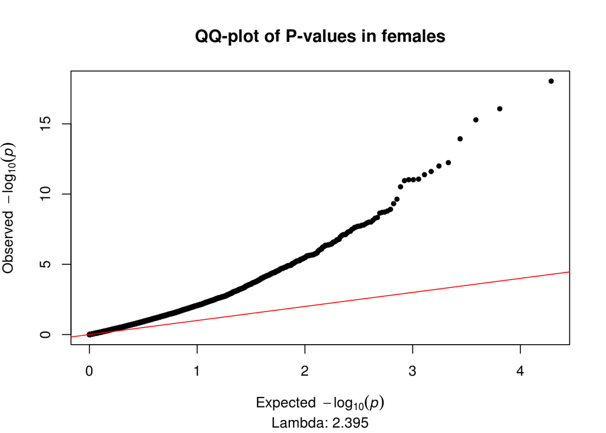

### Model 2 - 2PCs

Two PCs are regressed out, and the ANOVA for diagnosis has been run. Tables of the top 1000 DMPs for diagnosis have been produced and saved separately.

#### Top DMPs

**ANOVA:**  
51 probes pass the epigenome-wide significance threshold of 2.4x10-7 *The top 50 diagnosis associated DMPs:*

| ProbeID | Position | F | p (F) | FDR.Anova | Difference | CI lower | CI upper | pCvM | FDR | Difference | CI lower | CI upper | pCvA | FDR | Difference | CI lower | CI upper | pMvA | FDR | UCSC Gene | UCSC Gene Group | UCSC Relation to CpG Island | Gene Closest TSS | Distance Closest TSS | GREAT Annotation 1 | GREAT Annotation 2 |
| --- | --- | --- | --- | --- | --- | --- | --- | --- | --- | --- | --- | --- | --- | --- | --- | --- | --- | --- | --- | --- | --- | --- | --- | --- | --- | --- |
| cg22822140 | chr X: 153046577 | 53.387 | 1.19e-18 | 1.15e-14 | -0.008 | -0.031 | 0.015 | 0.67 | 1 | -0.092 | -0.116 | -0.069 | 4.87e-14 | 4.70e-10 | -0.084 | -0.107 | -0.061 | 6.58e-14 | 3.54e-10 | SRPK3;SRPK3;SRPK3 | 1stExon;1stExon;1stExon | Island | SRPK3 | 122 | SRPK3 (122) | (NA) |
| cg12230162 | chr X: 153046482 | 44.806 | 2.64e-16 | 1.28e-12 | 0.003 | -0.023 | 0.028 | 0.966 | 1 | -0.087 | -0.113 | -0.061 | 6.24e-13 | 2.01e-09 | -0.09 | -0.115 | -0.064 | 1.05e-13 | 3.54e-10 | SRPK3;SRPK3;SRPK3;SRPK3;SRPK3;SRPK3 | 5'UTR;1stExon;1stExon;5'UTR;5'UTR;1stExon | Island | SRPK3 | 27 | SRPK3 (27) | (NA) |
| cg24496423 | chr X: 153046480 | 42.855 | 9.50e-16 | 3.06e-12 | 0.003 | -0.017 | 0.023 | 0.943 | 1 | -0.067 | -0.087 | -0.046 | 2.12e-12 | 5.12e-09 | -0.069 | -0.089 | -0.050 | 1.86e-13 | 4.49e-10 | SRPK3;SRPK3;SRPK3;SRPK3;SRPK3;SRPK3 | 5'UTR;1stExon;1stExon;5'UTR;5'UTR;1stExon | Island | SRPK3 | 25 | SRPK3 (25) | (NA) |
| cg13009143 | chr X: 100548223 | 35.981 | 1.02e-13 | 2.45e-10 | -0.015 | -0.022 | -0.008 | 1.82e-06 | 4.87e-04 | 0.009 | 0.002 | 0.016 | 0.006 | 0.132 | 0.024 | 0.018 | 0.031 | 1.10e-13 | 3.54e-10 | TAF7L | TSS200 | S_Shore | TAF7L | -164 | TAF7L (-165) | (NA) |
| cg12468189 | chr X: 153046767 | 33.193 | 7.29e-13 | 1.41e-09 | -0.024 | -0.039 | -0.009 | 8.03e-04 | 0.038 | -0.053 | -0.069 | -0.038 | 3.24e-13 | 1.56e-09 | -0.029 | -0.044 | -0.014 | 3.16e-05 | 0.009 | SRPK3;SRPK3;SRPK3 | Body;Body;Body | Island | SRPK3 | 312 | SRPK3 (312) | (NA) |
| cg19938385 | chr X: 107020894 | 29.858 | 8.21e-12 | 1.12e-08 | -0.048 | -0.066 | -0.030 | 1.23e-08 | 1.31e-05 | -0.056 | -0.074 | -0.037 | 8.77e-11 | 1.21e-07 | -0.008 | -0.026 | 0.010 | 0.567 | 1 |  |  | S_Shore | TSC22D3 | -1692 | TSC22D3 (-1878) | (NA) |
| cg16529483 | chr X: 153046451 | 29.827 | 8.39e-12 | 1.12e-08 | -0.012 | -0.037 | 0.013 | 0.516 | 1 | -0.077 | -0.102 | -0.051 | 8.51e-11 | 1.21e-07 | -0.065 | -0.09 | -0.040 | 1.62e-08 | 1.42e-05 | SRPK3;SRPK3;SRPK3 | TSS200;TSS200;TSS200 | Island | SRPK3 | -4 | SRPK3 (-4) | (NA) |
| cg16152676 | chr X: 10126878 | 29.686 | 9.31e-12 | 1.12e-08 | 0.039 | 0.024 | 0.054 | 7.07e-09 | 1.10e-05 | -0.004 | -0.018 | 0.011 | 0.837 | 1 | -0.043 | -0.057 | -0.028 | 2.72e-10 | 3.75e-07 | CLCN4 | 5'UTR | Island | CLCN4 | 550 | CLCN4 (1894) | MID1 (724930) |
| cg19280671 | chr X: 149013642 | 28.755 | 1.86e-11 | 1.99e-08 | 0.017 | 0.011 | 0.023 | 4.65e-10 | 1.70e-06 | 0.002 | -0.004 | 0.008 | 0.795 | 1 | -0.016 | -0.021 | -0.010 | 1.28e-08 | 1.24e-05 | MAGEA8;MAGEA8;MAGEA8 | Body;Body;Body |  | MAGEA8 | 596 | MAMLD1 (-517908) | MAGEA8 (3702) |
| cg17405188 | chr X: 73164102 | 28.158 | 2.90e-11 | 2.52e-08 | 0.009 | 0.004 | 0.015 | 2.93e-04 | 0.018 | 0.017 | 0.012 | 0.023 | 1.07e-11 | 2.06e-08 | 0.008 | 0.003 | 0.014 | 0.001 | 0.093 | LOC554203 | TSS200 | Island | JPX | -56 | ZCCHC13 (-359922) | CHIC1 (381119) |
| cg03360001 | chr X: 53453272 | 28.109 | 3.00e-11 | 2.52e-08 | -0.009 | -0.015 | -0.003 | 0.002 | 0.08 | 0.010 | 0.004 | 0.016 | 2.64e-04 | 0.017 | 0.019 | 0.013 | 0.025 | 1.12e-11 | 2.17e-08 | RIBC1;RIBC1 | Body;Body | S_Shelf | RIBC1 | 3434 | SMC1A (-3655) | (NA) |
| cg09768654 | chr X: 153046386 | 28.053 | 3.13e-11 | 2.52e-08 | 0.009 | -0.014 | 0.032 | 0.642 | 1 | -0.059 | -0.082 | -0.035 | 5.01e-08 | 3.22e-05 | -0.067 | -0.09 | -0.044 | 2.48e-10 | 3.75e-07 | SRPK3;SRPK3;SRPK3 | TSS200;TSS200;TSS200 | Island | SRPK3 | -69 | SRPK3 (-69) | (NA) |
| cg24605338 | chr X: 17395856 | 27.497 | 4.76e-11 | 3.53e-08 | -0.035 | -0.047 | -0.024 | 1.75e-11 | 1.69e-07 | -0.019 | -0.030 | -0.007 | 4.45e-04 | 0.026 | 0.017 | 0.005 | 0.028 | 0.002 | 0.128 | NHS | Body | S_Shore | NHS | 2314 | SCML1 (-359735) | NHS (2314) |
| cg17003204 | chr X: 102861456 | 24.071 | 6.52e-10 | 4.49e-07 | -0.036 | -0.049 | -0.024 | 5.70e-10 | 1.70e-06 | -0.012 | -0.025 | 7.26e-04 | 0.069 | 0.526 | 0.024 | 0.012 | 0.037 | 3.06e-05 | 0.009 | TCEAL3;TCEAL3 | TSS1500;TSS1500 | N_Shore | TCEAL3 | -1377 | TCEAL3 (-1377) | (NA) |
| cg17513789 | chr X: 73073251 | 22.925 | 1.59e-09 | 9.75e-07 | -0.046 | -0.062 | -0.030 | 7.05e-10 | 1.70e-06 | -0.027 | -0.043 | -0.011 | 3.69e-04 | 0.023 | 0.019 | 0.003 | 0.035 | 0.016 | 0.434 | XIST | TSS1500 |  | XIST | -663 | ZCCHC13 (-450773) | CHIC1 (290268) |
| cg21364342 | chr X: 107226611 | 22.907 | 1.62e-09 | 9.75e-07 | -0.022 | -0.032 | -0.012 | 5.36e-07 | 2.12e-04 | -0.025 | -0.035 | -0.016 | 1.06e-08 | 1.14e-05 | -0.004 | -0.013 | 0.006 | 0.659 | 1 | TEX13B | TSS1500 |  | TEX13B | -1011 | VSIG1 (-61588) | MID2 (157528) |
| cg16122592 | chr X: 26210712 | 22.419 | 2.37e-09 | 1.31e-06 | -0.030 | -0.042 | -0.019 | 9.12e-09 | 1.10e-05 | -0.026 | -0.037 | -0.014 | 1.49e-06 | 4.48e-04 | 0.005 | -0.007 | 0.016 | 0.596 | 1 | MAGEB6 | 5'UTR |  | MAGEB6 | 156 | MAGEB6 (156) | (NA) |
| cg21252909 | chr X: 30326328 | 22.387 | 2.44e-09 | 1.31e-06 | 0.036 | 0.013 | 0.059 | 7.63e-04 | 0.037 | -0.028 | -0.052 | -0.005 | 0.013 | 0.201 | -0.065 | -0.088 | -0.042 | 1.09e-09 | 1.32e-06 | NR0B1 | 1stExon | N_Shore | NR0B1 | 1167 | NR0B1 (1166) | (NA) |
| cg09661041 | chr X: 153141905 | 22.199 | 2.82e-09 | 1.43e-06 | -0.005 | -0.028 | 0.019 | 0.889 | 1 | -0.060 | -0.084 | -0.036 | 4.58e-08 | 3.16e-05 | -0.056 | -0.079 | -0.032 | 2.72e-07 | 1.64e-04 | L1CAM;L1CAM;L1CAM | TSS1500;TSS1500;TSS1500 |  | L1CAM | -506 | L1CAM (-507) | (NA) |
| cg11179997 | chr X: 119125670 | 21.530 | 4.80e-09 | 2.31e-06 | 0.028 | 0.017 | 0.039 | 1.01e-07 | 6.94e-05 | 0.002 | -0.010 | 0.013 | 0.949 | 1 | -0.026 | -0.038 | -0.015 | 4.10e-07 | 2.20e-04 |  |  | Island | AK123976 | -44530 | NKAP (-47936) | RHOXF2 (86036) |
| cg00123001 | chr X: 13395880 | 21.374 | 5.43e-09 | 2.49e-06 | -0.019 | -0.027 | -0.011 | 2.88e-07 | 1.26e-04 | -0.020 | -0.028 | -0.012 | 1.06e-07 | 6.01e-05 | -9.50e-04 | -0.009 | 0.007 | 0.958 | 1 |  |  | N_Shore | LOC100133123 | 42521 | EGFL6 (-191813) | ATXN3L (-57363) |
| cg15907464 | chr X: 70712790 | 21.296 | 5.78e-09 | 2.54e-06 | -0.034 | -0.047 | -0.022 | 2.54e-09 | 4.89e-06 | -0.020 | -0.033 | -0.007 | 7.64e-04 | 0.037 | 0.014 | 0.002 | 0.027 | 0.018 | 0.456 | BCYRN1;INGX | Body;TSS200 | Island | INGX | -186 | OGT (-40121) | TAF1 (126677) |
| cg04768884 | chr X: 19443172 | 21.235 | 6.07e-09 | 2.55e-06 | 0.008 | -0.006 | 0.022 | 0.346 | 1 | 0.037 | 0.023 | 0.051 | 1.39e-08 | 1.25e-05 | 0.029 | 0.015 | 0.043 | 6.95e-06 | 0.003 | MAP3K15 | Body |  | MAP3K15 | 35099 | PDHA1 (81162) | MAP3K15 (90206) |
| cg17219209 | chr X: 149009840 | 20.988 | 7.39e-09 | 2.97e-06 | 0.021 | 0.013 | 0.029 | 2.61e-08 | 2.10e-05 | 0.004 | -0.004 | 0.012 | 0.497 | 1 | -0.017 | -0.025 | -0.009 | 5.62e-06 | 0.002 | MAGEA8;MAGEA8;MAGEA8 | TSS200;TSS200;TSS200 |  | MAGEA8 | -100 | MAGEA8 (-100) | (NA) |
| cg23914849 | chr X: 52950051 | 20.887 | 8.01e-09 | 3.09e-06 | 0.004 | 0.001 | 0.006 | 5.92e-04 | 0.031 | 0.006 | 0.004 | 0.008 | 3.74e-09 | 4.51e-06 | 0.003 | 3.47e-04 | 0.005 | 0.019 | 0.464 |  |  | Island | FAM156A | 13799 | FAM156B (21967) | FAM156A (74599) |
| cg25896901 | chr X: 125300481 | 20.196 | 1.40e-08 | 5.18e-06 | 0.010 | -0.016 | 0.035 | 0.64 | 1 | -0.054 | -0.080 | -0.028 | 5.44e-06 | 0.001 | -0.064 | -0.09 | -0.039 | 4.83e-08 | 3.33e-05 | DCAF12L2 | TSS1500 | S_Shore | DCAF12L2 | -401 | DCAF12L1 (386360) | (NA) |
| cg09513996 | chr X: 48685182 | 20.127 | 1.47e-08 | 5.27e-06 | 0.007 | -0.007 | 0.021 | 0.467 | 1 | -0.028 | -0.042 | -0.014 | 1.27e-05 | 0.002 | -0.035 | -0.049 | -0.021 | 3.14e-08 | 2.53e-05 |  |  | Island | ERAS | -2100 | ERAS (-2100) | (NA) |
| cg06452970 | chr X: 13835264 | 20.081 | 1.53e-08 | 5.28e-06 | 0.048 | 0.029 | 0.067 | 5.14e-08 | 3.81e-05 | 0.009 | -0.010 | 0.028 | 0.515 | 1 | -0.039 | -0.058 | -0.020 | 8.97e-06 | 0.003 | GPM6B;GPM6B;GPM6B;GPM6B;GPM6B;GPM6B;GPM6B | 1stExon;5'UTR;5'UTR;Body;5'UTR;1stExon;1stExon |  | GPM6B | 50 | GPM6B (49) | (NA) |
| cg00632130 | chr X: 47931806 | 19.902 | 1.77e-08 | 5.67e-06 | -0.012 | -0.025 | 0.002 | 0.106 | 0.644 | 0.024 | 0.010 | 0.037 | 1.98e-04 | 0.015 | 0.035 | 0.022 | 0.049 | 1.21e-08 | 1.24e-05 | ZNF630 | TSS1500 | S_Shore | ZNF630 | -781 | ZNF630 (-1299) | (NA) |
| cg25549901 | chr X: 137951118 | 19.877 | 1.81e-08 | 5.67e-06 | -0.027 | -0.038 | -0.016 | 1.22e-07 | 7.33e-05 | -0.024 | -0.035 | -0.013 | 2.12e-06 | 5.67e-04 | 0.002 | -0.008 | 0.013 | 0.854 | 1 | FGF13;FGF13;FGF13;FGF13 | 5'UTR;Body;TSS1500;Body |  | FGF13 | -1401 | FGF13 (336066) | (NA) |
| cg14917571 | chr X: 79269151 | 19.866 | 1.82e-08 | 5.67e-06 | -0.051 | -0.07 | -0.032 | 8.43e-09 | 1.10e-05 | -0.030 | -0.049 | -0.011 | 9.55e-04 | 0.043 | 0.021 | 0.002 | 0.040 | 0.029 | 0.581 | TBX22;TBX22 | TSS1500;TSS1500 |  | TBX22 | -1103 | ITM2A (-646103) | TBX22 (-8590) |
| cg06068202 | chr X: 150343148 | 19.544 | 2.36e-08 | 6.96e-06 | 0.041 | 0.022 | 0.060 | 3.04e-06 | 7.16e-04 | 0.047 | 0.028 | 0.067 | 1.36e-07 | 6.92e-05 | 0.006 | -0.013 | 0.025 | 0.745 | 1 |  |  | Island | GPR50 | -1907 | GPR50 (-1907) | (NA) |
| cg09953945 | chr X: 150345040 | 19.535 | 2.38e-08 | 6.96e-06 | -0.029 | -0.04 | -0.018 | 1.36e-08 | 1.31e-05 | -0.019 | -0.030 | -0.007 | 3.78e-04 | 0.023 | 0.01 | -6.41e-04 | 0.022 | 0.069 | 0.884 | GPR50 | TSS200 | N_Shore | GPR50 | -15 | GPR50 (-15) | (NA) |
| cg00805156 | chr X: 3264341 | 19.368 | 2.72e-08 | 7.73e-06 | 0.036 | 0.019 | 0.053 | 2.49e-06 | 6.17e-04 | 0.040 | 0.023 | 0.057 | 1.95e-07 | 8.95e-05 | 0.004 | -0.012 | 0.021 | 0.813 | 1 | MXRA5 | 5'UTR | Island | MXRA5 | 343 | MXRA5 (342) | (NA) |
| cg08630881 | chr X: 70713213 | 19.238 | 3.03e-08 | 8.35e-06 | -0.028 | -0.039 | -0.017 | 1.66e-08 | 1.46e-05 | -0.018 | -0.029 | -0.007 | 5.12e-04 | 0.028 | 0.01 | -4.25e-04 | 0.021 | 0.063 | 0.833 | BCYRN1;INGX | Body;TSS1500 | S_Shore | INGX | -609 | OGT (-39698) | TAF1 (127100) |
| cg22574818 | chr X: 55479616 | 19.147 | 3.26e-08 | 8.74e-06 | -0.033 | -0.056 | -0.011 | 0.002 | 0.071 | -0.061 | -0.084 | -0.037 | 1.43e-08 | 1.25e-05 | -0.027 | -0.05 | -0.004 | 0.015 | 0.413 | MAGEH1;MAGEH1 | 1stExon;3'UTR |  | MAGEH1 | 1079 | MAGEH1 (1079) | USP51 (36014) |
| cg00072799 | chr X: 78427682 | 19.012 | 3.64e-08 | 9.33e-06 | -0.007 | -0.021 | 0.007 | 0.479 | 1 | -0.035 | -0.049 | -0.021 | 9.76e-08 | 5.89e-05 | -0.028 | -0.042 | -0.014 | 1.38e-05 | 0.005 | GPR174;GPR174 | 1stExon;3'UTR |  | GPR174 | 1214 | GPR174 (1214) | ITM2A (195366) |
| cg01737010 | chr X: 101772014 | 19.000 | 3.68e-08 | 9.33e-06 | 0.007 | -0.003 | 0.017 | 0.237 | 0.939 | -0.018 | -0.028 | -0.008 | 9.34e-05 | 0.008 | -0.025 | -0.035 | -0.015 | 3.75e-08 | 2.79e-05 | TMSB15A | TSS1500 | S_Shore | TMSB15A | -315 | TMSB15A (-316) | (NA) |
| cg22926378 | chr X: 6144633 | 18.518 | 5.45e-08 | 1.35e-05 | 0.014 | 0.007 | 0.021 | 2.25e-05 | 0.003 | -0.003 | -0.010 | 0.004 | 0.552 | 1 | -0.017 | -0.024 | -0.010 | 1.56e-07 | 1.01e-04 | NLGN4X;NLGN4X | 5'UTR;5'UTR | Island | NLGN4X | 483 | NLGN4X (2072) | (NA) |
| cg04710661 | chr X: 2848381 | 18.435 | 5.83e-08 | 1.41e-05 | 0.007 | 3.38e-04 | 0.014 | 0.037 | 0.392 | 0.018 | 0.011 | 0.024 | 3.03e-08 | 2.44e-05 | 0.01 | 0.004 | 0.017 | 0.001 | 0.092 | ARSD;ARSD | TSS1500;TSS1500 | S_Shore | ARSD | -965 | ARSD (-966) | (NA) |
| cg26484667 | chr X: 2733164 | 18.305 | 6.49e-08 | 1.53e-05 | -0.029 | -0.041 | -0.017 | 1.18e-07 | 7.33e-05 | -0.007 | -0.019 | 0.005 | 0.367 | 1 | 0.022 | 0.01 | 0.034 | 5.47e-05 | 0.012 | XG;XG;XG | 3'UTR;3'UTR;3'UTR |  | GYG2 | -13698 | GYG2 (-13698) | XG (63072) |
| cg07344627 | chr X: 125687011 | 17.998 | 8.35e-08 | 1.88e-05 | -0.035 | -0.059 | -0.011 | 0.002 | 0.079 | -0.062 | -0.087 | -0.038 | 3.81e-08 | 2.83e-05 | -0.027 | -0.052 | -0.003 | 0.022 | 0.506 | DCAF12L1 | TSS200 | S_Shore | DCAF12L1 | -169 | DCAF12L1 (-170) | (NA) |
| cg02329520 | chr X: 153740317 | 17.992 | 8.39e-08 | 1.88e-05 | -0.014 | -0.022 | -0.007 | 5.08e-05 | 0.006 | -0.019 | -0.026 | -0.011 | 1.30e-07 | 6.92e-05 | -0.004 | -0.012 | 0.003 | 0.346 | 1 | FAM3A;FAM3A;FAM3A;FAM3A;FAM3A | Body;Body;Body;Body;Body | N_Shelf | FAM3A | 4249 | SLC10A3 (-21316) | FAM3A (4248) |
| cg11315455 | chr X: 122997585 | 17.846 | 9.46e-08 | 2.07e-05 | -0.029 | -0.041 | -0.017 | 2.61e-07 | 1.20e-04 | -0.006 | -0.018 | 0.007 | 0.535 | 1 | 0.023 | 0.011 | 0.036 | 3.22e-05 | 0.009 | XIAP | 5'UTR | S_Shelf | XIAP | 3569 | STAG2 (-96889) | XIAP (3569) |
| cg26101161 | chr X: 122736584 | 17.671 | 1.09e-07 | 2.34e-05 | -0.021 | -0.031 | -0.011 | 5.62e-06 | 0.001 | -0.023 | -0.033 | -0.013 | 7.88e-07 | 2.62e-04 | -0.002 | -0.012 | 0.008 | 0.872 | 1 | THOC2 | 3'UTR |  | THOC2 | 8230 | THOC2 (130319) | GRIA3 (418489) |
| cg25177692 | chr X: 129193893 | 17.523 | 1.23e-07 | 2.59e-05 | -0.027 | -0.038 | -0.016 | 1.69e-07 | 8.95e-05 | -0.021 | -0.032 | -0.009 | 7.96e-05 | 0.007 | 0.006 | -0.005 | 0.017 | 0.386 | 1 |  |  | N_Shore | BCORL1 | 34929 | ELF4 (50794) | BCORL1 (54730) |
| cg07892139 | chr X: 84192519 | 17.204 | 1.61e-07 | 3.23e-05 | -0.045 | -0.066 | -0.025 | 1.44e-06 | 4.22e-04 | -0.043 | -0.064 | -0.023 | 5.48e-06 | 0.001 | 0.002 | -0.018 | 0.022 | 0.971 | 1 |  |  | S_Shelf | UBE2DNL | 3363 | APOOL (-66378) | UBE2DNL (3363) |
| cg08464958 | chr X: 2852845 | 17.204 | 1.61e-07 | 3.23e-05 | -0.022 | -0.032 | -0.013 | 4.16e-07 | 1.75e-04 | -0.004 | -0.014 | 0.005 | 0.539 | 1 | 0.018 | 0.008 | 0.027 | 4.71e-05 | 0.011 | ARSE | 3'UTR |  | ARSD | -5429 | ARSD (-5430) | ARSE (29648) |
| cg26747413 | chr X: 15807140 | 17.151 | 1.68e-07 | 3.31e-05 | -0.039 | -0.055 | -0.022 | 5.49e-07 | 2.12e-04 | -0.033 | -0.050 | -0.016 | 2.09e-05 | 0.003 | 0.005 | -0.011 | 0.022 | 0.735 | 1 | INE2;ZRSR2 | TSS1500;TSS1500 | N_Shore | INE2 | -1428 | ZRSR2 (-1433) | (NA) |
| cg05889382 | chr X: 70887722 | 17.077 | 1.79e-07 | 3.45e-05 | -0.020 | -0.029 | -0.011 | 1.64e-06 | 4.53e-04 | -0.019 | -0.029 | -0.01 | 5.67e-06 | 0.001 | 8.07e-04 | -0.008 | 0.010 | 0.976 | 1 | BCYRN1 | Body | Island | LOC100132741 | -29323 | PIN4 (-513803) | CXCR3 (-49356) |

**CTL vs MCI:**  
20 probes pass the epigenome-wide significance threshold of 2.4x10-7

*The top 50 CTL vs MCI associated DMPs:*

| ProbeID | Position | F | p (F) | FDR.Anova | Difference | CI lower | CI upper | pCvM | FDR | Difference | CI lower | CI upper | pCvA | FDR | Difference | CI lower | CI upper | pMvA | FDR | UCSC Gene | UCSC Gene Group | UCSC Relation to CpG Island | Gene Closest TSS | Distance Closest TSS | GREAT Annotation 1 | GREAT Annotation 2 |
| --- | --- | --- | --- | --- | --- | --- | --- | --- | --- | --- | --- | --- | --- | --- | --- | --- | --- | --- | --- | --- | --- | --- | --- | --- | --- | --- |
| cg24605338 | chr X: 17395856 | 27.497 | 4.76e-11 | 3.53e-08 | -0.035 | -0.047 | -0.024 | 1.75e-11 | 1.69e-07 | -0.019 | -0.03 | -0.007 | 4.45e-04 | 0.026 | 0.017 | 0.005 | 0.028 | 0.002 | 0.128 | NHS | Body | S_Shore | NHS | 2314 | SCML1 (-359735) | NHS (2314) |
| cg19280671 | chr X: 149013642 | 28.755 | 1.86e-11 | 1.99e-08 | 0.017 | 0.011 | 0.023 | 4.65e-10 | 1.70e-06 | 0.002 | -0.004 | 0.008 | 0.795 | 1 | -0.016 | -0.021 | -0.01 | 1.28e-08 | 1.24e-05 | MAGEA8;MAGEA8;MAGEA8 | Body;Body;Body |  | MAGEA8 | 596 | MAMLD1 (-517908) | MAGEA8 (3702) |
| cg17003204 | chr X: 102861456 | 24.071 | 6.52e-10 | 4.49e-07 | -0.036 | -0.049 | -0.024 | 5.70e-10 | 1.70e-06 | -0.012 | -0.025 | 7.26e-04 | 0.069 | 0.526 | 0.024 | 0.012 | 0.037 | 3.06e-05 | 0.009 | TCEAL3;TCEAL3 | TSS1500;TSS1500 | N_Shore | TCEAL3 | -1377 | TCEAL3 (-1377) | (NA) |
| cg17513789 | chr X: 73073251 | 22.925 | 1.59e-09 | 9.75e-07 | -0.046 | -0.062 | -0.030 | 7.05e-10 | 1.70e-06 | -0.027 | -0.043 | -0.011 | 3.69e-04 | 0.023 | 0.019 | 0.003 | 0.035 | 0.016 | 0.434 | XIST | TSS1500 |  | XIST | -663 | ZCCHC13 (-450773) | CHIC1 (290268) |
| cg15907464 | chr X: 70712790 | 21.296 | 5.78e-09 | 2.54e-06 | -0.034 | -0.047 | -0.022 | 2.54e-09 | 4.89e-06 | -0.020 | -0.033 | -0.007 | 7.64e-04 | 0.037 | 0.014 | 0.002 | 0.027 | 0.018 | 0.456 | BCYRN1;INGX | Body;TSS200 | Island | INGX | -186 | OGT (-40121) | TAF1 (126677) |
| cg16152676 | chr X: 10126878 | 29.686 | 9.31e-12 | 1.12e-08 | 0.039 | 0.024 | 0.054 | 7.07e-09 | 1.10e-05 | -0.004 | -0.018 | 0.011 | 0.837 | 1 | -0.043 | -0.057 | -0.028 | 2.72e-10 | 3.75e-07 | CLCN4 | 5'UTR | Island | CLCN4 | 550 | CLCN4 (1894) | MID1 (724930) |
| cg14917571 | chr X: 79269151 | 19.866 | 1.82e-08 | 5.67e-06 | -0.051 | -0.070 | -0.032 | 8.43e-09 | 1.10e-05 | -0.030 | -0.049 | -0.011 | 9.55e-04 | 0.043 | 0.021 | 0.002 | 0.04 | 0.029 | 0.581 | TBX22;TBX22 | TSS1500;TSS1500 |  | TBX22 | -1103 | ITM2A (-646103) | TBX22 (-8590) |
| cg16122592 | chr X: 26210712 | 22.419 | 2.37e-09 | 1.31e-06 | -0.030 | -0.042 | -0.019 | 9.12e-09 | 1.10e-05 | -0.026 | -0.037 | -0.014 | 1.49e-06 | 4.48e-04 | 0.005 | -0.007 | 0.016 | 0.596 | 1 | MAGEB6 | 5'UTR |  | MAGEB6 | 156 | MAGEB6 (156) | (NA) |
| cg19938385 | chr X: 107020894 | 29.858 | 8.21e-12 | 1.12e-08 | -0.048 | -0.066 | -0.030 | 1.23e-08 | 1.31e-05 | -0.056 | -0.074 | -0.037 | 8.77e-11 | 1.21e-07 | -0.008 | -0.026 | 0.01 | 0.567 | 1 |  |  | S_Shore | TSC22D3 | -1692 | TSC22D3 (-1878) | (NA) |
| cg09953945 | chr X: 150345040 | 19.535 | 2.38e-08 | 6.96e-06 | -0.029 | -0.040 | -0.018 | 1.36e-08 | 1.31e-05 | -0.019 | -0.03 | -0.007 | 3.78e-04 | 0.023 | 0.01 | -6.41e-04 | 0.022 | 0.069 | 0.884 | GPR50 | TSS200 | N_Shore | GPR50 | -15 | GPR50 (-15) | (NA) |
| cg08630881 | chr X: 70713213 | 19.238 | 3.03e-08 | 8.35e-06 | -0.028 | -0.039 | -0.017 | 1.66e-08 | 1.46e-05 | -0.018 | -0.029 | -0.007 | 5.12e-04 | 0.028 | 0.01 | -4.25e-04 | 0.021 | 0.063 | 0.833 | BCYRN1;INGX | Body;TSS1500 | S_Shore | INGX | -609 | OGT (-39698) | TAF1 (127100) |
| cg17219209 | chr X: 149009840 | 20.988 | 7.39e-09 | 2.97e-06 | 0.021 | 0.013 | 0.029 | 2.61e-08 | 2.10e-05 | 0.004 | -0.004 | 0.012 | 0.497 | 1 | -0.017 | -0.025 | -0.009 | 5.62e-06 | 0.002 | MAGEA8;MAGEA8;MAGEA8 | TSS200;TSS200;TSS200 |  | MAGEA8 | -100 | MAGEA8 (-100) | (NA) |
| cg06452970 | chr X: 13835264 | 20.081 | 1.53e-08 | 5.28e-06 | 0.048 | 0.029 | 0.067 | 5.14e-08 | 3.81e-05 | 0.009 | -0.01 | 0.028 | 0.515 | 1 | -0.039 | -0.058 | -0.02 | 8.97e-06 | 0.003 | GPM6B;GPM6B;GPM6B;GPM6B;GPM6B;GPM6B;GPM6B | 1stExon;5'UTR;5'UTR;Body;5'UTR;1stExon;1stExon |  | GPM6B | 50 | GPM6B (49) | (NA) |
| cg11179997 | chr X: 119125670 | 21.530 | 4.80e-09 | 2.31e-06 | 0.028 | 0.017 | 0.039 | 1.01e-07 | 6.94e-05 | 0.002 | -0.01 | 0.013 | 0.949 | 1 | -0.026 | -0.038 | -0.015 | 4.10e-07 | 2.20e-04 |  |  | Island | AK123976 | -44530 | NKAP (-47936) | RHOXF2 (86036) |
| cg26484667 | chr X: 2733164 | 18.305 | 6.49e-08 | 1.53e-05 | -0.029 | -0.041 | -0.017 | 1.18e-07 | 7.33e-05 | -0.007 | -0.019 | 0.005 | 0.367 | 1 | 0.022 | 0.01 | 0.034 | 5.47e-05 | 0.012 | XG;XG;XG | 3'UTR;3'UTR;3'UTR |  | GYG2 | -13698 | GYG2 (-13698) | XG (63072) |
| cg25549901 | chr X: 137951118 | 19.877 | 1.81e-08 | 5.67e-06 | -0.027 | -0.038 | -0.016 | 1.22e-07 | 7.33e-05 | -0.024 | -0.035 | -0.013 | 2.12e-06 | 5.67e-04 | 0.002 | -0.008 | 0.013 | 0.854 | 1 | FGF13;FGF13;FGF13;FGF13 | 5'UTR;Body;TSS1500;Body |  | FGF13 | -1401 | FGF13 (336066) | (NA) |
| cg04817724 | chr X: 103809991 | 16.531 | 2.82e-07 | 5.12e-05 | 0.049 | 0.029 | 0.069 | 1.32e-07 | 7.48e-05 | 0.028 | 0.008 | 0.049 | 0.004 | 0.099 | -0.021 | -0.041 | -7.88e-04 | 0.04 | 0.668 | IL1RAPL2 | TSS1500 | Island | IL1RAPL2 | -1004 | IL1RAPL2 (-1004) | (NA) |
| cg25177692 | chr X: 129193893 | 17.523 | 1.23e-07 | 2.59e-05 | -0.027 | -0.038 | -0.016 | 1.69e-07 | 8.95e-05 | -0.021 | -0.032 | -0.009 | 7.96e-05 | 0.007 | 0.006 | -0.005 | 0.017 | 0.386 | 1 |  |  | N_Shore | BCORL1 | 34929 | ELF4 (50794) | BCORL1 (54730) |
| cg24834461 | chr X: 153637645 | 16.380 | 3.19e-07 | 5.60e-05 | 0.017 | 0.010 | 0.024 | 1.76e-07 | 8.95e-05 | 0.010 | 0.003 | 0.018 | 0.002 | 0.057 | -0.006 | -0.013 | 6.97e-04 | 0.087 | 0.979 | DNASE1L1;DNASE1L1;DNASE1L1;DNASE1L1 | TSS200;5'UTR;5'UTR;5'UTR | N_Shelf | DNASE1L1 | -70 | TAZ (-2231) | (NA) |
| cg08867267 | chr X: 130033963 | 16.289 | 3.45e-07 | 5.83e-05 | -0.024 | -0.034 | -0.014 | 2.04e-07 | 9.85e-05 | -0.016 | -0.026 | -0.005 | 0.001 | 0.051 | 0.009 | -0.001 | 0.019 | 0.11 | 1 | ENOX2;ENOX2 | 5'UTR;5'UTR | N_Shelf | ENOX2 | 3245 | ENOX2 (3244) | RBMX2 (498021) |
| cg11315455 | chr X: 122997585 | 17.846 | 9.46e-08 | 2.07e-05 | -0.029 | -0.041 | -0.017 | 2.61e-07 | 1.20e-04 | -0.006 | -0.018 | 0.007 | 0.535 | 1 | 0.023 | 0.011 | 0.036 | 3.22e-05 | 0.009 | XIAP | 5'UTR | S_Shelf | XIAP | 3569 | STAG2 (-96889) | XIAP (3569) |
| cg00123001 | chr X: 13395880 | 21.374 | 5.43e-09 | 2.49e-06 | -0.019 | -0.027 | -0.011 | 2.88e-07 | 1.26e-04 | -0.020 | -0.028 | -0.012 | 1.06e-07 | 6.01e-05 | -9.50e-04 | -0.009 | 0.007 | 0.958 | 1 |  |  | N_Shore | LOC100133123 | 42521 | EGFL6 (-191813) | ATXN3L (-57363) |
| cg08464958 | chr X: 2852845 | 17.204 | 1.61e-07 | 3.23e-05 | -0.022 | -0.032 | -0.013 | 4.16e-07 | 1.75e-04 | -0.004 | -0.014 | 0.005 | 0.539 | 1 | 0.018 | 0.008 | 0.027 | 4.71e-05 | 0.011 | ARSE | 3'UTR |  | ARSD | -5429 | ARSD (-5430) | ARSE (29648) |
| cg21364342 | chr X: 107226611 | 22.907 | 1.62e-09 | 9.75e-07 | -0.022 | -0.032 | -0.012 | 5.36e-07 | 2.12e-04 | -0.025 | -0.035 | -0.016 | 1.06e-08 | 1.14e-05 | -0.004 | -0.013 | 0.006 | 0.659 | 1 | TEX13B | TSS1500 |  | TEX13B | -1011 | VSIG1 (-61588) | MID2 (157528) |
| cg26747413 | chr X: 15807140 | 17.151 | 1.68e-07 | 3.31e-05 | -0.039 | -0.055 | -0.022 | 5.49e-07 | 2.12e-04 | -0.033 | -0.05 | -0.016 | 2.09e-05 | 0.003 | 0.005 | -0.011 | 0.022 | 0.735 | 1 | INE2;ZRSR2 | TSS1500;TSS1500 | N_Shore | INE2 | -1428 | ZRSR2 (-1433) | (NA) |
| cg25396787 | chr X: 3733991 | 14.919 | 1.09e-06 | 1.51e-04 | 0.029 | 0.016 | 0.041 | 6.02e-07 | 2.23e-04 | 0.018 | 0.005 | 0.031 | 0.003 | 0.087 | -0.011 | -0.023 | 0.002 | 0.1 | 1 |  |  | Island | TRNA_Ile | 22500 | PRKX (-102317) | (NA) |
| cg25958561 | chr X: 110187179 | 15.506 | 6.66e-07 | 9.73e-05 | 0.032 | 0.018 | 0.047 | 7.66e-07 | 2.74e-04 | 0.025 | 0.01 | 0.039 | 2.76e-04 | 0.018 | -0.008 | -0.022 | 0.006 | 0.383 | 1 | PAK3;PAK3 | TSS1500;TSS1500 |  | PAK3 | -333 | PAK3 (-179125) | CHRDL1 (-148104) |
| cg25433595 | chr X: 100183764 | 15.947 | 4.59e-07 | 7.64e-05 | 0.042 | 0.024 | 0.061 | 8.21e-07 | 2.83e-04 | 0.034 | 0.015 | 0.053 | 9.66e-05 | 0.009 | -0.008 | -0.027 | 0.01 | 0.554 | 1 | XKRX;XKRX | 5'UTR;1stExon | N_Shore | XKRX | 134 | XKRX (133) | (NA) |
| cg05860920 | chr X: 11679501 | 15.422 | 7.14e-07 | 1.03e-04 | 0.060 | 0.033 | 0.086 | 8.85e-07 | 2.94e-04 | 0.046 | 0.019 | 0.072 | 2.46e-04 | 0.017 | -0.014 | -0.04 | 0.012 | 0.418 | 1 | ARHGAP6;ARHGAP6 | Body;Body | N_Shelf | ARHGAP6 | 4320 | ARHGAP6 (4319) | AMELX (367969) |
| cg27558057 | chr X: 70712724 | 14.274 | 1.89e-06 | 2.50e-04 | -0.030 | -0.043 | -0.017 | 9.47e-07 | 3.05e-04 | -0.014 | -0.027 | -1.07e-04 | 0.048 | 0.43 | 0.016 | 0.003 | 0.03 | 0.011 | 0.355 | BCYRN1;INGX | Body;TSS200 | Island | INGX | -120 | OGT (-40187) | TAF1 (126611) |
| cg12461113 | chr X: 13587550 | 14.195 | 2.02e-06 | 2.64e-04 | -0.078 | -0.113 | -0.043 | 9.86e-07 | 3.07e-04 | -0.037 | -0.072 | -0.001 | 0.039 | 0.388 | 0.042 | 0.007 | 0.076 | 0.014 | 0.406 | EGFL6;EGFL6 | TSS200;TSS200 | N_Shore | EGFL6 | -143 | EGFL6 (-143) | (NA) |
| cg14306994 | chr X: 49019804 | 13.916 | 2.57e-06 | 3.22e-04 | 0.030 | 0.016 | 0.043 | 1.24e-06 | 3.75e-04 | 0.014 | 7.11e-04 | 0.028 | 0.037 | 0.371 | -0.016 | -0.029 | -0.002 | 0.017 | 0.447 | MAGIX;MAGIX;MAGIX;MAGIX | Body;Body;Body;TSS1500 | Island | MAGIX | -316 | GPKOW (-39726) | PLP2 (-8379) |
| cg07892139 | chr X: 84192519 | 17.204 | 1.61e-07 | 3.23e-05 | -0.045 | -0.066 | -0.025 | 1.44e-06 | 4.22e-04 | -0.043 | -0.064 | -0.023 | 5.48e-06 | 0.001 | 0.002 | -0.018 | 0.022 | 0.971 | 1 |  |  | S_Shelf | UBE2DNL | 3363 | APOOL (-66378) | UBE2DNL (3363) |
| cg09979033 | chr X: 16726904 | 15.526 | 6.54e-07 | 9.71e-05 | -0.018 | -0.025 | -0.010 | 1.52e-06 | 4.30e-04 | -0.015 | -0.023 | -0.007 | 7.57e-05 | 0.007 | 0.003 | -0.005 | 0.011 | 0.675 | 1 | CTPS2;CTPS2;CTPS2 | 5'UTR;5'UTR;5'UTR | N_Shelf | CTPS2 | 3436 | CTPS2 (4154) | S100G (58624) |
| cg05889382 | chr X: 70887722 | 17.077 | 1.79e-07 | 3.45e-05 | -0.020 | -0.029 | -0.011 | 1.64e-06 | 4.53e-04 | -0.019 | -0.029 | -0.01 | 5.67e-06 | 0.001 | 8.07e-04 | -0.008 | 0.01 | 0.976 | 1 | BCYRN1 | Body | Island | LOC100132741 | -29323 | PIN4 (-513803) | CXCR3 (-49356) |
| cg13009143 | chr X: 100548223 | 35.981 | 1.02e-13 | 2.45e-10 | -0.015 | -0.022 | -0.008 | 1.82e-06 | 4.87e-04 | 0.009 | 0.002 | 0.016 | 0.006 | 0.132 | 0.024 | 0.018 | 0.031 | 1.10e-13 | 3.54e-10 | TAF7L | TSS200 | S_Shore | TAF7L | -164 | TAF7L (-165) | (NA) |
| cg26468081 | chr X: 69501565 | 13.716 | 3.05e-06 | 3.42e-04 | -0.014 | -0.021 | -0.008 | 1.93e-06 | 5.04e-04 | -0.005 | -0.012 | 0.001 | 0.128 | 0.714 | 0.009 | 0.002 | 0.015 | 0.004 | 0.232 | ARR3;RAB41 | Body;TSS1500 |  | RAB41 | -456 | RAB41 (-456) | (NA) |
| cg18497064 | chr X: 134715899 | 13.840 | 2.74e-06 | 3.23e-04 | -0.040 | -0.058 | -0.021 | 2.17e-06 | 5.52e-04 | -0.013 | -0.032 | 0.005 | 0.206 | 0.875 | 0.026 | 0.008 | 0.045 | 0.002 | 0.145 | DDX26B | 3'UTR |  | DDX26B | 12638 | ZNF449 (237204) | MMGT1 (340234) |
| cg00805156 | chr X: 3264341 | 19.368 | 2.72e-08 | 7.73e-06 | 0.036 | 0.019 | 0.053 | 2.49e-06 | 6.17e-04 | 0.040 | 0.023 | 0.057 | 1.95e-07 | 8.95e-05 | 0.004 | -0.012 | 0.021 | 0.813 | 1 | MXRA5 | 5'UTR | Island | MXRA5 | 343 | MXRA5 (342) | (NA) |
| cg07089438 | chr X: 133988190 | 13.278 | 4.45e-06 | 4.37e-04 | -0.024 | -0.036 | -0.013 | 2.83e-06 | 6.82e-04 | -0.016 | -0.027 | -0.004 | 0.004 | 0.094 | 0.008 | -0.003 | 0.02 | 0.181 | 1 | FAM122C;FAM122C | 3'UTR;Body |  | MOSPD1 | 45374 | PLAC1 (-195678) | MOSPD1 (61106) |
| cg06068202 | chr X: 150343148 | 19.544 | 2.36e-08 | 6.96e-06 | 0.041 | 0.022 | 0.060 | 3.04e-06 | 7.16e-04 | 0.047 | 0.028 | 0.067 | 1.36e-07 | 6.92e-05 | 0.006 | -0.013 | 0.025 | 0.745 | 1 |  |  | Island | GPR50 | -1907 | GPR50 (-1907) | (NA) |
| ch.X.112118442F | chr X: 112231786 | 12.838 | 6.51e-06 | 5.71e-04 | 0.013 | 0.007 | 0.018 | 3.30e-06 | 7.57e-04 | 0.007 | 0.001 | 0.013 | 0.014 | 0.211 | -0.005 | -0.011 | 4.34e-04 | 0.076 | 0.92 |  |  |  | U6 | 69427 | AMOT (-165415) | (NA) |
| cg03035653 | chr X: 99662932 | 12.645 | 7.70e-06 | 6.46e-04 | 0.039 | 0.020 | 0.057 | 4.49e-06 | 0.001 | 0.016 | -0.003 | 0.034 | 0.112 | 0.674 | -0.023 | -0.041 | -0.005 | 0.01 | 0.339 | PCDH19;PCDH19 | 1stExon;1stExon | Island | PCDH19 | 2339 | PCDH19 (2338) | (NA) |
| cg11837390 | chr X: 106957165 | 13.245 | 4.58e-06 | 4.42e-04 | -0.021 | -0.031 | -0.011 | 4.87e-06 | 0.001 | -0.016 | -0.026 | -0.006 | 9.01e-04 | 0.042 | 0.005 | -0.005 | 0.015 | 0.428 | 1 | TSC22D3;TSC22D3;TSC22D3 | 3'UTR;3'UTR;3'UTR | N_Shelf | TSC22D3 | 2546 | TSC22D3 (61851) | PRPS1 (85512) |
| cg06138173 | chr X: 16668923 | 12.444 | 9.17e-06 | 7.50e-04 | -0.030 | -0.044 | -0.016 | 5.02e-06 | 0.001 | -0.018 | -0.033 | -0.004 | 0.01 | 0.177 | 0.012 | -0.002 | 0.026 | 0.12 | 1 | CTPS2;S100G;CTPS2;CTPS2 | Body;5'UTR;Body;Body |  | S100G | 643 | S100G (643) | (NA) |
| cg25831435 | chr X: 137714452 | 13.492 | 3.70e-06 | 3.92e-04 | -0.030 | -0.044 | -0.015 | 5.06e-06 | 0.001 | -0.023 | -0.037 | -0.009 | 4.84e-04 | 0.027 | 0.006 | -0.008 | 0.02 | 0.537 | 1 | FGF13;FGF13;FGF13;FGF13;FGF13;FGF13 | 3'UTR;3'UTR;3'UTR;3'UTR;3'UTR;3'UTR |  | LOC158696 | -14653 | FGF13 (572732) | (NA) |
| cg09641151 | chr X: 153693918 | 12.849 | 6.45e-06 | 5.71e-04 | 0.028 | 0.015 | 0.041 | 5.37e-06 | 0.001 | 0.020 | 0.006 | 0.033 | 0.002 | 0.063 | -0.008 | -0.021 | 0.005 | 0.321 | 1 | PLXNA3 | Body | N_Shore | PLXNA3 | 7296 | PLXNA3 (7296) | LAGE3 (13677) |
| cg26101161 | chr X: 122736584 | 17.671 | 1.09e-07 | 2.34e-05 | -0.021 | -0.031 | -0.011 | 5.62e-06 | 0.001 | -0.023 | -0.033 | -0.013 | 7.88e-07 | 2.62e-04 | -0.002 | -0.012 | 0.008 | 0.872 | 1 | THOC2 | 3'UTR |  | THOC2 | 8230 | THOC2 (130319) | GRIA3 (418489) |
| cg00938039 | chr X: 5808230 | 12.926 | 6.04e-06 | 5.55e-04 | -0.031 | -0.046 | -0.016 | 5.88e-06 | 0.001 | -0.023 | -0.038 | -0.008 | 0.001 | 0.051 | 0.008 | -0.007 | 0.023 | 0.397 | 1 | NLGN4X;NLGN4X | 3'UTR;3'UTR | N_Shelf | NLGN4Y | 261582 | NLGN4X (338475) | (NA) |
| cg03449040 | chr X: 10094363 | 13.284 | 4.43e-06 | 4.37e-04 | -0.014 | -0.020 | -0.007 | 6.47e-06 | 0.001 | -0.003 | -0.01 | 0.003 | 0.481 | 1 | 0.01 | 0.004 | 0.017 | 6.95e-04 | 0.075 | WWC3 | Body | Island | CLCN4 | -30621 | CLCN4 (-30621) | SHROOM2 (339868) |

**CTL vs AD:**  
22 probes pass the epigenome-wide significance threshold of 2.4x10-7  
*The top 50 CTL vs AD associated DMPs:*

| ProbeID | Position | F | p (F) | FDR.Anova | Difference | CI lower | CI upper | pCvM | FDR | Difference | CI lower | CI upper | pCvA | FDR | Difference | CI lower | CI upper | pMvA | FDR | UCSC Gene | UCSC Gene Group | UCSC Relation to CpG Island | Gene Closest TSS | Distance Closest TSS | GREAT Annotation 1 | GREAT Annotation 2 |
| --- | --- | --- | --- | --- | --- | --- | --- | --- | --- | --- | --- | --- | --- | --- | --- | --- | --- | --- | --- | --- | --- | --- | --- | --- | --- | --- |
| cg22822140 | chr X: 153046577 | 53.387 | 1.19e-18 | 1.15e-14 | -0.008 | -0.031 | 0.015 | 0.67 | 1 | -0.092 | -0.116 | -0.069 | 4.87e-14 | 4.70e-10 | -0.084 | -0.107 | -0.061 | 6.58e-14 | 3.54e-10 | SRPK3;SRPK3;SRPK3 | 1stExon;1stExon;1stExon | Island | SRPK3 | 122 | SRPK3 (122) | (NA) |
| cg12468189 | chr X: 153046767 | 33.193 | 7.29e-13 | 1.41e-09 | -0.024 | -0.039 | -0.009 | 8.03e-04 | 0.038 | -0.053 | -0.069 | -0.038 | 3.24e-13 | 1.56e-09 | -0.029 | -0.044 | -0.014 | 3.16e-05 | 0.009 | SRPK3;SRPK3;SRPK3 | Body;Body;Body | Island | SRPK3 | 312 | SRPK3 (312) | (NA) |
| cg12230162 | chr X: 153046482 | 44.806 | 2.64e-16 | 1.28e-12 | 0.003 | -0.023 | 0.028 | 0.966 | 1 | -0.087 | -0.113 | -0.061 | 6.24e-13 | 2.01e-09 | -0.09 | -0.115 | -0.064 | 1.05e-13 | 3.54e-10 | SRPK3;SRPK3;SRPK3;SRPK3;SRPK3;SRPK3 | 5'UTR;1stExon;1stExon;5'UTR;5'UTR;1stExon | Island | SRPK3 | 27 | SRPK3 (27) | (NA) |
| cg24496423 | chr X: 153046480 | 42.855 | 9.50e-16 | 3.06e-12 | 0.003 | -0.017 | 0.023 | 0.943 | 1 | -0.067 | -0.087 | -0.046 | 2.12e-12 | 5.12e-09 | -0.069 | -0.089 | -0.05 | 1.86e-13 | 4.49e-10 | SRPK3;SRPK3;SRPK3;SRPK3;SRPK3;SRPK3 | 5'UTR;1stExon;1stExon;5'UTR;5'UTR;1stExon | Island | SRPK3 | 25 | SRPK3 (25) | (NA) |
| cg17405188 | chr X: 73164102 | 28.158 | 2.90e-11 | 2.52e-08 | 0.009 | 0.004 | 0.015 | 2.93e-04 | 0.018 | 0.017 | 0.012 | 0.023 | 1.07e-11 | 2.06e-08 | 0.008 | 0.003 | 0.014 | 0.001 | 0.093 | LOC554203 | TSS200 | Island | JPX | -56 | ZCCHC13 (-359922) | CHIC1 (381119) |
| cg16529483 | chr X: 153046451 | 29.827 | 8.39e-12 | 1.12e-08 | -0.012 | -0.037 | 0.013 | 0.516 | 1 | -0.077 | -0.102 | -0.051 | 8.51e-11 | 1.21e-07 | -0.065 | -0.09 | -0.04 | 1.62e-08 | 1.42e-05 | SRPK3;SRPK3;SRPK3 | TSS200;TSS200;TSS200 | Island | SRPK3 | -4 | SRPK3 (-4) | (NA) |
| cg19938385 | chr X: 107020894 | 29.858 | 8.21e-12 | 1.12e-08 | -0.048 | -0.066 | -0.03 | 1.23e-08 | 1.31e-05 | -0.056 | -0.074 | -0.037 | 8.77e-11 | 1.21e-07 | -0.008 | -0.026 | 0.01 | 0.567 | 1 |  |  | S_Shore | TSC22D3 | -1692 | TSC22D3 (-1878) | (NA) |
| cg23914849 | chr X: 52950051 | 20.887 | 8.01e-09 | 3.09e-06 | 0.004 | 0.001 | 0.006 | 5.92e-04 | 0.031 | 0.006 | 0.004 | 0.008 | 3.74e-09 | 4.51e-06 | 0.003 | 3.47e-04 | 0.005 | 0.019 | 0.464 |  |  | Island | FAM156A | 13799 | FAM156B (21967) | FAM156A (74599) |
| cg21364342 | chr X: 107226611 | 22.907 | 1.62e-09 | 9.75e-07 | -0.022 | -0.032 | -0.012 | 5.36e-07 | 2.12e-04 | -0.025 | -0.035 | -0.016 | 1.06e-08 | 1.14e-05 | -0.004 | -0.013 | 0.006 | 0.659 | 1 | TEX13B | TSS1500 |  | TEX13B | -1011 | VSIG1 (-61588) | MID2 (157528) |
| cg04768884 | chr X: 19443172 | 21.235 | 6.07e-09 | 2.55e-06 | 0.008 | -0.006 | 0.022 | 0.346 | 1 | 0.037 | 0.023 | 0.051 | 1.39e-08 | 1.25e-05 | 0.029 | 0.015 | 0.043 | 6.95e-06 | 0.003 | MAP3K15 | Body |  | MAP3K15 | 35099 | PDHA1 (81162) | MAP3K15 (90206) |
| cg22574818 | chr X: 55479616 | 19.147 | 3.26e-08 | 8.74e-06 | -0.033 | -0.056 | -0.011 | 0.002 | 0.071 | -0.061 | -0.084 | -0.037 | 1.43e-08 | 1.25e-05 | -0.027 | -0.05 | -0.004 | 0.015 | 0.413 | MAGEH1;MAGEH1 | 1stExon;3'UTR |  | MAGEH1 | 1079 | MAGEH1 (1079) | USP51 (36014) |
| cg04710661 | chr X: 2848381 | 18.435 | 5.83e-08 | 1.41e-05 | 0.007 | 3.38e-04 | 0.014 | 0.037 | 0.392 | 0.018 | 0.011 | 0.024 | 3.03e-08 | 2.44e-05 | 0.01 | 0.004 | 0.017 | 0.001 | 0.092 | ARSD;ARSD | TSS1500;TSS1500 | S_Shore | ARSD | -965 | ARSD (-966) | (NA) |
| cg07344627 | chr X: 125687011 | 17.998 | 8.35e-08 | 1.88e-05 | -0.035 | -0.059 | -0.011 | 0.002 | 0.079 | -0.062 | -0.087 | -0.038 | 3.81e-08 | 2.83e-05 | -0.027 | -0.052 | -0.003 | 0.022 | 0.506 | DCAF12L1 | TSS200 | S_Shore | DCAF12L1 | -169 | DCAF12L1 (-170) | (NA) |
| cg09661041 | chr X: 153141905 | 22.199 | 2.82e-09 | 1.43e-06 | -0.005 | -0.028 | 0.019 | 0.889 | 1 | -0.060 | -0.084 | -0.036 | 4.58e-08 | 3.16e-05 | -0.056 | -0.079 | -0.032 | 2.72e-07 | 1.64e-04 | L1CAM;L1CAM;L1CAM | TSS1500;TSS1500;TSS1500 |  | L1CAM | -506 | L1CAM (-507) | (NA) |
| cg09768654 | chr X: 153046386 | 28.053 | 3.13e-11 | 2.52e-08 | 0.009 | -0.014 | 0.032 | 0.642 | 1 | -0.059 | -0.082 | -0.035 | 5.01e-08 | 3.22e-05 | -0.067 | -0.09 | -0.044 | 2.48e-10 | 3.75e-07 | SRPK3;SRPK3;SRPK3 | TSS200;TSS200;TSS200 | Island | SRPK3 | -69 | SRPK3 (-69) | (NA) |
| cg00072799 | chr X: 78427682 | 19.012 | 3.64e-08 | 9.33e-06 | -0.007 | -0.021 | 0.007 | 0.479 | 1 | -0.035 | -0.049 | -0.021 | 9.76e-08 | 5.89e-05 | -0.028 | -0.042 | -0.014 | 1.38e-05 | 0.005 | GPR174;GPR174 | 1stExon;3'UTR |  | GPR174 | 1214 | GPR174 (1214) | ITM2A (195366) |
| cg00123001 | chr X: 13395880 | 21.374 | 5.43e-09 | 2.49e-06 | -0.019 | -0.027 | -0.011 | 2.88e-07 | 1.26e-04 | -0.020 | -0.028 | -0.012 | 1.06e-07 | 6.01e-05 | -9.50e-04 | -0.009 | 0.007 | 0.958 | 1 |  |  | N_Shore | LOC100133123 | 42521 | EGFL6 (-191813) | ATXN3L (-57363) |
| cg02329520 | chr X: 153740317 | 17.992 | 8.39e-08 | 1.88e-05 | -0.014 | -0.022 | -0.007 | 5.08e-05 | 0.006 | -0.019 | -0.026 | -0.011 | 1.30e-07 | 6.92e-05 | -0.004 | -0.012 | 0.003 | 0.346 | 1 | FAM3A;FAM3A;FAM3A;FAM3A;FAM3A | Body;Body;Body;Body;Body | N_Shelf | FAM3A | 4249 | SLC10A3 (-21316) | FAM3A (4248) |
| cg06068202 | chr X: 150343148 | 19.544 | 2.36e-08 | 6.96e-06 | 0.041 | 0.022 | 0.06 | 3.04e-06 | 7.16e-04 | 0.047 | 0.028 | 0.067 | 1.36e-07 | 6.92e-05 | 0.006 | -0.013 | 0.025 | 0.745 | 1 |  |  | Island | GPR50 | -1907 | GPR50 (-1907) | (NA) |
| cg00928753 | chr X: 36976515 | 16.335 | 3.32e-07 | 5.71e-05 | 0.021 | -5.18e-04 | 0.042 | 0.058 | 0.489 | 0.051 | 0.030 | 0.073 | 1.81e-07 | 8.71e-05 | 0.031 | 0.01 | 0.052 | 0.002 | 0.14 |  |  | S_Shore | FAM47C | -49916 | PRRG1 (-232012) | CXorf59 (911463) |
| cg00805156 | chr X: 3264341 | 19.368 | 2.72e-08 | 7.73e-06 | 0.036 | 0.019 | 0.053 | 2.49e-06 | 6.17e-04 | 0.040 | 0.023 | 0.057 | 1.95e-07 | 8.95e-05 | 0.004 | -0.012 | 0.021 | 0.813 | 1 | MXRA5 | 5'UTR | Island | MXRA5 | 343 | MXRA5 (342) | (NA) |
| cg01975035 | chr X: 24761808 | 15.888 | 4.82e-07 | 7.76e-05 | -0.012 | -0.023 | -0.002 | 0.019 | 0.266 | -0.026 | -0.036 | -0.015 | 2.19e-07 | 9.60e-05 | -0.013 | -0.024 | -0.003 | 0.009 | 0.33 | SCARNA23;POLA1 | TSS1500;Body |  | SCARNA23 | -749 | POLA1 (49745) | ARX (272256) |
| ch.X.1639000R | chr X: 113225430 | 15.659 | 5.85e-07 | 9.10e-05 | 0.010 | 0.003 | 0.017 | 0.004 | 0.114 | 0.017 | 0.010 | 0.024 | 2.87e-07 | 1.20e-04 | 0.007 | 1.92e-04 | 0.014 | 0.043 | 0.698 |  |  |  | HTR2C | -593120 | HTR2C (-593120) | (NA) |
| cg20814574 | chr X: 92928640 | 15.671 | 5.79e-07 | 9.10e-05 | 0.005 | -4.49e-04 | 0.011 | 0.079 | 0.571 | 0.013 | 0.007 | 0.019 | 3.38e-07 | 1.33e-04 | 0.008 | 0.003 | 0.013 | 0.002 | 0.139 | FAM133A;FAM133A;NAP1L3;FAM133A;FAM133A | TSS1500;TSS1500;TSS200;TSS1500;TSS1500 | Island | NAP1L3 | 42 | NAP1L3 (41) | (NA) |
| cg08850124 | chr X: 118207749 | 16.698 | 2.45e-07 | 4.55e-05 | -0.013 | -0.02 | -0.006 | 1.08e-04 | 0.009 | -0.017 | -0.024 | -0.009 | 3.45e-07 | 1.33e-04 | -0.004 | -0.011 | 0.003 | 0.356 | 1 |  |  | Island | KIAA1210 | 76793 | PGRMC1 (-162461) | LONRF3 (99037) |
| cg12039689 | chr X: 153141750 | 15.545 | 6.44e-07 | 9.71e-05 | -0.017 | -0.038 | 0.005 | 0.16 | 0.782 | -0.051 | -0.072 | -0.029 | 4.98e-07 | 1.85e-04 | -0.034 | -0.055 | -0.012 | 8.09e-04 | 0.081 | L1CAM;L1CAM;L1CAM | TSS1500;TSS1500;TSS1500 |  | L1CAM | -351 | L1CAM (-352) | (NA) |
| cg06616051 | chr X: 153094332 | 14.986 | 1.03e-06 | 1.44e-04 | 0.018 | -3.32e-04 | 0.036 | 0.056 | 0.482 | 0.042 | 0.024 | 0.060 | 5.37e-07 | 1.92e-04 | 0.024 | 0.006 | 0.042 | 0.004 | 0.232 | PDZD4 | Body | Island | PDZD4 | 1019 | IDH3G (-34366) | PDZD4 (1670) |
| cg16170760 | chr X: 153708103 | 14.717 | 1.30e-06 | 1.76e-04 | -0.008 | -0.016 | 5.73e-04 | 0.074 | 0.551 | -0.019 | -0.027 | -0.011 | 7.18e-07 | 2.48e-04 | -0.011 | -0.019 | -0.003 | 0.004 | 0.216 | LAGE3 | TSS1500 | S_Shore | LAGE3 | -507 | LAGE3 (-508) | (NA) |
| cg26101161 | chr X: 122736584 | 17.671 | 1.09e-07 | 2.34e-05 | -0.021 | -0.031 | -0.011 | 5.62e-06 | 0.001 | -0.023 | -0.033 | -0.013 | 7.88e-07 | 2.62e-04 | -0.002 | -0.012 | 0.008 | 0.872 | 1 | THOC2 | 3'UTR |  | THOC2 | 8230 | THOC2 (130319) | GRIA3 (418489) |
| cg02048654 | chr X: 132551786 | 13.810 | 2.82e-06 | 3.23e-04 | 0.028 | 9.67e-05 | 0.055 | 0.049 | 0.456 | 0.062 | 0.034 | 0.090 | 1.41e-06 | 4.45e-04 | 0.034 | 0.007 | 0.062 | 0.01 | 0.341 |  |  | S_Shore | GPC4 | -2581 | GPC4 (-2582) | (NA) |
| cg02754763 | chr X: 44403388 | 16.495 | 2.90e-07 | 5.18e-05 | -0.002 | -0.009 | 0.005 | 0.789 | 1 | -0.016 | -0.024 | -0.009 | 1.43e-06 | 4.45e-04 | -0.014 | -0.022 | -0.007 | 1.81e-05 | 0.006 | FUNDC1 | TSS1500 |  | FUNDC1 | -1167 | DUSP21 (-299860) | EFHC2 (-200466) |
| cg16122592 | chr X: 26210712 | 22.419 | 2.37e-09 | 1.31e-06 | -0.030 | -0.042 | -0.019 | 9.12e-09 | 1.10e-05 | -0.026 | -0.037 | -0.014 | 1.49e-06 | 4.48e-04 | 0.005 | -0.007 | 0.016 | 0.596 | 1 | MAGEB6 | 5'UTR |  | MAGEB6 | 156 | MAGEB6 (156) | (NA) |
| cg14403309 | chr X: 37213086 | 13.634 | 3.27e-06 | 3.63e-04 | -0.017 | -0.03 | -0.003 | 0.012 | 0.211 | -0.030 | -0.044 | -0.017 | 1.61e-06 | 4.71e-04 | -0.014 | -0.027 | -1.27e-04 | 0.047 | 0.734 | PRRG1;PRRG1 | 5'UTR;5'UTR | S_Shelf | PRRG1 | 4504 | LANCL3 (-217735) | PRRG1 (4559) |
| cg24352688 | chr X: 13751727 | 15.916 | 4.71e-07 | 7.71e-05 | 0.002 | -0.005 | 0.009 | 0.714 | 1 | 0.015 | 0.008 | 0.023 | 1.70e-06 | 4.83e-04 | 0.013 | 0.006 | 0.02 | 3.64e-05 | 0.01 | TRAPPC2;OFD1;TRAPPC2;TRAPPC2 | 5'UTR;TSS1500;5'UTR;5'UTR | N_Shore | TRAPPC2 | 1027 | OFD1 (-1104) | TRAPPC2 (1026) |
| cg13492609 | chr X: 151308320 | 13.548 | 3.53e-06 | 3.78e-04 | -0.009 | -0.019 | 6.57e-04 | 0.072 | 0.542 | -0.022 | -0.033 | -0.012 | 1.88e-06 | 5.20e-04 | -0.013 | -0.023 | -0.003 | 0.007 | 0.305 | MAGEA10;MAGEA10 | TSS1500;TSS1500 |  | MAGEA10 | -1270 | MAGEA5 (-21910) | GABRA3 (311510) |
| cg25549901 | chr X: 137951118 | 19.877 | 1.81e-08 | 5.67e-06 | -0.027 | -0.038 | -0.016 | 1.22e-07 | 7.33e-05 | -0.024 | -0.035 | -0.013 | 2.12e-06 | 5.67e-04 | 0.002 | -0.008 | 0.013 | 0.854 | 1 | FGF13;FGF13;FGF13;FGF13 | 5'UTR;Body;TSS1500;Body |  | FGF13 | -1401 | FGF13 (336066) | (NA) |
| cg20784188 | chr X: 44703983 | 15.597 | 6.17e-07 | 9.44e-05 | -0.003 | -0.014 | 0.007 | 0.73 | 1 | -0.023 | -0.033 | -0.012 | 2.23e-06 | 5.83e-04 | -0.019 | -0.03 | -0.009 | 4.21e-05 | 0.01 | DUSP21;DUSP21 | 3'UTR;1stExon | S_Shore | DUSP21 | 735 | DUSP21 (735) | (NA) |
| cg27250462 | chr X: 119250508 | 13.006 | 5.63e-06 | 5.35e-04 | -0.009 | -0.017 | -5.33e-04 | 0.034 | 0.376 | -0.019 | -0.027 | -0.010 | 2.74e-06 | 6.95e-04 | -0.01 | -0.018 | -0.001 | 0.023 | 0.511 | RHOXF1 | TSS1500 | S_Shore | RHOXF1 | -661 | RHOXF1 (-662) | (NA) |
| cg01988541 | chr X: 125683904 | 13.394 | 4.03e-06 | 4.18e-04 | -0.013 | -0.022 | -0.004 | 0.002 | 0.079 | -0.019 | -0.028 | -0.010 | 2.83e-06 | 7.00e-04 | -0.007 | -0.015 | 0.002 | 0.184 | 1 | DCAF12L1 | 3'UTR | N_Shore | DCAF12L1 | 2687 | DCAF12L1 (2937) | (NA) |
| cg23247524 | chr X: 35816354 | 13.559 | 3.49e-06 | 3.78e-04 | -0.026 | -0.043 | -0.009 | 9.05e-04 | 0.041 | -0.037 | -0.054 | -0.019 | 3.48e-06 | 8.38e-04 | -0.01 | -0.027 | 0.007 | 0.325 | 1 | MAGEB16 | TSS200 |  | MAGEB16 | -104 | CXorf59 (-248698) | (NA) |
| ch.X.188238R | chr X: 12813542 | 12.882 | 6.27e-06 | 5.65e-04 | 0.008 | -0.002 | 0.018 | 0.124 | 0.694 | 0.021 | 0.011 | 0.031 | 3.80e-06 | 8.93e-04 | 0.013 | 0.003 | 0.023 | 0.006 | 0.27 | PRPS2;PRPS2 | Body;Body | S_Shelf | PRPS2 | -3783 | TLR7 (-71659) | PRPS2 (4069) |
| cg26809968 | chr X: 153409414 | 12.893 | 6.21e-06 | 5.65e-04 | -0.007 | -0.018 | 0.003 | 0.239 | 0.942 | -0.023 | -0.033 | -0.012 | 5.02e-06 | 0.001 | -0.015 | -0.026 | -0.005 | 0.002 | 0.152 | OPN1LW | TSS1500 |  | OPN1LW | -310 | OPN1LW (-310) | (NA) |
| cg25896901 | chr X: 125300481 | 20.196 | 1.40e-08 | 5.18e-06 | 0.010 | -0.016 | 0.035 | 0.64 | 1 | -0.054 | -0.080 | -0.028 | 5.44e-06 | 0.001 | -0.064 | -0.09 | -0.039 | 4.83e-08 | 3.33e-05 | DCAF12L2 | TSS1500 | S_Shore | DCAF12L2 | -401 | DCAF12L1 (386360) | (NA) |
| cg07892139 | chr X: 84192519 | 17.204 | 1.61e-07 | 3.23e-05 | -0.045 | -0.066 | -0.025 | 1.44e-06 | 4.22e-04 | -0.043 | -0.064 | -0.023 | 5.48e-06 | 0.001 | 0.002 | -0.018 | 0.022 | 0.971 | 1 |  |  | S_Shelf | UBE2DNL | 3363 | APOOL (-66378) | UBE2DNL (3363) |
| cg05889382 | chr X: 70887722 | 17.077 | 1.79e-07 | 3.45e-05 | -0.020 | -0.029 | -0.011 | 1.64e-06 | 4.53e-04 | -0.019 | -0.029 | -0.010 | 5.67e-06 | 0.001 | 8.07e-04 | -0.008 | 0.01 | 0.976 | 1 | BCYRN1 | Body | Island | LOC100132741 | -29323 | PIN4 (-513803) | CXCR3 (-49356) |
| cg21179255 | chr X: 152772707 | 12.180 | 1.15e-05 | 8.98e-04 | -0.014 | -0.026 | -0.002 | 0.017 | 0.257 | -0.026 | -0.038 | -0.013 | 5.95e-06 | 0.001 | -0.011 | -0.023 | 6.55e-04 | 0.068 | 0.875 | BGN | Body |  | HAUS7 | -11729 | ATP2B3 (-28872) | BGN (12361) |
| cg01004447 | chr X: 44699940 | 12.990 | 5.71e-06 | 5.35e-04 | -0.004 | -0.01 | 0.003 | 0.379 | 1 | -0.013 | -0.020 | -0.007 | 6.41e-06 | 0.001 | -0.01 | -0.016 | -0.003 | 9.93e-04 | 0.091 |  |  | N_Shelf | DUSP21 | -3308 | DUSP21 (-3308) | (NA) |
| cg05152459 | chr X: 75005087 | 12.191 | 1.14e-05 | 8.97e-04 | -0.025 | -0.045 | -0.005 | 0.01 | 0.188 | -0.042 | -0.062 | -0.022 | 6.46e-06 | 0.001 | -0.017 | -0.036 | 0.003 | 0.113 | 1 | MAGEE2 | TSS200 |  | MAGEE2 | -8 | CXorf26 (-387683) | TTC3P1 (-42174) |
| cg23693475 | chr X: 13393496 | 13.811 | 2.81e-06 | 3.23e-04 | -0.018 | -0.028 | -0.008 | 1.63e-04 | 0.012 | -0.021 | -0.032 | -0.011 | 6.73e-06 | 0.001 | -0.004 | -0.014 | 0.007 | 0.686 | 1 |  |  | N_Shelf | LOC100133123 | 40137 | EGFL6 (-194197) | ATXN3L (-54979) |
| cg25877387 | chr X: 49965358 | 12.847 | 6.46e-06 | 5.71e-04 | -0.016 | -0.026 | -0.006 | 9.56e-04 | 0.043 | -0.021 | -0.031 | -0.011 | 7.27e-06 | 0.001 | -0.005 | -0.015 | 0.005 | 0.407 | 1 | AKAP4;AKAP4 | TSS1500;Body |  | AKAP4 | 306 | AKAP4 (305) | (NA) |

**MCI vs AD:**  
15 probes pass the epigenome-wide significance threshold of 2.4x10-7

*The top 50 MCI vs AD associated DMPs:*

| ProbeID | Position | F | p (F) | FDR.Anova | Difference | CI lower | CI upper | pCvM | FDR | Difference | CI lower | CI upper | pCvA | FDR | Difference | CI lower | CI upper | pMvA | FDR | UCSC Gene | UCSC Gene Group | UCSC Relation to CpG Island | Gene Closest TSS | Distance Closest TSS | GREAT Annotation 1 | GREAT Annotation 2 |
| --- | --- | --- | --- | --- | --- | --- | --- | --- | --- | --- | --- | --- | --- | --- | --- | --- | --- | --- | --- | --- | --- | --- | --- | --- | --- | --- |
| cg22822140 | chr X: 153046577 | 53.387 | 1.19e-18 | 1.15e-14 | -0.008 | -0.031 | 0.015 | 0.67 | 1 | -0.092 | -0.116 | -0.069 | 4.87e-14 | 4.70e-10 | -0.084 | -0.107 | -0.061 | 6.58e-14 | 3.54e-10 | SRPK3;SRPK3;SRPK3 | 1stExon;1stExon;1stExon | Island | SRPK3 | 122 | SRPK3 (122) | (NA) |
| cg12230162 | chr X: 153046482 | 44.806 | 2.64e-16 | 1.28e-12 | 0.003 | -0.023 | 0.028 | 0.966 | 1 | -0.087 | -0.113 | -0.061 | 6.24e-13 | 2.01e-09 | -0.090 | -0.115 | -0.064 | 1.05e-13 | 3.54e-10 | SRPK3;SRPK3;SRPK3;SRPK3;SRPK3;SRPK3 | 5'UTR;1stExon;1stExon;5'UTR;5'UTR;1stExon | Island | SRPK3 | 27 | SRPK3 (27) | (NA) |
| cg13009143 | chr X: 100548223 | 35.981 | 1.02e-13 | 2.45e-10 | -0.015 | -0.022 | -0.008 | 1.82e-06 | 4.87e-04 | 0.009 | 0.002 | 0.016 | 0.006 | 0.132 | 0.024 | 0.018 | 0.031 | 1.10e-13 | 3.54e-10 | TAF7L | TSS200 | S_Shore | TAF7L | -164 | TAF7L (-165) | (NA) |
| cg24496423 | chr X: 153046480 | 42.855 | 9.50e-16 | 3.06e-12 | 0.003 | -0.017 | 0.023 | 0.943 | 1 | -0.067 | -0.087 | -0.046 | 2.12e-12 | 5.12e-09 | -0.069 | -0.089 | -0.050 | 1.86e-13 | 4.49e-10 | SRPK3;SRPK3;SRPK3;SRPK3;SRPK3;SRPK3 | 5'UTR;1stExon;1stExon;5'UTR;5'UTR;1stExon | Island | SRPK3 | 25 | SRPK3 (25) | (NA) |
| cg03360001 | chr X: 53453272 | 28.109 | 3.00e-11 | 2.52e-08 | -0.009 | -0.015 | -0.003 | 0.002 | 0.08 | 0.010 | 0.004 | 0.016 | 2.64e-04 | 0.017 | 0.019 | 0.013 | 0.025 | 1.12e-11 | 2.17e-08 | RIBC1;RIBC1 | Body;Body | S_Shelf | RIBC1 | 3434 | SMC1A (-3655) | (NA) |
| cg09768654 | chr X: 153046386 | 28.053 | 3.13e-11 | 2.52e-08 | 0.009 | -0.014 | 0.032 | 0.642 | 1 | -0.059 | -0.082 | -0.035 | 5.01e-08 | 3.22e-05 | -0.067 | -0.090 | -0.044 | 2.48e-10 | 3.75e-07 | SRPK3;SRPK3;SRPK3 | TSS200;TSS200;TSS200 | Island | SRPK3 | -69 | SRPK3 (-69) | (NA) |
| cg16152676 | chr X: 10126878 | 29.686 | 9.31e-12 | 1.12e-08 | 0.039 | 0.024 | 0.054 | 7.07e-09 | 1.10e-05 | -0.004 | -0.018 | 0.011 | 0.837 | 1 | -0.043 | -0.057 | -0.028 | 2.72e-10 | 3.75e-07 | CLCN4 | 5'UTR | Island | CLCN4 | 550 | CLCN4 (1894) | MID1 (724930) |
| cg21252909 | chr X: 30326328 | 22.387 | 2.44e-09 | 1.31e-06 | 0.036 | 0.013 | 0.059 | 7.63e-04 | 0.037 | -0.028 | -0.052 | -0.005 | 0.013 | 0.201 | -0.065 | -0.088 | -0.042 | 1.09e-09 | 1.32e-06 | NR0B1 | 1stExon | N_Shore | NR0B1 | 1167 | NR0B1 (1166) | (NA) |
| cg00632130 | chr X: 47931806 | 19.902 | 1.77e-08 | 5.67e-06 | -0.012 | -0.025 | 0.002 | 0.106 | 0.644 | 0.024 | 0.010 | 0.037 | 1.98e-04 | 0.015 | 0.035 | 0.022 | 0.049 | 1.21e-08 | 1.24e-05 | ZNF630 | TSS1500 | S_Shore | ZNF630 | -781 | ZNF630 (-1299) | (NA) |
| cg19280671 | chr X: 149013642 | 28.755 | 1.86e-11 | 1.99e-08 | 0.017 | 0.011 | 0.023 | 4.65e-10 | 1.70e-06 | 0.002 | -0.004 | 0.008 | 0.795 | 1 | -0.016 | -0.021 | -0.010 | 1.28e-08 | 1.24e-05 | MAGEA8;MAGEA8;MAGEA8 | Body;Body;Body |  | MAGEA8 | 596 | MAMLD1 (-517908) | MAGEA8 (3702) |
| cg16529483 | chr X: 153046451 | 29.827 | 8.39e-12 | 1.12e-08 | -0.012 | -0.037 | 0.013 | 0.516 | 1 | -0.077 | -0.102 | -0.051 | 8.51e-11 | 1.21e-07 | -0.065 | -0.090 | -0.040 | 1.62e-08 | 1.42e-05 | SRPK3;SRPK3;SRPK3 | TSS200;TSS200;TSS200 | Island | SRPK3 | -4 | SRPK3 (-4) | (NA) |
| cg09513996 | chr X: 48685182 | 20.127 | 1.47e-08 | 5.27e-06 | 0.007 | -0.007 | 0.021 | 0.467 | 1 | -0.028 | -0.042 | -0.014 | 1.27e-05 | 0.002 | -0.035 | -0.049 | -0.021 | 3.14e-08 | 2.53e-05 |  |  | Island | ERAS | -2100 | ERAS (-2100) | (NA) |
| cg01737010 | chr X: 101772014 | 19.000 | 3.68e-08 | 9.33e-06 | 0.007 | -0.003 | 0.017 | 0.237 | 0.939 | -0.018 | -0.028 | -0.008 | 9.34e-05 | 0.008 | -0.025 | -0.035 | -0.015 | 3.75e-08 | 2.79e-05 | TMSB15A | TSS1500 | S_Shore | TMSB15A | -315 | TMSB15A (-316) | (NA) |
| cg25896901 | chr X: 125300481 | 20.196 | 1.40e-08 | 5.18e-06 | 0.01 | -0.016 | 0.035 | 0.64 | 1 | -0.054 | -0.080 | -0.028 | 5.44e-06 | 0.001 | -0.064 | -0.090 | -0.039 | 4.83e-08 | 3.33e-05 | DCAF12L2 | TSS1500 | S_Shore | DCAF12L2 | -401 | DCAF12L1 (386360) | (NA) |
| cg22926378 | chr X: 6144633 | 18.518 | 5.45e-08 | 1.35e-05 | 0.014 | 0.007 | 0.021 | 2.25e-05 | 0.003 | -0.003 | -0.010 | 0.004 | 0.552 | 1 | -0.017 | -0.024 | -0.010 | 1.56e-07 | 1.01e-04 | NLGN4X;NLGN4X | 5'UTR;5'UTR | Island | NLGN4X | 483 | NLGN4X (2072) | (NA) |
| cg09661041 | chr X: 153141905 | 22.199 | 2.82e-09 | 1.43e-06 | -0.005 | -0.028 | 0.019 | 0.889 | 1 | -0.060 | -0.084 | -0.036 | 4.58e-08 | 3.16e-05 | -0.056 | -0.079 | -0.032 | 2.72e-07 | 1.64e-04 | L1CAM;L1CAM;L1CAM | TSS1500;TSS1500;TSS1500 |  | L1CAM | -506 | L1CAM (-507) | (NA) |
| cg07069575 | chr X: 49688313 | 16.907 | 2.06e-07 | 3.89e-05 | 0.006 | -0.006 | 0.018 | 0.507 | 1 | -0.022 | -0.035 | -0.01 | 7.37e-05 | 0.007 | -0.028 | -0.040 | -0.016 | 3.60e-07 | 2.04e-04 | CLCN5;CLCN5 | 5'UTR;5'UTR | S_Shore | CLCN5 | 1089 | CLCN5 (1089) | AKAP4 (277350) |
| cg11179997 | chr X: 119125670 | 21.530 | 4.80e-09 | 2.31e-06 | 0.028 | 0.017 | 0.039 | 1.01e-07 | 6.94e-05 | 0.002 | -0.010 | 0.013 | 0.949 | 1 | -0.026 | -0.038 | -0.015 | 4.10e-07 | 2.20e-04 |  |  | Island | AK123976 | -44530 | NKAP (-47936) | RHOXF2 (86036) |
| cg00190642 | chr X: 103268431 | 15.147 | 9.01e-07 | 1.28e-04 | -0.01 | -0.025 | 0.005 | 0.275 | 0.991 | 0.024 | 0.009 | 0.04 | 6.93e-04 | 0.035 | 0.034 | 0.019 | 0.049 | 7.85e-07 | 3.99e-04 | H2BFWT;MIR1256 | TSS200;Body | Island | H2BFWT | -175 | H2BFWT (-176) | (NA) |
| cg06472309 | chr X: 108776114 | 12.818 | 6.63e-06 | 5.76e-04 | -0.013 | -0.028 | 0.003 | 0.133 | 0.718 | 0.020 | 0.004 | 0.036 | 0.008 | 0.153 | 0.033 | 0.018 | 0.049 | 3.75e-06 | 0.002 |  |  | N_Shelf | NXT2 | -2895 | NXT2 (-2895) | (NA) |
| cg13788827 | chr X: 12990209 | 12.779 | 6.85e-06 | 5.90e-04 | -0.007 | -0.016 | 0.002 | 0.198 | 0.863 | 0.013 | 0.003 | 0.022 | 0.005 | 0.108 | 0.019 | 0.010 | 0.028 | 4.42e-06 | 0.002 |  |  | N_Shelf | TMSB4X | -3016 | TMSB4X (-3016) | (NA) |
| cg09167861 | chr X: 135251741 | 12.325 | 1.02e-05 | 8.11e-04 | 0.009 | -3.45e-04 | 0.019 | 0.061 | 0.502 | -0.011 | -0.021 | -0.001 | 0.026 | 0.301 | -0.020 | -0.030 | -0.011 | 5.07e-06 | 0.002 | FHL1;FHL1;FHL1;FHL1;FHL1;FHL1;FHL1;FHL1 | Body;1stExon;5'UTR;5'UTR;TSS200;5'UTR;5'UTR;5'UTR |  | FHL1 | -54 | FHL1 (22183) | MAP7D3 (81996) |
| cg17219209 | chr X: 149009840 | 20.988 | 7.39e-09 | 2.97e-06 | 0.021 | 0.013 | 0.029 | 2.61e-08 | 2.10e-05 | 0.004 | -0.004 | 0.012 | 0.497 | 1 | -0.017 | -0.025 | -0.009 | 5.62e-06 | 0.002 | MAGEA8;MAGEA8;MAGEA8 | TSS200;TSS200;TSS200 |  | MAGEA8 | -100 | MAGEA8 (-100) | (NA) |
| cg04768884 | chr X: 19443172 | 21.235 | 6.07e-09 | 2.55e-06 | 0.008 | -0.006 | 0.022 | 0.346 | 1 | 0.037 | 0.023 | 0.051 | 1.39e-08 | 1.25e-05 | 0.029 | 0.015 | 0.043 | 6.95e-06 | 0.003 | MAP3K15 | Body |  | MAP3K15 | 35099 | PDHA1 (81162) | MAP3K15 (90206) |
| cg06452970 | chr X: 13835264 | 20.081 | 1.53e-08 | 5.28e-06 | 0.048 | 0.029 | 0.067 | 5.14e-08 | 3.81e-05 | 0.009 | -0.010 | 0.028 | 0.515 | 1 | -0.039 | -0.058 | -0.020 | 8.97e-06 | 0.003 | GPM6B;GPM6B;GPM6B;GPM6B;GPM6B;GPM6B;GPM6B | 1stExon;5'UTR;5'UTR;Body;5'UTR;1stExon;1stExon |  | GPM6B | 50 | GPM6B (49) | (NA) |
| cg09626131 | chr X: 82764537 | 12.651 | 7.66e-06 | 6.46e-04 | 0.008 | -0.011 | 0.027 | 0.57 | 1 | -0.030 | -0.048 | -0.011 | 7.95e-04 | 0.038 | -0.038 | -0.056 | -0.019 | 1.04e-05 | 0.004 | POU3F4;POU3F4 | 3'UTR;1stExon | N_Shore | POU3F4 | 1269 | CYLC1 (-351632) | POU3F4 (1269) |
| cg00072799 | chr X: 78427682 | 19.012 | 3.64e-08 | 9.33e-06 | -0.007 | -0.021 | 0.007 | 0.479 | 1 | -0.035 | -0.049 | -0.021 | 9.76e-08 | 5.89e-05 | -0.028 | -0.042 | -0.014 | 1.38e-05 | 0.005 | GPR174;GPR174 | 1stExon;3'UTR |  | GPR174 | 1214 | GPR174 (1214) | ITM2A (195366) |
| cg22090245 | chr X: 99661860 | 13.885 | 2.64e-06 | 3.22e-04 | -0.003 | -0.03 | 0.024 | 0.961 | 1 | 0.051 | 0.024 | 0.079 | 6.02e-05 | 0.006 | 0.054 | 0.027 | 0.081 | 1.39e-05 | 0.005 | PCDH19;PCDH19 | 1stExon;1stExon | Island | PCDH19 | 3411 | PCDH19 (3410) | (NA) |
| cg10482495 | chr X: 71351314 | 12.088 | 1.25e-05 | 9.52e-04 | -0.004 | -0.013 | 0.005 | 0.569 | 1 | 0.015 | 0.005 | 0.024 | 0.001 | 0.049 | 0.019 | 0.009 | 0.028 | 1.61e-05 | 0.005 | NHSL2;RGAG4 | Body;1stExon | Island | RGAG4 | 76 | CXCR3 (-512948) | PIN4 (-50211) |
| cg02754763 | chr X: 44403388 | 16.495 | 2.90e-07 | 5.18e-05 | -0.002 | -0.009 | 0.005 | 0.789 | 1 | -0.016 | -0.024 | -0.009 | 1.43e-06 | 4.45e-04 | -0.014 | -0.022 | -0.007 | 1.81e-05 | 0.006 | FUNDC1 | TSS1500 |  | FUNDC1 | -1167 | DUSP21 (-299860) | EFHC2 (-200466) |
| cg17003204 | chr X: 102861456 | 24.071 | 6.52e-10 | 4.49e-07 | -0.036 | -0.049 | -0.024 | 5.70e-10 | 1.70e-06 | -0.012 | -0.025 | 7.26e-04 | 0.069 | 0.526 | 0.024 | 0.012 | 0.037 | 3.06e-05 | 0.009 | TCEAL3;TCEAL3 | TSS1500;TSS1500 | N_Shore | TCEAL3 | -1377 | TCEAL3 (-1377) | (NA) |
| cg12468189 | chr X: 153046767 | 33.193 | 7.29e-13 | 1.41e-09 | -0.024 | -0.039 | -0.009 | 8.03e-04 | 0.038 | -0.053 | -0.069 | -0.038 | 3.24e-13 | 1.56e-09 | -0.029 | -0.044 | -0.014 | 3.16e-05 | 0.009 | SRPK3;SRPK3;SRPK3 | Body;Body;Body | Island | SRPK3 | 312 | SRPK3 (312) | (NA) |
| cg11315455 | chr X: 122997585 | 17.846 | 9.46e-08 | 2.07e-05 | -0.029 | -0.041 | -0.017 | 2.61e-07 | 1.20e-04 | -0.006 | -0.018 | 0.007 | 0.535 | 1 | 0.023 | 0.011 | 0.036 | 3.22e-05 | 0.009 | XIAP | 5'UTR | S_Shelf | XIAP | 3569 | STAG2 (-96889) | XIAP (3569) |
| cg04553232 | chr X: 8700576 | 11.327 | 2.44e-05 | 0.002 | 0.006 | -0.01 | 0.023 | 0.634 | 1 | -0.025 | -0.042 | -0.008 | 0.001 | 0.054 | -0.032 | -0.049 | -0.015 | 3.35e-05 | 0.01 | KAL1 | TSS1500 | S_Shore | KAL1 | -349 | KAL1 (-350) | (NA) |
| cg26486175 | chr X: 18658942 | 11.837 | 1.56e-05 | 0.001 | 0.006 | -0.018 | 0.030 | 0.821 | 1 | -0.039 | -0.064 | -0.015 | 5.01e-04 | 0.028 | -0.045 | -0.069 | -0.022 | 3.56e-05 | 0.01 | CDKL5;CDKL5;RS1 | Body;Body;3'UTR |  | RS1 | 31281 | RS1 (31280) | CDKL5 (215218) |
| cg24352688 | chr X: 13751727 | 15.916 | 4.71e-07 | 7.71e-05 | 0.002 | -0.005 | 0.009 | 0.714 | 1 | 0.015 | 0.008 | 0.023 | 1.70e-06 | 4.83e-04 | 0.013 | 0.006 | 0.020 | 3.64e-05 | 0.01 | TRAPPC2;OFD1;TRAPPC2;TRAPPC2 | 5'UTR;TSS1500;5'UTR;5'UTR | N_Shore | TRAPPC2 | 1027 | OFD1 (-1104) | TRAPPC2 (1026) |
| cg06742032 | chr X: 110041873 | 11.338 | 2.41e-05 | 0.002 | 0.003 | -0.006 | 0.012 | 0.692 | 1 | -0.013 | -0.022 | -0.005 | 0.001 | 0.049 | -0.016 | -0.025 | -0.008 | 3.76e-05 | 0.01 |  |  | S_Shelf | CHRDL1 | -2587 | CHRDL1 (-2798) | (NA) |
| cg24743423 | chr X: 8701002 | 11.332 | 2.43e-05 | 0.002 | 0.025 | 0.009 | 0.042 | 0.001 | 0.056 | -0.007 | -0.024 | 0.011 | 0.639 | 1 | -0.032 | -0.049 | -0.015 | 3.89e-05 | 0.01 | KAL1 | TSS1500 | S_Shore | KAL1 | -775 | KAL1 (-776) | (NA) |
| cg25708442 | chr X: 16804211 | 13.837 | 2.75e-06 | 3.23e-04 | 7.48e-04 | -0.007 | 0.008 | 0.969 | 1 | 0.015 | 0.007 | 0.022 | 2.08e-05 | 0.003 | 0.014 | 0.007 | 0.021 | 4.09e-05 | 0.01 | CXorf15;CXorf15 | TSS1500;TSS1500 | Island | TXLNG | -343 | TXLNG (-343) | (NA) |
| cg20784188 | chr X: 44703983 | 15.597 | 6.17e-07 | 9.44e-05 | -0.003 | -0.014 | 0.007 | 0.73 | 1 | -0.023 | -0.033 | -0.012 | 2.23e-06 | 5.83e-04 | -0.019 | -0.030 | -0.009 | 4.21e-05 | 0.01 | DUSP21;DUSP21 | 3'UTR;1stExon | S_Shore | DUSP21 | 735 | DUSP21 (735) | (NA) |
| cg08464958 | chr X: 2852845 | 17.204 | 1.61e-07 | 3.23e-05 | -0.022 | -0.032 | -0.013 | 4.16e-07 | 1.75e-04 | -0.004 | -0.014 | 0.005 | 0.539 | 1 | 0.018 | 0.008 | 0.027 | 4.71e-05 | 0.011 | ARSE | 3'UTR |  | ARSD | -5429 | ARSD (-5430) | ARSE (29648) |
| cg07395961 | chr X: 25041645 | 11.228 | 2.66e-05 | 0.002 | -0.032 | -0.052 | -0.011 | 0.001 | 0.05 | 0.007 | -0.014 | 0.028 | 0.705 | 1 | 0.039 | 0.018 | 0.059 | 4.91e-05 | 0.011 |  |  | S_Shore | ARX | -7580 | ARX (-7581) | (NA) |
| cg03198117 | chr X: 152939967 | 10.579 | 4.72e-05 | 0.002 | 0.025 | 0.007 | 0.044 | 0.004 | 0.114 | -0.009 | -0.028 | 0.01 | 0.475 | 1 | -0.035 | -0.053 | -0.016 | 5.02e-05 | 0.011 | PNCK;PNCK | TSS1500;TSS200 | S_Shore | PNCK | -151 | PNCK (-152) | (NA) |
| cg26484667 | chr X: 2733164 | 18.305 | 6.49e-08 | 1.53e-05 | -0.029 | -0.041 | -0.017 | 1.18e-07 | 7.33e-05 | -0.007 | -0.019 | 0.005 | 0.367 | 1 | 0.022 | 0.010 | 0.034 | 5.47e-05 | 0.012 | XG;XG;XG | 3'UTR;3'UTR;3'UTR |  | GYG2 | -13698 | GYG2 (-13698) | XG (63072) |
| cg24401049 | chr X: 11157158 | 9.778 | 9.64e-05 | 0.004 | 0.031 | 0.002 | 0.059 | 0.03 | 0.348 | -0.022 | -0.050 | 0.007 | 0.175 | 0.814 | -0.052 | -0.081 | -0.024 | 5.82e-05 | 0.012 | ARHGAP6;ARHGAP6 | Body;Body | Island | HCCS | 27753 | AMELX (-154374) | HCCS (27753) |
| cg00977690 | chr X: 24167334 | 13.595 | 3.39e-06 | 3.71e-04 | 7.73e-04 | -0.005 | 0.006 | 0.938 | 1 | 0.011 | 0.005 | 0.016 | 2.02e-05 | 0.003 | 0.010 | 0.005 | 0.015 | 6.04e-05 | 0.013 |  |  | N_Shore | ZFX | -427 | ZFX (-427) | (NA) |
| cg06578851 | chr X: 101315561 | 9.402 | 1.35e-04 | 0.005 | 0.032 | 0.001 | 0.063 | 0.04 | 0.409 | -0.024 | -0.056 | 0.007 | 0.166 | 0.799 | -0.056 | -0.087 | -0.026 | 8.01e-05 | 0.016 |  |  |  | TCEAL2 | -65098 | ZMAT1 (-128523) | TCEAL2 (-65098) |
| cg20556598 | chr X: 18691243 | 12.205 | 1.13e-05 | 8.93e-04 | -1.17e-04 | -0.011 | 0.010 | 1 | 1 | -0.019 | -0.030 | -0.009 | 1.01e-04 | 0.009 | -0.019 | -0.030 | -0.009 | 8.27e-05 | 0.017 | RS1 | TSS1500 | N_Shore | RS1 | -1020 | RS1 (-1021) | (NA) |
| cg04867253 | chr X: 70472827 | 10.391 | 5.58e-05 | 0.003 | -0.005 | -0.022 | 0.011 | 0.738 | 1 | 0.025 | 0.008 | 0.041 | 0.002 | 0.061 | 0.030 | 0.013 | 0.046 | 8.75e-05 | 0.017 | ZMYM3;ZMYM3;BCYRN1;ZMYM3;ZMYM3 | Body;Body;Body;Body;Body | N_Shore | ZMYM3 | 1211 | ZMYM3 (1210) | GJB1 (37766) |
| cg05148324 | chr X: 153211181 | 13.885 | 2.64e-06 | 3.22e-04 | 0.001 | -0.004 | 0.007 | 0.818 | 1 | 0.011 | 0.006 | 0.017 | 1.00e-05 | 0.002 | 0.010 | 0.004 | 0.015 | 9.05e-05 | 0.017 | RENBP | TSS1500 |  | RENBP | -949 | RENBP (-950) | (NA) |

#### Q-Q plot

To inspect whether there is any inflation, a Q-Q plot of p-values has been created and lambda has been calculated as a measure of inflation.

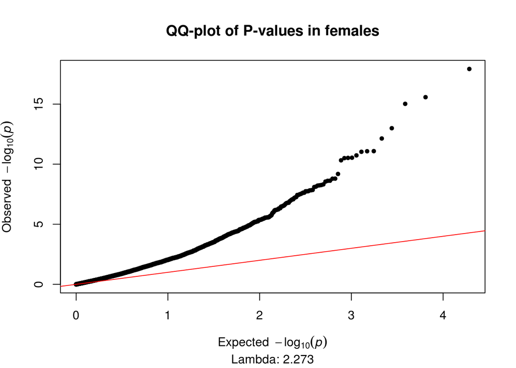

### Model 3 - 3PCs

Three PCs are regressed out, and the ANOVA for diagnosis has been run. Tables of the top 1000 DMPs for diagnosis have been produced and saved separately.

#### Top DMPs

**ANOVA:**  
50 probes pass the epigenome-wide significance threshold of 2.4x10-7 *The top 50 diagnosis associated DMPs:*

| ProbeID | Position | F | p (F) | FDR.Anova | Difference | CI lower | CI upper | pCvM | FDR | Difference | CI lower | CI upper | pCvA | FDR | Difference | CI lower | CI upper | pMvA | FDR | UCSC Gene | UCSC Gene Group | UCSC Relation to CpG Island | Gene Closest TSS | Distance Closest TSS | GREAT Annotation 1 | GREAT Annotation 2 |
| --- | --- | --- | --- | --- | --- | --- | --- | --- | --- | --- | --- | --- | --- | --- | --- | --- | --- | --- | --- | --- | --- | --- | --- | --- | --- | --- |
| cg22822140 | chr X: 153046577 | 55.388 | 3.53e-19 | 3.41e-15 | -0.008 | -0.031 | 0.015 | 0.677 | 1 | -0.093 | -0.116 | -0.070 | 4.86e-14 | 4.69e-10 | -0.085 | -0.107 | -0.062 | 5.42e-14 | 2.43e-10 | SRPK3;SRPK3;SRPK3 | 1stExon;1stExon;1stExon | Island | SRPK3 | 122 | SRPK3 (122) | (NA) |
| cg12230162 | chr X: 153046482 | 45.403 | 1.79e-16 | 8.65e-13 | 0.003 | -0.023 | 0.028 | 0.964 | 1 | -0.087 | -0.113 | -0.062 | 4.77e-13 | 1.53e-09 | -0.09 | -0.115 | -0.065 | 8.95e-14 | 2.43e-10 | SRPK3;SRPK3;SRPK3;SRPK3;SRPK3;SRPK3 | 5'UTR;1stExon;1stExon;5'UTR;5'UTR;1stExon | Island | SRPK3 | 27 | SRPK3 (27) | (NA) |
| cg24496423 | chr X: 153046480 | 44.468 | 3.30e-16 | 1.06e-12 | 0.003 | -0.017 | 0.023 | 0.936 | 1 | -0.067 | -0.087 | -0.047 | 9.82e-13 | 2.37e-09 | -0.07 | -0.09 | -0.051 | 1.01e-13 | 2.43e-10 | SRPK3;SRPK3;SRPK3;SRPK3;SRPK3;SRPK3 | 5'UTR;1stExon;1stExon;5'UTR;5'UTR;1stExon | Island | SRPK3 | 25 | SRPK3 (25) | (NA) |
| cg13009143 | chr X: 100548223 | 36.341 | 7.89e-14 | 1.90e-10 | -0.015 | -0.022 | -0.008 | 1.70e-06 | 4.55e-04 | 0.009 | 0.002 | 0.016 | 0.006 | 0.123 | 0.025 | 0.018 | 0.031 | 9.74e-14 | 2.43e-10 | TAF7L | TSS200 | S_Shore | TAF7L | -164 | TAF7L (-165) | (NA) |
| cg12468189 | chr X: 153046767 | 32.746 | 1.00e-12 | 1.94e-09 | -0.024 | -0.039 | -0.009 | 7.85e-04 | 0.036 | -0.053 | -0.068 | -0.037 | 4.23e-13 | 1.53e-09 | -0.029 | -0.044 | -0.014 | 4.07e-05 | 0.011 | SRPK3;SRPK3;SRPK3 | Body;Body;Body | Island | SRPK3 | 312 | SRPK3 (312) | (NA) |
| cg16529483 | chr X: 153046451 | 30.839 | 4.00e-12 | 6.43e-09 | -0.011 | -0.036 | 0.013 | 0.522 | 1 | -0.077 | -0.102 | -0.052 | 4.63e-11 | 7.44e-08 | -0.066 | -0.091 | -0.041 | 8.71e-09 | 9.33e-06 | SRPK3;SRPK3;SRPK3 | TSS200;TSS200;TSS200 | Island | SRPK3 | -4 | SRPK3 (-4) | (NA) |
| cg19938385 | chr X: 107020894 | 29.586 | 1.00e-11 | 1.38e-08 | -0.048 | -0.066 | -0.030 | 1.04e-08 | 1.11e-05 | -0.055 | -0.074 | -0.037 | 1.32e-10 | 1.82e-07 | -0.007 | -0.025 | 0.011 | 0.636 | 1 |  |  | S_Shore | TSC22D3 | -1692 | TSC22D3 (-1878) | (NA) |
| cg16152676 | chr X: 10126878 | 29.282 | 1.26e-11 | 1.51e-08 | 0.039 | 0.024 | 0.053 | 4.44e-09 | 6.12e-06 | -0.002 | -0.016 | 0.012 | 0.942 | 1 | -0.041 | -0.055 | -0.026 | 6.29e-10 | 8.67e-07 | CLCN4 | 5'UTR | Island | CLCN4 | 550 | CLCN4 (1894) | MID1 (724930) |
| cg19280671 | chr X: 149013642 | 28.864 | 1.71e-11 | 1.84e-08 | 0.017 | 0.011 | 0.023 | 4.48e-10 | 1.17e-06 | 0.002 | -0.004 | 0.008 | 0.802 | 1 | -0.016 | -0.022 | -0.010 | 1.16e-08 | 1.12e-05 | MAGEA8;MAGEA8;MAGEA8 | Body;Body;Body |  | MAGEA8 | 596 | MAMLD1 (-517908) | MAGEA8 (3702) |
| cg09768654 | chr X: 153046386 | 28.004 | 3.25e-11 | 3.14e-08 | 0.009 | -0.014 | 0.032 | 0.642 | 1 | -0.058 | -0.082 | -0.035 | 5.13e-08 | 3.09e-05 | -0.067 | -0.09 | -0.044 | 2.56e-10 | 4.12e-07 | SRPK3;SRPK3;SRPK3 | TSS200;TSS200;TSS200 | Island | SRPK3 | -69 | SRPK3 (-69) | (NA) |
| cg17405188 | chr X: 73164102 | 27.802 | 3.78e-11 | 3.32e-08 | 0.009 | 0.004 | 0.015 | 2.85e-04 | 0.018 | 0.017 | 0.012 | 0.023 | 1.40e-11 | 2.71e-08 | 0.008 | 0.003 | 0.014 | 0.001 | 0.112 | LOC554203 | TSS200 | Island | JPX | -56 | ZCCHC13 (-359922) | CHIC1 (381119) |
| cg24605338 | chr X: 17395856 | 27.457 | 4.90e-11 | 3.94e-08 | -0.035 | -0.047 | -0.024 | 1.81e-11 | 1.74e-07 | -0.019 | -0.030 | -0.007 | 3.98e-04 | 0.024 | 0.016 | 0.005 | 0.028 | 0.002 | 0.144 | NHS | Body | S_Shore | NHS | 2314 | SCML1 (-359735) | NHS (2314) |
| cg03360001 | chr X: 53453272 | 27.094 | 6.44e-11 | 4.78e-08 | -0.009 | -0.015 | -0.003 | 0.003 | 0.084 | 0.010 | 0.004 | 0.016 | 3.97e-04 | 0.024 | 0.019 | 0.013 | 0.025 | 2.42e-11 | 4.67e-08 | RIBC1;RIBC1 | Body;Body | S_Shelf | RIBC1 | 3434 | SMC1A (-3655) | (NA) |
| cg17003204 | chr X: 102861456 | 24.936 | 3.34e-10 | 2.30e-07 | -0.036 | -0.049 | -0.024 | 3.47e-10 | 1.17e-06 | -0.011 | -0.024 | 0.001 | 0.085 | 0.58 | 0.025 | 0.012 | 0.037 | 1.39e-05 | 0.005 | TCEAL3;TCEAL3 | TSS1500;TSS1500 | N_Shore | TCEAL3 | -1377 | TCEAL3 (-1377) | (NA) |
| cg17513789 | chr X: 73073251 | 23.323 | 1.17e-09 | 7.51e-07 | -0.046 | -0.062 | -0.030 | 4.87e-10 | 1.17e-06 | -0.026 | -0.043 | -0.010 | 4.91e-04 | 0.027 | 0.02 | 0.004 | 0.036 | 0.011 | 0.367 | XIST | TSS1500 |  | XIST | -663 | ZCCHC13 (-450773) | CHIC1 (290268) |
| cg09661041 | chr X: 153141905 | 23.147 | 1.34e-09 | 8.08e-07 | -0.004 | -0.028 | 0.019 | 0.896 | 1 | -0.061 | -0.085 | -0.037 | 2.57e-08 | 1.91e-05 | -0.056 | -0.08 | -0.033 | 1.43e-07 | 9.18e-05 | L1CAM;L1CAM;L1CAM | TSS1500;TSS1500;TSS1500 |  | L1CAM | -506 | L1CAM (-507) | (NA) |
| cg21364342 | chr X: 107226611 | 22.745 | 1.84e-09 | 1.04e-06 | -0.022 | -0.032 | -0.012 | 5.10e-07 | 2.05e-04 | -0.025 | -0.035 | -0.016 | 1.32e-08 | 1.18e-05 | -0.003 | -0.013 | 0.006 | 0.692 | 1 | TEX13B | TSS1500 |  | TEX13B | -1011 | VSIG1 (-61588) | MID2 (157528) |
| cg16122592 | chr X: 26210712 | 22.468 | 2.28e-09 | 1.22e-06 | -0.030 | -0.042 | -0.019 | 7.03e-09 | 8.47e-06 | -0.025 | -0.037 | -0.014 | 2.09e-06 | 5.59e-04 | 0.005 | -0.006 | 0.017 | 0.518 | 1 | MAGEB6 | 5'UTR |  | MAGEB6 | 156 | MAGEB6 (156) | (NA) |
| cg21252909 | chr X: 30326328 | 21.735 | 4.08e-09 | 2.07e-06 | 0.036 | 0.013 | 0.059 | 8.24e-04 | 0.037 | -0.028 | -0.051 | -0.004 | 0.016 | 0.228 | -0.064 | -0.087 | -0.041 | 1.88e-09 | 2.27e-06 | NR0B1 | 1stExon | N_Shore | NR0B1 | 1167 | NR0B1 (1166) | (NA) |
| cg15907464 | chr X: 70712790 | 21.354 | 5.52e-09 | 2.65e-06 | -0.034 | -0.047 | -0.022 | 2.53e-09 | 4.88e-06 | -0.020 | -0.033 | -0.008 | 5.45e-04 | 0.029 | 0.014 | 0.001 | 0.026 | 0.024 | 0.53 | BCYRN1;INGX | Body;TSS200 | Island | INGX | -186 | OGT (-40121) | TAF1 (126677) |
| cg04768884 | chr X: 19443172 | 21.283 | 5.84e-09 | 2.65e-06 | 0.008 | -0.006 | 0.022 | 0.346 | 1 | 0.037 | 0.023 | 0.051 | 1.34e-08 | 1.18e-05 | 0.029 | 0.015 | 0.043 | 6.73e-06 | 0.003 | MAP3K15 | Body |  | MAP3K15 | 35099 | PDHA1 (81162) | MAP3K15 (90206) |
| cg00123001 | chr X: 13395880 | 21.239 | 6.05e-09 | 2.65e-06 | -0.019 | -0.027 | -0.011 | 2.66e-07 | 1.17e-04 | -0.020 | -0.028 | -0.012 | 1.35e-07 | 7.25e-05 | -7.22e-04 | -0.009 | 0.007 | 0.975 | 1 |  |  | N_Shore | LOC100133123 | 42521 | EGFL6 (-191813) | ATXN3L (-57363) |
| cg11179997 | chr X: 119125670 | 21.122 | 6.64e-09 | 2.79e-06 | 0.028 | 0.016 | 0.039 | 1.08e-07 | 6.51e-05 | 0.002 | -0.010 | 0.013 | 0.918 | 1 | -0.026 | -0.037 | -0.015 | 6.65e-07 | 3.38e-04 |  |  | Island | AK123976 | -44530 | NKAP (-47936) | RHOXF2 (86036) |
| cg06068202 | chr X: 150343148 | 21.059 | 6.98e-09 | 2.79e-06 | 0.041 | 0.022 | 0.060 | 2.27e-06 | 5.41e-04 | 0.049 | 0.030 | 0.068 | 3.03e-08 | 2.08e-05 | 0.008 | -0.011 | 0.026 | 0.594 | 1 |  |  | Island | GPR50 | -1907 | GPR50 (-1907) | (NA) |
| cg25549901 | chr X: 137951118 | 21.015 | 7.23e-09 | 2.79e-06 | -0.026 | -0.037 | -0.016 | 8.77e-08 | 6.04e-05 | -0.025 | -0.036 | -0.014 | 5.90e-07 | 1.99e-04 | 0.001 | -0.009 | 0.012 | 0.944 | 1 | FGF13;FGF13;FGF13;FGF13 | 5'UTR;Body;TSS1500;Body |  | FGF13 | -1401 | FGF13 (336066) | (NA) |
| cg14917571 | chr X: 79269151 | 20.927 | 7.76e-09 | 2.88e-06 | -0.051 | -0.07 | -0.032 | 3.24e-09 | 5.22e-06 | -0.028 | -0.047 | -0.010 | 0.001 | 0.054 | 0.023 | 0.004 | 0.041 | 0.013 | 0.385 | TBX22;TBX22 | TSS1500;TSS1500 |  | TBX22 | -1103 | ITM2A (-646103) | TBX22 (-8590) |
| cg17219209 | chr X: 149009840 | 20.659 | 9.62e-09 | 3.44e-06 | 0.021 | 0.013 | 0.029 | 2.65e-08 | 2.13e-05 | 0.004 | -0.004 | 0.013 | 0.426 | 1 | -0.017 | -0.025 | -0.008 | 9.74e-06 | 0.004 | MAGEA8;MAGEA8;MAGEA8 | TSS200;TSS200;TSS200 |  | MAGEA8 | -100 | MAGEA8 (-100) | (NA) |
| cg07344627 | chr X: 125687011 | 20.380 | 1.20e-08 | 4.01e-06 | -0.034 | -0.058 | -0.011 | 0.002 | 0.068 | -0.064 | -0.088 | -0.041 | 5.01e-09 | 6.04e-06 | -0.03 | -0.053 | -0.007 | 0.008 | 0.319 | DCAF12L1 | TSS200 | S_Shore | DCAF12L1 | -169 | DCAF12L1 (-170) | (NA) |
| cg25896901 | chr X: 125300481 | 20.360 | 1.22e-08 | 4.01e-06 | 0.010 | -0.016 | 0.035 | 0.637 | 1 | -0.054 | -0.080 | -0.029 | 4.98e-06 | 0.001 | -0.064 | -0.09 | -0.039 | 4.27e-08 | 3.43e-05 | DCAF12L2 | TSS1500 | S_Shore | DCAF12L2 | -401 | DCAF12L1 (386360) | (NA) |
| cg23914849 | chr X: 52950051 | 20.337 | 1.25e-08 | 4.01e-06 | 0.004 | 0.001 | 0.006 | 4.94e-04 | 0.026 | 0.006 | 0.004 | 0.008 | 6.25e-09 | 6.70e-06 | 0.002 | 2.06e-04 | 0.005 | 0.029 | 0.585 |  |  | Island | FAM156A | 13799 | FAM156B (21967) | FAM156A (74599) |
| cg06452970 | chr X: 13835264 | 19.793 | 1.93e-08 | 6.01e-06 | 0.048 | 0.029 | 0.067 | 4.66e-08 | 3.46e-05 | 0.010 | -0.009 | 0.030 | 0.413 | 1 | -0.037 | -0.056 | -0.019 | 1.76e-05 | 0.006 | GPM6B;GPM6B;GPM6B;GPM6B;GPM6B;GPM6B;GPM6B | 1stExon;5'UTR;5'UTR;Body;5'UTR;1stExon;1stExon |  | GPM6B | 50 | GPM6B (49) | (NA) |
| cg09953945 | chr X: 150345040 | 19.612 | 2.24e-08 | 6.74e-06 | -0.029 | -0.04 | -0.018 | 1.22e-08 | 1.18e-05 | -0.019 | -0.030 | -0.007 | 4.44e-04 | 0.026 | 0.011 | -3.35e-04 | 0.022 | 0.059 | 0.826 | GPR50 | TSS200 | N_Shore | GPR50 | -15 | GPR50 (-15) | (NA) |
| cg26101161 | chr X: 122736584 | 19.466 | 2.52e-08 | 7.36e-06 | -0.021 | -0.03 | -0.011 | 3.70e-06 | 7.73e-04 | -0.024 | -0.033 | -0.014 | 1.29e-07 | 7.25e-05 | -0.003 | -0.013 | 0.006 | 0.712 | 1 | THOC2 | 3'UTR |  | THOC2 | 8230 | THOC2 (130319) | GRIA3 (418489) |
| cg09513996 | chr X: 48685182 | 19.324 | 2.83e-08 | 8.02e-06 | 0.007 | -0.007 | 0.021 | 0.481 | 1 | -0.028 | -0.042 | -0.014 | 1.91e-05 | 0.003 | -0.034 | -0.048 | -0.021 | 5.80e-08 | 4.31e-05 |  |  | Island | ERAS | -2100 | ERAS (-2100) | (NA) |
| cg00805156 | chr X: 3264341 | 19.262 | 2.97e-08 | 8.08e-06 | 0.036 | 0.019 | 0.053 | 2.41e-06 | 5.41e-04 | 0.040 | 0.023 | 0.057 | 2.27e-07 | 1.04e-04 | 0.004 | -0.013 | 0.021 | 0.834 | 1 | MXRA5 | 5'UTR | Island | MXRA5 | 343 | MXRA5 (342) | (NA) |
| cg08630881 | chr X: 70713213 | 19.244 | 3.01e-08 | 8.08e-06 | -0.028 | -0.039 | -0.017 | 1.70e-08 | 1.49e-05 | -0.018 | -0.029 | -0.007 | 4.48e-04 | 0.026 | 0.01 | -6.15e-04 | 0.021 | 0.069 | 0.876 | BCYRN1;INGX | Body;TSS1500 | S_Shore | INGX | -609 | OGT (-39698) | TAF1 (127100) |
| cg22574818 | chr X: 55479616 | 18.938 | 3.87e-08 | 1.01e-05 | -0.033 | -0.056 | -0.011 | 0.002 | 0.068 | -0.060 | -0.083 | -0.037 | 1.72e-08 | 1.38e-05 | -0.027 | -0.05 | -0.004 | 0.017 | 0.445 | MAGEH1;MAGEH1 | 1stExon;3'UTR |  | MAGEH1 | 1079 | MAGEH1 (1079) | USP51 (36014) |
| cg00632130 | chr X: 47931806 | 18.713 | 4.65e-08 | 1.18e-05 | -0.011 | -0.025 | 0.002 | 0.111 | 0.643 | 0.022 | 0.009 | 0.036 | 3.60e-04 | 0.022 | 0.034 | 0.02 | 0.047 | 3.06e-08 | 2.69e-05 | ZNF630 | TSS1500 | S_Shore | ZNF630 | -781 | ZNF630 (-1299) | (NA) |
| cg26484667 | chr X: 2733164 | 18.621 | 5.01e-08 | 1.24e-05 | -0.029 | -0.041 | -0.017 | 1.01e-07 | 6.51e-05 | -0.007 | -0.019 | 0.005 | 0.395 | 1 | 0.023 | 0.011 | 0.034 | 3.91e-05 | 0.01 | XG;XG;XG | 3'UTR;3'UTR;3'UTR |  | GYG2 | -13698 | GYG2 (-13698) | XG (63072) |
| cg04710661 | chr X: 2848381 | 18.313 | 6.44e-08 | 1.55e-05 | 0.007 | 3.46e-04 | 0.014 | 0.037 | 0.379 | 0.018 | 0.011 | 0.024 | 3.33e-08 | 2.14e-05 | 0.01 | 0.004 | 0.017 | 0.001 | 0.1 | ARSD;ARSD | TSS1500;TSS1500 | S_Shore | ARSD | -965 | ARSD (-966) | (NA) |
| cg01737010 | chr X: 101772014 | 18.136 | 7.46e-08 | 1.75e-05 | 0.007 | -0.003 | 0.016 | 0.247 | 0.937 | -0.018 | -0.027 | -0.008 | 1.43e-04 | 0.011 | -0.024 | -0.034 | -0.014 | 7.39e-08 | 5.10e-05 | TMSB15A | TSS1500 | S_Shore | TMSB15A | -315 | TMSB15A (-316) | (NA) |
| cg00072799 | chr X: 78427682 | 18.001 | 8.33e-08 | 1.91e-05 | -0.007 | -0.021 | 0.007 | 0.441 | 1 | -0.034 | -0.048 | -0.020 | 1.80e-07 | 9.15e-05 | -0.027 | -0.041 | -0.013 | 3.11e-05 | 0.009 | GPR174;GPR174 | 1stExon;3'UTR |  | GPR174 | 1214 | GPR174 (1214) | ITM2A (195366) |
| cg22926378 | chr X: 6144633 | 17.808 | 9.76e-08 | 2.19e-05 | 0.014 | 0.007 | 0.021 | 2.11e-05 | 0.003 | -0.003 | -0.010 | 0.005 | 0.666 | 1 | -0.016 | -0.023 | -0.009 | 3.56e-07 | 2.15e-04 | NLGN4X;NLGN4X | 5'UTR;5'UTR | Island | NLGN4X | 483 | NLGN4X (2072) | (NA) |
| cg08464958 | chr X: 2852845 | 17.750 | 1.02e-07 | 2.24e-05 | -0.022 | -0.032 | -0.013 | 3.22e-07 | 1.35e-04 | -0.004 | -0.014 | 0.006 | 0.587 | 1 | 0.018 | 0.009 | 0.028 | 2.71e-05 | 0.009 | ARSE | 3'UTR |  | ARSD | -5429 | ARSD (-5430) | ARSE (29648) |
| cg11315455 | chr X: 122997585 | 17.700 | 1.07e-07 | 2.26e-05 | -0.029 | -0.041 | -0.017 | 1.98e-07 | 9.53e-05 | -0.007 | -0.019 | 0.005 | 0.397 | 1 | 0.022 | 0.01 | 0.034 | 6.77e-05 | 0.015 | XIAP | 5'UTR | S_Shelf | XIAP | 3569 | STAG2 (-96889) | XIAP (3569) |
| cg02329520 | chr X: 153740317 | 17.686 | 1.08e-07 | 2.26e-05 | -0.014 | -0.022 | -0.007 | 4.27e-05 | 0.005 | -0.018 | -0.026 | -0.011 | 1.97e-07 | 9.48e-05 | -0.004 | -0.012 | 0.004 | 0.417 | 1 | FAM3A;FAM3A;FAM3A;FAM3A;FAM3A | Body;Body;Body;Body;Body | N_Shelf | FAM3A | 4249 | SLC10A3 (-21316) | FAM3A (4248) |
| cg25177692 | chr X: 129193893 | 17.627 | 1.13e-07 | 2.33e-05 | -0.027 | -0.038 | -0.016 | 1.71e-07 | 9.18e-05 | -0.021 | -0.032 | -0.010 | 6.22e-05 | 0.006 | 0.006 | -0.005 | 0.017 | 0.422 | 1 |  |  | N_Shore | BCORL1 | 34929 | ELF4 (50794) | BCORL1 (54730) |
| cg26747413 | chr X: 15807140 | 17.292 | 1.50e-07 | 3.01e-05 | -0.039 | -0.055 | -0.022 | 5.55e-07 | 2.09e-04 | -0.034 | -0.051 | -0.017 | 1.62e-05 | 0.002 | 0.005 | -0.012 | 0.021 | 0.772 | 1 | INE2;ZRSR2 | TSS1500;TSS1500 | N_Shore | INE2 | -1428 | ZRSR2 (-1433) | (NA) |
| cg07892139 | chr X: 84192519 | 17.121 | 1.72e-07 | 3.39e-05 | -0.045 | -0.066 | -0.025 | 1.27e-06 | 3.61e-04 | -0.043 | -0.063 | -0.022 | 7.18e-06 | 0.001 | 0.003 | -0.018 | 0.023 | 0.945 | 1 |  |  | S_Shelf | UBE2DNL | 3363 | APOOL (-66378) | UBE2DNL (3363) |
| cg05889382 | chr X: 70887722 | 17.086 | 1.77e-07 | 3.42e-05 | -0.020 | -0.029 | -0.011 | 1.65e-06 | 4.54e-04 | -0.019 | -0.029 | -0.010 | 5.58e-06 | 0.001 | 7.90e-04 | -0.008 | 0.010 | 0.977 | 1 | BCYRN1 | Body | Island | LOC100132741 | -29323 | PIN4 (-513803) | CXCR3 (-49356) |

**CTL vs MCI:**  
21 probes pass the epigenome-wide significance threshold of 2.4x10-7

*The top 50 CTL vs MCI associated DMPs:*

| ProbeID | Position | F | p (F) | FDR.Anova | Difference | CI lower | CI upper | pCvM | FDR | Difference | CI lower | CI upper | pCvA | FDR | Difference | CI lower | CI upper | pMvA | FDR | UCSC Gene | UCSC Gene Group | UCSC Relation to CpG Island | Gene Closest TSS | Distance Closest TSS | GREAT Annotation 1 | GREAT Annotation 2 |
| --- | --- | --- | --- | --- | --- | --- | --- | --- | --- | --- | --- | --- | --- | --- | --- | --- | --- | --- | --- | --- | --- | --- | --- | --- | --- | --- |
| cg24605338 | chr X: 17395856 | 27.457 | 4.90e-11 | 3.94e-08 | -0.035 | -0.047 | -0.024 | 1.81e-11 | 1.74e-07 | -0.019 | -0.03 | -0.007 | 3.98e-04 | 0.024 | 0.016 | 0.005 | 0.028 | 0.002 | 0.144 | NHS | Body | S_Shore | NHS | 2314 | SCML1 (-359735) | NHS (2314) |
| cg17003204 | chr X: 102861456 | 24.936 | 3.34e-10 | 2.30e-07 | -0.036 | -0.049 | -0.024 | 3.47e-10 | 1.17e-06 | -0.011 | -0.024 | 0.001 | 0.085 | 0.58 | 0.025 | 0.012 | 0.037 | 1.39e-05 | 0.005 | TCEAL3;TCEAL3 | TSS1500;TSS1500 | N_Shore | TCEAL3 | -1377 | TCEAL3 (-1377) | (NA) |
| cg19280671 | chr X: 149013642 | 28.864 | 1.71e-11 | 1.84e-08 | 0.017 | 0.011 | 0.023 | 4.48e-10 | 1.17e-06 | 0.002 | -0.004 | 0.008 | 0.802 | 1 | -0.016 | -0.022 | -0.01 | 1.16e-08 | 1.12e-05 | MAGEA8;MAGEA8;MAGEA8 | Body;Body;Body |  | MAGEA8 | 596 | MAMLD1 (-517908) | MAGEA8 (3702) |
| cg17513789 | chr X: 73073251 | 23.323 | 1.17e-09 | 7.51e-07 | -0.046 | -0.062 | -0.030 | 4.87e-10 | 1.17e-06 | -0.026 | -0.043 | -0.01 | 4.91e-04 | 0.027 | 0.02 | 0.004 | 0.036 | 0.011 | 0.367 | XIST | TSS1500 |  | XIST | -663 | ZCCHC13 (-450773) | CHIC1 (290268) |
| cg15907464 | chr X: 70712790 | 21.354 | 5.52e-09 | 2.65e-06 | -0.034 | -0.047 | -0.022 | 2.53e-09 | 4.88e-06 | -0.020 | -0.033 | -0.008 | 5.45e-04 | 0.029 | 0.014 | 0.001 | 0.026 | 0.024 | 0.53 | BCYRN1;INGX | Body;TSS200 | Island | INGX | -186 | OGT (-40121) | TAF1 (126677) |
| cg14917571 | chr X: 79269151 | 20.927 | 7.76e-09 | 2.88e-06 | -0.051 | -0.070 | -0.032 | 3.24e-09 | 5.22e-06 | -0.028 | -0.047 | -0.01 | 0.001 | 0.054 | 0.023 | 0.004 | 0.041 | 0.013 | 0.385 | TBX22;TBX22 | TSS1500;TSS1500 |  | TBX22 | -1103 | ITM2A (-646103) | TBX22 (-8590) |
| cg16152676 | chr X: 10126878 | 29.282 | 1.26e-11 | 1.51e-08 | 0.039 | 0.024 | 0.053 | 4.44e-09 | 6.12e-06 | -0.002 | -0.016 | 0.012 | 0.942 | 1 | -0.041 | -0.055 | -0.026 | 6.29e-10 | 8.67e-07 | CLCN4 | 5'UTR | Island | CLCN4 | 550 | CLCN4 (1894) | MID1 (724930) |
| cg16122592 | chr X: 26210712 | 22.468 | 2.28e-09 | 1.22e-06 | -0.030 | -0.042 | -0.019 | 7.03e-09 | 8.47e-06 | -0.025 | -0.037 | -0.014 | 2.09e-06 | 5.59e-04 | 0.005 | -0.006 | 0.017 | 0.518 | 1 | MAGEB6 | 5'UTR |  | MAGEB6 | 156 | MAGEB6 (156) | (NA) |
| cg19938385 | chr X: 107020894 | 29.586 | 1.00e-11 | 1.38e-08 | -0.048 | -0.066 | -0.030 | 1.04e-08 | 1.11e-05 | -0.055 | -0.074 | -0.037 | 1.32e-10 | 1.82e-07 | -0.007 | -0.025 | 0.011 | 0.636 | 1 |  |  | S_Shore | TSC22D3 | -1692 | TSC22D3 (-1878) | (NA) |
| cg09953945 | chr X: 150345040 | 19.612 | 2.24e-08 | 6.74e-06 | -0.029 | -0.040 | -0.018 | 1.22e-08 | 1.18e-05 | -0.019 | -0.03 | -0.007 | 4.44e-04 | 0.026 | 0.011 | -3.35e-04 | 0.022 | 0.059 | 0.826 | GPR50 | TSS200 | N_Shore | GPR50 | -15 | GPR50 (-15) | (NA) |
| cg08630881 | chr X: 70713213 | 19.244 | 3.01e-08 | 8.08e-06 | -0.028 | -0.039 | -0.017 | 1.70e-08 | 1.49e-05 | -0.018 | -0.029 | -0.007 | 4.48e-04 | 0.026 | 0.01 | -6.15e-04 | 0.021 | 0.069 | 0.876 | BCYRN1;INGX | Body;TSS1500 | S_Shore | INGX | -609 | OGT (-39698) | TAF1 (127100) |
| cg17219209 | chr X: 149009840 | 20.659 | 9.62e-09 | 3.44e-06 | 0.021 | 0.013 | 0.029 | 2.65e-08 | 2.13e-05 | 0.004 | -0.004 | 0.013 | 0.426 | 1 | -0.017 | -0.025 | -0.008 | 9.74e-06 | 0.004 | MAGEA8;MAGEA8;MAGEA8 | TSS200;TSS200;TSS200 |  | MAGEA8 | -100 | MAGEA8 (-100) | (NA) |
| cg06452970 | chr X: 13835264 | 19.793 | 1.93e-08 | 6.01e-06 | 0.048 | 0.029 | 0.067 | 4.66e-08 | 3.46e-05 | 0.010 | -0.009 | 0.03 | 0.413 | 1 | -0.037 | -0.056 | -0.019 | 1.76e-05 | 0.006 | GPM6B;GPM6B;GPM6B;GPM6B;GPM6B;GPM6B;GPM6B | 1stExon;5'UTR;5'UTR;Body;5'UTR;1stExon;1stExon |  | GPM6B | 50 | GPM6B (49) | (NA) |
| cg25549901 | chr X: 137951118 | 21.015 | 7.23e-09 | 2.79e-06 | -0.026 | -0.037 | -0.016 | 8.77e-08 | 6.04e-05 | -0.025 | -0.036 | -0.014 | 5.90e-07 | 1.99e-04 | 0.001 | -0.009 | 0.012 | 0.944 | 1 | FGF13;FGF13;FGF13;FGF13 | 5'UTR;Body;TSS1500;Body |  | FGF13 | -1401 | FGF13 (336066) | (NA) |
| cg26484667 | chr X: 2733164 | 18.621 | 5.01e-08 | 1.24e-05 | -0.029 | -0.041 | -0.017 | 1.01e-07 | 6.51e-05 | -0.007 | -0.019 | 0.005 | 0.395 | 1 | 0.023 | 0.011 | 0.034 | 3.91e-05 | 0.01 | XG;XG;XG | 3'UTR;3'UTR;3'UTR |  | GYG2 | -13698 | GYG2 (-13698) | XG (63072) |
| cg11179997 | chr X: 119125670 | 21.122 | 6.64e-09 | 2.79e-06 | 0.028 | 0.016 | 0.039 | 1.08e-07 | 6.51e-05 | 0.002 | -0.01 | 0.013 | 0.918 | 1 | -0.026 | -0.037 | -0.015 | 6.65e-07 | 3.38e-04 |  |  | Island | AK123976 | -44530 | NKAP (-47936) | RHOXF2 (86036) |
| cg04817724 | chr X: 103809991 | 16.605 | 2.65e-07 | 5.01e-05 | 0.049 | 0.029 | 0.069 | 1.30e-07 | 7.37e-05 | 0.029 | 0.009 | 0.049 | 0.003 | 0.079 | -0.02 | -0.04 | 1.66e-04 | 0.052 | 0.779 | IL1RAPL2 | TSS1500 | Island | IL1RAPL2 | -1004 | IL1RAPL2 (-1004) | (NA) |
| cg25177692 | chr X: 129193893 | 17.627 | 1.13e-07 | 2.33e-05 | -0.027 | -0.038 | -0.016 | 1.71e-07 | 9.18e-05 | -0.021 | -0.032 | -0.01 | 6.22e-05 | 0.006 | 0.006 | -0.005 | 0.017 | 0.422 | 1 |  |  | N_Shore | BCORL1 | 34929 | ELF4 (50794) | BCORL1 (54730) |
| cg24834461 | chr X: 153637645 | 16.388 | 3.17e-07 | 5.67e-05 | 0.017 | 0.010 | 0.024 | 1.81e-07 | 9.20e-05 | 0.011 | 0.004 | 0.018 | 0.001 | 0.054 | -0.006 | -0.013 | 8.39e-04 | 0.097 | 1 | DNASE1L1;DNASE1L1;DNASE1L1;DNASE1L1 | TSS200;5'UTR;5'UTR;5'UTR | N_Shelf | DNASE1L1 | -70 | TAZ (-2231) | (NA) |
| cg11315455 | chr X: 122997585 | 17.700 | 1.07e-07 | 2.26e-05 | -0.029 | -0.041 | -0.017 | 1.98e-07 | 9.53e-05 | -0.007 | -0.019 | 0.005 | 0.397 | 1 | 0.022 | 0.01 | 0.034 | 6.77e-05 | 0.015 | XIAP | 5'UTR | S_Shelf | XIAP | 3569 | STAG2 (-96889) | XIAP (3569) |
| cg08867267 | chr X: 130033963 | 16.342 | 3.30e-07 | 5.78e-05 | -0.024 | -0.034 | -0.014 | 2.08e-07 | 9.55e-05 | -0.016 | -0.026 | -0.006 | 9.77e-04 | 0.045 | 0.008 | -0.002 | 0.018 | 0.129 | 1 | ENOX2;ENOX2 | 5'UTR;5'UTR | N_Shelf | ENOX2 | 3245 | ENOX2 (3244) | RBMX2 (498021) |
| cg00123001 | chr X: 13395880 | 21.239 | 6.05e-09 | 2.65e-06 | -0.019 | -0.027 | -0.011 | 2.66e-07 | 1.17e-04 | -0.020 | -0.028 | -0.012 | 1.35e-07 | 7.25e-05 | -7.22e-04 | -0.009 | 0.007 | 0.975 | 1 |  |  | N_Shore | LOC100133123 | 42521 | EGFL6 (-191813) | ATXN3L (-57363) |
| cg08464958 | chr X: 2852845 | 17.750 | 1.02e-07 | 2.24e-05 | -0.022 | -0.032 | -0.013 | 3.22e-07 | 1.35e-04 | -0.004 | -0.014 | 0.006 | 0.587 | 1 | 0.018 | 0.009 | 0.028 | 2.71e-05 | 0.009 | ARSE | 3'UTR |  | ARSD | -5429 | ARSD (-5430) | ARSE (29648) |
| cg21364342 | chr X: 107226611 | 22.745 | 1.84e-09 | 1.04e-06 | -0.022 | -0.032 | -0.012 | 5.10e-07 | 2.05e-04 | -0.025 | -0.035 | -0.016 | 1.32e-08 | 1.18e-05 | -0.003 | -0.013 | 0.006 | 0.692 | 1 | TEX13B | TSS1500 |  | TEX13B | -1011 | VSIG1 (-61588) | MID2 (157528) |
| cg26747413 | chr X: 15807140 | 17.292 | 1.50e-07 | 3.01e-05 | -0.039 | -0.055 | -0.022 | 5.55e-07 | 2.09e-04 | -0.034 | -0.051 | -0.017 | 1.62e-05 | 0.002 | 0.005 | -0.012 | 0.021 | 0.772 | 1 | INE2;ZRSR2 | TSS1500;TSS1500 | N_Shore | INE2 | -1428 | ZRSR2 (-1433) | (NA) |
| cg25958561 | chr X: 110187179 | 16.310 | 3.39e-07 | 5.83e-05 | 0.032 | 0.018 | 0.046 | 5.62e-07 | 2.09e-04 | 0.026 | 0.011 | 0.04 | 9.35e-05 | 0.009 | -0.007 | -0.02 | 0.007 | 0.509 | 1 | PAK3;PAK3 | TSS1500;TSS1500 |  | PAK3 | -333 | PAK3 (-179125) | CHRDL1 (-148104) |
| cg25396787 | chr X: 3733991 | 14.914 | 1.10e-06 | 1.49e-04 | 0.029 | 0.016 | 0.041 | 6.10e-07 | 2.18e-04 | 0.018 | 0.005 | 0.031 | 0.003 | 0.083 | -0.011 | -0.023 | 0.002 | 0.103 | 1 |  |  | Island | TRNA_Ile | 22500 | PRKX (-102317) | (NA) |
| cg25433595 | chr X: 100183764 | 16.092 | 4.06e-07 | 6.76e-05 | 0.042 | 0.024 | 0.061 | 8.28e-07 | 2.83e-04 | 0.035 | 0.016 | 0.054 | 7.20e-05 | 0.007 | -0.008 | -0.026 | 0.011 | 0.601 | 1 | XKRX;XKRX | 5'UTR;1stExon | N_Shore | XKRX | 134 | XKRX (133) | (NA) |
| cg12461113 | chr X: 13587550 | 14.310 | 1.84e-06 | 2.36e-04 | -0.078 | -0.112 | -0.043 | 8.60e-07 | 2.83e-04 | -0.039 | -0.074 | -0.004 | 0.024 | 0.287 | 0.039 | 0.004 | 0.073 | 0.022 | 0.515 | EGFL6;EGFL6 | TSS200;TSS200 | N_Shore | EGFL6 | -143 | EGFL6 (-143) | (NA) |
| cg05860920 | chr X: 11679501 | 15.419 | 7.16e-07 | 1.06e-04 | 0.060 | 0.033 | 0.086 | 8.80e-07 | 2.83e-04 | 0.046 | 0.019 | 0.072 | 2.50e-04 | 0.017 | -0.014 | -0.04 | 0.012 | 0.414 | 1 | ARHGAP6;ARHGAP6 | Body;Body | N_Shelf | ARHGAP6 | 4320 | ARHGAP6 (4319) | AMELX (367969) |
| cg09979033 | chr X: 16726904 | 15.762 | 5.36e-07 | 8.49e-05 | -0.018 | -0.025 | -0.010 | 9.10e-07 | 2.83e-04 | -0.014 | -0.022 | -0.006 | 1.15e-04 | 0.009 | 0.003 | -0.004 | 0.011 | 0.54 | 1 | CTPS2;CTPS2;CTPS2 | 5'UTR;5'UTR;5'UTR | N_Shelf | CTPS2 | 3436 | CTPS2 (4154) | S100G (58624) |
| cg27558057 | chr X: 70712724 | 14.206 | 2.01e-06 | 2.51e-04 | -0.030 | -0.043 | -0.017 | 9.77e-07 | 2.94e-04 | -0.014 | -0.027 | -5.54e-04 | 0.039 | 0.39 | 0.016 | 0.003 | 0.029 | 0.014 | 0.406 | BCYRN1;INGX | Body;TSS200 | Island | INGX | -120 | OGT (-40187) | TAF1 (126611) |
| cg14306994 | chr X: 49019804 | 13.926 | 2.55e-06 | 3.07e-04 | 0.030 | 0.016 | 0.043 | 1.23e-06 | 3.61e-04 | 0.014 | 6.84e-04 | 0.028 | 0.037 | 0.377 | -0.016 | -0.029 | -0.002 | 0.017 | 0.453 | MAGIX;MAGIX;MAGIX;MAGIX | Body;Body;Body;TSS1500 | Island | MAGIX | -316 | GPKOW (-39726) | PLP2 (-8379) |
| cg07892139 | chr X: 84192519 | 17.121 | 1.72e-07 | 3.39e-05 | -0.045 | -0.066 | -0.025 | 1.27e-06 | 3.61e-04 | -0.043 | -0.063 | -0.022 | 7.18e-06 | 0.001 | 0.003 | -0.018 | 0.023 | 0.945 | 1 |  |  | S_Shelf | UBE2DNL | 3363 | APOOL (-66378) | UBE2DNL (3363) |
| cg05889382 | chr X: 70887722 | 17.086 | 1.77e-07 | 3.42e-05 | -0.020 | -0.029 | -0.011 | 1.65e-06 | 4.54e-04 | -0.019 | -0.029 | -0.01 | 5.58e-06 | 0.001 | 7.90e-04 | -0.008 | 0.01 | 0.977 | 1 | BCYRN1 | Body | Island | LOC100132741 | -29323 | PIN4 (-513803) | CXCR3 (-49356) |
| cg13009143 | chr X: 100548223 | 36.341 | 7.89e-14 | 1.90e-10 | -0.015 | -0.022 | -0.008 | 1.70e-06 | 4.55e-04 | 0.009 | 0.002 | 0.016 | 0.006 | 0.123 | 0.025 | 0.018 | 0.031 | 9.74e-14 | 2.43e-10 | TAF7L | TSS200 | S_Shore | TAF7L | -164 | TAF7L (-165) | (NA) |
| cg26468081 | chr X: 69501565 | 13.780 | 2.89e-06 | 3.20e-04 | -0.014 | -0.021 | -0.008 | 1.86e-06 | 4.86e-04 | -0.005 | -0.012 | 0.001 | 0.133 | 0.721 | 0.009 | 0.002 | 0.015 | 0.004 | 0.222 | ARR3;RAB41 | Body;TSS1500 |  | RAB41 | -456 | RAB41 (-456) | (NA) |
| cg18497064 | chr X: 134715899 | 13.717 | 3.05e-06 | 3.31e-04 | -0.039 | -0.058 | -0.021 | 2.08e-06 | 5.28e-04 | -0.014 | -0.033 | 0.004 | 0.154 | 0.771 | 0.025 | 0.007 | 0.043 | 0.003 | 0.208 | DDX26B | 3'UTR |  | DDX26B | 12638 | ZNF449 (237204) | MMGT1 (340234) |
| ch.X.112118442F | chr X: 112231786 | 13.225 | 4.66e-06 | 4.41e-04 | 0.013 | 0.007 | 0.018 | 2.26e-06 | 5.41e-04 | 0.007 | 9.40e-04 | 0.013 | 0.019 | 0.25 | -0.006 | -0.012 | -2.59e-05 | 0.049 | 0.758 |  |  |  | U6 | 69427 | AMOT (-165415) | (NA) |
| cg06068202 | chr X: 150343148 | 21.059 | 6.98e-09 | 2.79e-06 | 0.041 | 0.022 | 0.060 | 2.27e-06 | 5.41e-04 | 0.049 | 0.03 | 0.068 | 3.03e-08 | 2.08e-05 | 0.008 | -0.011 | 0.026 | 0.594 | 1 |  |  | Island | GPR50 | -1907 | GPR50 (-1907) | (NA) |
| cg07089438 | chr X: 133988190 | 13.406 | 3.99e-06 | 4.01e-04 | -0.025 | -0.036 | -0.013 | 2.35e-06 | 5.41e-04 | -0.016 | -0.027 | -0.004 | 0.004 | 0.108 | 0.009 | -0.002 | 0.02 | 0.146 | 1 | FAM122C;FAM122C | 3'UTR;Body |  | MOSPD1 | 45374 | PLAC1 (-195678) | MOSPD1 (61106) |
| cg25831435 | chr X: 137714452 | 13.995 | 2.40e-06 | 2.94e-04 | -0.030 | -0.044 | -0.016 | 2.38e-06 | 5.41e-04 | -0.022 | -0.036 | -0.008 | 7.50e-04 | 0.038 | 0.008 | -0.006 | 0.022 | 0.368 | 1 | FGF13;FGF13;FGF13;FGF13;FGF13;FGF13 | 3'UTR;3'UTR;3'UTR;3'UTR;3'UTR;3'UTR |  | LOC158696 | -14653 | FGF13 (572732) | (NA) |
| cg00805156 | chr X: 3264341 | 19.262 | 2.97e-08 | 8.08e-06 | 0.036 | 0.019 | 0.053 | 2.41e-06 | 5.41e-04 | 0.040 | 0.023 | 0.057 | 2.27e-07 | 1.04e-04 | 0.004 | -0.013 | 0.021 | 0.834 | 1 | MXRA5 | 5'UTR | Island | MXRA5 | 343 | MXRA5 (342) | (NA) |
| cg06138173 | chr X: 16668923 | 12.922 | 6.05e-06 | 5.31e-04 | -0.030 | -0.044 | -0.016 | 3.05e-06 | 6.68e-04 | -0.017 | -0.031 | -0.003 | 0.014 | 0.212 | 0.013 | -9.09e-04 | 0.027 | 0.072 | 0.897 | CTPS2;S100G;CTPS2;CTPS2 | Body;5'UTR;Body;Body |  | S100G | 643 | S100G (643) | (NA) |
| cg06068891 | chr X: 135228207 | 13.853 | 2.71e-06 | 3.14e-04 | -0.046 | -0.067 | -0.024 | 3.52e-06 | 7.55e-04 | -0.036 | -0.057 | -0.014 | 4.54e-04 | 0.026 | 0.01 | -0.011 | 0.032 | 0.498 | 1 | FHL1;FHL1;FHL1;FHL1 | TSS1500;TSS1500;TSS1500;TSS1500 | N_Shore | FHL1 | -653 | FHL1 (-1351) | (NA) |
| cg26101161 | chr X: 122736584 | 19.466 | 2.52e-08 | 7.36e-06 | -0.021 | -0.030 | -0.011 | 3.70e-06 | 7.73e-04 | -0.024 | -0.033 | -0.014 | 1.29e-07 | 7.25e-05 | -0.003 | -0.013 | 0.006 | 0.712 | 1 | THOC2 | 3'UTR |  | THOC2 | 8230 | THOC2 (130319) | GRIA3 (418489) |
| cg09641151 | chr X: 153693918 | 13.079 | 5.28e-06 | 4.90e-04 | 0.028 | 0.015 | 0.041 | 3.77e-06 | 7.73e-04 | 0.019 | 0.006 | 0.033 | 0.003 | 0.078 | -0.009 | -0.022 | 0.004 | 0.239 | 1 | PLXNA3 | Body | N_Shore | PLXNA3 | 7296 | PLXNA3 (7296) | LAGE3 (13677) |
| cg17970282 | chr X: 70712810 | 12.535 | 8.47e-06 | 6.87e-04 | -0.031 | -0.046 | -0.017 | 4.17e-06 | 8.39e-04 | -0.016 | -0.031 | -7.26e-04 | 0.037 | 0.379 | 0.016 | 8.83e-04 | 0.03 | 0.035 | 0.65 | BCYRN1;INGX | Body;TSS1500 | Island | INGX | -206 | OGT (-40101) | TAF1 (126697) |
| cg11837390 | chr X: 106957165 | 13.272 | 4.47e-06 | 4.32e-04 | -0.021 | -0.031 | -0.011 | 4.32e-06 | 8.43e-04 | -0.015 | -0.025 | -0.005 | 0.001 | 0.048 | 0.006 | -0.004 | 0.015 | 0.38 | 1 | TSC22D3;TSC22D3;TSC22D3 | 3'UTR;3'UTR;3'UTR | N_Shelf | TSC22D3 | 2546 | TSC22D3 (61851) | PRPS1 (85512) |
| cg20881335 | chr X: 14547172 | 12.647 | 7.69e-06 | 6.55e-04 | 0.063 | 0.033 | 0.093 | 4.37e-06 | 8.43e-04 | 0.026 | -0.004 | 0.057 | 0.102 | 0.636 | -0.037 | -0.067 | -0.007 | 0.011 | 0.367 | GLRA2;GLRA2;GLRA2 | TSS1500;TSS1500;TSS1500 |  | GLRA2 | -247 | GLRA2 (-247) | (NA) |

**CTL vs AD:**  
21 probes pass the epigenome-wide significance threshold of 2.4x10-7  
*The top 50 CTL vs AD associated DMPs:*

| ProbeID | Position | F | p (F) | FDR.Anova | Difference | CI lower | CI upper | pCvM | FDR | Difference | CI lower | CI upper | pCvA | FDR | Difference | CI lower | CI upper | pMvA | FDR | UCSC Gene | UCSC Gene Group | UCSC Relation to CpG Island | Gene Closest TSS | Distance Closest TSS | GREAT Annotation 1 | GREAT Annotation 2 |
| --- | --- | --- | --- | --- | --- | --- | --- | --- | --- | --- | --- | --- | --- | --- | --- | --- | --- | --- | --- | --- | --- | --- | --- | --- | --- | --- |
| cg22822140 | chr X: 153046577 | 55.388 | 3.53e-19 | 3.41e-15 | -0.008 | -0.031 | 0.015 | 0.677 | 1 | -0.093 | -0.116 | -0.070 | 4.86e-14 | 4.69e-10 | -0.085 | -0.107 | -0.062 | 5.42e-14 | 2.43e-10 | SRPK3;SRPK3;SRPK3 | 1stExon;1stExon;1stExon | Island | SRPK3 | 122 | SRPK3 (122) | (NA) |
| cg12468189 | chr X: 153046767 | 32.746 | 1.00e-12 | 1.94e-09 | -0.024 | -0.039 | -0.009 | 7.85e-04 | 0.036 | -0.053 | -0.068 | -0.037 | 4.23e-13 | 1.53e-09 | -0.029 | -0.044 | -0.014 | 4.07e-05 | 0.011 | SRPK3;SRPK3;SRPK3 | Body;Body;Body | Island | SRPK3 | 312 | SRPK3 (312) | (NA) |
| cg12230162 | chr X: 153046482 | 45.403 | 1.79e-16 | 8.65e-13 | 0.003 | -0.023 | 0.028 | 0.964 | 1 | -0.087 | -0.113 | -0.062 | 4.77e-13 | 1.53e-09 | -0.09 | -0.115 | -0.065 | 8.95e-14 | 2.43e-10 | SRPK3;SRPK3;SRPK3;SRPK3;SRPK3;SRPK3 | 5'UTR;1stExon;1stExon;5'UTR;5'UTR;1stExon | Island | SRPK3 | 27 | SRPK3 (27) | (NA) |
| cg24496423 | chr X: 153046480 | 44.468 | 3.30e-16 | 1.06e-12 | 0.003 | -0.017 | 0.023 | 0.936 | 1 | -0.067 | -0.087 | -0.047 | 9.82e-13 | 2.37e-09 | -0.07 | -0.09 | -0.051 | 1.01e-13 | 2.43e-10 | SRPK3;SRPK3;SRPK3;SRPK3;SRPK3;SRPK3 | 5'UTR;1stExon;1stExon;5'UTR;5'UTR;1stExon | Island | SRPK3 | 25 | SRPK3 (25) | (NA) |
| cg17405188 | chr X: 73164102 | 27.802 | 3.78e-11 | 3.32e-08 | 0.009 | 0.004 | 0.015 | 2.85e-04 | 0.018 | 0.017 | 0.012 | 0.023 | 1.40e-11 | 2.71e-08 | 0.008 | 0.003 | 0.014 | 0.001 | 0.112 | LOC554203 | TSS200 | Island | JPX | -56 | ZCCHC13 (-359922) | CHIC1 (381119) |
| cg16529483 | chr X: 153046451 | 30.839 | 4.00e-12 | 6.43e-09 | -0.011 | -0.036 | 0.013 | 0.522 | 1 | -0.077 | -0.102 | -0.052 | 4.63e-11 | 7.44e-08 | -0.066 | -0.091 | -0.041 | 8.71e-09 | 9.33e-06 | SRPK3;SRPK3;SRPK3 | TSS200;TSS200;TSS200 | Island | SRPK3 | -4 | SRPK3 (-4) | (NA) |
| cg19938385 | chr X: 107020894 | 29.586 | 1.00e-11 | 1.38e-08 | -0.048 | -0.066 | -0.03 | 1.04e-08 | 1.11e-05 | -0.055 | -0.074 | -0.037 | 1.32e-10 | 1.82e-07 | -0.007 | -0.025 | 0.011 | 0.636 | 1 |  |  | S_Shore | TSC22D3 | -1692 | TSC22D3 (-1878) | (NA) |
| cg07344627 | chr X: 125687011 | 20.380 | 1.20e-08 | 4.01e-06 | -0.034 | -0.058 | -0.011 | 0.002 | 0.068 | -0.064 | -0.088 | -0.041 | 5.01e-09 | 6.04e-06 | -0.03 | -0.053 | -0.007 | 0.008 | 0.319 | DCAF12L1 | TSS200 | S_Shore | DCAF12L1 | -169 | DCAF12L1 (-170) | (NA) |
| cg23914849 | chr X: 52950051 | 20.337 | 1.25e-08 | 4.01e-06 | 0.004 | 0.001 | 0.006 | 4.94e-04 | 0.026 | 0.006 | 0.004 | 0.008 | 6.25e-09 | 6.70e-06 | 0.002 | 2.06e-04 | 0.005 | 0.029 | 0.585 |  |  | Island | FAM156A | 13799 | FAM156B (21967) | FAM156A (74599) |
| cg21364342 | chr X: 107226611 | 22.745 | 1.84e-09 | 1.04e-06 | -0.022 | -0.032 | -0.012 | 5.10e-07 | 2.05e-04 | -0.025 | -0.035 | -0.016 | 1.32e-08 | 1.18e-05 | -0.003 | -0.013 | 0.006 | 0.692 | 1 | TEX13B | TSS1500 |  | TEX13B | -1011 | VSIG1 (-61588) | MID2 (157528) |
| cg04768884 | chr X: 19443172 | 21.283 | 5.84e-09 | 2.65e-06 | 0.008 | -0.006 | 0.022 | 0.346 | 1 | 0.037 | 0.023 | 0.051 | 1.34e-08 | 1.18e-05 | 0.029 | 0.015 | 0.043 | 6.73e-06 | 0.003 | MAP3K15 | Body |  | MAP3K15 | 35099 | PDHA1 (81162) | MAP3K15 (90206) |
| cg22574818 | chr X: 55479616 | 18.938 | 3.87e-08 | 1.01e-05 | -0.033 | -0.056 | -0.011 | 0.002 | 0.068 | -0.060 | -0.083 | -0.037 | 1.72e-08 | 1.38e-05 | -0.027 | -0.05 | -0.004 | 0.017 | 0.445 | MAGEH1;MAGEH1 | 1stExon;3'UTR |  | MAGEH1 | 1079 | MAGEH1 (1079) | USP51 (36014) |
| cg09661041 | chr X: 153141905 | 23.147 | 1.34e-09 | 8.08e-07 | -0.004 | -0.028 | 0.019 | 0.896 | 1 | -0.061 | -0.085 | -0.037 | 2.57e-08 | 1.91e-05 | -0.056 | -0.08 | -0.033 | 1.43e-07 | 9.18e-05 | L1CAM;L1CAM;L1CAM | TSS1500;TSS1500;TSS1500 |  | L1CAM | -506 | L1CAM (-507) | (NA) |
| cg06068202 | chr X: 150343148 | 21.059 | 6.98e-09 | 2.79e-06 | 0.041 | 0.022 | 0.06 | 2.27e-06 | 5.41e-04 | 0.049 | 0.030 | 0.068 | 3.03e-08 | 2.08e-05 | 0.008 | -0.011 | 0.026 | 0.594 | 1 |  |  | Island | GPR50 | -1907 | GPR50 (-1907) | (NA) |
| cg04710661 | chr X: 2848381 | 18.313 | 6.44e-08 | 1.55e-05 | 0.007 | 3.46e-04 | 0.014 | 0.037 | 0.379 | 0.018 | 0.011 | 0.024 | 3.33e-08 | 2.14e-05 | 0.01 | 0.004 | 0.017 | 0.001 | 0.1 | ARSD;ARSD | TSS1500;TSS1500 | S_Shore | ARSD | -965 | ARSD (-966) | (NA) |
| cg09768654 | chr X: 153046386 | 28.004 | 3.25e-11 | 3.14e-08 | 0.009 | -0.014 | 0.032 | 0.642 | 1 | -0.058 | -0.082 | -0.035 | 5.13e-08 | 3.09e-05 | -0.067 | -0.09 | -0.044 | 2.56e-10 | 4.12e-07 | SRPK3;SRPK3;SRPK3 | TSS200;TSS200;TSS200 | Island | SRPK3 | -69 | SRPK3 (-69) | (NA) |
| cg26101161 | chr X: 122736584 | 19.466 | 2.52e-08 | 7.36e-06 | -0.021 | -0.03 | -0.011 | 3.70e-06 | 7.73e-04 | -0.024 | -0.033 | -0.014 | 1.29e-07 | 7.25e-05 | -0.003 | -0.013 | 0.006 | 0.712 | 1 | THOC2 | 3'UTR |  | THOC2 | 8230 | THOC2 (130319) | GRIA3 (418489) |
| cg00123001 | chr X: 13395880 | 21.239 | 6.05e-09 | 2.65e-06 | -0.019 | -0.027 | -0.011 | 2.66e-07 | 1.17e-04 | -0.020 | -0.028 | -0.012 | 1.35e-07 | 7.25e-05 | -7.22e-04 | -0.009 | 0.007 | 0.975 | 1 |  |  | N_Shore | LOC100133123 | 42521 | EGFL6 (-191813) | ATXN3L (-57363) |
| cg00072799 | chr X: 78427682 | 18.001 | 8.33e-08 | 1.91e-05 | -0.007 | -0.021 | 0.007 | 0.441 | 1 | -0.034 | -0.048 | -0.020 | 1.80e-07 | 9.15e-05 | -0.027 | -0.041 | -0.013 | 3.11e-05 | 0.009 | GPR174;GPR174 | 1stExon;3'UTR |  | GPR174 | 1214 | GPR174 (1214) | ITM2A (195366) |
| cg02329520 | chr X: 153740317 | 17.686 | 1.08e-07 | 2.26e-05 | -0.014 | -0.022 | -0.007 | 4.27e-05 | 0.005 | -0.018 | -0.026 | -0.011 | 1.97e-07 | 9.48e-05 | -0.004 | -0.012 | 0.004 | 0.417 | 1 | FAM3A;FAM3A;FAM3A;FAM3A;FAM3A | Body;Body;Body;Body;Body | N_Shelf | FAM3A | 4249 | SLC10A3 (-21316) | FAM3A (4248) |
| cg00805156 | chr X: 3264341 | 19.262 | 2.97e-08 | 8.08e-06 | 0.036 | 0.019 | 0.053 | 2.41e-06 | 5.41e-04 | 0.040 | 0.023 | 0.057 | 2.27e-07 | 1.04e-04 | 0.004 | -0.013 | 0.021 | 0.834 | 1 | MXRA5 | 5'UTR | Island | MXRA5 | 343 | MXRA5 (342) | (NA) |
| cg00928753 | chr X: 36976515 | 15.602 | 6.14e-07 | 9.40e-05 | 0.021 | 5.03e-05 | 0.042 | 0.049 | 0.442 | 0.050 | 0.029 | 0.071 | 3.15e-07 | 1.38e-04 | 0.029 | 0.008 | 0.05 | 0.004 | 0.209 |  |  | S_Shore | FAM47C | -49916 | PRRG1 (-232012) | CXorf59 (911463) |
| cg01975035 | chr X: 24761808 | 15.381 | 7.39e-07 | 1.08e-04 | -0.012 | -0.023 | -0.002 | 0.017 | 0.247 | -0.025 | -0.036 | -0.014 | 3.36e-07 | 1.41e-04 | -0.013 | -0.023 | -0.002 | 0.013 | 0.393 | SCARNA23;POLA1 | TSS1500;Body |  | SCARNA23 | -749 | POLA1 (49745) | ARX (272256) |
| cg20814574 | chr X: 92928640 | 15.580 | 6.25e-07 | 9.43e-05 | 0.005 | -4.44e-04 | 0.011 | 0.079 | 0.556 | 0.013 | 0.007 | 0.019 | 3.63e-07 | 1.46e-04 | 0.008 | 0.002 | 0.013 | 0.002 | 0.152 | FAM133A;FAM133A;NAP1L3;FAM133A;FAM133A | TSS1500;TSS1500;TSS200;TSS1500;TSS1500 | Island | NAP1L3 | 42 | NAP1L3 (41) | (NA) |
| cg12039689 | chr X: 153141750 | 15.907 | 4.75e-07 | 7.77e-05 | -0.017 | -0.038 | 0.005 | 0.162 | 0.778 | -0.051 | -0.073 | -0.029 | 3.78e-07 | 1.46e-04 | -0.034 | -0.056 | -0.013 | 6.41e-04 | 0.067 | L1CAM;L1CAM;L1CAM | TSS1500;TSS1500;TSS1500 |  | L1CAM | -351 | L1CAM (-352) | (NA) |
| ch.X.1639000R | chr X: 113225430 | 15.144 | 9.04e-07 | 1.28e-04 | 0.010 | 0.003 | 0.017 | 0.003 | 0.097 | 0.016 | 0.009 | 0.024 | 4.78e-07 | 1.77e-04 | 0.007 | -3.13e-04 | 0.014 | 0.065 | 0.856 |  |  |  | HTR2C | -593120 | HTR2C (-593120) | (NA) |
| cg08850124 | chr X: 118207749 | 16.388 | 3.17e-07 | 5.67e-05 | -0.013 | -0.02 | -0.006 | 8.34e-05 | 0.007 | -0.016 | -0.023 | -0.009 | 5.50e-07 | 1.97e-04 | -0.004 | -0.01 | 0.003 | 0.448 | 1 |  |  | Island | KIAA1210 | 76793 | PGRMC1 (-162461) | LONRF3 (99037) |
| cg25549901 | chr X: 137951118 | 21.015 | 7.23e-09 | 2.79e-06 | -0.026 | -0.037 | -0.016 | 8.77e-08 | 6.04e-05 | -0.025 | -0.036 | -0.014 | 5.90e-07 | 1.99e-04 | 0.001 | -0.009 | 0.012 | 0.944 | 1 | FGF13;FGF13;FGF13;FGF13 | 5'UTR;Body;TSS1500;Body |  | FGF13 | -1401 | FGF13 (336066) | (NA) |
| cg16170760 | chr X: 153708103 | 14.942 | 1.07e-06 | 1.49e-04 | -0.008 | -0.016 | 5.86e-04 | 0.075 | 0.54 | -0.019 | -0.027 | -0.011 | 5.99e-07 | 1.99e-04 | -0.011 | -0.02 | -0.003 | 0.003 | 0.197 | LAGE3 | TSS1500 | S_Shore | LAGE3 | -507 | LAGE3 (-508) | (NA) |
| cg06616051 | chr X: 153094332 | 14.359 | 1.76e-06 | 2.30e-04 | 0.018 | 2.20e-05 | 0.036 | 0.05 | 0.443 | 0.041 | 0.023 | 0.059 | 8.87e-07 | 2.85e-04 | 0.023 | 0.005 | 0.041 | 0.007 | 0.302 | PDZD4 | Body | Island | PDZD4 | 1019 | IDH3G (-34366) | PDZD4 (1670) |
| cg00779763 | chr X: 47479114 | 14.930 | 1.08e-06 | 1.49e-04 | 0.007 | -0.003 | 0.018 | 0.225 | 0.905 | 0.024 | 0.013 | 0.035 | 9.73e-07 | 3.03e-04 | 0.017 | 0.006 | 0.027 | 7.04e-04 | 0.071 | SYN1;SYN1 | 1stExon;1stExon | Island | SYN1 | 142 | SYN1 (141) | (NA) |
| cg14403309 | chr X: 37213086 | 13.875 | 2.66e-06 | 3.14e-04 | -0.017 | -0.03 | -0.003 | 0.012 | 0.2 | -0.031 | -0.044 | -0.017 | 1.29e-06 | 3.89e-04 | -0.014 | -0.027 | -4.25e-04 | 0.042 | 0.692 | PRRG1;PRRG1 | 5'UTR;5'UTR | S_Shelf | PRRG1 | 4504 | LANCL3 (-217735) | PRRG1 (4559) |
| cg24352688 | chr X: 13751727 | 16.102 | 4.03e-07 | 6.76e-05 | 0.002 | -0.005 | 0.009 | 0.717 | 1 | 0.016 | 0.009 | 0.023 | 1.50e-06 | 4.39e-04 | 0.013 | 0.006 | 0.02 | 3.19e-05 | 0.009 | TRAPPC2;OFD1;TRAPPC2;TRAPPC2 | 5'UTR;TSS1500;5'UTR;5'UTR | N_Shore | TRAPPC2 | 1027 | OFD1 (-1104) | TRAPPC2 (1026) |
| cg02048654 | chr X: 132551786 | 13.686 | 3.13e-06 | 3.36e-04 | 0.028 | 1.43e-04 | 0.055 | 0.049 | 0.441 | 0.062 | 0.034 | 0.090 | 1.56e-06 | 4.44e-04 | 0.034 | 0.006 | 0.061 | 0.011 | 0.368 |  |  | S_Shore | GPC4 | -2581 | GPC4 (-2582) | (NA) |
| cg21179255 | chr X: 152772707 | 13.528 | 3.59e-06 | 3.80e-04 | -0.014 | -0.026 | -0.002 | 0.017 | 0.242 | -0.026 | -0.038 | -0.014 | 1.73e-06 | 4.76e-04 | -0.012 | -0.024 | -6.68e-04 | 0.036 | 0.657 | BGN | Body |  | HAUS7 | -11729 | ATP2B3 (-28872) | BGN (12361) |
| cg16122592 | chr X: 26210712 | 22.468 | 2.28e-09 | 1.22e-06 | -0.030 | -0.042 | -0.019 | 7.03e-09 | 8.47e-06 | -0.025 | -0.037 | -0.014 | 2.09e-06 | 5.59e-04 | 0.005 | -0.006 | 0.017 | 0.518 | 1 | MAGEB6 | 5'UTR |  | MAGEB6 | 156 | MAGEB6 (156) | (NA) |
| cg02754763 | chr X: 44403388 | 15.724 | 5.54e-07 | 8.62e-05 | -0.002 | -0.009 | 0.005 | 0.771 | 1 | -0.016 | -0.023 | -0.009 | 2.32e-06 | 6.05e-04 | -0.014 | -0.021 | -0.007 | 3.25e-05 | 0.009 | FUNDC1 | TSS1500 |  | FUNDC1 | -1167 | DUSP21 (-299860) | EFHC2 (-200466) |
| cg20784188 | chr X: 44703983 | 15.205 | 8.58e-07 | 1.24e-04 | -0.003 | -0.014 | 0.007 | 0.722 | 1 | -0.023 | -0.033 | -0.012 | 2.89e-06 | 7.24e-04 | -0.019 | -0.029 | -0.009 | 5.63e-05 | 0.014 | DUSP21;DUSP21 | 3'UTR;1stExon | S_Shore | DUSP21 | 735 | DUSP21 (735) | (NA) |
| cg13492609 | chr X: 151308320 | 12.960 | 5.86e-06 | 5.19e-04 | -0.010 | -0.019 | -3.70e-05 | 0.049 | 0.441 | -0.021 | -0.031 | -0.011 | 2.93e-06 | 7.24e-04 | -0.011 | -0.021 | -0.002 | 0.016 | 0.436 | MAGEA10;MAGEA10 | TSS1500;TSS1500 |  | MAGEA10 | -1270 | MAGEA5 (-21910) | GABRA3 (311510) |
| cg27250462 | chr X: 119250508 | 12.881 | 6.27e-06 | 5.45e-04 | -0.009 | -0.018 | -5.49e-04 | 0.034 | 0.364 | -0.018 | -0.027 | -0.010 | 3.06e-06 | 7.38e-04 | -0.009 | -0.018 | -9.63e-04 | 0.025 | 0.541 | RHOXF1 | TSS1500 | S_Shore | RHOXF1 | -661 | RHOXF1 (-662) | (NA) |
| cg23247524 | chr X: 35816354 | 13.475 | 3.75e-06 | 3.94e-04 | -0.026 | -0.043 | -0.009 | 8.92e-04 | 0.039 | -0.036 | -0.054 | -0.019 | 3.82e-06 | 8.99e-04 | -0.01 | -0.027 | 0.007 | 0.338 | 1 | MAGEB16 | TSS200 |  | MAGEB16 | -104 | CXorf59 (-248698) | (NA) |
| cg22964346 | chr X: 109411307 | 13.409 | 3.98e-06 | 4.01e-04 | -0.008 | -0.013 | -0.003 | 8.07e-04 | 0.037 | -0.011 | -0.016 | -0.006 | 4.29e-06 | 9.70e-04 | -0.003 | -0.008 | 0.002 | 0.366 | 1 | TMEM164;TMEM164 | Body;Body |  | SNORD96B | 56981 | AMMECR1 (150072) | TMEM164 (164966) |
| cg01988541 | chr X: 125683904 | 13.029 | 5.52e-06 | 5.02e-04 | -0.013 | -0.022 | -0.004 | 0.002 | 0.07 | -0.019 | -0.028 | -0.010 | 4.32e-06 | 9.70e-04 | -0.006 | -0.015 | 0.003 | 0.238 | 1 | DCAF12L1 | 3'UTR | N_Shore | DCAF12L1 | 2687 | DCAF12L1 (2937) | (NA) |
| cg19570406 | chr X: 152684911 | 12.426 | 9.32e-06 | 7.43e-04 | 0.017 | 0.003 | 0.03 | 0.012 | 0.203 | 0.029 | 0.015 | 0.042 | 4.96e-06 | 0.001 | 0.012 | -0.001 | 0.026 | 0.084 | 0.949 | ZFP92 | Body | N_Shore | ZFP92 | 1131 | ZFP92 (1131) | TREX2 (27033) |
| cg25896901 | chr X: 125300481 | 20.360 | 1.22e-08 | 4.01e-06 | 0.010 | -0.016 | 0.035 | 0.637 | 1 | -0.054 | -0.080 | -0.029 | 4.98e-06 | 0.001 | -0.064 | -0.09 | -0.039 | 4.27e-08 | 3.43e-05 | DCAF12L2 | TSS1500 | S_Shore | DCAF12L2 | -401 | DCAF12L1 (386360) | (NA) |
| cg17938879 | chr X: 148156001 | 12.629 | 7.81e-06 | 6.55e-04 | 0.039 | 0.011 | 0.067 | 0.003 | 0.094 | 0.059 | 0.031 | 0.087 | 5.56e-06 | 0.001 | 0.02 | -0.008 | 0.048 | 0.207 | 1 |  |  |  | AFF2 | 355387 | IDS (430882) | AFF2 (573863) |
| cg05889382 | chr X: 70887722 | 17.086 | 1.77e-07 | 3.42e-05 | -0.020 | -0.029 | -0.011 | 1.65e-06 | 4.54e-04 | -0.019 | -0.029 | -0.010 | 5.58e-06 | 0.001 | 7.90e-04 | -0.008 | 0.01 | 0.977 | 1 | BCYRN1 | Body | Island | LOC100132741 | -29323 | PIN4 (-513803) | CXCR3 (-49356) |
| ch.X.188238R | chr X: 12813542 | 12.204 | 1.13e-05 | 8.52e-04 | 0.008 | -0.001 | 0.018 | 0.108 | 0.637 | 0.021 | 0.011 | 0.031 | 6.45e-06 | 0.001 | 0.012 | 0.002 | 0.022 | 0.01 | 0.351 | PRPS2;PRPS2 | Body;Body | S_Shelf | PRPS2 | -3783 | TLR7 (-71659) | PRPS2 (4069) |
| cg05152459 | chr X: 75005087 | 12.120 | 1.22e-05 | 8.96e-04 | -0.025 | -0.045 | -0.005 | 0.009 | 0.179 | -0.042 | -0.062 | -0.021 | 6.94e-06 | 0.001 | -0.017 | -0.036 | 0.003 | 0.117 | 1 | MAGEE2 | TSS200 |  | MAGEE2 | -8 | CXorf26 (-387683) | TTC3P1 (-42174) |
| cg21386527 | chr X: 37535151 | 12.025 | 1.32e-05 | 9.59e-04 | -0.006 | -0.014 | 5.95e-04 | 0.08 | 0.562 | -0.015 | -0.022 | -0.008 | 7.05e-06 | 0.001 | -0.008 | -0.015 | -0.001 | 0.016 | 0.431 | LANCL3;LANCL3 | 3'UTR;3'UTR |  | XK | -9981 | XK (-9981) | LANCL3 (104330) |

**MCI vs AD:**  
15 probes pass the epigenome-wide significance threshold of 2.4x10-7

*The top 50 MCI vs AD associated DMPs:*

| ProbeID | Position | F | p (F) | FDR.Anova | Difference | CI lower | CI upper | pCvM | FDR | Difference | CI lower | CI upper | pCvA | FDR | Difference | CI lower | CI upper | pMvA | FDR | UCSC Gene | UCSC Gene Group | UCSC Relation to CpG Island | Gene Closest TSS | Distance Closest TSS | GREAT Annotation 1 | GREAT Annotation 2 |
| --- | --- | --- | --- | --- | --- | --- | --- | --- | --- | --- | --- | --- | --- | --- | --- | --- | --- | --- | --- | --- | --- | --- | --- | --- | --- | --- |
| cg22822140 | chr X: 153046577 | 55.388 | 3.53e-19 | 3.41e-15 | -0.008 | -0.031 | 0.015 | 0.677 | 1 | -0.093 | -0.116 | -0.07 | 4.86e-14 | 4.69e-10 | -0.085 | -0.107 | -0.062 | 5.42e-14 | 2.43e-10 | SRPK3;SRPK3;SRPK3 | 1stExon;1stExon;1stExon | Island | SRPK3 | 122 | SRPK3 (122) | (NA) |
| cg12230162 | chr X: 153046482 | 45.403 | 1.79e-16 | 8.65e-13 | 0.003 | -0.023 | 0.028 | 0.964 | 1 | -0.087 | -0.113 | -0.062 | 4.77e-13 | 1.53e-09 | -0.090 | -0.115 | -0.065 | 8.95e-14 | 2.43e-10 | SRPK3;SRPK3;SRPK3;SRPK3;SRPK3;SRPK3 | 5'UTR;1stExon;1stExon;5'UTR;5'UTR;1stExon | Island | SRPK3 | 27 | SRPK3 (27) | (NA) |
| cg13009143 | chr X: 100548223 | 36.341 | 7.89e-14 | 1.90e-10 | -0.015 | -0.022 | -0.008 | 1.70e-06 | 4.55e-04 | 0.009 | 0.002 | 0.016 | 0.006 | 0.123 | 0.025 | 0.018 | 0.031 | 9.74e-14 | 2.43e-10 | TAF7L | TSS200 | S_Shore | TAF7L | -164 | TAF7L (-165) | (NA) |
| cg24496423 | chr X: 153046480 | 44.468 | 3.30e-16 | 1.06e-12 | 0.003 | -0.017 | 0.023 | 0.936 | 1 | -0.067 | -0.087 | -0.047 | 9.82e-13 | 2.37e-09 | -0.070 | -0.090 | -0.051 | 1.01e-13 | 2.43e-10 | SRPK3;SRPK3;SRPK3;SRPK3;SRPK3;SRPK3 | 5'UTR;1stExon;1stExon;5'UTR;5'UTR;1stExon | Island | SRPK3 | 25 | SRPK3 (25) | (NA) |
| cg03360001 | chr X: 53453272 | 27.094 | 6.44e-11 | 4.78e-08 | -0.009 | -0.015 | -0.003 | 0.003 | 0.084 | 0.010 | 0.004 | 0.016 | 3.97e-04 | 0.024 | 0.019 | 0.013 | 0.025 | 2.42e-11 | 4.67e-08 | RIBC1;RIBC1 | Body;Body | S_Shelf | RIBC1 | 3434 | SMC1A (-3655) | (NA) |
| cg09768654 | chr X: 153046386 | 28.004 | 3.25e-11 | 3.14e-08 | 0.009 | -0.014 | 0.032 | 0.642 | 1 | -0.058 | -0.082 | -0.035 | 5.13e-08 | 3.09e-05 | -0.067 | -0.090 | -0.044 | 2.56e-10 | 4.12e-07 | SRPK3;SRPK3;SRPK3 | TSS200;TSS200;TSS200 | Island | SRPK3 | -69 | SRPK3 (-69) | (NA) |
| cg16152676 | chr X: 10126878 | 29.282 | 1.26e-11 | 1.51e-08 | 0.039 | 0.024 | 0.053 | 4.44e-09 | 6.12e-06 | -0.002 | -0.016 | 0.012 | 0.942 | 1 | -0.041 | -0.055 | -0.026 | 6.29e-10 | 8.67e-07 | CLCN4 | 5'UTR | Island | CLCN4 | 550 | CLCN4 (1894) | MID1 (724930) |
| cg21252909 | chr X: 30326328 | 21.735 | 4.08e-09 | 2.07e-06 | 0.036 | 0.013 | 0.059 | 8.24e-04 | 0.037 | -0.028 | -0.051 | -0.004 | 0.016 | 0.228 | -0.064 | -0.087 | -0.041 | 1.88e-09 | 2.27e-06 | NR0B1 | 1stExon | N_Shore | NR0B1 | 1167 | NR0B1 (1166) | (NA) |
| cg16529483 | chr X: 153046451 | 30.839 | 4.00e-12 | 6.43e-09 | -0.011 | -0.036 | 0.013 | 0.522 | 1 | -0.077 | -0.102 | -0.052 | 4.63e-11 | 7.44e-08 | -0.066 | -0.091 | -0.041 | 8.71e-09 | 9.33e-06 | SRPK3;SRPK3;SRPK3 | TSS200;TSS200;TSS200 | Island | SRPK3 | -4 | SRPK3 (-4) | (NA) |
| cg19280671 | chr X: 149013642 | 28.864 | 1.71e-11 | 1.84e-08 | 0.017 | 0.011 | 0.023 | 4.48e-10 | 1.17e-06 | 0.002 | -0.004 | 0.008 | 0.802 | 1 | -0.016 | -0.022 | -0.010 | 1.16e-08 | 1.12e-05 | MAGEA8;MAGEA8;MAGEA8 | Body;Body;Body |  | MAGEA8 | 596 | MAMLD1 (-517908) | MAGEA8 (3702) |
| cg00632130 | chr X: 47931806 | 18.713 | 4.65e-08 | 1.18e-05 | -0.011 | -0.025 | 0.002 | 0.111 | 0.643 | 0.022 | 0.009 | 0.036 | 3.60e-04 | 0.022 | 0.034 | 0.020 | 0.047 | 3.06e-08 | 2.69e-05 | ZNF630 | TSS1500 | S_Shore | ZNF630 | -781 | ZNF630 (-1299) | (NA) |
| cg25896901 | chr X: 125300481 | 20.360 | 1.22e-08 | 4.01e-06 | 0.01 | -0.016 | 0.035 | 0.637 | 1 | -0.054 | -0.080 | -0.029 | 4.98e-06 | 0.001 | -0.064 | -0.090 | -0.039 | 4.27e-08 | 3.43e-05 | DCAF12L2 | TSS1500 | S_Shore | DCAF12L2 | -401 | DCAF12L1 (386360) | (NA) |
| cg09513996 | chr X: 48685182 | 19.324 | 2.83e-08 | 8.02e-06 | 0.007 | -0.007 | 0.021 | 0.481 | 1 | -0.028 | -0.042 | -0.014 | 1.91e-05 | 0.003 | -0.034 | -0.048 | -0.021 | 5.80e-08 | 4.31e-05 |  |  | Island | ERAS | -2100 | ERAS (-2100) | (NA) |
| cg01737010 | chr X: 101772014 | 18.136 | 7.46e-08 | 1.75e-05 | 0.007 | -0.003 | 0.016 | 0.247 | 0.937 | -0.018 | -0.027 | -0.008 | 1.43e-04 | 0.011 | -0.024 | -0.034 | -0.014 | 7.39e-08 | 5.10e-05 | TMSB15A | TSS1500 | S_Shore | TMSB15A | -315 | TMSB15A (-316) | (NA) |
| cg09661041 | chr X: 153141905 | 23.147 | 1.34e-09 | 8.08e-07 | -0.004 | -0.028 | 0.019 | 0.896 | 1 | -0.061 | -0.085 | -0.037 | 2.57e-08 | 1.91e-05 | -0.056 | -0.080 | -0.033 | 1.43e-07 | 9.18e-05 | L1CAM;L1CAM;L1CAM | TSS1500;TSS1500;TSS1500 |  | L1CAM | -506 | L1CAM (-507) | (NA) |
| cg22926378 | chr X: 6144633 | 17.808 | 9.76e-08 | 2.19e-05 | 0.014 | 0.007 | 0.021 | 2.11e-05 | 0.003 | -0.003 | -0.010 | 0.005 | 0.666 | 1 | -0.016 | -0.023 | -0.009 | 3.56e-07 | 2.15e-04 | NLGN4X;NLGN4X | 5'UTR;5'UTR | Island | NLGN4X | 483 | NLGN4X (2072) | (NA) |
| cg00190642 | chr X: 103268431 | 15.761 | 5.37e-07 | 8.49e-05 | -0.01 | -0.025 | 0.005 | 0.265 | 0.961 | 0.025 | 0.010 | 0.04 | 5.14e-04 | 0.028 | 0.035 | 0.020 | 0.050 | 4.75e-07 | 2.69e-04 | H2BFWT;MIR1256 | TSS200;Body | Island | H2BFWT | -175 | H2BFWT (-176) | (NA) |
| cg07069575 | chr X: 49688313 | 16.397 | 3.15e-07 | 5.67e-05 | 0.006 | -0.006 | 0.018 | 0.517 | 1 | -0.022 | -0.034 | -0.01 | 9.63e-05 | 0.009 | -0.028 | -0.040 | -0.016 | 5.38e-07 | 2.88e-04 | CLCN5;CLCN5 | 5'UTR;5'UTR | S_Shore | CLCN5 | 1089 | CLCN5 (1089) | AKAP4 (277350) |
| cg11179997 | chr X: 119125670 | 21.122 | 6.64e-09 | 2.79e-06 | 0.028 | 0.016 | 0.039 | 1.08e-07 | 6.51e-05 | 0.002 | -0.010 | 0.013 | 0.918 | 1 | -0.026 | -0.037 | -0.015 | 6.65e-07 | 3.38e-04 |  |  | Island | AK123976 | -44530 | NKAP (-47936) | RHOXF2 (86036) |
| cg13269522 | chr X: 152939615 | 13.822 | 2.79e-06 | 3.16e-04 | 0.01 | -0.002 | 0.021 | 0.138 | 0.715 | -0.016 | -0.028 | -0.004 | 0.004 | 0.105 | -0.026 | -0.038 | -0.014 | 1.64e-06 | 7.89e-04 | PNCK;PNCK | 1stExon;TSS1500 | S_Shore | PNCK | 201 | PNCK (200) | (NA) |
| cg06472309 | chr X: 108776114 | 12.258 | 1.08e-05 | 8.32e-04 | -0.013 | -0.028 | 0.003 | 0.139 | 0.715 | 0.020 | 0.004 | 0.036 | 0.01 | 0.173 | 0.032 | 0.017 | 0.048 | 6.09e-06 | 0.003 |  |  | N_Shelf | NXT2 | -2895 | NXT2 (-2895) | (NA) |
| cg04768884 | chr X: 19443172 | 21.283 | 5.84e-09 | 2.65e-06 | 0.008 | -0.006 | 0.022 | 0.346 | 1 | 0.037 | 0.023 | 0.051 | 1.34e-08 | 1.18e-05 | 0.029 | 0.015 | 0.043 | 6.73e-06 | 0.003 | MAP3K15 | Body |  | MAP3K15 | 35099 | PDHA1 (81162) | MAP3K15 (90206) |
| cg09167861 | chr X: 135251741 | 11.814 | 1.59e-05 | 0.001 | 0.009 | -4.24e-04 | 0.019 | 0.064 | 0.502 | -0.011 | -0.021 | -7.43e-04 | 0.032 | 0.344 | -0.020 | -0.030 | -0.010 | 8.02e-06 | 0.003 | FHL1;FHL1;FHL1;FHL1;FHL1;FHL1;FHL1;FHL1 | Body;1stExon;5'UTR;5'UTR;TSS200;5'UTR;5'UTR;5'UTR |  | FHL1 | -54 | FHL1 (22183) | MAP7D3 (81996) |
| cg13788827 | chr X: 12990209 | 11.883 | 1.50e-05 | 0.001 | -0.007 | -0.016 | 0.003 | 0.208 | 0.87 | 0.012 | 0.003 | 0.021 | 0.007 | 0.141 | 0.018 | 0.009 | 0.027 | 9.52e-06 | 0.004 |  |  | N_Shelf | TMSB4X | -3016 | TMSB4X (-3016) | (NA) |
| cg17219209 | chr X: 149009840 | 20.659 | 9.62e-09 | 3.44e-06 | 0.021 | 0.013 | 0.029 | 2.65e-08 | 2.13e-05 | 0.004 | -0.004 | 0.013 | 0.426 | 1 | -0.017 | -0.025 | -0.008 | 9.74e-06 | 0.004 | MAGEA8;MAGEA8;MAGEA8 | TSS200;TSS200;TSS200 |  | MAGEA8 | -100 | MAGEA8 (-100) | (NA) |
| cg22090245 | chr X: 99661860 | 14.214 | 1.99e-06 | 2.51e-04 | -0.003 | -0.03 | 0.024 | 0.958 | 1 | 0.052 | 0.024 | 0.079 | 4.94e-05 | 0.005 | 0.055 | 0.028 | 0.082 | 1.08e-05 | 0.004 | PCDH19;PCDH19 | 1stExon;1stExon | Island | PCDH19 | 3411 | PCDH19 (3410) | (NA) |
| cg17003204 | chr X: 102861456 | 24.936 | 3.34e-10 | 2.30e-07 | -0.036 | -0.049 | -0.024 | 3.47e-10 | 1.17e-06 | -0.011 | -0.024 | 0.001 | 0.085 | 0.58 | 0.025 | 0.012 | 0.037 | 1.39e-05 | 0.005 | TCEAL3;TCEAL3 | TSS1500;TSS1500 | N_Shore | TCEAL3 | -1377 | TCEAL3 (-1377) | (NA) |
| cg06452970 | chr X: 13835264 | 19.793 | 1.93e-08 | 6.01e-06 | 0.048 | 0.029 | 0.067 | 4.66e-08 | 3.46e-05 | 0.010 | -0.009 | 0.03 | 0.413 | 1 | -0.037 | -0.056 | -0.019 | 1.76e-05 | 0.006 | GPM6B;GPM6B;GPM6B;GPM6B;GPM6B;GPM6B;GPM6B | 1stExon;5'UTR;5'UTR;Body;5'UTR;1stExon;1stExon |  | GPM6B | 50 | GPM6B (49) | (NA) |
| cg09626131 | chr X: 82764537 | 11.929 | 1.44e-05 | 0.001 | 0.008 | -0.011 | 0.026 | 0.587 | 1 | -0.029 | -0.047 | -0.01 | 0.001 | 0.049 | -0.036 | -0.055 | -0.018 | 1.90e-05 | 0.006 | POU3F4;POU3F4 | 3'UTR;1stExon | N_Shore | POU3F4 | 1269 | CYLC1 (-351632) | POU3F4 (1269) |
| cg08464958 | chr X: 2852845 | 17.750 | 1.02e-07 | 2.24e-05 | -0.022 | -0.032 | -0.013 | 3.22e-07 | 1.35e-04 | -0.004 | -0.014 | 0.006 | 0.587 | 1 | 0.018 | 0.009 | 0.028 | 2.71e-05 | 0.009 | ARSE | 3'UTR |  | ARSD | -5429 | ARSD (-5430) | ARSE (29648) |
| cg00072799 | chr X: 78427682 | 18.001 | 8.33e-08 | 1.91e-05 | -0.007 | -0.021 | 0.007 | 0.441 | 1 | -0.034 | -0.048 | -0.02 | 1.80e-07 | 9.15e-05 | -0.027 | -0.041 | -0.013 | 3.11e-05 | 0.009 | GPR174;GPR174 | 1stExon;3'UTR |  | GPR174 | 1214 | GPR174 (1214) | ITM2A (195366) |
| cg24352688 | chr X: 13751727 | 16.102 | 4.03e-07 | 6.76e-05 | 0.002 | -0.005 | 0.009 | 0.717 | 1 | 0.016 | 0.009 | 0.023 | 1.50e-06 | 4.39e-04 | 0.013 | 0.006 | 0.020 | 3.19e-05 | 0.009 | TRAPPC2;OFD1;TRAPPC2;TRAPPC2 | 5'UTR;TSS1500;5'UTR;5'UTR | N_Shore | TRAPPC2 | 1027 | OFD1 (-1104) | TRAPPC2 (1026) |
| cg02754763 | chr X: 44403388 | 15.724 | 5.54e-07 | 8.62e-05 | -0.002 | -0.009 | 0.005 | 0.771 | 1 | -0.016 | -0.023 | -0.009 | 2.32e-06 | 6.05e-04 | -0.014 | -0.021 | -0.007 | 3.25e-05 | 0.009 | FUNDC1 | TSS1500 |  | FUNDC1 | -1167 | DUSP21 (-299860) | EFHC2 (-200466) |
| cg04553232 | chr X: 8700576 | 11.288 | 2.52e-05 | 0.002 | 0.006 | -0.01 | 0.023 | 0.635 | 1 | -0.025 | -0.042 | -0.008 | 0.001 | 0.055 | -0.032 | -0.048 | -0.015 | 3.46e-05 | 0.01 | KAL1 | TSS1500 | S_Shore | KAL1 | -349 | KAL1 (-350) | (NA) |
| cg10482495 | chr X: 71351314 | 11.068 | 3.06e-05 | 0.002 | -0.004 | -0.013 | 0.005 | 0.591 | 1 | 0.013 | 0.004 | 0.022 | 0.002 | 0.067 | 0.017 | 0.008 | 0.026 | 3.77e-05 | 0.01 | NHSL2;RGAG4 | Body;1stExon | Island | RGAG4 | 76 | CXCR3 (-512948) | PIN4 (-50211) |
| cg26484667 | chr X: 2733164 | 18.621 | 5.01e-08 | 1.24e-05 | -0.029 | -0.041 | -0.017 | 1.01e-07 | 6.51e-05 | -0.007 | -0.019 | 0.005 | 0.395 | 1 | 0.023 | 0.011 | 0.034 | 3.91e-05 | 0.01 | XG;XG;XG | 3'UTR;3'UTR;3'UTR |  | GYG2 | -13698 | GYG2 (-13698) | XG (63072) |
| cg12468189 | chr X: 153046767 | 32.746 | 1.00e-12 | 1.94e-09 | -0.024 | -0.039 | -0.009 | 7.85e-04 | 0.036 | -0.053 | -0.068 | -0.037 | 4.23e-13 | 1.53e-09 | -0.029 | -0.044 | -0.014 | 4.07e-05 | 0.011 | SRPK3;SRPK3;SRPK3 | Body;Body;Body | Island | SRPK3 | 312 | SRPK3 (312) | (NA) |
| cg24743423 | chr X: 8701002 | 11.181 | 2.77e-05 | 0.002 | 0.025 | 0.008 | 0.042 | 0.001 | 0.056 | -0.006 | -0.023 | 0.011 | 0.657 | 1 | -0.032 | -0.049 | -0.015 | 4.56e-05 | 0.012 | KAL1 | TSS1500 | S_Shore | KAL1 | -775 | KAL1 (-776) | (NA) |
| cg20784188 | chr X: 44703983 | 15.205 | 8.58e-07 | 1.24e-04 | -0.003 | -0.014 | 0.007 | 0.722 | 1 | -0.023 | -0.033 | -0.012 | 2.89e-06 | 7.24e-04 | -0.019 | -0.029 | -0.009 | 5.63e-05 | 0.014 | DUSP21;DUSP21 | 3'UTR;1stExon | S_Shore | DUSP21 | 735 | DUSP21 (735) | (NA) |
| cg24826745 | chr X: 57937475 | 10.284 | 6.14e-05 | 0.003 | 0.009 | -0.009 | 0.027 | 0.483 | 1 | -0.025 | -0.043 | -0.006 | 0.005 | 0.116 | -0.033 | -0.051 | -0.015 | 5.80e-05 | 0.014 | ZXDA | TSS1500 | S_Shore | ZXDA | -408 | ZXDA (-409) | (NA) |
| cg25708442 | chr X: 16804211 | 13.314 | 4.32e-06 | 4.22e-04 | 8.09e-04 | -0.007 | 0.008 | 0.964 | 1 | 0.014 | 0.007 | 0.022 | 2.89e-05 | 0.004 | 0.014 | 0.006 | 0.021 | 6.13e-05 | 0.014 | CXorf15;CXorf15 | TSS1500;TSS1500 | Island | TXLNG | -343 | TXLNG (-343) | (NA) |
| cg06742032 | chr X: 110041873 | 10.711 | 4.20e-05 | 0.002 | 0.003 | -0.006 | 0.011 | 0.707 | 1 | -0.013 | -0.022 | -0.004 | 0.002 | 0.058 | -0.016 | -0.024 | -0.007 | 6.36e-05 | 0.015 |  |  | S_Shelf | CHRDL1 | -2587 | CHRDL1 (-2798) | (NA) |
| cg11315455 | chr X: 122997585 | 17.700 | 1.07e-07 | 2.26e-05 | -0.029 | -0.041 | -0.017 | 1.98e-07 | 9.53e-05 | -0.007 | -0.019 | 0.005 | 0.397 | 1 | 0.022 | 0.010 | 0.034 | 6.77e-05 | 0.015 | XIAP | 5'UTR | S_Shelf | XIAP | 3569 | STAG2 (-96889) | XIAP (3569) |
| cg26486175 | chr X: 18658942 | 11.013 | 3.22e-05 | 0.002 | 0.006 | -0.018 | 0.029 | 0.84 | 1 | -0.038 | -0.062 | -0.014 | 8.00e-04 | 0.039 | -0.043 | -0.067 | -0.020 | 7.03e-05 | 0.015 | CDKL5;CDKL5;RS1 | Body;Body;3'UTR |  | RS1 | 31281 | RS1 (31280) | CDKL5 (215218) |
| cg04867253 | chr X: 70472827 | 10.531 | 4.93e-05 | 0.002 | -0.005 | -0.022 | 0.011 | 0.734 | 1 | 0.025 | 0.008 | 0.041 | 0.002 | 0.059 | 0.030 | 0.014 | 0.046 | 7.78e-05 | 0.017 | ZMYM3;ZMYM3;BCYRN1;ZMYM3;ZMYM3 | Body;Body;Body;Body;Body | N_Shore | ZMYM3 | 1211 | ZMYM3 (1210) | GJB1 (37766) |
| cg00977690 | chr X: 24167334 | 13.175 | 4.86e-06 | 4.56e-04 | 8.08e-04 | -0.005 | 0.006 | 0.932 | 1 | 0.011 | 0.005 | 0.016 | 2.64e-05 | 0.003 | 0.010 | 0.004 | 0.015 | 8.34e-05 | 0.017 |  |  | N_Shore | ZFX | -427 | ZFX (-427) | (NA) |
| cg07395961 | chr X: 25041645 | 11.081 | 3.03e-05 | 0.002 | -0.031 | -0.05 | -0.012 | 5.82e-04 | 0.029 | 0.004 | -0.016 | 0.023 | 0.899 | 1 | 0.034 | 0.015 | 0.053 | 9.67e-05 | 0.02 |  |  | S_Shore | ARX | -7580 | ARX (-7581) | (NA) |
| cg03198117 | chr X: 152939967 | 9.933 | 8.40e-05 | 0.004 | 0.025 | 0.007 | 0.043 | 0.004 | 0.111 | -0.008 | -0.026 | 0.011 | 0.582 | 1 | -0.033 | -0.051 | -0.015 | 1.03e-04 | 0.021 | PNCK;PNCK | TSS1500;TSS200 | S_Shore | PNCK | -151 | PNCK (-152) | (NA) |
| cg24401049 | chr X: 11157158 | 9.178 | 1.65e-04 | 0.006 | 0.03 | 0.002 | 0.058 | 0.032 | 0.351 | -0.020 | -0.049 | 0.008 | 0.221 | 0.898 | -0.050 | -0.078 | -0.022 | 1.05e-04 | 0.021 | ARHGAP6;ARHGAP6 | Body;Body | Island | HCCS | 27753 | AMELX (-154374) | HCCS (27753) |
| cg20556598 | chr X: 18691243 | 11.717 | 1.73e-05 | 0.001 | -2.04e-04 | -0.011 | 0.010 | 0.999 | 1 | -0.019 | -0.030 | -0.008 | 1.36e-04 | 0.011 | -0.019 | -0.029 | -0.008 | 1.22e-04 | 0.024 | RS1 | TSS1500 | N_Shore | RS1 | -1020 | RS1 (-1021) | (NA) |

#### Q-Q plot

To inspect whether there is any inflation, a Q-Q plot of p-values has been created and lambda has been calculated as a measure of inflation.

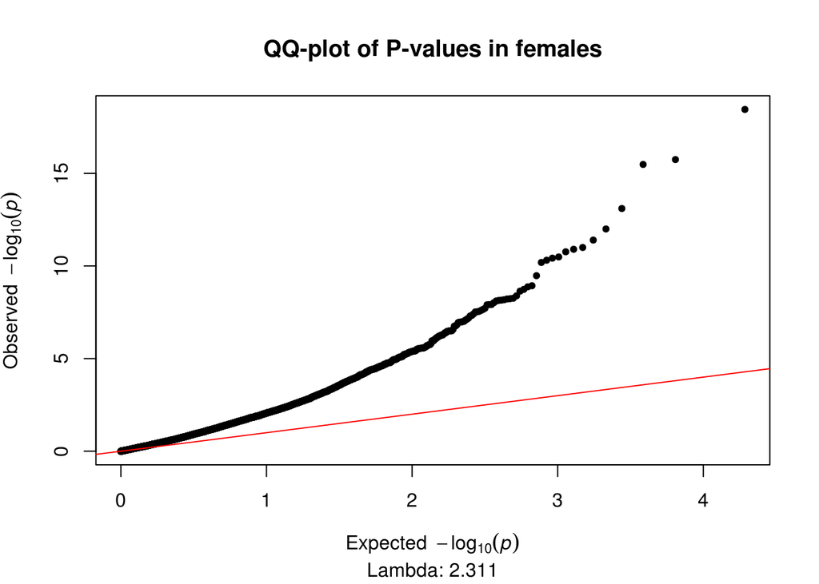

### Model 4 - 4PCs

Four PCs are regressed out, and the ANOVA for diagnosis has been run. Tables of the top 1000 DMPs for diagnosis have been produced and saved separately.

#### Top DMPs

**ANOVA:**  
51 probes pass the epigenome-wide significance threshold of 2.4x10-7 *The top 50 diagnosis associated DMPs:*

| ProbeID | Position | F | p (F) | FDR.Anova | Difference | CI lower | CI upper | pCvM | FDR | Difference | CI lower | CI upper | pCvA | FDR | Difference | CI lower | CI upper | pMvA | FDR | UCSC Gene | UCSC Gene Group | UCSC Relation to CpG Island | Gene Closest TSS | Distance Closest TSS | GREAT Annotation 1 | GREAT Annotation 2 |
| --- | --- | --- | --- | --- | --- | --- | --- | --- | --- | --- | --- | --- | --- | --- | --- | --- | --- | --- | --- | --- | --- | --- | --- | --- | --- | --- |
| cg22822140 | chr X: 153046577 | 58.218 | 6.56e-20 | 6.33e-16 | -0.009 | -0.032 | 0.014 | 0.617 | 1 | -0.094 | -0.117 | -0.071 | 4.70e-14 | 1.58e-10 | -0.085 | -0.108 | -0.063 | 5.10e-14 | 1.66e-10 | SRPK3;SRPK3;SRPK3 | 1stExon;1stExon;1stExon | Island | SRPK3 | 122 | SRPK3 (122) | (NA) |
| cg24496423 | chr X: 153046480 | 52.936 | 1.56e-18 | 7.54e-15 | 0.001 | -0.017 | 0.020 | 0.987 | 1 | -0.070 | -0.089 | -0.051 | 5.45e-14 | 1.58e-10 | -0.071 | -0.09 | -0.053 | 4.92e-14 | 1.66e-10 | SRPK3;SRPK3;SRPK3;SRPK3;SRPK3;SRPK3 | 5'UTR;1stExon;1stExon;5'UTR;5'UTR;1stExon | Island | SRPK3 | 25 | SRPK3 (25) | (NA) |
| cg12230162 | chr X: 153046482 | 51.542 | 3.69e-18 | 1.19e-14 | 0.001 | -0.023 | 0.025 | 0.995 | 1 | -0.090 | -0.115 | -0.066 | 6.03e-14 | 1.58e-10 | -0.091 | -0.115 | -0.067 | 5.16e-14 | 1.66e-10 | SRPK3;SRPK3;SRPK3;SRPK3;SRPK3;SRPK3 | 5'UTR;1stExon;1stExon;5'UTR;5'UTR;1stExon | Island | SRPK3 | 27 | SRPK3 (27) | (NA) |
| cg12468189 | chr X: 153046767 | 37.063 | 4.78e-14 | 9.66e-11 | -0.025 | -0.04 | -0.010 | 2.80e-04 | 0.017 | -0.054 | -0.069 | -0.039 | 6.56e-14 | 1.58e-10 | -0.029 | -0.044 | -0.015 | 1.41e-05 | 0.005 | SRPK3;SRPK3;SRPK3 | Body;Body;Body | Island | SRPK3 | 312 | SRPK3 (312) | (NA) |
| cg13009143 | chr X: 100548223 | 36.996 | 5.01e-14 | 9.66e-11 | -0.015 | -0.022 | -0.008 | 2.00e-06 | 5.21e-04 | 0.010 | 0.003 | 0.017 | 0.004 | 0.096 | 0.025 | 0.018 | 0.031 | 7.72e-14 | 1.86e-10 | TAF7L | TSS200 | S_Shore | TAF7L | -164 | TAF7L (-165) | (NA) |
| cg16529483 | chr X: 153046451 | 32.690 | 1.05e-12 | 1.68e-09 | -0.012 | -0.037 | 0.012 | 0.459 | 1 | -0.079 | -0.104 | -0.054 | 1.18e-11 | 2.29e-08 | -0.066 | -0.091 | -0.042 | 4.13e-09 | 4.43e-06 | SRPK3;SRPK3;SRPK3 | TSS200;TSS200;TSS200 | Island | SRPK3 | -4 | SRPK3 (-4) | (NA) |
| cg09768654 | chr X: 153046386 | 29.767 | 8.77e-12 | 1.21e-08 | 0.008 | -0.015 | 0.030 | 0.696 | 1 | -0.060 | -0.083 | -0.037 | 1.42e-08 | 1.24e-05 | -0.068 | -0.09 | -0.045 | 9.96e-11 | 1.60e-07 | SRPK3;SRPK3;SRPK3 | TSS200;TSS200;TSS200 | Island | SRPK3 | -69 | SRPK3 (-69) | (NA) |
| cg16152676 | chr X: 10126878 | 29.571 | 1.01e-11 | 1.22e-08 | 0.038 | 0.024 | 0.052 | 5.51e-09 | 7.59e-06 | -0.003 | -0.017 | 0.012 | 0.889 | 1 | -0.041 | -0.055 | -0.027 | 3.79e-10 | 5.22e-07 | CLCN4 | 5'UTR | Island | CLCN4 | 550 | CLCN4 (1894) | MID1 (724930) |
| cg19938385 | chr X: 107020894 | 28.933 | 1.63e-11 | 1.67e-08 | -0.048 | -0.066 | -0.030 | 1.38e-08 | 1.45e-05 | -0.055 | -0.073 | -0.036 | 2.13e-10 | 2.94e-07 | -0.007 | -0.025 | 0.011 | 0.656 | 1 |  |  | S_Shore | TSC22D3 | -1692 | TSC22D3 (-1878) | (NA) |
| cg19280671 | chr X: 149013642 | 28.849 | 1.73e-11 | 1.67e-08 | 0.017 | 0.011 | 0.023 | 4.60e-10 | 1.20e-06 | 0.002 | -0.004 | 0.008 | 0.806 | 1 | -0.016 | -0.022 | -0.01 | 1.14e-08 | 1.10e-05 | MAGEA8;MAGEA8;MAGEA8 | Body;Body;Body |  | MAGEA8 | 596 | MAMLD1 (-517908) | MAGEA8 (3702) |
| cg17405188 | chr X: 73164102 | 27.268 | 5.65e-11 | 4.96e-08 | 0.009 | 0.004 | 0.014 | 3.37e-04 | 0.019 | 0.017 | 0.012 | 0.023 | 2.11e-11 | 3.39e-08 | 0.008 | 0.003 | 0.013 | 0.001 | 0.117 | LOC554203 | TSS200 | Island | JPX | -56 | ZCCHC13 (-359922) | CHIC1 (381119) |
| cg24605338 | chr X: 17395856 | 27.128 | 6.28e-11 | 5.05e-08 | -0.035 | -0.046 | -0.024 | 2.31e-11 | 2.23e-07 | -0.018 | -0.029 | -0.007 | 7.43e-04 | 0.036 | 0.017 | 0.006 | 0.028 | 0.001 | 0.104 | NHS | Body | S_Shore | NHS | 2314 | SCML1 (-359735) | NHS (2314) |
| cg03360001 | chr X: 53453272 | 26.987 | 6.99e-11 | 5.18e-08 | -0.009 | -0.015 | -0.003 | 0.002 | 0.062 | 0.010 | 0.004 | 0.016 | 6.51e-04 | 0.033 | 0.018 | 0.012 | 0.024 | 2.58e-11 | 4.98e-08 | RIBC1;RIBC1 | Body;Body | S_Shelf | RIBC1 | 3434 | SMC1A (-3655) | (NA) |
| cg17003204 | chr X: 102861456 | 24.861 | 3.54e-10 | 2.44e-07 | -0.036 | -0.049 | -0.024 | 3.77e-10 | 1.20e-06 | -0.011 | -0.024 | 0.001 | 0.089 | 0.604 | 0.025 | 0.013 | 0.037 | 1.35e-05 | 0.005 | TCEAL3;TCEAL3 | TSS1500;TSS1500 | N_Shore | TCEAL3 | -1377 | TCEAL3 (-1377) | (NA) |
| cg09661041 | chr X: 153141905 | 24.120 | 6.28e-10 | 4.04e-07 | -0.005 | -0.028 | 0.018 | 0.864 | 1 | -0.062 | -0.086 | -0.038 | 1.17e-08 | 1.13e-05 | -0.057 | -0.08 | -0.034 | 9.30e-08 | 5.98e-05 | L1CAM;L1CAM;L1CAM | TSS1500;TSS1500;TSS1500 |  | L1CAM | -506 | L1CAM (-507) | (NA) |
| cg17513789 | chr X: 73073251 | 23.294 | 1.19e-09 | 7.20e-07 | -0.046 | -0.062 | -0.030 | 4.98e-10 | 1.20e-06 | -0.026 | -0.043 | -0.010 | 5.01e-04 | 0.028 | 0.02 | 0.004 | 0.036 | 0.011 | 0.354 | XIST | TSS1500 |  | XIST | -663 | ZCCHC13 (-450773) | CHIC1 (290268) |
| cg21252909 | chr X: 30326328 | 22.561 | 2.12e-09 | 1.20e-06 | 0.035 | 0.012 | 0.058 | 9.99e-04 | 0.041 | -0.029 | -0.052 | -0.006 | 0.009 | 0.163 | -0.064 | -0.087 | -0.042 | 9.09e-10 | 1.10e-06 | NR0B1 | 1stExon | N_Shore | NR0B1 | 1167 | NR0B1 (1166) | (NA) |
| cg16122592 | chr X: 26210712 | 22.152 | 2.93e-09 | 1.49e-06 | -0.030 | -0.042 | -0.019 | 8.46e-09 | 1.02e-05 | -0.025 | -0.036 | -0.013 | 2.67e-06 | 6.96e-04 | 0.005 | -0.006 | 0.017 | 0.506 | 1 | MAGEB6 | 5'UTR |  | MAGEB6 | 156 | MAGEB6 (156) | (NA) |
| cg21364342 | chr X: 107226611 | 22.151 | 2.93e-09 | 1.49e-06 | -0.022 | -0.031 | -0.012 | 6.69e-07 | 2.48e-04 | -0.025 | -0.035 | -0.015 | 2.11e-08 | 1.70e-05 | -0.003 | -0.013 | 0.006 | 0.714 | 1 | TEX13B | TSS1500 |  | TEX13B | -1011 | VSIG1 (-61588) | MID2 (157528) |
| cg11179997 | chr X: 119125670 | 21.871 | 3.66e-09 | 1.77e-06 | 0.028 | 0.017 | 0.040 | 4.47e-08 | 3.32e-05 | 0.003 | -0.009 | 0.014 | 0.836 | 1 | -0.026 | -0.037 | -0.014 | 6.65e-07 | 3.38e-04 |  |  | Island | AK123976 | -44530 | NKAP (-47936) | RHOXF2 (86036) |
| cg00123001 | chr X: 13395880 | 21.653 | 4.35e-09 | 1.95e-06 | -0.019 | -0.027 | -0.011 | 2.13e-07 | 9.80e-05 | -0.020 | -0.028 | -0.012 | 9.86e-08 | 5.60e-05 | -7.87e-04 | -0.009 | 0.007 | 0.971 | 1 |  |  | N_Shore | LOC100133123 | 42521 | EGFL6 (-191813) | ATXN3L (-57363) |
| cg23914849 | chr X: 52950051 | 21.625 | 4.45e-09 | 1.95e-06 | 0.004 | 0.002 | 0.006 | 3.13e-04 | 0.018 | 0.006 | 0.004 | 0.008 | 2.21e-09 | 2.66e-06 | 0.002 | 2.77e-04 | 0.005 | 0.023 | 0.508 |  |  | Island | FAM156A | 13799 | FAM156B (21967) | FAM156A (74599) |
| cg15907464 | chr X: 70712790 | 21.175 | 6.37e-09 | 2.65e-06 | -0.034 | -0.046 | -0.022 | 2.89e-09 | 5.58e-06 | -0.020 | -0.033 | -0.008 | 6.26e-04 | 0.032 | 0.014 | 0.002 | 0.026 | 0.023 | 0.507 | BCYRN1;INGX | Body;TSS200 | Island | INGX | -186 | OGT (-40121) | TAF1 (126677) |
| cg25549901 | chr X: 137951118 | 21.133 | 6.58e-09 | 2.65e-06 | -0.027 | -0.037 | -0.016 | 8.21e-08 | 4.66e-05 | -0.025 | -0.036 | -0.014 | 5.39e-07 | 2.00e-04 | 0.001 | -0.009 | 0.012 | 0.946 | 1 | FGF13;FGF13;FGF13;FGF13 | 5'UTR;Body;TSS1500;Body |  | FGF13 | -1401 | FGF13 (336066) | (NA) |
| cg14917571 | chr X: 79269151 | 20.631 | 9.83e-09 | 3.56e-06 | -0.051 | -0.069 | -0.032 | 4.08e-09 | 6.56e-06 | -0.028 | -0.047 | -0.009 | 0.002 | 0.061 | 0.023 | 0.004 | 0.041 | 0.012 | 0.37 | TBX22;TBX22 | TSS1500;TSS1500 |  | TBX22 | -1103 | ITM2A (-646103) | TBX22 (-8590) |
| cg25896901 | chr X: 125300481 | 20.603 | 1.01e-08 | 3.56e-06 | 0.010 | -0.016 | 0.035 | 0.652 | 1 | -0.055 | -0.081 | -0.029 | 4.03e-06 | 9.26e-04 | -0.064 | -0.09 | -0.039 | 3.76e-08 | 2.79e-05 | DCAF12L2 | TSS1500 | S_Shore | DCAF12L2 | -401 | DCAF12L1 (386360) | (NA) |
| cg17219209 | chr X: 149009840 | 20.568 | 1.03e-08 | 3.56e-06 | 0.021 | 0.013 | 0.029 | 3.31e-08 | 2.66e-05 | 0.004 | -0.004 | 0.012 | 0.48 | 1 | -0.017 | -0.025 | -0.009 | 7.86e-06 | 0.003 | MAGEA8;MAGEA8;MAGEA8 | TSS200;TSS200;TSS200 |  | MAGEA8 | -100 | MAGEA8 (-100) | (NA) |
| cg04768884 | chr X: 19443172 | 20.568 | 1.03e-08 | 3.56e-06 | 0.008 | -0.006 | 0.022 | 0.392 | 1 | 0.036 | 0.022 | 0.050 | 2.54e-08 | 1.77e-05 | 0.029 | 0.015 | 0.042 | 8.12e-06 | 0.003 | MAP3K15 | Body |  | MAP3K15 | 35099 | PDHA1 (81162) | MAP3K15 (90206) |
| cg09513996 | chr X: 48685182 | 20.176 | 1.42e-08 | 4.72e-06 | 0.006 | -0.007 | 0.020 | 0.521 | 1 | -0.028 | -0.042 | -0.014 | 9.50e-06 | 0.002 | -0.035 | -0.048 | -0.021 | 3.51e-08 | 2.79e-05 |  |  | Island | ERAS | -2100 | ERAS (-2100) | (NA) |
| cg06068202 | chr X: 150343148 | 20.115 | 1.49e-08 | 4.79e-06 | 0.040 | 0.021 | 0.058 | 3.27e-06 | 7.00e-04 | 0.047 | 0.028 | 0.066 | 6.75e-08 | 4.07e-05 | 0.007 | -0.012 | 0.025 | 0.646 | 1 |  |  | Island | GPR50 | -1907 | GPR50 (-1907) | (NA) |
| cg06452970 | chr X: 13835264 | 19.914 | 1.75e-08 | 5.45e-06 | 0.047 | 0.028 | 0.066 | 5.87e-08 | 4.05e-05 | 0.009 | -0.010 | 0.028 | 0.521 | 1 | -0.038 | -0.057 | -0.019 | 9.65e-06 | 0.004 | GPM6B;GPM6B;GPM6B;GPM6B;GPM6B;GPM6B;GPM6B | 1stExon;5'UTR;5'UTR;Body;5'UTR;1stExon;1stExon |  | GPM6B | 50 | GPM6B (49) | (NA) |
| cg07344627 | chr X: 125687011 | 19.490 | 2.47e-08 | 7.44e-06 | -0.033 | -0.057 | -0.010 | 0.003 | 0.082 | -0.063 | -0.086 | -0.039 | 1.04e-08 | 1.12e-05 | -0.029 | -0.053 | -0.006 | 0.01 | 0.337 | DCAF12L1 | TSS200 | S_Shore | DCAF12L1 | -169 | DCAF12L1 (-170) | (NA) |
| cg09953945 | chr X: 150345040 | 19.320 | 2.83e-08 | 8.29e-06 | -0.029 | -0.04 | -0.018 | 1.51e-08 | 1.45e-05 | -0.018 | -0.029 | -0.007 | 5.66e-04 | 0.031 | 0.011 | -2.15e-04 | 0.022 | 0.056 | 0.787 | GPR50 | TSS200 | N_Shore | GPR50 | -15 | GPR50 (-15) | (NA) |
| cg08630881 | chr X: 70713213 | 19.264 | 2.96e-08 | 8.41e-06 | -0.028 | -0.039 | -0.017 | 1.68e-08 | 1.47e-05 | -0.018 | -0.029 | -0.007 | 4.41e-04 | 0.026 | 0.01 | -6.21e-04 | 0.021 | 0.069 | 0.855 | BCYRN1;INGX | Body;TSS1500 | S_Shore | INGX | -609 | OGT (-39698) | TAF1 (127100) |
| cg26101161 | chr X: 122736584 | 19.081 | 3.44e-08 | 9.49e-06 | -0.020 | -0.03 | -0.011 | 4.44e-06 | 8.41e-04 | -0.023 | -0.033 | -0.014 | 1.77e-07 | 9.46e-05 | -0.003 | -0.013 | 0.007 | 0.726 | 1 | THOC2 | 3'UTR |  | THOC2 | 8230 | THOC2 (130319) | GRIA3 (418489) |
| cg00805156 | chr X: 3264341 | 18.888 | 4.03e-08 | 1.08e-05 | 0.036 | 0.019 | 0.052 | 2.89e-06 | 6.34e-04 | 0.040 | 0.023 | 0.057 | 3.07e-07 | 1.50e-04 | 0.004 | -0.013 | 0.02 | 0.846 | 1 | MXRA5 | 5'UTR | Island | MXRA5 | 343 | MXRA5 (342) | (NA) |
| cg11315455 | chr X: 122997585 | 18.776 | 4.41e-08 | 1.15e-05 | -0.029 | -0.041 | -0.018 | 6.49e-08 | 4.17e-05 | -0.008 | -0.020 | 0.004 | 0.282 | 0.973 | 0.022 | 0.01 | 0.033 | 6.80e-05 | 0.015 | XIAP | 5'UTR | S_Shelf | XIAP | 3569 | STAG2 (-96889) | XIAP (3569) |
| cg26484667 | chr X: 2733164 | 18.621 | 5.01e-08 | 1.27e-05 | -0.029 | -0.041 | -0.017 | 1.01e-07 | 5.15e-05 | -0.007 | -0.019 | 0.005 | 0.395 | 1 | 0.023 | 0.011 | 0.034 | 3.91e-05 | 0.01 | XG;XG;XG | 3'UTR;3'UTR;3'UTR |  | GYG2 | -13698 | GYG2 (-13698) | XG (63072) |
| cg00632130 | chr X: 47931806 | 18.551 | 5.30e-08 | 1.31e-05 | -0.011 | -0.025 | 0.002 | 0.104 | 0.619 | 0.022 | 0.009 | 0.035 | 4.32e-04 | 0.025 | 0.033 | 0.02 | 0.047 | 3.38e-08 | 2.79e-05 | ZNF630 | TSS1500 | S_Shore | ZNF630 | -781 | ZNF630 (-1299) | (NA) |
| cg22574818 | chr X: 55479616 | 18.455 | 5.74e-08 | 1.38e-05 | -0.033 | -0.056 | -0.010 | 0.002 | 0.075 | -0.060 | -0.083 | -0.036 | 2.57e-08 | 1.77e-05 | -0.026 | -0.049 | -0.004 | 0.018 | 0.461 | MAGEH1;MAGEH1 | 1stExon;3'UTR |  | MAGEH1 | 1079 | MAGEH1 (1079) | USP51 (36014) |
| cg26747413 | chr X: 15807140 | 18.385 | 6.08e-08 | 1.43e-05 | -0.039 | -0.056 | -0.023 | 2.79e-07 | 1.14e-04 | -0.035 | -0.051 | -0.018 | 7.19e-06 | 0.001 | 0.004 | -0.012 | 0.021 | 0.798 | 1 | INE2;ZRSR2 | TSS1500;TSS1500 | N_Shore | INE2 | -1428 | ZRSR2 (-1433) | (NA) |
| cg04710661 | chr X: 2848381 | 18.250 | 6.78e-08 | 1.56e-05 | 0.007 | 3.28e-04 | 0.014 | 0.038 | 0.376 | 0.017 | 0.011 | 0.024 | 3.51e-08 | 2.26e-05 | 0.01 | 0.004 | 0.017 | 0.001 | 0.101 | ARSD;ARSD | TSS1500;TSS1500 | S_Shore | ARSD | -965 | ARSD (-966) | (NA) |
| cg22926378 | chr X: 6144633 | 17.994 | 8.38e-08 | 1.88e-05 | 0.014 | 0.007 | 0.021 | 1.38e-05 | 0.002 | -0.002 | -0.009 | 0.005 | 0.736 | 1 | -0.016 | -0.023 | -0.009 | 3.87e-07 | 2.33e-04 | NLGN4X;NLGN4X | 5'UTR;5'UTR | Island | NLGN4X | 483 | NLGN4X (2072) | (NA) |
| cg08464958 | chr X: 2852845 | 17.944 | 8.73e-08 | 1.91e-05 | -0.022 | -0.032 | -0.013 | 2.50e-07 | 1.10e-04 | -0.004 | -0.014 | 0.005 | 0.545 | 1 | 0.018 | 0.009 | 0.027 | 2.89e-05 | 0.009 | ARSE | 3'UTR |  | ARSD | -5429 | ARSD (-5430) | ARSE (29648) |
| cg01737010 | chr X: 101772014 | 17.884 | 9.17e-08 | 1.97e-05 | 0.007 | -0.002 | 0.017 | 0.183 | 0.808 | -0.017 | -0.026 | -0.007 | 2.72e-04 | 0.018 | -0.024 | -0.033 | -0.014 | 7.40e-08 | 5.10e-05 | TMSB15A | TSS1500 | S_Shore | TMSB15A | -315 | TMSB15A (-316) | (NA) |
| cg25177692 | chr X: 129193893 | 17.765 | 1.01e-07 | 2.12e-05 | -0.027 | -0.038 | -0.016 | 1.57e-07 | 7.55e-05 | -0.021 | -0.032 | -0.010 | 5.60e-05 | 0.006 | 0.006 | -0.005 | 0.017 | 0.427 | 1 |  |  | N_Shore | BCORL1 | 34929 | ELF4 (50794) | BCORL1 (54730) |
| cg04817724 | chr X: 103809991 | 17.332 | 1.45e-07 | 2.91e-05 | 0.049 | 0.029 | 0.069 | 7.29e-08 | 4.40e-05 | 0.030 | 0.010 | 0.050 | 0.002 | 0.059 | -0.019 | -0.039 | 3.93e-04 | 0.056 | 0.787 | IL1RAPL2 | TSS1500 | Island | IL1RAPL2 | -1004 | IL1RAPL2 (-1004) | (NA) |
| cg00072799 | chr X: 78427682 | 17.330 | 1.45e-07 | 2.91e-05 | -0.007 | -0.021 | 0.007 | 0.495 | 1 | -0.033 | -0.047 | -0.019 | 3.38e-07 | 1.55e-04 | -0.026 | -0.04 | -0.013 | 3.71e-05 | 0.01 | GPR174;GPR174 | 1stExon;3'UTR |  | GPR174 | 1214 | GPR174 (1214) | ITM2A (195366) |
| cg24834461 | chr X: 153637645 | 17.242 | 1.56e-07 | 3.07e-05 | 0.017 | 0.01 | 0.024 | 9.40e-08 | 5.04e-05 | 0.011 | 0.004 | 0.018 | 7.89e-04 | 0.038 | -0.006 | -0.013 | 9.21e-04 | 0.104 | 1 | DNASE1L1;DNASE1L1;DNASE1L1;DNASE1L1 | TSS200;5'UTR;5'UTR;5'UTR | N_Shelf | DNASE1L1 | -70 | TAZ (-2231) | (NA) |
| cg02329520 | chr X: 153740317 | 17.137 | 1.70e-07 | 3.28e-05 | -0.014 | -0.022 | -0.007 | 5.43e-05 | 0.005 | -0.018 | -0.026 | -0.010 | 3.11e-07 | 1.50e-04 | -0.004 | -0.011 | 0.004 | 0.438 | 1 | FAM3A;FAM3A;FAM3A;FAM3A;FAM3A | Body;Body;Body;Body;Body | N_Shelf | FAM3A | 4249 | SLC10A3 (-21316) | FAM3A (4248) |

**CTL vs MCI:**  
21 probes pass the epigenome-wide significance threshold of 2.4x10-7

*The top 50 CTL vs MCI associated DMPs:*

| ProbeID | Position | F | p (F) | FDR.Anova | Difference | CI lower | CI upper | pCvM | FDR | Difference | CI lower | CI upper | pCvA | FDR | Difference | CI lower | CI upper | pMvA | FDR | UCSC Gene | UCSC Gene Group | UCSC Relation to CpG Island | Gene Closest TSS | Distance Closest TSS | GREAT Annotation 1 | GREAT Annotation 2 |
| --- | --- | --- | --- | --- | --- | --- | --- | --- | --- | --- | --- | --- | --- | --- | --- | --- | --- | --- | --- | --- | --- | --- | --- | --- | --- | --- |
| cg24605338 | chr X: 17395856 | 27.128 | 6.28e-11 | 5.05e-08 | -0.035 | -0.046 | -0.024 | 2.31e-11 | 2.23e-07 | -0.018 | -0.029 | -0.007 | 7.43e-04 | 0.036 | 0.017 | 0.006 | 0.028 | 0.001 | 0.104 | NHS | Body | S_Shore | NHS | 2314 | SCML1 (-359735) | NHS (2314) |
| cg17003204 | chr X: 102861456 | 24.861 | 3.54e-10 | 2.44e-07 | -0.036 | -0.049 | -0.024 | 3.77e-10 | 1.20e-06 | -0.011 | -0.024 | 0.001 | 0.089 | 0.604 | 0.025 | 0.013 | 0.037 | 1.35e-05 | 0.005 | TCEAL3;TCEAL3 | TSS1500;TSS1500 | N_Shore | TCEAL3 | -1377 | TCEAL3 (-1377) | (NA) |
| cg19280671 | chr X: 149013642 | 28.849 | 1.73e-11 | 1.67e-08 | 0.017 | 0.011 | 0.023 | 4.60e-10 | 1.20e-06 | 0.002 | -0.004 | 0.008 | 0.806 | 1 | -0.016 | -0.022 | -0.01 | 1.14e-08 | 1.10e-05 | MAGEA8;MAGEA8;MAGEA8 | Body;Body;Body |  | MAGEA8 | 596 | MAMLD1 (-517908) | MAGEA8 (3702) |
| cg17513789 | chr X: 73073251 | 23.294 | 1.19e-09 | 7.20e-07 | -0.046 | -0.062 | -0.030 | 4.98e-10 | 1.20e-06 | -0.026 | -0.043 | -0.01 | 5.01e-04 | 0.028 | 0.02 | 0.004 | 0.036 | 0.011 | 0.354 | XIST | TSS1500 |  | XIST | -663 | ZCCHC13 (-450773) | CHIC1 (290268) |
| cg15907464 | chr X: 70712790 | 21.175 | 6.37e-09 | 2.65e-06 | -0.034 | -0.046 | -0.022 | 2.89e-09 | 5.58e-06 | -0.020 | -0.033 | -0.008 | 6.26e-04 | 0.032 | 0.014 | 0.002 | 0.026 | 0.023 | 0.507 | BCYRN1;INGX | Body;TSS200 | Island | INGX | -186 | OGT (-40121) | TAF1 (126677) |
| cg14917571 | chr X: 79269151 | 20.631 | 9.83e-09 | 3.56e-06 | -0.051 | -0.069 | -0.032 | 4.08e-09 | 6.56e-06 | -0.028 | -0.047 | -0.009 | 0.002 | 0.061 | 0.023 | 0.004 | 0.041 | 0.012 | 0.37 | TBX22;TBX22 | TSS1500;TSS1500 |  | TBX22 | -1103 | ITM2A (-646103) | TBX22 (-8590) |
| cg16152676 | chr X: 10126878 | 29.571 | 1.01e-11 | 1.22e-08 | 0.038 | 0.024 | 0.052 | 5.51e-09 | 7.59e-06 | -0.003 | -0.017 | 0.012 | 0.889 | 1 | -0.041 | -0.055 | -0.027 | 3.79e-10 | 5.22e-07 | CLCN4 | 5'UTR | Island | CLCN4 | 550 | CLCN4 (1894) | MID1 (724930) |
| cg16122592 | chr X: 26210712 | 22.152 | 2.93e-09 | 1.49e-06 | -0.030 | -0.042 | -0.019 | 8.46e-09 | 1.02e-05 | -0.025 | -0.036 | -0.013 | 2.67e-06 | 6.96e-04 | 0.005 | -0.006 | 0.017 | 0.506 | 1 | MAGEB6 | 5'UTR |  | MAGEB6 | 156 | MAGEB6 (156) | (NA) |
| cg19938385 | chr X: 107020894 | 28.933 | 1.63e-11 | 1.67e-08 | -0.048 | -0.066 | -0.030 | 1.38e-08 | 1.45e-05 | -0.055 | -0.073 | -0.036 | 2.13e-10 | 2.94e-07 | -0.007 | -0.025 | 0.011 | 0.656 | 1 |  |  | S_Shore | TSC22D3 | -1692 | TSC22D3 (-1878) | (NA) |
| cg09953945 | chr X: 150345040 | 19.320 | 2.83e-08 | 8.29e-06 | -0.029 | -0.040 | -0.018 | 1.51e-08 | 1.45e-05 | -0.018 | -0.029 | -0.007 | 5.66e-04 | 0.031 | 0.011 | -2.15e-04 | 0.022 | 0.056 | 0.787 | GPR50 | TSS200 | N_Shore | GPR50 | -15 | GPR50 (-15) | (NA) |
| cg08630881 | chr X: 70713213 | 19.264 | 2.96e-08 | 8.41e-06 | -0.028 | -0.039 | -0.017 | 1.68e-08 | 1.47e-05 | -0.018 | -0.029 | -0.007 | 4.41e-04 | 0.026 | 0.01 | -6.21e-04 | 0.021 | 0.069 | 0.855 | BCYRN1;INGX | Body;TSS1500 | S_Shore | INGX | -609 | OGT (-39698) | TAF1 (127100) |
| cg17219209 | chr X: 149009840 | 20.568 | 1.03e-08 | 3.56e-06 | 0.021 | 0.013 | 0.029 | 3.31e-08 | 2.66e-05 | 0.004 | -0.004 | 0.012 | 0.48 | 1 | -0.017 | -0.025 | -0.009 | 7.86e-06 | 0.003 | MAGEA8;MAGEA8;MAGEA8 | TSS200;TSS200;TSS200 |  | MAGEA8 | -100 | MAGEA8 (-100) | (NA) |
| cg11179997 | chr X: 119125670 | 21.871 | 3.66e-09 | 1.77e-06 | 0.028 | 0.017 | 0.040 | 4.47e-08 | 3.32e-05 | 0.003 | -0.009 | 0.014 | 0.836 | 1 | -0.026 | -0.037 | -0.014 | 6.65e-07 | 3.38e-04 |  |  | Island | AK123976 | -44530 | NKAP (-47936) | RHOXF2 (86036) |
| cg06452970 | chr X: 13835264 | 19.914 | 1.75e-08 | 5.45e-06 | 0.047 | 0.028 | 0.066 | 5.87e-08 | 4.05e-05 | 0.009 | -0.01 | 0.028 | 0.521 | 1 | -0.038 | -0.057 | -0.019 | 9.65e-06 | 0.004 | GPM6B;GPM6B;GPM6B;GPM6B;GPM6B;GPM6B;GPM6B | 1stExon;5'UTR;5'UTR;Body;5'UTR;1stExon;1stExon |  | GPM6B | 50 | GPM6B (49) | (NA) |
| cg11315455 | chr X: 122997585 | 18.776 | 4.41e-08 | 1.15e-05 | -0.029 | -0.041 | -0.018 | 6.49e-08 | 4.17e-05 | -0.008 | -0.02 | 0.004 | 0.282 | 0.973 | 0.022 | 0.01 | 0.033 | 6.80e-05 | 0.015 | XIAP | 5'UTR | S_Shelf | XIAP | 3569 | STAG2 (-96889) | XIAP (3569) |
| cg04817724 | chr X: 103809991 | 17.332 | 1.45e-07 | 2.91e-05 | 0.049 | 0.029 | 0.069 | 7.29e-08 | 4.40e-05 | 0.030 | 0.01 | 0.05 | 0.002 | 0.059 | -0.019 | -0.039 | 3.93e-04 | 0.056 | 0.787 | IL1RAPL2 | TSS1500 | Island | IL1RAPL2 | -1004 | IL1RAPL2 (-1004) | (NA) |
| cg25549901 | chr X: 137951118 | 21.133 | 6.58e-09 | 2.65e-06 | -0.027 | -0.037 | -0.016 | 8.21e-08 | 4.66e-05 | -0.025 | -0.036 | -0.014 | 5.39e-07 | 2.00e-04 | 0.001 | -0.009 | 0.012 | 0.946 | 1 | FGF13;FGF13;FGF13;FGF13 | 5'UTR;Body;TSS1500;Body |  | FGF13 | -1401 | FGF13 (336066) | (NA) |
| cg24834461 | chr X: 153637645 | 17.242 | 1.56e-07 | 3.07e-05 | 0.017 | 0.010 | 0.024 | 9.40e-08 | 5.04e-05 | 0.011 | 0.004 | 0.018 | 7.89e-04 | 0.038 | -0.006 | -0.013 | 9.21e-04 | 0.104 | 1 | DNASE1L1;DNASE1L1;DNASE1L1;DNASE1L1 | TSS200;5'UTR;5'UTR;5'UTR | N_Shelf | DNASE1L1 | -70 | TAZ (-2231) | (NA) |
| cg26484667 | chr X: 2733164 | 18.621 | 5.01e-08 | 1.27e-05 | -0.029 | -0.041 | -0.017 | 1.01e-07 | 5.15e-05 | -0.007 | -0.019 | 0.005 | 0.395 | 1 | 0.023 | 0.011 | 0.034 | 3.91e-05 | 0.01 | XG;XG;XG | 3'UTR;3'UTR;3'UTR |  | GYG2 | -13698 | GYG2 (-13698) | XG (63072) |
| cg25177692 | chr X: 129193893 | 17.765 | 1.01e-07 | 2.12e-05 | -0.027 | -0.038 | -0.016 | 1.57e-07 | 7.55e-05 | -0.021 | -0.032 | -0.01 | 5.60e-05 | 0.006 | 0.006 | -0.005 | 0.017 | 0.427 | 1 |  |  | N_Shore | BCORL1 | 34929 | ELF4 (50794) | BCORL1 (54730) |
| cg00123001 | chr X: 13395880 | 21.653 | 4.35e-09 | 1.95e-06 | -0.019 | -0.027 | -0.011 | 2.13e-07 | 9.80e-05 | -0.020 | -0.028 | -0.012 | 9.86e-08 | 5.60e-05 | -7.87e-04 | -0.009 | 0.007 | 0.971 | 1 |  |  | N_Shore | LOC100133123 | 42521 | EGFL6 (-191813) | ATXN3L (-57363) |
| cg08464958 | chr X: 2852845 | 17.944 | 8.73e-08 | 1.91e-05 | -0.022 | -0.032 | -0.013 | 2.50e-07 | 1.10e-04 | -0.004 | -0.014 | 0.005 | 0.545 | 1 | 0.018 | 0.009 | 0.027 | 2.89e-05 | 0.009 | ARSE | 3'UTR |  | ARSD | -5429 | ARSD (-5430) | ARSE (29648) |
| cg26747413 | chr X: 15807140 | 18.385 | 6.08e-08 | 1.43e-05 | -0.039 | -0.056 | -0.023 | 2.79e-07 | 1.14e-04 | -0.035 | -0.051 | -0.018 | 7.19e-06 | 0.001 | 0.004 | -0.012 | 0.021 | 0.798 | 1 | INE2;ZRSR2 | TSS1500;TSS1500 | N_Shore | INE2 | -1428 | ZRSR2 (-1433) | (NA) |
| cg08867267 | chr X: 130033963 | 15.880 | 4.85e-07 | 8.26e-05 | -0.024 | -0.034 | -0.014 | 2.84e-07 | 1.14e-04 | -0.015 | -0.025 | -0.005 | 0.002 | 0.057 | 0.009 | -0.001 | 0.018 | 0.111 | 1 | ENOX2;ENOX2 | 5'UTR;5'UTR | N_Shelf | ENOX2 | 3245 | ENOX2 (3244) | RBMX2 (498021) |
| cg12461113 | chr X: 13587550 | 15.074 | 9.58e-07 | 1.38e-04 | -0.079 | -0.113 | -0.045 | 4.38e-07 | 1.69e-04 | -0.041 | -0.075 | -0.007 | 0.015 | 0.217 | 0.038 | 0.004 | 0.072 | 0.024 | 0.52 | EGFL6;EGFL6 | TSS200;TSS200 | N_Shore | EGFL6 | -143 | EGFL6 (-143) | (NA) |
| cg21364342 | chr X: 107226611 | 22.151 | 2.93e-09 | 1.49e-06 | -0.022 | -0.031 | -0.012 | 6.69e-07 | 2.48e-04 | -0.025 | -0.035 | -0.015 | 2.11e-08 | 1.70e-05 | -0.003 | -0.013 | 0.006 | 0.714 | 1 | TEX13B | TSS1500 |  | TEX13B | -1011 | VSIG1 (-61588) | MID2 (157528) |
| cg25396787 | chr X: 3733991 | 14.643 | 1.38e-06 | 1.80e-04 | 0.028 | 0.016 | 0.041 | 7.49e-07 | 2.62e-04 | 0.017 | 0.005 | 0.03 | 0.004 | 0.096 | -0.011 | -0.023 | 0.001 | 0.097 | 0.995 |  |  | Island | TRNA_Ile | 22500 | PRKX (-102317) | (NA) |
| cg25958561 | chr X: 110187179 | 15.801 | 5.19e-07 | 8.63e-05 | 0.032 | 0.018 | 0.046 | 7.61e-07 | 2.62e-04 | 0.025 | 0.011 | 0.039 | 1.48e-04 | 0.011 | -0.007 | -0.021 | 0.007 | 0.476 | 1 | PAK3;PAK3 | TSS1500;TSS1500 |  | PAK3 | -333 | PAK3 (-179125) | CHRDL1 (-148104) |
| cg09979033 | chr X: 16726904 | 15.874 | 4.88e-07 | 8.26e-05 | -0.018 | -0.026 | -0.010 | 8.46e-07 | 2.82e-04 | -0.014 | -0.022 | -0.006 | 1.05e-04 | 0.009 | 0.003 | -0.004 | 0.011 | 0.544 | 1 | CTPS2;CTPS2;CTPS2 | 5'UTR;5'UTR;5'UTR | N_Shelf | CTPS2 | 3436 | CTPS2 (4154) | S100G (58624) |
| cg14306994 | chr X: 49019804 | 14.021 | 2.35e-06 | 2.83e-04 | 0.030 | 0.017 | 0.043 | 1.13e-06 | 3.53e-04 | 0.014 | 8.35e-04 | 0.028 | 0.035 | 0.359 | -0.016 | -0.029 | -0.002 | 0.018 | 0.455 | MAGIX;MAGIX;MAGIX;MAGIX | Body;Body;Body;TSS1500 | Island | MAGIX | -316 | GPKOW (-39726) | PLP2 (-8379) |
| cg25433595 | chr X: 100183764 | 15.543 | 6.45e-07 | 1.04e-04 | 0.042 | 0.023 | 0.060 | 1.14e-06 | 3.53e-04 | 0.034 | 0.015 | 0.053 | 1.19e-04 | 0.01 | -0.008 | -0.027 | 0.011 | 0.564 | 1 | XKRX;XKRX | 5'UTR;1stExon | N_Shore | XKRX | 134 | XKRX (133) | (NA) |
| cg05860920 | chr X: 11679501 | 14.890 | 1.12e-06 | 1.57e-04 | 0.059 | 0.032 | 0.085 | 1.21e-06 | 3.65e-04 | 0.044 | 0.017 | 0.071 | 4.16e-04 | 0.025 | -0.015 | -0.041 | 0.011 | 0.376 | 1 | ARHGAP6;ARHGAP6 | Body;Body | N_Shelf | ARHGAP6 | 4320 | ARHGAP6 (4319) | AMELX (367969) |
| cg27558057 | chr X: 70712724 | 13.942 | 2.52e-06 | 2.96e-04 | -0.029 | -0.042 | -0.016 | 1.30e-06 | 3.79e-04 | -0.013 | -0.026 | 3.69e-04 | 0.059 | 0.479 | 0.016 | 0.003 | 0.029 | 0.01 | 0.345 | BCYRN1;INGX | Body;TSS200 | Island | INGX | -120 | OGT (-40187) | TAF1 (126611) |
| cg07892139 | chr X: 84192519 | 17.004 | 1.90e-07 | 3.59e-05 | -0.045 | -0.066 | -0.025 | 1.36e-06 | 3.85e-04 | -0.042 | -0.063 | -0.022 | 7.90e-06 | 0.001 | 0.003 | -0.017 | 0.023 | 0.943 | 1 |  |  | S_Shelf | UBE2DNL | 3363 | APOOL (-66378) | UBE2DNL (3363) |
| cg25831435 | chr X: 137714452 | 14.528 | 1.52e-06 | 1.95e-04 | -0.030 | -0.044 | -0.016 | 1.63e-06 | 4.48e-04 | -0.023 | -0.036 | -0.009 | 5.02e-04 | 0.028 | 0.008 | -0.006 | 0.021 | 0.383 | 1 | FGF13;FGF13;FGF13;FGF13;FGF13;FGF13 | 3'UTR;3'UTR;3'UTR;3'UTR;3'UTR;3'UTR |  | LOC158696 | -14653 | FGF13 (572732) | (NA) |
| ch.X.112118442F | chr X: 112231786 | 13.548 | 3.53e-06 | 3.81e-04 | 0.013 | 0.007 | 0.019 | 1.71e-06 | 4.58e-04 | 0.007 | 0.001 | 0.013 | 0.015 | 0.217 | -0.006 | -0.012 | 2.33e-05 | 0.051 | 0.759 |  |  |  | U6 | 69427 | AMOT (-165415) | (NA) |
| cg13009143 | chr X: 100548223 | 36.996 | 5.01e-14 | 9.66e-11 | -0.015 | -0.022 | -0.008 | 2.00e-06 | 5.21e-04 | 0.010 | 0.003 | 0.017 | 0.004 | 0.096 | 0.025 | 0.018 | 0.031 | 7.72e-14 | 1.86e-10 | TAF7L | TSS200 | S_Shore | TAF7L | -164 | TAF7L (-165) | (NA) |
| cg05889382 | chr X: 70887722 | 16.550 | 2.77e-07 | 5.05e-05 | -0.020 | -0.029 | -0.011 | 2.19e-06 | 5.47e-04 | -0.019 | -0.028 | -0.01 | 8.83e-06 | 0.001 | 9.57e-04 | -0.008 | 0.01 | 0.966 | 1 | BCYRN1 | Body | Island | LOC100132741 | -29323 | PIN4 (-513803) | CXCR3 (-49356) |
| cg06068891 | chr X: 135228207 | 14.521 | 1.53e-06 | 1.95e-04 | -0.046 | -0.068 | -0.025 | 2.21e-06 | 5.47e-04 | -0.037 | -0.058 | -0.015 | 2.73e-04 | 0.018 | 0.01 | -0.011 | 0.031 | 0.519 | 1 | FHL1;FHL1;FHL1;FHL1 | TSS1500;TSS1500;TSS1500;TSS1500 | N_Shore | FHL1 | -653 | FHL1 (-1351) | (NA) |
| cg06138173 | chr X: 16668923 | 13.243 | 4.59e-06 | 4.34e-04 | -0.030 | -0.045 | -0.016 | 2.32e-06 | 5.52e-04 | -0.018 | -0.032 | -0.003 | 0.011 | 0.183 | 0.013 | -0.001 | 0.027 | 0.076 | 0.896 | CTPS2;S100G;CTPS2;CTPS2 | Body;5'UTR;Body;Body |  | S100G | 643 | S100G (643) | (NA) |
| cg26468081 | chr X: 69501565 | 13.586 | 3.41e-06 | 3.77e-04 | -0.014 | -0.021 | -0.008 | 2.40e-06 | 5.52e-04 | -0.005 | -0.012 | 0.002 | 0.168 | 0.798 | 0.009 | 0.003 | 0.016 | 0.003 | 0.197 | ARR3;RAB41 | Body;TSS1500 |  | RAB41 | -456 | RAB41 (-456) | (NA) |
| cg07089438 | chr X: 133988190 | 13.353 | 4.17e-06 | 4.11e-04 | -0.024 | -0.036 | -0.013 | 2.45e-06 | 5.52e-04 | -0.015 | -0.027 | -0.004 | 0.005 | 0.112 | 0.009 | -0.002 | 0.02 | 0.144 | 1 | FAM122C;FAM122C | 3'UTR;Body |  | MOSPD1 | 45374 | PLAC1 (-195678) | MOSPD1 (61106) |
| cg18497064 | chr X: 134715899 | 13.577 | 3.44e-06 | 3.77e-04 | -0.039 | -0.057 | -0.021 | 2.46e-06 | 5.52e-04 | -0.014 | -0.032 | 0.004 | 0.174 | 0.809 | 0.025 | 0.007 | 0.043 | 0.003 | 0.19 | DDX26B | 3'UTR |  | DDX26B | 12638 | ZNF449 (237204) | MMGT1 (340234) |
| cg00805156 | chr X: 3264341 | 18.888 | 4.03e-08 | 1.08e-05 | 0.036 | 0.019 | 0.052 | 2.89e-06 | 6.34e-04 | 0.040 | 0.023 | 0.057 | 3.07e-07 | 1.50e-04 | 0.004 | -0.013 | 0.02 | 0.846 | 1 | MXRA5 | 5'UTR | Island | MXRA5 | 343 | MXRA5 (342) | (NA) |
| cg06068202 | chr X: 150343148 | 20.115 | 1.49e-08 | 4.79e-06 | 0.040 | 0.021 | 0.058 | 3.27e-06 | 7.00e-04 | 0.047 | 0.028 | 0.066 | 6.75e-08 | 4.07e-05 | 0.007 | -0.012 | 0.025 | 0.646 | 1 |  |  | Island | GPR50 | -1907 | GPR50 (-1907) | (NA) |
| cg09641151 | chr X: 153693918 | 13.118 | 5.11e-06 | 4.65e-04 | 0.028 | 0.015 | 0.041 | 3.66e-06 | 7.67e-04 | 0.019 | 0.006 | 0.033 | 0.003 | 0.076 | -0.009 | -0.022 | 0.004 | 0.24 | 1 | PLXNA3 | Body | N_Shore | PLXNA3 | 7296 | PLXNA3 (7296) | LAGE3 (13677) |
| cg22268449 | chr X: 47053156 | 14.916 | 1.10e-06 | 1.56e-04 | 0.015 | 0.008 | 0.022 | 3.77e-06 | 7.69e-04 | 0.014 | 0.006 | 0.021 | 5.66e-05 | 0.006 | -0.002 | -0.009 | 0.005 | 0.834 | 1 | UBA1;UBA1 | TSS200;5'UTR | Island | UBA1 | -44 | CDK16 (-29260) | UBA1 (2958) |
| cg11837390 | chr X: 106957165 | 13.442 | 3.86e-06 | 3.96e-04 | -0.021 | -0.031 | -0.011 | 3.83e-06 | 7.69e-04 | -0.015 | -0.025 | -0.005 | 9.62e-04 | 0.043 | 0.005 | -0.004 | 0.015 | 0.387 | 1 | TSC22D3;TSC22D3;TSC22D3 | 3'UTR;3'UTR;3'UTR | N_Shelf | TSC22D3 | 2546 | TSC22D3 (61851) | PRPS1 (85512) |
| cg20881335 | chr X: 14547172 | 12.734 | 7.13e-06 | 6.03e-04 | 0.064 | 0.034 | 0.094 | 4.00e-06 | 7.87e-04 | 0.027 | -0.004 | 0.057 | 0.096 | 0.625 | -0.037 | -0.067 | -0.007 | 0.011 | 0.363 | GLRA2;GLRA2;GLRA2 | TSS1500;TSS1500;TSS1500 |  | GLRA2 | -247 | GLRA2 (-247) | (NA) |
| cg03035653 | chr X: 99662932 | 12.606 | 7.96e-06 | 6.56e-04 | 0.039 | 0.020 | 0.057 | 4.32e-06 | 8.33e-04 | 0.017 | -0.002 | 0.035 | 0.084 | 0.582 | -0.022 | -0.04 | -0.004 | 0.014 | 0.404 | PCDH19;PCDH19 | 1stExon;1stExon | Island | PCDH19 | 2339 | PCDH19 (2338) | (NA) |

**CTL vs AD:**  
18 probes pass the epigenome-wide significance threshold of 2.4x10-7  
*The top 50 CTL vs AD associated DMPs:*

| ProbeID | Position | F | p (F) | FDR.Anova | Difference | CI lower | CI upper | pCvM | FDR | Difference | CI lower | CI upper | pCvA | FDR | Difference | CI lower | CI upper | pMvA | FDR | UCSC Gene | UCSC Gene Group | UCSC Relation to CpG Island | Gene Closest TSS | Distance Closest TSS | GREAT Annotation 1 | GREAT Annotation 2 |
| --- | --- | --- | --- | --- | --- | --- | --- | --- | --- | --- | --- | --- | --- | --- | --- | --- | --- | --- | --- | --- | --- | --- | --- | --- | --- | --- |
| cg22822140 | chr X: 153046577 | 58.218 | 6.56e-20 | 6.33e-16 | -0.009 | -0.032 | 0.014 | 0.617 | 1 | -0.094 | -0.117 | -0.071 | 4.70e-14 | 1.58e-10 | -0.085 | -0.108 | -0.063 | 5.10e-14 | 1.66e-10 | SRPK3;SRPK3;SRPK3 | 1stExon;1stExon;1stExon | Island | SRPK3 | 122 | SRPK3 (122) | (NA) |
| cg24496423 | chr X: 153046480 | 52.936 | 1.56e-18 | 7.54e-15 | 0.001 | -0.017 | 0.02 | 0.987 | 1 | -0.070 | -0.089 | -0.051 | 5.45e-14 | 1.58e-10 | -0.071 | -0.09 | -0.053 | 4.92e-14 | 1.66e-10 | SRPK3;SRPK3;SRPK3;SRPK3;SRPK3;SRPK3 | 5'UTR;1stExon;1stExon;5'UTR;5'UTR;1stExon | Island | SRPK3 | 25 | SRPK3 (25) | (NA) |
| cg12230162 | chr X: 153046482 | 51.542 | 3.69e-18 | 1.19e-14 | 0.001 | -0.023 | 0.025 | 0.995 | 1 | -0.090 | -0.115 | -0.066 | 6.03e-14 | 1.58e-10 | -0.091 | -0.115 | -0.067 | 5.16e-14 | 1.66e-10 | SRPK3;SRPK3;SRPK3;SRPK3;SRPK3;SRPK3 | 5'UTR;1stExon;1stExon;5'UTR;5'UTR;1stExon | Island | SRPK3 | 27 | SRPK3 (27) | (NA) |
| cg12468189 | chr X: 153046767 | 37.063 | 4.78e-14 | 9.66e-11 | -0.025 | -0.04 | -0.01 | 2.80e-04 | 0.017 | -0.054 | -0.069 | -0.039 | 6.56e-14 | 1.58e-10 | -0.029 | -0.044 | -0.015 | 1.41e-05 | 0.005 | SRPK3;SRPK3;SRPK3 | Body;Body;Body | Island | SRPK3 | 312 | SRPK3 (312) | (NA) |
| cg16529483 | chr X: 153046451 | 32.690 | 1.05e-12 | 1.68e-09 | -0.012 | -0.037 | 0.012 | 0.459 | 1 | -0.079 | -0.104 | -0.054 | 1.18e-11 | 2.29e-08 | -0.066 | -0.091 | -0.042 | 4.13e-09 | 4.43e-06 | SRPK3;SRPK3;SRPK3 | TSS200;TSS200;TSS200 | Island | SRPK3 | -4 | SRPK3 (-4) | (NA) |
| cg17405188 | chr X: 73164102 | 27.268 | 5.65e-11 | 4.96e-08 | 0.009 | 0.004 | 0.014 | 3.37e-04 | 0.019 | 0.017 | 0.012 | 0.023 | 2.11e-11 | 3.39e-08 | 0.008 | 0.003 | 0.013 | 0.001 | 0.117 | LOC554203 | TSS200 | Island | JPX | -56 | ZCCHC13 (-359922) | CHIC1 (381119) |
| cg19938385 | chr X: 107020894 | 28.933 | 1.63e-11 | 1.67e-08 | -0.048 | -0.066 | -0.03 | 1.38e-08 | 1.45e-05 | -0.055 | -0.073 | -0.036 | 2.13e-10 | 2.94e-07 | -0.007 | -0.025 | 0.011 | 0.656 | 1 |  |  | S_Shore | TSC22D3 | -1692 | TSC22D3 (-1878) | (NA) |
| cg23914849 | chr X: 52950051 | 21.625 | 4.45e-09 | 1.95e-06 | 0.004 | 0.002 | 0.006 | 3.13e-04 | 0.018 | 0.006 | 0.004 | 0.008 | 2.21e-09 | 2.66e-06 | 0.002 | 2.77e-04 | 0.005 | 0.023 | 0.508 |  |  | Island | FAM156A | 13799 | FAM156B (21967) | FAM156A (74599) |
| cg07344627 | chr X: 125687011 | 19.490 | 2.47e-08 | 7.44e-06 | -0.033 | -0.057 | -0.01 | 0.003 | 0.082 | -0.063 | -0.086 | -0.039 | 1.04e-08 | 1.12e-05 | -0.029 | -0.053 | -0.006 | 0.01 | 0.337 | DCAF12L1 | TSS200 | S_Shore | DCAF12L1 | -169 | DCAF12L1 (-170) | (NA) |
| cg09661041 | chr X: 153141905 | 24.120 | 6.28e-10 | 4.04e-07 | -0.005 | -0.028 | 0.018 | 0.864 | 1 | -0.062 | -0.086 | -0.038 | 1.17e-08 | 1.13e-05 | -0.057 | -0.08 | -0.034 | 9.30e-08 | 5.98e-05 | L1CAM;L1CAM;L1CAM | TSS1500;TSS1500;TSS1500 |  | L1CAM | -506 | L1CAM (-507) | (NA) |
| cg09768654 | chr X: 153046386 | 29.767 | 8.77e-12 | 1.21e-08 | 0.008 | -0.015 | 0.03 | 0.696 | 1 | -0.060 | -0.083 | -0.037 | 1.42e-08 | 1.24e-05 | -0.068 | -0.09 | -0.045 | 9.96e-11 | 1.60e-07 | SRPK3;SRPK3;SRPK3 | TSS200;TSS200;TSS200 | Island | SRPK3 | -69 | SRPK3 (-69) | (NA) |
| cg21364342 | chr X: 107226611 | 22.151 | 2.93e-09 | 1.49e-06 | -0.022 | -0.031 | -0.012 | 6.69e-07 | 2.48e-04 | -0.025 | -0.035 | -0.015 | 2.11e-08 | 1.70e-05 | -0.003 | -0.013 | 0.006 | 0.714 | 1 | TEX13B | TSS1500 |  | TEX13B | -1011 | VSIG1 (-61588) | MID2 (157528) |
| cg04768884 | chr X: 19443172 | 20.568 | 1.03e-08 | 3.56e-06 | 0.008 | -0.006 | 0.022 | 0.392 | 1 | 0.036 | 0.022 | 0.050 | 2.54e-08 | 1.77e-05 | 0.029 | 0.015 | 0.042 | 8.12e-06 | 0.003 | MAP3K15 | Body |  | MAP3K15 | 35099 | PDHA1 (81162) | MAP3K15 (90206) |
| cg22574818 | chr X: 55479616 | 18.455 | 5.74e-08 | 1.38e-05 | -0.033 | -0.056 | -0.01 | 0.002 | 0.075 | -0.060 | -0.083 | -0.036 | 2.57e-08 | 1.77e-05 | -0.026 | -0.049 | -0.004 | 0.018 | 0.461 | MAGEH1;MAGEH1 | 1stExon;3'UTR |  | MAGEH1 | 1079 | MAGEH1 (1079) | USP51 (36014) |
| cg04710661 | chr X: 2848381 | 18.250 | 6.78e-08 | 1.56e-05 | 0.007 | 3.28e-04 | 0.014 | 0.038 | 0.376 | 0.017 | 0.011 | 0.024 | 3.51e-08 | 2.26e-05 | 0.01 | 0.004 | 0.017 | 0.001 | 0.101 | ARSD;ARSD | TSS1500;TSS1500 | S_Shore | ARSD | -965 | ARSD (-966) | (NA) |
| cg06068202 | chr X: 150343148 | 20.115 | 1.49e-08 | 4.79e-06 | 0.040 | 0.021 | 0.058 | 3.27e-06 | 7.00e-04 | 0.047 | 0.028 | 0.066 | 6.75e-08 | 4.07e-05 | 0.007 | -0.012 | 0.025 | 0.646 | 1 |  |  | Island | GPR50 | -1907 | GPR50 (-1907) | (NA) |
| cg00123001 | chr X: 13395880 | 21.653 | 4.35e-09 | 1.95e-06 | -0.019 | -0.027 | -0.011 | 2.13e-07 | 9.80e-05 | -0.020 | -0.028 | -0.012 | 9.86e-08 | 5.60e-05 | -7.87e-04 | -0.009 | 0.007 | 0.971 | 1 |  |  | N_Shore | LOC100133123 | 42521 | EGFL6 (-191813) | ATXN3L (-57363) |
| cg26101161 | chr X: 122736584 | 19.081 | 3.44e-08 | 9.49e-06 | -0.020 | -0.03 | -0.011 | 4.44e-06 | 8.41e-04 | -0.023 | -0.033 | -0.014 | 1.77e-07 | 9.46e-05 | -0.003 | -0.013 | 0.007 | 0.726 | 1 | THOC2 | 3'UTR |  | THOC2 | 8230 | THOC2 (130319) | GRIA3 (418489) |
| cg00805156 | chr X: 3264341 | 18.888 | 4.03e-08 | 1.08e-05 | 0.036 | 0.019 | 0.052 | 2.89e-06 | 6.34e-04 | 0.040 | 0.023 | 0.057 | 3.07e-07 | 1.50e-04 | 0.004 | -0.013 | 0.02 | 0.846 | 1 | MXRA5 | 5'UTR | Island | MXRA5 | 343 | MXRA5 (342) | (NA) |
| cg02329520 | chr X: 153740317 | 17.137 | 1.70e-07 | 3.28e-05 | -0.014 | -0.022 | -0.007 | 5.43e-05 | 0.005 | -0.018 | -0.026 | -0.010 | 3.11e-07 | 1.50e-04 | -0.004 | -0.011 | 0.004 | 0.438 | 1 | FAM3A;FAM3A;FAM3A;FAM3A;FAM3A | Body;Body;Body;Body;Body | N_Shelf | FAM3A | 4249 | SLC10A3 (-21316) | FAM3A (4248) |
| cg00072799 | chr X: 78427682 | 17.330 | 1.45e-07 | 2.91e-05 | -0.007 | -0.021 | 0.007 | 0.495 | 1 | -0.033 | -0.047 | -0.019 | 3.38e-07 | 1.55e-04 | -0.026 | -0.04 | -0.013 | 3.71e-05 | 0.01 | GPR174;GPR174 | 1stExon;3'UTR |  | GPR174 | 1214 | GPR174 (1214) | ITM2A (195366) |
| cg01975035 | chr X: 24761808 | 15.302 | 7.90e-07 | 1.23e-04 | -0.012 | -0.023 | -0.002 | 0.018 | 0.246 | -0.025 | -0.036 | -0.014 | 3.60e-07 | 1.58e-04 | -0.013 | -0.023 | -0.002 | 0.013 | 0.391 | SCARNA23;POLA1 | TSS1500;Body |  | SCARNA23 | -749 | POLA1 (49745) | ARX (272256) |
| cg00928753 | chr X: 36976515 | 15.364 | 7.50e-07 | 1.19e-04 | 0.021 | -1.81e-04 | 0.042 | 0.053 | 0.448 | 0.049 | 0.028 | 0.071 | 3.89e-07 | 1.63e-04 | 0.029 | 0.008 | 0.05 | 0.004 | 0.211 |  |  | S_Shore | FAM47C | -49916 | PRRG1 (-232012) | CXorf59 (911463) |
| cg06616051 | chr X: 153094332 | 15.212 | 8.53e-07 | 1.27e-04 | 0.019 | 6.98e-04 | 0.036 | 0.04 | 0.388 | 0.042 | 0.024 | 0.060 | 4.18e-07 | 1.68e-04 | 0.023 | 0.006 | 0.041 | 0.006 | 0.262 | PDZD4 | Body | Island | PDZD4 | 1019 | IDH3G (-34366) | PDZD4 (1670) |
| cg20814574 | chr X: 92928640 | 15.137 | 9.09e-07 | 1.33e-04 | 0.005 | -5.62e-04 | 0.01 | 0.088 | 0.574 | 0.013 | 0.007 | 0.018 | 5.37e-07 | 2.00e-04 | 0.008 | 0.002 | 0.013 | 0.002 | 0.16 | FAM133A;FAM133A;NAP1L3;FAM133A;FAM133A | TSS1500;TSS1500;TSS200;TSS1500;TSS1500 | Island | NAP1L3 | 42 | NAP1L3 (41) | (NA) |
| cg25549901 | chr X: 137951118 | 21.133 | 6.58e-09 | 2.65e-06 | -0.027 | -0.037 | -0.016 | 8.21e-08 | 4.66e-05 | -0.025 | -0.036 | -0.014 | 5.39e-07 | 2.00e-04 | 0.001 | -0.009 | 0.012 | 0.946 | 1 | FGF13;FGF13;FGF13;FGF13 | 5'UTR;Body;TSS1500;Body |  | FGF13 | -1401 | FGF13 (336066) | (NA) |
| cg08850124 | chr X: 118207749 | 16.168 | 3.81e-07 | 6.69e-05 | -0.013 | -0.02 | -0.006 | 9.21e-05 | 0.008 | -0.016 | -0.023 | -0.009 | 6.62e-07 | 2.36e-04 | -0.003 | -0.01 | 0.003 | 0.456 | 1 |  |  | Island | KIAA1210 | 76793 | PGRMC1 (-162461) | LONRF3 (99037) |
| cg12039689 | chr X: 153141750 | 15.208 | 8.56e-07 | 1.27e-04 | -0.016 | -0.037 | 0.006 | 0.193 | 0.826 | -0.050 | -0.071 | -0.028 | 7.14e-07 | 2.43e-04 | -0.034 | -0.055 | -0.012 | 7.55e-04 | 0.074 | L1CAM;L1CAM;L1CAM | TSS1500;TSS1500;TSS1500 |  | L1CAM | -351 | L1CAM (-352) | (NA) |
| ch.X.1639000R | chr X: 113225430 | 14.652 | 1.37e-06 | 1.80e-04 | 0.010 | 0.003 | 0.017 | 0.004 | 0.106 | 0.016 | 0.009 | 0.023 | 7.31e-07 | 2.43e-04 | 0.007 | -4.18e-04 | 0.014 | 0.07 | 0.861 |  |  |  | HTR2C | -593120 | HTR2C (-593120) | (NA) |
| cg07865294 | chr X: 30248557 | 14.366 | 1.75e-06 | 2.16e-04 | 0.026 | 8.68e-04 | 0.051 | 0.041 | 0.394 | 0.058 | 0.032 | 0.083 | 8.57e-07 | 2.75e-04 | 0.032 | 0.007 | 0.057 | 0.009 | 0.328 | MAGEB3;MAGEB3 | 1stExon;5'UTR |  | MAGEB3 | 5 | NR0B1 (78937) | (NA) |
| cg16170760 | chr X: 153708103 | 14.384 | 1.72e-06 | 2.16e-04 | -0.007 | -0.016 | 8.16e-04 | 0.087 | 0.569 | -0.019 | -0.027 | -0.010 | 9.87e-07 | 3.07e-04 | -0.011 | -0.019 | -0.003 | 0.004 | 0.206 | LAGE3 | TSS1500 | S_Shore | LAGE3 | -507 | LAGE3 (-508) | (NA) |
| cg00779763 | chr X: 47479114 | 14.793 | 1.22e-06 | 1.68e-04 | 0.007 | -0.003 | 0.018 | 0.231 | 0.899 | 0.024 | 0.013 | 0.035 | 1.10e-06 | 3.32e-04 | 0.017 | 0.006 | 0.027 | 7.34e-04 | 0.073 | SYN1;SYN1 | 1stExon;1stExon | Island | SYN1 | 142 | SYN1 (141) | (NA) |
| cg24352688 | chr X: 13751727 | 16.311 | 3.38e-07 | 6.05e-05 | 0.002 | -0.005 | 0.009 | 0.704 | 1 | 0.016 | 0.009 | 0.023 | 1.25e-06 | 3.64e-04 | 0.013 | 0.006 | 0.02 | 2.94e-05 | 0.009 | TRAPPC2;OFD1;TRAPPC2;TRAPPC2 | 5'UTR;TSS1500;5'UTR;5'UTR | N_Shore | TRAPPC2 | 1027 | OFD1 (-1104) | TRAPPC2 (1026) |
| cg14403309 | chr X: 37213086 | 13.458 | 3.81e-06 | 3.95e-04 | -0.016 | -0.03 | -0.003 | 0.013 | 0.211 | -0.030 | -0.044 | -0.016 | 1.87e-06 | 5.30e-04 | -0.014 | -0.027 | -2.45e-04 | 0.045 | 0.71 | PRRG1;PRRG1 | 5'UTR;5'UTR | S_Shelf | PRRG1 | 4504 | LANCL3 (-217735) | PRRG1 (4559) |
| cg21179255 | chr X: 152772707 | 13.366 | 4.13e-06 | 4.11e-04 | -0.014 | -0.026 | -0.002 | 0.018 | 0.245 | -0.026 | -0.038 | -0.014 | 1.99e-06 | 5.36e-04 | -0.012 | -0.024 | -6.05e-04 | 0.037 | 0.654 | BGN | Body |  | HAUS7 | -11729 | ATP2B3 (-28872) | BGN (12361) |
| cg27250462 | chr X: 119250508 | 13.356 | 4.16e-06 | 4.11e-04 | -0.009 | -0.018 | -7.42e-04 | 0.029 | 0.33 | -0.019 | -0.027 | -0.010 | 2.00e-06 | 5.36e-04 | -0.01 | -0.018 | -0.001 | 0.022 | 0.498 | RHOXF1 | TSS1500 | S_Shore | RHOXF1 | -661 | RHOXF1 (-662) | (NA) |
| cg16122592 | chr X: 26210712 | 22.152 | 2.93e-09 | 1.49e-06 | -0.030 | -0.042 | -0.019 | 8.46e-09 | 1.02e-05 | -0.025 | -0.036 | -0.013 | 2.67e-06 | 6.96e-04 | 0.005 | -0.006 | 0.017 | 0.506 | 1 | MAGEB6 | 5'UTR |  | MAGEB6 | 156 | MAGEB6 (156) | (NA) |
| cg02048654 | chr X: 132551786 | 12.950 | 5.91e-06 | 5.18e-04 | 0.026 | -9.66e-04 | 0.054 | 0.061 | 0.483 | 0.059 | 0.032 | 0.087 | 3.04e-06 | 7.72e-04 | 0.033 | 0.006 | 0.06 | 0.013 | 0.386 |  |  | S_Shore | GPC4 | -2581 | GPC4 (-2582) | (NA) |
| ch.X.42921571R | chr X: 43036627 | 13.521 | 3.61e-06 | 3.83e-04 | 0.008 | 0.003 | 0.014 | 9.70e-04 | 0.041 | 0.012 | 0.006 | 0.017 | 3.51e-06 | 8.48e-04 | 0.003 | -0.002 | 0.009 | 0.316 | 1 |  |  |  | AK056105 | 385 | MAOA (-478781) | PPP1R2P9 (-399142) |
| cg02754763 | chr X: 44403388 | 15.272 | 8.11e-07 | 1.24e-04 | -0.002 | -0.009 | 0.005 | 0.806 | 1 | -0.016 | -0.023 | -0.008 | 3.59e-06 | 8.48e-04 | -0.014 | -0.021 | -0.007 | 3.77e-05 | 0.01 | FUNDC1 | TSS1500 |  | FUNDC1 | -1167 | DUSP21 (-299860) | EFHC2 (-200466) |
| cg22964346 | chr X: 109411307 | 13.612 | 3.34e-06 | 3.75e-04 | -0.008 | -0.013 | -0.003 | 7.38e-04 | 0.033 | -0.011 | -0.016 | -0.006 | 3.60e-06 | 8.48e-04 | -0.003 | -0.008 | 0.002 | 0.359 | 1 | TMEM164;TMEM164 | Body;Body |  | SNORD96B | 56981 | AMMECR1 (150072) | TMEM164 (164966) |
| cg25896901 | chr X: 125300481 | 20.603 | 1.01e-08 | 3.56e-06 | 0.010 | -0.016 | 0.035 | 0.652 | 1 | -0.055 | -0.081 | -0.029 | 4.03e-06 | 9.26e-04 | -0.064 | -0.09 | -0.039 | 3.76e-08 | 2.79e-05 | DCAF12L2 | TSS1500 | S_Shore | DCAF12L2 | -401 | DCAF12L1 (386360) | (NA) |
| cg01988541 | chr X: 125683904 | 12.922 | 6.05e-06 | 5.26e-04 | -0.013 | -0.022 | -0.004 | 0.002 | 0.072 | -0.019 | -0.028 | -0.010 | 4.75e-06 | 0.001 | -0.006 | -0.015 | 0.003 | 0.241 | 1 | DCAF12L1 | 3'UTR | N_Shore | DCAF12L1 | 2687 | DCAF12L1 (2937) | (NA) |
| cg20784188 | chr X: 44703983 | 14.692 | 1.33e-06 | 1.78e-04 | -0.003 | -0.013 | 0.007 | 0.766 | 1 | -0.022 | -0.032 | -0.012 | 4.76e-06 | 0.001 | -0.019 | -0.029 | -0.009 | 6.59e-05 | 0.015 | DUSP21;DUSP21 | 3'UTR;1stExon | S_Shore | DUSP21 | 735 | DUSP21 (735) | (NA) |
| cg13492609 | chr X: 151308320 | 12.412 | 9.43e-06 | 7.45e-04 | -0.009 | -0.019 | 2.46e-04 | 0.058 | 0.471 | -0.021 | -0.030 | -0.011 | 4.81e-06 | 0.001 | -0.011 | -0.021 | -0.002 | 0.018 | 0.461 | MAGEA10;MAGEA10 | TSS1500;TSS1500 |  | MAGEA10 | -1270 | MAGEA5 (-21910) | GABRA3 (311510) |
| cg14736837 | chr X: 15333837 | 13.049 | 5.42e-06 | 4.84e-04 | -0.018 | -0.03 | -0.006 | 0.001 | 0.042 | -0.025 | -0.037 | -0.013 | 5.55e-06 | 0.001 | -0.007 | -0.019 | 0.005 | 0.355 | 1 | ASB11;ASB11 | TSS1500;TSS200 |  | ASB11 | -91 | ASB11 (-92) | (NA) |
| cg17413784 | chr X: 139437320 | 13.498 | 3.68e-06 | 3.86e-04 | 0.045 | 0.018 | 0.072 | 3.63e-04 | 0.02 | 0.057 | 0.030 | 0.085 | 5.89e-06 | 0.001 | 0.012 | -0.015 | 0.039 | 0.536 | 1 |  |  |  | U7 | -95992 | CXorf66 (-389644) | SOX3 (149904) |
| cg26747413 | chr X: 15807140 | 18.385 | 6.08e-08 | 1.43e-05 | -0.039 | -0.056 | -0.023 | 2.79e-07 | 1.14e-04 | -0.035 | -0.051 | -0.018 | 7.19e-06 | 0.001 | 0.004 | -0.012 | 0.021 | 0.798 | 1 | INE2;ZRSR2 | TSS1500;TSS1500 | N_Shore | INE2 | -1428 | ZRSR2 (-1433) | (NA) |
| cg05152459 | chr X: 75005087 | 12.063 | 1.28e-05 | 9.20e-04 | -0.025 | -0.045 | -0.005 | 0.01 | 0.174 | -0.041 | -0.062 | -0.021 | 7.29e-06 | 0.001 | -0.017 | -0.036 | 0.003 | 0.119 | 1 | MAGEE2 | TSS200 |  | MAGEE2 | -8 | CXorf26 (-387683) | TTC3P1 (-42174) |
| ch.X.188238R | chr X: 12813542 | 12.010 | 1.34e-05 | 9.50e-04 | 0.008 | -0.001 | 0.018 | 0.114 | 0.643 | 0.021 | 0.011 | 0.030 | 7.71e-06 | 0.001 | 0.012 | 0.002 | 0.022 | 0.01 | 0.35 | PRPS2;PRPS2 | Body;Body | S_Shelf | PRPS2 | -3783 | TLR7 (-71659) | PRPS2 (4069) |

**MCI vs AD:**  
15 probes pass the epigenome-wide significance threshold of 2.4x10-7

*The top 50 MCI vs AD associated DMPs:*

| ProbeID | Position | F | p (F) | FDR.Anova | Difference | CI lower | CI upper | pCvM | FDR | Difference | CI lower | CI upper | pCvA | FDR | Difference | CI lower | CI upper | pMvA | FDR | UCSC Gene | UCSC Gene Group | UCSC Relation to CpG Island | Gene Closest TSS | Distance Closest TSS | GREAT Annotation 1 | GREAT Annotation 2 |
| --- | --- | --- | --- | --- | --- | --- | --- | --- | --- | --- | --- | --- | --- | --- | --- | --- | --- | --- | --- | --- | --- | --- | --- | --- | --- | --- |
| cg24496423 | chr X: 153046480 | 52.936 | 1.56e-18 | 7.54e-15 | 0.001 | -0.017 | 0.020 | 0.987 | 1 | -0.070 | -0.089 | -0.051 | 5.45e-14 | 1.58e-10 | -0.071 | -0.090 | -0.053 | 4.92e-14 | 1.66e-10 | SRPK3;SRPK3;SRPK3;SRPK3;SRPK3;SRPK3 | 5'UTR;1stExon;1stExon;5'UTR;5'UTR;1stExon | Island | SRPK3 | 25 | SRPK3 (25) | (NA) |
| cg22822140 | chr X: 153046577 | 58.218 | 6.56e-20 | 6.33e-16 | -0.009 | -0.032 | 0.014 | 0.617 | 1 | -0.094 | -0.117 | -0.071 | 4.70e-14 | 1.58e-10 | -0.085 | -0.108 | -0.063 | 5.10e-14 | 1.66e-10 | SRPK3;SRPK3;SRPK3 | 1stExon;1stExon;1stExon | Island | SRPK3 | 122 | SRPK3 (122) | (NA) |
| cg12230162 | chr X: 153046482 | 51.542 | 3.69e-18 | 1.19e-14 | 0.001 | -0.023 | 0.025 | 0.995 | 1 | -0.090 | -0.115 | -0.066 | 6.03e-14 | 1.58e-10 | -0.091 | -0.115 | -0.067 | 5.16e-14 | 1.66e-10 | SRPK3;SRPK3;SRPK3;SRPK3;SRPK3;SRPK3 | 5'UTR;1stExon;1stExon;5'UTR;5'UTR;1stExon | Island | SRPK3 | 27 | SRPK3 (27) | (NA) |
| cg13009143 | chr X: 100548223 | 36.996 | 5.01e-14 | 9.66e-11 | -0.015 | -0.022 | -0.008 | 2.00e-06 | 5.21e-04 | 0.010 | 0.003 | 0.017 | 0.004 | 0.096 | 0.025 | 0.018 | 0.031 | 7.72e-14 | 1.86e-10 | TAF7L | TSS200 | S_Shore | TAF7L | -164 | TAF7L (-165) | (NA) |
| cg03360001 | chr X: 53453272 | 26.987 | 6.99e-11 | 5.18e-08 | -0.009 | -0.015 | -0.003 | 0.002 | 0.062 | 0.010 | 0.004 | 0.016 | 6.51e-04 | 0.033 | 0.018 | 0.012 | 0.024 | 2.58e-11 | 4.98e-08 | RIBC1;RIBC1 | Body;Body | S_Shelf | RIBC1 | 3434 | SMC1A (-3655) | (NA) |
| cg09768654 | chr X: 153046386 | 29.767 | 8.77e-12 | 1.21e-08 | 0.008 | -0.015 | 0.030 | 0.696 | 1 | -0.060 | -0.083 | -0.037 | 1.42e-08 | 1.24e-05 | -0.068 | -0.090 | -0.045 | 9.96e-11 | 1.60e-07 | SRPK3;SRPK3;SRPK3 | TSS200;TSS200;TSS200 | Island | SRPK3 | -69 | SRPK3 (-69) | (NA) |
| cg16152676 | chr X: 10126878 | 29.571 | 1.01e-11 | 1.22e-08 | 0.038 | 0.024 | 0.052 | 5.51e-09 | 7.59e-06 | -0.003 | -0.017 | 0.012 | 0.889 | 1 | -0.041 | -0.055 | -0.027 | 3.79e-10 | 5.22e-07 | CLCN4 | 5'UTR | Island | CLCN4 | 550 | CLCN4 (1894) | MID1 (724930) |
| cg21252909 | chr X: 30326328 | 22.561 | 2.12e-09 | 1.20e-06 | 0.035 | 0.012 | 0.058 | 9.99e-04 | 0.041 | -0.029 | -0.052 | -0.006 | 0.009 | 0.163 | -0.064 | -0.087 | -0.042 | 9.09e-10 | 1.10e-06 | NR0B1 | 1stExon | N_Shore | NR0B1 | 1167 | NR0B1 (1166) | (NA) |
| cg16529483 | chr X: 153046451 | 32.690 | 1.05e-12 | 1.68e-09 | -0.012 | -0.037 | 0.012 | 0.459 | 1 | -0.079 | -0.104 | -0.054 | 1.18e-11 | 2.29e-08 | -0.066 | -0.091 | -0.042 | 4.13e-09 | 4.43e-06 | SRPK3;SRPK3;SRPK3 | TSS200;TSS200;TSS200 | Island | SRPK3 | -4 | SRPK3 (-4) | (NA) |
| cg19280671 | chr X: 149013642 | 28.849 | 1.73e-11 | 1.67e-08 | 0.017 | 0.011 | 0.023 | 4.60e-10 | 1.20e-06 | 0.002 | -0.004 | 0.008 | 0.806 | 1 | -0.016 | -0.022 | -0.010 | 1.14e-08 | 1.10e-05 | MAGEA8;MAGEA8;MAGEA8 | Body;Body;Body |  | MAGEA8 | 596 | MAMLD1 (-517908) | MAGEA8 (3702) |
| cg00632130 | chr X: 47931806 | 18.551 | 5.30e-08 | 1.31e-05 | -0.011 | -0.025 | 0.002 | 0.104 | 0.619 | 0.022 | 0.009 | 0.035 | 4.32e-04 | 0.025 | 0.033 | 0.020 | 0.047 | 3.38e-08 | 2.79e-05 | ZNF630 | TSS1500 | S_Shore | ZNF630 | -781 | ZNF630 (-1299) | (NA) |
| cg09513996 | chr X: 48685182 | 20.176 | 1.42e-08 | 4.72e-06 | 0.006 | -0.007 | 0.020 | 0.521 | 1 | -0.028 | -0.042 | -0.014 | 9.50e-06 | 0.002 | -0.035 | -0.048 | -0.021 | 3.51e-08 | 2.79e-05 |  |  | Island | ERAS | -2100 | ERAS (-2100) | (NA) |
| cg25896901 | chr X: 125300481 | 20.603 | 1.01e-08 | 3.56e-06 | 0.01 | -0.016 | 0.035 | 0.652 | 1 | -0.055 | -0.081 | -0.029 | 4.03e-06 | 9.26e-04 | -0.064 | -0.090 | -0.039 | 3.76e-08 | 2.79e-05 | DCAF12L2 | TSS1500 | S_Shore | DCAF12L2 | -401 | DCAF12L1 (386360) | (NA) |
| cg01737010 | chr X: 101772014 | 17.884 | 9.17e-08 | 1.97e-05 | 0.007 | -0.002 | 0.017 | 0.183 | 0.808 | -0.017 | -0.026 | -0.007 | 2.72e-04 | 0.018 | -0.024 | -0.033 | -0.014 | 7.40e-08 | 5.10e-05 | TMSB15A | TSS1500 | S_Shore | TMSB15A | -315 | TMSB15A (-316) | (NA) |
| cg09661041 | chr X: 153141905 | 24.120 | 6.28e-10 | 4.04e-07 | -0.005 | -0.028 | 0.018 | 0.864 | 1 | -0.062 | -0.086 | -0.038 | 1.17e-08 | 1.13e-05 | -0.057 | -0.080 | -0.034 | 9.30e-08 | 5.98e-05 | L1CAM;L1CAM;L1CAM | TSS1500;TSS1500;TSS1500 |  | L1CAM | -506 | L1CAM (-507) | (NA) |
| cg22926378 | chr X: 6144633 | 17.994 | 8.38e-08 | 1.88e-05 | 0.014 | 0.007 | 0.021 | 1.38e-05 | 0.002 | -0.002 | -0.009 | 0.005 | 0.736 | 1 | -0.016 | -0.023 | -0.009 | 3.87e-07 | 2.33e-04 | NLGN4X;NLGN4X | 5'UTR;5'UTR | Island | NLGN4X | 483 | NLGN4X (2072) | (NA) |
| cg07069575 | chr X: 49688313 | 16.658 | 2.53e-07 | 4.70e-05 | 0.005 | -0.007 | 0.017 | 0.535 | 1 | -0.022 | -0.035 | -0.01 | 7.59e-05 | 0.007 | -0.028 | -0.040 | -0.016 | 4.63e-07 | 2.63e-04 | CLCN5;CLCN5 | 5'UTR;5'UTR | S_Shore | CLCN5 | 1089 | CLCN5 (1089) | AKAP4 (277350) |
| cg00190642 | chr X: 103268431 | 15.605 | 6.12e-07 | 1.00e-04 | -0.01 | -0.025 | 0.005 | 0.253 | 0.93 | 0.024 | 0.009 | 0.04 | 6.11e-04 | 0.032 | 0.035 | 0.020 | 0.050 | 5.20e-07 | 2.79e-04 | H2BFWT;MIR1256 | TSS200;Body | Island | H2BFWT | -175 | H2BFWT (-176) | (NA) |
| cg11179997 | chr X: 119125670 | 21.871 | 3.66e-09 | 1.77e-06 | 0.028 | 0.017 | 0.040 | 4.47e-08 | 3.32e-05 | 0.003 | -0.009 | 0.014 | 0.836 | 1 | -0.026 | -0.037 | -0.014 | 6.65e-07 | 3.38e-04 |  |  | Island | AK123976 | -44530 | NKAP (-47936) | RHOXF2 (86036) |
| cg13269522 | chr X: 152939615 | 13.646 | 3.24e-06 | 3.68e-04 | 0.01 | -0.001 | 0.022 | 0.099 | 0.607 | -0.015 | -0.027 | -0.003 | 0.007 | 0.141 | -0.025 | -0.037 | -0.014 | 1.73e-06 | 8.36e-04 | PNCK;PNCK | 1stExon;TSS1500 | S_Shore | PNCK | 201 | PNCK (200) | (NA) |
| cg06472309 | chr X: 108776114 | 12.447 | 9.14e-06 | 7.39e-04 | -0.012 | -0.028 | 0.003 | 0.147 | 0.731 | 0.020 | 0.004 | 0.036 | 0.008 | 0.156 | 0.032 | 0.017 | 0.048 | 5.28e-06 | 0.002 |  |  | N_Shelf | NXT2 | -2895 | NXT2 (-2895) | (NA) |
| cg17219209 | chr X: 149009840 | 20.568 | 1.03e-08 | 3.56e-06 | 0.021 | 0.013 | 0.029 | 3.31e-08 | 2.66e-05 | 0.004 | -0.004 | 0.012 | 0.48 | 1 | -0.017 | -0.025 | -0.009 | 7.86e-06 | 0.003 | MAGEA8;MAGEA8;MAGEA8 | TSS200;TSS200;TSS200 |  | MAGEA8 | -100 | MAGEA8 (-100) | (NA) |
| cg04768884 | chr X: 19443172 | 20.568 | 1.03e-08 | 3.56e-06 | 0.008 | -0.006 | 0.022 | 0.392 | 1 | 0.036 | 0.022 | 0.05 | 2.54e-08 | 1.77e-05 | 0.029 | 0.015 | 0.042 | 8.12e-06 | 0.003 | MAP3K15 | Body |  | MAP3K15 | 35099 | PDHA1 (81162) | MAP3K15 (90206) |
| cg13788827 | chr X: 12990209 | 12.017 | 1.33e-05 | 9.50e-04 | -0.006 | -0.015 | 0.003 | 0.216 | 0.87 | 0.012 | 0.003 | 0.021 | 0.006 | 0.133 | 0.018 | 0.009 | 0.027 | 8.65e-06 | 0.003 |  |  | N_Shelf | TMSB4X | -3016 | TMSB4X (-3016) | (NA) |
| cg09167861 | chr X: 135251741 | 11.704 | 1.75e-05 | 0.001 | 0.01 | 1.11e-04 | 0.019 | 0.047 | 0.423 | -0.010 | -0.020 | -1.16e-04 | 0.047 | 0.427 | -0.020 | -0.029 | -0.010 | 8.83e-06 | 0.003 | FHL1;FHL1;FHL1;FHL1;FHL1;FHL1;FHL1;FHL1 | Body;1stExon;5'UTR;5'UTR;TSS200;5'UTR;5'UTR;5'UTR |  | FHL1 | -54 | FHL1 (22183) | MAP7D3 (81996) |
| cg06452970 | chr X: 13835264 | 19.914 | 1.75e-08 | 5.45e-06 | 0.047 | 0.028 | 0.066 | 5.87e-08 | 4.05e-05 | 0.009 | -0.010 | 0.028 | 0.521 | 1 | -0.038 | -0.057 | -0.019 | 9.65e-06 | 0.004 | GPM6B;GPM6B;GPM6B;GPM6B;GPM6B;GPM6B;GPM6B | 1stExon;5'UTR;5'UTR;Body;5'UTR;1stExon;1stExon |  | GPM6B | 50 | GPM6B (49) | (NA) |
| cg22090245 | chr X: 99661860 | 13.798 | 2.85e-06 | 3.27e-04 | -0.004 | -0.031 | 0.023 | 0.932 | 1 | 0.050 | 0.023 | 0.078 | 7.82e-05 | 0.007 | 0.054 | 0.027 | 0.081 | 1.26e-05 | 0.004 | PCDH19;PCDH19 | 1stExon;1stExon | Island | PCDH19 | 3411 | PCDH19 (3410) | (NA) |
| cg17003204 | chr X: 102861456 | 24.861 | 3.54e-10 | 2.44e-07 | -0.036 | -0.049 | -0.024 | 3.77e-10 | 1.20e-06 | -0.011 | -0.024 | 0.001 | 0.089 | 0.604 | 0.025 | 0.013 | 0.037 | 1.35e-05 | 0.005 | TCEAL3;TCEAL3 | TSS1500;TSS1500 | N_Shore | TCEAL3 | -1377 | TCEAL3 (-1377) | (NA) |
| cg12468189 | chr X: 153046767 | 37.063 | 4.78e-14 | 9.66e-11 | -0.025 | -0.04 | -0.010 | 2.80e-04 | 0.017 | -0.054 | -0.069 | -0.039 | 6.56e-14 | 1.58e-10 | -0.029 | -0.044 | -0.015 | 1.41e-05 | 0.005 | SRPK3;SRPK3;SRPK3 | Body;Body;Body | Island | SRPK3 | 312 | SRPK3 (312) | (NA) |
| cg09626131 | chr X: 82764537 | 11.678 | 1.79e-05 | 0.001 | 0.008 | -0.01 | 0.027 | 0.551 | 1 | -0.028 | -0.047 | -0.009 | 0.002 | 0.057 | -0.036 | -0.055 | -0.018 | 2.15e-05 | 0.007 | POU3F4;POU3F4 | 3'UTR;1stExon | N_Shore | POU3F4 | 1269 | CYLC1 (-351632) | POU3F4 (1269) |
| cg08464958 | chr X: 2852845 | 17.944 | 8.73e-08 | 1.91e-05 | -0.022 | -0.032 | -0.013 | 2.50e-07 | 1.10e-04 | -0.004 | -0.014 | 0.005 | 0.545 | 1 | 0.018 | 0.009 | 0.027 | 2.89e-05 | 0.009 | ARSE | 3'UTR |  | ARSD | -5429 | ARSD (-5430) | ARSE (29648) |
| cg24352688 | chr X: 13751727 | 16.311 | 3.38e-07 | 6.05e-05 | 0.002 | -0.005 | 0.009 | 0.704 | 1 | 0.016 | 0.009 | 0.023 | 1.25e-06 | 3.64e-04 | 0.013 | 0.006 | 0.020 | 2.94e-05 | 0.009 | TRAPPC2;OFD1;TRAPPC2;TRAPPC2 | 5'UTR;TSS1500;5'UTR;5'UTR | N_Shore | TRAPPC2 | 1027 | OFD1 (-1104) | TRAPPC2 (1026) |
| cg06742032 | chr X: 110041873 | 11.779 | 1.64e-05 | 0.001 | 0.002 | -0.006 | 0.011 | 0.772 | 1 | -0.014 | -0.022 | -0.005 | 6.37e-04 | 0.033 | -0.016 | -0.025 | -0.008 | 3.24e-05 | 0.009 |  |  | S_Shelf | CHRDL1 | -2587 | CHRDL1 (-2798) | (NA) |
| cg24743423 | chr X: 8701002 | 11.368 | 2.35e-05 | 0.001 | 0.025 | 0.008 | 0.042 | 0.002 | 0.062 | -0.007 | -0.024 | 0.01 | 0.575 | 1 | -0.032 | -0.049 | -0.015 | 3.29e-05 | 0.009 | KAL1 | TSS1500 | S_Shore | KAL1 | -775 | KAL1 (-776) | (NA) |
| cg04553232 | chr X: 8700576 | 11.232 | 2.65e-05 | 0.001 | 0.007 | -0.01 | 0.023 | 0.629 | 1 | -0.025 | -0.042 | -0.008 | 0.002 | 0.057 | -0.032 | -0.048 | -0.015 | 3.57e-05 | 0.01 | KAL1 | TSS1500 | S_Shore | KAL1 | -349 | KAL1 (-350) | (NA) |
| cg00072799 | chr X: 78427682 | 17.330 | 1.45e-07 | 2.91e-05 | -0.007 | -0.021 | 0.007 | 0.495 | 1 | -0.033 | -0.047 | -0.019 | 3.38e-07 | 1.55e-04 | -0.026 | -0.040 | -0.013 | 3.71e-05 | 0.01 | GPR174;GPR174 | 1stExon;3'UTR |  | GPR174 | 1214 | GPR174 (1214) | ITM2A (195366) |
| cg02754763 | chr X: 44403388 | 15.272 | 8.11e-07 | 1.24e-04 | -0.002 | -0.009 | 0.005 | 0.806 | 1 | -0.016 | -0.023 | -0.008 | 3.59e-06 | 8.48e-04 | -0.014 | -0.021 | -0.007 | 3.77e-05 | 0.01 | FUNDC1 | TSS1500 |  | FUNDC1 | -1167 | DUSP21 (-299860) | EFHC2 (-200466) |
| cg26484667 | chr X: 2733164 | 18.621 | 5.01e-08 | 1.27e-05 | -0.029 | -0.041 | -0.017 | 1.01e-07 | 5.15e-05 | -0.007 | -0.019 | 0.005 | 0.395 | 1 | 0.023 | 0.011 | 0.034 | 3.91e-05 | 0.01 | XG;XG;XG | 3'UTR;3'UTR;3'UTR |  | GYG2 | -13698 | GYG2 (-13698) | XG (63072) |
| cg10482495 | chr X: 71351314 | 10.955 | 3.38e-05 | 0.002 | -0.004 | -0.013 | 0.005 | 0.577 | 1 | 0.013 | 0.004 | 0.022 | 0.002 | 0.071 | 0.017 | 0.008 | 0.026 | 4.01e-05 | 0.01 | NHSL2;RGAG4 | Body;1stExon | Island | RGAG4 | 76 | CXCR3 (-512948) | PIN4 (-50211) |
| cg25708442 | chr X: 16804211 | 13.904 | 2.60e-06 | 3.02e-04 | 9.96e-04 | -0.006 | 0.008 | 0.945 | 1 | 0.015 | 0.007 | 0.022 | 1.69e-05 | 0.002 | 0.014 | 0.006 | 0.021 | 4.67e-05 | 0.011 | CXorf15;CXorf15 | TSS1500;TSS1500 | Island | TXLNG | -343 | TXLNG (-343) | (NA) |
| cg24826745 | chr X: 57937475 | 9.995 | 7.94e-05 | 0.003 | 0.01 | -0.008 | 0.028 | 0.409 | 1 | -0.023 | -0.041 | -0.005 | 0.008 | 0.152 | -0.033 | -0.051 | -0.015 | 6.52e-05 | 0.015 | ZXDA | TSS1500 | S_Shore | ZXDA | -408 | ZXDA (-409) | (NA) |
| cg20784188 | chr X: 44703983 | 14.692 | 1.33e-06 | 1.78e-04 | -0.003 | -0.013 | 0.007 | 0.766 | 1 | -0.022 | -0.032 | -0.012 | 4.76e-06 | 0.001 | -0.019 | -0.029 | -0.009 | 6.59e-05 | 0.015 | DUSP21;DUSP21 | 3'UTR;1stExon | S_Shore | DUSP21 | 735 | DUSP21 (735) | (NA) |
| cg11315455 | chr X: 122997585 | 18.776 | 4.41e-08 | 1.15e-05 | -0.029 | -0.041 | -0.018 | 6.49e-08 | 4.17e-05 | -0.008 | -0.020 | 0.004 | 0.282 | 0.973 | 0.022 | 0.010 | 0.033 | 6.80e-05 | 0.015 | XIAP | 5'UTR | S_Shelf | XIAP | 3569 | STAG2 (-96889) | XIAP (3569) |
| cg26486175 | chr X: 18658942 | 10.917 | 3.50e-05 | 0.002 | 0.006 | -0.018 | 0.030 | 0.831 | 1 | -0.038 | -0.062 | -0.013 | 8.84e-04 | 0.042 | -0.043 | -0.067 | -0.020 | 7.38e-05 | 0.016 | CDKL5;CDKL5;RS1 | Body;Body;3'UTR |  | RS1 | 31281 | RS1 (31280) | CDKL5 (215218) |
| cg04867253 | chr X: 70472827 | 10.568 | 4.77e-05 | 0.002 | -0.005 | -0.022 | 0.011 | 0.738 | 1 | 0.025 | 0.008 | 0.041 | 0.002 | 0.058 | 0.030 | 0.014 | 0.046 | 7.62e-05 | 0.016 | ZMYM3;ZMYM3;BCYRN1;ZMYM3;ZMYM3 | Body;Body;Body;Body;Body | N_Shore | ZMYM3 | 1211 | ZMYM3 (1210) | GJB1 (37766) |
| cg00977690 | chr X: 24167334 | 13.190 | 4.80e-06 | 4.45e-04 | 8.12e-04 | -0.005 | 0.006 | 0.932 | 1 | 0.011 | 0.005 | 0.016 | 2.61e-05 | 0.003 | 0.010 | 0.004 | 0.015 | 8.29e-05 | 0.017 |  |  | N_Shore | ZFX | -427 | ZFX (-427) | (NA) |
| cg24401049 | chr X: 11157158 | 9.380 | 1.38e-04 | 0.005 | 0.03 | 0.001 | 0.058 | 0.036 | 0.368 | -0.021 | -0.050 | 0.007 | 0.182 | 0.822 | -0.051 | -0.079 | -0.023 | 8.34e-05 | 0.017 | ARHGAP6;ARHGAP6 | Body;Body | Island | HCCS | 27753 | AMELX (-154374) | HCCS (27753) |
| cg06578851 | chr X: 101315561 | 9.296 | 1.49e-04 | 0.005 | 0.03 | -1.24e-04 | 0.060 | 0.051 | 0.44 | -0.025 | -0.055 | 0.006 | 0.141 | 0.738 | -0.054 | -0.084 | -0.025 | 8.54e-05 | 0.017 |  |  |  | TCEAL2 | -65098 | ZMAT1 (-128523) | TCEAL2 (-65098) |
| cg03198117 | chr X: 152939967 | 9.994 | 7.95e-05 | 0.003 | 0.025 | 0.006 | 0.043 | 0.005 | 0.115 | -0.008 | -0.027 | 0.01 | 0.543 | 1 | -0.033 | -0.051 | -0.015 | 9.13e-05 | 0.018 | PNCK;PNCK | TSS1500;TSS200 | S_Shore | PNCK | -151 | PNCK (-152) | (NA) |
| cg20556598 | chr X: 18691243 | 12.085 | 1.25e-05 | 9.16e-04 | -4.02e-04 | -0.011 | 0.010 | 0.996 | 1 | -0.019 | -0.030 | -0.009 | 9.61e-05 | 0.008 | -0.019 | -0.029 | -0.008 | 1.02e-04 | 0.02 | RS1 | TSS1500 | N_Shore | RS1 | -1020 | RS1 (-1021) | (NA) |

#### Q-Q plot

To inspect whether there is any inflation, a Q-Q plot of p-values has been created and lambda has been calculated as a measure of inflation.

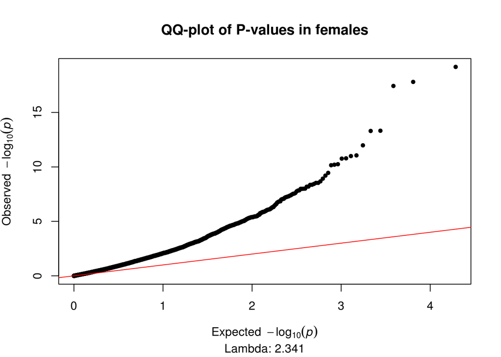

### Model 5 - 5PCs

Five PCs are regressed out, and the ANOVA for diagnosis has been run. Tables of the top 1000 DMPs for diagnosis have been produced and saved separately.

#### Top DMPs

**ANOVA:**  
53 probes pass the epigenome-wide significance threshold of 2.4x10-7 *The top 50 diagnosis associated DMPs:*

| ProbeID | Position | F | p (F) | FDR.Anova | Difference | CI lower | CI upper | pCvM | FDR | Difference | CI lower | CI upper | pCvA | FDR | Difference | CI lower | CI upper | pMvA | FDR | UCSC Gene | UCSC Gene Group | UCSC Relation to CpG Island | Gene Closest TSS | Distance Closest TSS | GREAT Annotation 1 | GREAT Annotation 2 |
| --- | --- | --- | --- | --- | --- | --- | --- | --- | --- | --- | --- | --- | --- | --- | --- | --- | --- | --- | --- | --- | --- | --- | --- | --- | --- | --- |
| cg22822140 | chr X: 153046577 | 58.689 | 4.97e-20 | 4.80e-16 | -0.009 | -0.031 | 0.014 | 0.62 | 1 | -0.093 | -0.116 | -0.071 | 4.95e-14 | 1.51e-10 | -0.085 | -0.107 | -0.062 | 5.05e-14 | 1.68e-10 | SRPK3;SRPK3;SRPK3 | 1stExon;1stExon;1stExon | Island | SRPK3 | 122 | SRPK3 (122) | (NA) |
| cg24496423 | chr X: 153046480 | 52.902 | 1.60e-18 | 7.70e-15 | 0.001 | -0.017 | 0.020 | 0.985 | 1 | -0.070 | -0.088 | -0.051 | 5.50e-14 | 1.51e-10 | -0.071 | -0.089 | -0.052 | 5.01e-14 | 1.68e-10 | SRPK3;SRPK3;SRPK3;SRPK3;SRPK3;SRPK3 | 5'UTR;1stExon;1stExon;5'UTR;5'UTR;1stExon | Island | SRPK3 | 25 | SRPK3 (25) | (NA) |
| cg12230162 | chr X: 153046482 | 51.309 | 4.26e-18 | 1.37e-14 | 0.001 | -0.023 | 0.025 | 0.994 | 1 | -0.090 | -0.114 | -0.065 | 6.25e-14 | 1.51e-10 | -0.091 | -0.115 | -0.067 | 5.23e-14 | 1.68e-10 | SRPK3;SRPK3;SRPK3;SRPK3;SRPK3;SRPK3 | 5'UTR;1stExon;1stExon;5'UTR;5'UTR;1stExon | Island | SRPK3 | 27 | SRPK3 (27) | (NA) |
| cg12468189 | chr X: 153046767 | 37.891 | 2.70e-14 | 6.51e-11 | -0.025 | -0.04 | -0.010 | 2.46e-04 | 0.015 | -0.055 | -0.069 | -0.040 | 5.91e-14 | 1.51e-10 | -0.03 | -0.044 | -0.015 | 1.07e-05 | 0.004 | SRPK3;SRPK3;SRPK3 | Body;Body;Body | Island | SRPK3 | 312 | SRPK3 (312) | (NA) |
| cg13009143 | chr X: 100548223 | 37.211 | 4.31e-14 | 8.32e-11 | -0.015 | -0.022 | -0.008 | 1.96e-06 | 4.99e-04 | 0.010 | 0.003 | 0.017 | 0.003 | 0.087 | 0.025 | 0.018 | 0.032 | 7.27e-14 | 1.75e-10 | TAF7L | TSS200 | S_Shore | TAF7L | -164 | TAF7L (-165) | (NA) |
| cg16529483 | chr X: 153046451 | 32.495 | 1.20e-12 | 1.93e-09 | -0.012 | -0.037 | 0.012 | 0.462 | 1 | -0.078 | -0.103 | -0.054 | 1.35e-11 | 2.60e-08 | -0.066 | -0.091 | -0.042 | 4.55e-09 | 4.88e-06 | SRPK3;SRPK3;SRPK3 | TSS200;TSS200;TSS200 | Island | SRPK3 | -4 | SRPK3 (-4) | (NA) |
| cg09768654 | chr X: 153046386 | 29.595 | 9.96e-12 | 1.25e-08 | 0.008 | -0.015 | 0.031 | 0.689 | 1 | -0.060 | -0.083 | -0.037 | 1.62e-08 | 1.42e-05 | -0.068 | -0.09 | -0.045 | 1.08e-10 | 1.74e-07 | SRPK3;SRPK3;SRPK3 | TSS200;TSS200;TSS200 | Island | SRPK3 | -69 | SRPK3 (-69) | (NA) |
| cg16152676 | chr X: 10126878 | 29.542 | 1.04e-11 | 1.25e-08 | 0.038 | 0.024 | 0.052 | 5.33e-09 | 7.34e-06 | -0.003 | -0.017 | 0.012 | 0.896 | 1 | -0.041 | -0.055 | -0.027 | 4.02e-10 | 5.54e-07 | CLCN4 | 5'UTR | Island | CLCN4 | 550 | CLCN4 (1894) | MID1 (724930) |
| cg19280671 | chr X: 149013642 | 28.872 | 1.70e-11 | 1.68e-08 | 0.017 | 0.011 | 0.023 | 4.60e-10 | 1.11e-06 | 0.002 | -0.004 | 0.008 | 0.809 | 1 | -0.016 | -0.022 | -0.01 | 1.11e-08 | 1.07e-05 | MAGEA8;MAGEA8;MAGEA8 | Body;Body;Body |  | MAGEA8 | 596 | MAMLD1 (-517908) | MAGEA8 (3702) |
| cg19938385 | chr X: 107020894 | 28.842 | 1.74e-11 | 1.68e-08 | -0.048 | -0.066 | -0.029 | 1.35e-08 | 1.28e-05 | -0.054 | -0.073 | -0.036 | 2.40e-10 | 3.31e-07 | -0.007 | -0.025 | 0.012 | 0.673 | 1 |  |  | S_Shore | TSC22D3 | -1692 | TSC22D3 (-1878) | (NA) |
| cg17405188 | chr X: 73164102 | 27.342 | 5.35e-11 | 4.69e-08 | 0.009 | 0.004 | 0.014 | 3.33e-04 | 0.019 | 0.017 | 0.012 | 0.023 | 1.99e-11 | 3.20e-08 | 0.008 | 0.003 | 0.013 | 0.001 | 0.11 | LOC554203 | TSS200 | Island | JPX | -56 | ZCCHC13 (-359922) | CHIC1 (381119) |
| cg24605338 | chr X: 17395856 | 27.180 | 6.04e-11 | 4.85e-08 | -0.035 | -0.046 | -0.024 | 2.22e-11 | 2.14e-07 | -0.018 | -0.029 | -0.007 | 7.02e-04 | 0.033 | 0.017 | 0.006 | 0.028 | 0.001 | 0.103 | NHS | Body | S_Shore | NHS | 2314 | SCML1 (-359735) | NHS (2314) |
| cg03360001 | chr X: 53453272 | 26.937 | 7.26e-11 | 5.39e-08 | -0.009 | -0.015 | -0.003 | 0.002 | 0.061 | 0.010 | 0.004 | 0.016 | 6.69e-04 | 0.032 | 0.018 | 0.012 | 0.024 | 2.68e-11 | 5.17e-08 | RIBC1;RIBC1 | Body;Body | S_Shelf | RIBC1 | 3434 | SMC1A (-3655) | (NA) |
| cg09661041 | chr X: 153141905 | 25.095 | 2.96e-10 | 2.04e-07 | -0.005 | -0.027 | 0.018 | 0.867 | 1 | -0.061 | -0.083 | -0.038 | 6.39e-09 | 6.85e-06 | -0.056 | -0.078 | -0.034 | 4.96e-08 | 3.42e-05 | L1CAM;L1CAM;L1CAM | TSS1500;TSS1500;TSS1500 |  | L1CAM | -506 | L1CAM (-507) | (NA) |
| cg17003204 | chr X: 102861456 | 24.865 | 3.53e-10 | 2.27e-07 | -0.036 | -0.049 | -0.024 | 3.78e-10 | 1.11e-06 | -0.011 | -0.024 | 0.001 | 0.09 | 0.585 | 0.025 | 0.013 | 0.037 | 1.33e-05 | 0.004 | TCEAL3;TCEAL3 | TSS1500;TSS1500 | N_Shore | TCEAL3 | -1377 | TCEAL3 (-1377) | (NA) |
| cg17513789 | chr X: 73073251 | 23.817 | 7.95e-10 | 4.79e-07 | -0.046 | -0.062 | -0.030 | 3.36e-10 | 1.11e-06 | -0.027 | -0.043 | -0.011 | 3.57e-04 | 0.022 | 0.019 | 0.004 | 0.035 | 0.011 | 0.346 | XIST | TSS1500 |  | XIST | -663 | ZCCHC13 (-450773) | CHIC1 (290268) |
| cg11179997 | chr X: 119125670 | 23.112 | 1.38e-09 | 7.81e-07 | 0.028 | 0.018 | 0.039 | 1.48e-08 | 1.28e-05 | 0.003 | -0.008 | 0.014 | 0.762 | 1 | -0.025 | -0.036 | -0.014 | 4.50e-07 | 2.28e-04 |  |  | Island | AK123976 | -44530 | NKAP (-47936) | RHOXF2 (86036) |
| cg21252909 | chr X: 30326328 | 22.473 | 2.27e-09 | 1.22e-06 | 0.035 | 0.013 | 0.058 | 9.74e-04 | 0.039 | -0.029 | -0.052 | -0.006 | 0.01 | 0.164 | -0.064 | -0.087 | -0.041 | 9.81e-10 | 1.18e-06 | NR0B1 | 1stExon | N_Shore | NR0B1 | 1167 | NR0B1 (1166) | (NA) |
| cg16122592 | chr X: 26210712 | 22.264 | 2.68e-09 | 1.36e-06 | -0.030 | -0.042 | -0.019 | 8.00e-09 | 9.64e-06 | -0.025 | -0.036 | -0.013 | 2.40e-06 | 5.95e-04 | 0.005 | -0.006 | 0.017 | 0.514 | 1 | MAGEB6 | 5'UTR |  | MAGEB6 | 156 | MAGEB6 (156) | (NA) |
| cg23914849 | chr X: 52950051 | 22.164 | 2.90e-09 | 1.40e-06 | 0.004 | 0.002 | 0.006 | 2.76e-04 | 0.016 | 0.006 | 0.004 | 0.008 | 1.42e-09 | 1.71e-06 | 0.003 | 3.23e-04 | 0.005 | 0.02 | 0.465 |  |  | Island | FAM156A | 13799 | FAM156B (21967) | FAM156A (74599) |
| cg21364342 | chr X: 107226611 | 22.082 | 3.10e-09 | 1.42e-06 | -0.022 | -0.031 | -0.012 | 6.39e-07 | 2.28e-04 | -0.025 | -0.034 | -0.015 | 2.36e-08 | 1.83e-05 | -0.003 | -0.012 | 0.006 | 0.734 | 1 | TEX13B | TSS1500 |  | TEX13B | -1011 | VSIG1 (-61588) | MID2 (157528) |
| cg00123001 | chr X: 13395880 | 21.825 | 3.80e-09 | 1.67e-06 | -0.019 | -0.027 | -0.011 | 1.99e-07 | 8.75e-05 | -0.020 | -0.028 | -0.012 | 8.47e-08 | 4.81e-05 | -8.44e-04 | -0.009 | 0.007 | 0.966 | 1 |  |  | N_Shore | LOC100133123 | 42521 | EGFL6 (-191813) | ATXN3L (-57363) |
| cg15907464 | chr X: 70712790 | 21.163 | 6.43e-09 | 2.62e-06 | -0.034 | -0.046 | -0.022 | 2.90e-09 | 5.60e-06 | -0.020 | -0.033 | -0.007 | 6.55e-04 | 0.032 | 0.014 | 0.002 | 0.026 | 0.022 | 0.482 | BCYRN1;INGX | Body;TSS200 | Island | INGX | -186 | OGT (-40121) | TAF1 (126677) |
| cg25549901 | chr X: 137951118 | 21.139 | 6.55e-09 | 2.62e-06 | -0.027 | -0.037 | -0.016 | 8.19e-08 | 4.39e-05 | -0.025 | -0.036 | -0.014 | 5.36e-07 | 2.03e-04 | 0.001 | -0.009 | 0.012 | 0.946 | 1 | FGF13;FGF13;FGF13;FGF13 | 5'UTR;Body;TSS1500;Body |  | FGF13 | -1401 | FGF13 (336066) | (NA) |
| cg06452970 | chr X: 13835264 | 21.093 | 6.80e-09 | 2.62e-06 | 0.047 | 0.029 | 0.065 | 1.99e-08 | 1.48e-05 | 0.010 | -0.009 | 0.028 | 0.431 | 1 | -0.037 | -0.055 | -0.019 | 7.31e-06 | 0.003 | GPM6B;GPM6B;GPM6B;GPM6B;GPM6B;GPM6B;GPM6B | 1stExon;5'UTR;5'UTR;Body;5'UTR;1stExon;1stExon |  | GPM6B | 50 | GPM6B (49) | (NA) |
| cg25896901 | chr X: 125300481 | 20.804 | 8.57e-09 | 3.08e-06 | 0.009 | -0.016 | 0.035 | 0.653 | 1 | -0.055 | -0.081 | -0.029 | 3.54e-06 | 8.13e-04 | -0.065 | -0.09 | -0.039 | 3.28e-08 | 2.51e-05 | DCAF12L2 | TSS1500 | S_Shore | DCAF12L2 | -401 | DCAF12L1 (386360) | (NA) |
| cg14917571 | chr X: 79269151 | 20.795 | 8.63e-09 | 3.08e-06 | -0.051 | -0.069 | -0.032 | 3.59e-09 | 5.78e-06 | -0.028 | -0.047 | -0.009 | 0.002 | 0.056 | 0.023 | 0.004 | 0.041 | 0.012 | 0.361 | TBX22;TBX22 | TSS1500;TSS1500 |  | TBX22 | -1103 | ITM2A (-646103) | TBX22 (-8590) |
| cg17219209 | chr X: 149009840 | 20.578 | 1.03e-08 | 3.54e-06 | 0.021 | 0.013 | 0.029 | 3.32e-08 | 2.29e-05 | 0.004 | -0.004 | 0.012 | 0.483 | 1 | -0.017 | -0.025 | -0.009 | 7.70e-06 | 0.003 | MAGEA8;MAGEA8;MAGEA8 | TSS200;TSS200;TSS200 |  | MAGEA8 | -100 | MAGEA8 (-100) | (NA) |
| cg04768884 | chr X: 19443172 | 20.438 | 1.15e-08 | 3.82e-06 | 0.008 | -0.006 | 0.022 | 0.394 | 1 | 0.036 | 0.022 | 0.050 | 2.81e-08 | 1.83e-05 | 0.028 | 0.015 | 0.042 | 8.70e-06 | 0.003 | MAP3K15 | Body |  | MAP3K15 | 35099 | PDHA1 (81162) | MAP3K15 (90206) |
| cg06068202 | chr X: 150343148 | 20.237 | 1.35e-08 | 4.21e-06 | 0.040 | 0.021 | 0.058 | 3.14e-06 | 6.45e-04 | 0.047 | 0.028 | 0.066 | 6.05e-08 | 3.65e-05 | 0.007 | -0.011 | 0.026 | 0.637 | 1 |  |  | Island | GPR50 | -1907 | GPR50 (-1907) | (NA) |
| cg09513996 | chr X: 48685182 | 20.233 | 1.35e-08 | 4.21e-06 | 0.006 | -0.007 | 0.020 | 0.521 | 1 | -0.028 | -0.042 | -0.015 | 9.15e-06 | 0.001 | -0.035 | -0.048 | -0.021 | 3.38e-08 | 2.51e-05 |  |  | Island | ERAS | -2100 | ERAS (-2100) | (NA) |
| cg07344627 | chr X: 125687011 | 19.773 | 1.96e-08 | 5.92e-06 | -0.033 | -0.057 | -0.010 | 0.003 | 0.077 | -0.063 | -0.087 | -0.039 | 8.22e-09 | 7.93e-06 | -0.03 | -0.053 | -0.006 | 0.009 | 0.317 | DCAF12L1 | TSS200 | S_Shore | DCAF12L1 | -169 | DCAF12L1 (-170) | (NA) |
| cg09953945 | chr X: 150345040 | 19.357 | 2.75e-08 | 7.92e-06 | -0.029 | -0.04 | -0.018 | 1.43e-08 | 1.28e-05 | -0.018 | -0.029 | -0.007 | 6.20e-04 | 0.031 | 0.011 | -4.83e-05 | 0.022 | 0.051 | 0.741 | GPR50 | TSS200 | N_Shore | GPR50 | -15 | GPR50 (-15) | (NA) |
| cg08630881 | chr X: 70713213 | 19.339 | 2.79e-08 | 7.92e-06 | -0.028 | -0.039 | -0.017 | 1.60e-08 | 1.28e-05 | -0.018 | -0.029 | -0.007 | 4.08e-04 | 0.023 | 0.01 | -6.74e-04 | 0.021 | 0.071 | 0.852 | BCYRN1;INGX | Body;TSS1500 | S_Shore | INGX | -609 | OGT (-39698) | TAF1 (127100) |
| cg26101161 | chr X: 122736584 | 19.255 | 2.99e-08 | 8.23e-06 | -0.020 | -0.03 | -0.011 | 4.18e-06 | 7.75e-04 | -0.024 | -0.033 | -0.014 | 1.51e-07 | 8.08e-05 | -0.003 | -0.013 | 0.006 | 0.715 | 1 | THOC2 | 3'UTR |  | THOC2 | 8230 | THOC2 (130319) | GRIA3 (418489) |
| cg11315455 | chr X: 122997585 | 18.820 | 4.26e-08 | 1.08e-05 | -0.029 | -0.041 | -0.018 | 6.04e-08 | 3.88e-05 | -0.008 | -0.020 | 0.004 | 0.269 | 0.948 | 0.022 | 0.01 | 0.033 | 7.19e-05 | 0.015 | XIAP | 5'UTR | S_Shelf | XIAP | 3569 | STAG2 (-96889) | XIAP (3569) |
| cg25177692 | chr X: 129193893 | 18.812 | 4.29e-08 | 1.08e-05 | -0.027 | -0.038 | -0.016 | 7.79e-08 | 4.39e-05 | -0.021 | -0.032 | -0.010 | 2.60e-05 | 0.003 | 0.006 | -0.005 | 0.016 | 0.453 | 1 |  |  | N_Shore | BCORL1 | 34929 | ELF4 (50794) | BCORL1 (54730) |
| cg00805156 | chr X: 3264341 | 18.808 | 4.30e-08 | 1.08e-05 | 0.036 | 0.019 | 0.052 | 2.90e-06 | 6.08e-04 | 0.040 | 0.023 | 0.056 | 3.38e-07 | 1.51e-04 | 0.004 | -0.013 | 0.02 | 0.856 | 1 | MXRA5 | 5'UTR | Island | MXRA5 | 343 | MXRA5 (342) | (NA) |
| cg07069575 | chr X: 49688313 | 18.792 | 4.36e-08 | 1.08e-05 | 0.005 | -0.006 | 0.017 | 0.523 | 1 | -0.023 | -0.035 | -0.011 | 2.17e-05 | 0.003 | -0.028 | -0.04 | -0.017 | 9.49e-08 | 5.72e-05 | CLCN5;CLCN5 | 5'UTR;5'UTR | S_Shore | CLCN5 | 1089 | CLCN5 (1089) | AKAP4 (277350) |
| cg26484667 | chr X: 2733164 | 18.719 | 4.62e-08 | 1.11e-05 | -0.029 | -0.041 | -0.017 | 8.85e-08 | 4.44e-05 | -0.007 | -0.019 | 0.005 | 0.372 | 1 | 0.022 | 0.011 | 0.034 | 4.16e-05 | 0.01 | XG;XG;XG | 3'UTR;3'UTR;3'UTR |  | GYG2 | -13698 | GYG2 (-13698) | XG (63072) |
| cg22926378 | chr X: 6144633 | 18.580 | 5.18e-08 | 1.19e-05 | 0.014 | 0.007 | 0.021 | 7.68e-06 | 0.001 | -0.002 | -0.009 | 0.005 | 0.785 | 1 | -0.016 | -0.023 | -0.009 | 3.02e-07 | 1.62e-04 | NLGN4X;NLGN4X | 5'UTR;5'UTR | Island | NLGN4X | 483 | NLGN4X (2072) | (NA) |
| cg00632130 | chr X: 47931806 | 18.576 | 5.20e-08 | 1.19e-05 | -0.011 | -0.025 | 0.002 | 0.104 | 0.608 | 0.022 | 0.009 | 0.035 | 4.25e-04 | 0.024 | 0.034 | 0.02 | 0.047 | 3.32e-08 | 2.51e-05 | ZNF630 | TSS1500 | S_Shore | ZNF630 | -781 | ZNF630 (-1299) | (NA) |
| cg04710661 | chr X: 2848381 | 18.505 | 5.51e-08 | 1.24e-05 | 0.007 | 3.61e-04 | 0.014 | 0.036 | 0.359 | 0.018 | 0.011 | 0.024 | 2.85e-08 | 1.83e-05 | 0.01 | 0.004 | 0.017 | 0.001 | 0.092 | ARSD;ARSD | TSS1500;TSS1500 | S_Shore | ARSD | -965 | ARSD (-966) | (NA) |
| cg22574818 | chr X: 55479616 | 18.371 | 6.15e-08 | 1.34e-05 | -0.033 | -0.056 | -0.010 | 0.002 | 0.073 | -0.059 | -0.083 | -0.036 | 2.76e-08 | 1.83e-05 | -0.026 | -0.049 | -0.004 | 0.019 | 0.454 | MAGEH1;MAGEH1 | 1stExon;3'UTR |  | MAGEH1 | 1079 | MAGEH1 (1079) | USP51 (36014) |
| cg26747413 | chr X: 15807140 | 18.348 | 6.26e-08 | 1.34e-05 | -0.039 | -0.056 | -0.023 | 2.70e-07 | 1.05e-04 | -0.034 | -0.051 | -0.018 | 7.97e-06 | 0.001 | 0.005 | -0.012 | 0.021 | 0.781 | 1 | INE2;ZRSR2 | TSS1500;TSS1500 | N_Shore | INE2 | -1428 | ZRSR2 (-1433) | (NA) |
| cg08464958 | chr X: 2852845 | 18.283 | 6.60e-08 | 1.38e-05 | -0.022 | -0.032 | -0.013 | 1.72e-07 | 7.89e-05 | -0.005 | -0.014 | 0.005 | 0.496 | 1 | 0.018 | 0.009 | 0.027 | 2.93e-05 | 0.008 | ARSE | 3'UTR |  | ARSD | -5429 | ARSD (-5430) | ARSE (29648) |
| cg00072799 | chr X: 78427682 | 17.814 | 9.71e-08 | 1.99e-05 | -0.007 | -0.021 | 0.007 | 0.485 | 1 | -0.033 | -0.047 | -0.019 | 2.33e-07 | 1.18e-04 | -0.027 | -0.04 | -0.013 | 2.85e-05 | 0.008 | GPR174;GPR174 | 1stExon;3'UTR |  | GPR174 | 1214 | GPR174 (1214) | ITM2A (195366) |
| cg01737010 | chr X: 101772014 | 17.760 | 1.02e-07 | 2.04e-05 | 0.007 | -0.002 | 0.017 | 0.179 | 0.79 | -0.016 | -0.026 | -0.007 | 3.03e-04 | 0.02 | -0.024 | -0.033 | -0.014 | 8.03e-08 | 5.17e-05 | TMSB15A | TSS1500 | S_Shore | TMSB15A | -315 | TMSB15A (-316) | (NA) |
| cg04817724 | chr X: 103809991 | 17.319 | 1.46e-07 | 2.88e-05 | 0.049 | 0.029 | 0.069 | 7.33e-08 | 4.39e-05 | 0.030 | 0.010 | 0.050 | 0.002 | 0.058 | -0.02 | -0.039 | 3.13e-04 | 0.055 | 0.768 | IL1RAPL2 | TSS1500 | Island | IL1RAPL2 | -1004 | IL1RAPL2 (-1004) | (NA) |
| cg24834461 | chr X: 153637645 | 17.276 | 1.51e-07 | 2.92e-05 | 0.017 | 0.01 | 0.024 | 9.20e-08 | 4.44e-05 | 0.011 | 0.004 | 0.018 | 7.57e-04 | 0.035 | -0.006 | -0.013 | 9.42e-04 | 0.106 | 1 | DNASE1L1;DNASE1L1;DNASE1L1;DNASE1L1 | TSS200;5'UTR;5'UTR;5'UTR | N_Shelf | DNASE1L1 | -70 | TAZ (-2231) | (NA) |

**CTL vs MCI:**  
22 probes pass the epigenome-wide significance threshold of 2.4x10-7

*The top 50 CTL vs MCI associated DMPs:*

| ProbeID | Position | F | p (F) | FDR.Anova | Difference | CI lower | CI upper | pCvM | FDR | Difference | CI lower | CI upper | pCvA | FDR | Difference | CI lower | CI upper | pMvA | FDR | UCSC Gene | UCSC Gene Group | UCSC Relation to CpG Island | Gene Closest TSS | Distance Closest TSS | GREAT Annotation 1 | GREAT Annotation 2 |
| --- | --- | --- | --- | --- | --- | --- | --- | --- | --- | --- | --- | --- | --- | --- | --- | --- | --- | --- | --- | --- | --- | --- | --- | --- | --- | --- |
| cg24605338 | chr X: 17395856 | 27.180 | 6.04e-11 | 4.85e-08 | -0.035 | -0.046 | -0.024 | 2.22e-11 | 2.14e-07 | -0.018 | -0.029 | -0.007 | 7.02e-04 | 0.033 | 0.017 | 0.006 | 0.028 | 0.001 | 0.103 | NHS | Body | S_Shore | NHS | 2314 | SCML1 (-359735) | NHS (2314) |
| cg17513789 | chr X: 73073251 | 23.817 | 7.95e-10 | 4.79e-07 | -0.046 | -0.062 | -0.030 | 3.36e-10 | 1.11e-06 | -0.027 | -0.043 | -0.011 | 3.57e-04 | 0.022 | 0.019 | 0.004 | 0.035 | 0.011 | 0.346 | XIST | TSS1500 |  | XIST | -663 | ZCCHC13 (-450773) | CHIC1 (290268) |
| cg17003204 | chr X: 102861456 | 24.865 | 3.53e-10 | 2.27e-07 | -0.036 | -0.049 | -0.024 | 3.78e-10 | 1.11e-06 | -0.011 | -0.024 | 0.001 | 0.09 | 0.585 | 0.025 | 0.013 | 0.037 | 1.33e-05 | 0.004 | TCEAL3;TCEAL3 | TSS1500;TSS1500 | N_Shore | TCEAL3 | -1377 | TCEAL3 (-1377) | (NA) |
| cg19280671 | chr X: 149013642 | 28.872 | 1.70e-11 | 1.68e-08 | 0.017 | 0.011 | 0.023 | 4.60e-10 | 1.11e-06 | 0.002 | -0.004 | 0.008 | 0.809 | 1 | -0.016 | -0.022 | -0.01 | 1.11e-08 | 1.07e-05 | MAGEA8;MAGEA8;MAGEA8 | Body;Body;Body |  | MAGEA8 | 596 | MAMLD1 (-517908) | MAGEA8 (3702) |
| cg15907464 | chr X: 70712790 | 21.163 | 6.43e-09 | 2.62e-06 | -0.034 | -0.046 | -0.022 | 2.90e-09 | 5.60e-06 | -0.020 | -0.033 | -0.007 | 6.55e-04 | 0.032 | 0.014 | 0.002 | 0.026 | 0.022 | 0.482 | BCYRN1;INGX | Body;TSS200 | Island | INGX | -186 | OGT (-40121) | TAF1 (126677) |
| cg14917571 | chr X: 79269151 | 20.795 | 8.63e-09 | 3.08e-06 | -0.051 | -0.069 | -0.032 | 3.59e-09 | 5.78e-06 | -0.028 | -0.047 | -0.009 | 0.002 | 0.056 | 0.023 | 0.004 | 0.041 | 0.012 | 0.361 | TBX22;TBX22 | TSS1500;TSS1500 |  | TBX22 | -1103 | ITM2A (-646103) | TBX22 (-8590) |
| cg16152676 | chr X: 10126878 | 29.542 | 1.04e-11 | 1.25e-08 | 0.038 | 0.024 | 0.052 | 5.33e-09 | 7.34e-06 | -0.003 | -0.017 | 0.012 | 0.896 | 1 | -0.041 | -0.055 | -0.027 | 4.02e-10 | 5.54e-07 | CLCN4 | 5'UTR | Island | CLCN4 | 550 | CLCN4 (1894) | MID1 (724930) |
| cg16122592 | chr X: 26210712 | 22.264 | 2.68e-09 | 1.36e-06 | -0.030 | -0.042 | -0.019 | 8.00e-09 | 9.64e-06 | -0.025 | -0.036 | -0.013 | 2.40e-06 | 5.95e-04 | 0.005 | -0.006 | 0.017 | 0.514 | 1 | MAGEB6 | 5'UTR |  | MAGEB6 | 156 | MAGEB6 (156) | (NA) |
| cg19938385 | chr X: 107020894 | 28.842 | 1.74e-11 | 1.68e-08 | -0.048 | -0.066 | -0.029 | 1.35e-08 | 1.28e-05 | -0.054 | -0.073 | -0.036 | 2.40e-10 | 3.31e-07 | -0.007 | -0.025 | 0.012 | 0.673 | 1 |  |  | S_Shore | TSC22D3 | -1692 | TSC22D3 (-1878) | (NA) |
| cg09953945 | chr X: 150345040 | 19.357 | 2.75e-08 | 7.92e-06 | -0.029 | -0.040 | -0.018 | 1.43e-08 | 1.28e-05 | -0.018 | -0.029 | -0.007 | 6.20e-04 | 0.031 | 0.011 | -4.83e-05 | 0.022 | 0.051 | 0.741 | GPR50 | TSS200 | N_Shore | GPR50 | -15 | GPR50 (-15) | (NA) |
| cg11179997 | chr X: 119125670 | 23.112 | 1.38e-09 | 7.81e-07 | 0.028 | 0.018 | 0.039 | 1.48e-08 | 1.28e-05 | 0.003 | -0.008 | 0.014 | 0.762 | 1 | -0.025 | -0.036 | -0.014 | 4.50e-07 | 2.28e-04 |  |  | Island | AK123976 | -44530 | NKAP (-47936) | RHOXF2 (86036) |
| cg08630881 | chr X: 70713213 | 19.339 | 2.79e-08 | 7.92e-06 | -0.028 | -0.039 | -0.017 | 1.60e-08 | 1.28e-05 | -0.018 | -0.029 | -0.007 | 4.08e-04 | 0.023 | 0.01 | -6.74e-04 | 0.021 | 0.071 | 0.852 | BCYRN1;INGX | Body;TSS1500 | S_Shore | INGX | -609 | OGT (-39698) | TAF1 (127100) |
| cg06452970 | chr X: 13835264 | 21.093 | 6.80e-09 | 2.62e-06 | 0.047 | 0.029 | 0.065 | 1.99e-08 | 1.48e-05 | 0.010 | -0.009 | 0.028 | 0.431 | 1 | -0.037 | -0.055 | -0.019 | 7.31e-06 | 0.003 | GPM6B;GPM6B;GPM6B;GPM6B;GPM6B;GPM6B;GPM6B | 1stExon;5'UTR;5'UTR;Body;5'UTR;1stExon;1stExon |  | GPM6B | 50 | GPM6B (49) | (NA) |
| cg17219209 | chr X: 149009840 | 20.578 | 1.03e-08 | 3.54e-06 | 0.021 | 0.013 | 0.029 | 3.32e-08 | 2.29e-05 | 0.004 | -0.004 | 0.012 | 0.483 | 1 | -0.017 | -0.025 | -0.009 | 7.70e-06 | 0.003 | MAGEA8;MAGEA8;MAGEA8 | TSS200;TSS200;TSS200 |  | MAGEA8 | -100 | MAGEA8 (-100) | (NA) |
| cg11315455 | chr X: 122997585 | 18.820 | 4.26e-08 | 1.08e-05 | -0.029 | -0.041 | -0.018 | 6.04e-08 | 3.88e-05 | -0.008 | -0.020 | 0.004 | 0.269 | 0.948 | 0.022 | 0.01 | 0.033 | 7.19e-05 | 0.015 | XIAP | 5'UTR | S_Shelf | XIAP | 3569 | STAG2 (-96889) | XIAP (3569) |
| cg04817724 | chr X: 103809991 | 17.319 | 1.46e-07 | 2.88e-05 | 0.049 | 0.029 | 0.069 | 7.33e-08 | 4.39e-05 | 0.030 | 0.010 | 0.05 | 0.002 | 0.058 | -0.02 | -0.039 | 3.13e-04 | 0.055 | 0.768 | IL1RAPL2 | TSS1500 | Island | IL1RAPL2 | -1004 | IL1RAPL2 (-1004) | (NA) |
| cg25177692 | chr X: 129193893 | 18.812 | 4.29e-08 | 1.08e-05 | -0.027 | -0.038 | -0.016 | 7.79e-08 | 4.39e-05 | -0.021 | -0.032 | -0.01 | 2.60e-05 | 0.003 | 0.006 | -0.005 | 0.016 | 0.453 | 1 |  |  | N_Shore | BCORL1 | 34929 | ELF4 (50794) | BCORL1 (54730) |
| cg25549901 | chr X: 137951118 | 21.139 | 6.55e-09 | 2.62e-06 | -0.027 | -0.037 | -0.016 | 8.19e-08 | 4.39e-05 | -0.025 | -0.036 | -0.014 | 5.36e-07 | 2.03e-04 | 0.001 | -0.009 | 0.012 | 0.946 | 1 | FGF13;FGF13;FGF13;FGF13 | 5'UTR;Body;TSS1500;Body |  | FGF13 | -1401 | FGF13 (336066) | (NA) |
| cg26484667 | chr X: 2733164 | 18.719 | 4.62e-08 | 1.11e-05 | -0.029 | -0.041 | -0.017 | 8.85e-08 | 4.44e-05 | -0.007 | -0.019 | 0.005 | 0.372 | 1 | 0.022 | 0.011 | 0.034 | 4.16e-05 | 0.01 | XG;XG;XG | 3'UTR;3'UTR;3'UTR |  | GYG2 | -13698 | GYG2 (-13698) | XG (63072) |
| cg24834461 | chr X: 153637645 | 17.276 | 1.51e-07 | 2.92e-05 | 0.017 | 0.010 | 0.024 | 9.20e-08 | 4.44e-05 | 0.011 | 0.004 | 0.018 | 7.57e-04 | 0.035 | -0.006 | -0.013 | 9.42e-04 | 0.106 | 1 | DNASE1L1;DNASE1L1;DNASE1L1;DNASE1L1 | TSS200;5'UTR;5'UTR;5'UTR | N_Shelf | DNASE1L1 | -70 | TAZ (-2231) | (NA) |
| cg08464958 | chr X: 2852845 | 18.283 | 6.60e-08 | 1.38e-05 | -0.022 | -0.032 | -0.013 | 1.72e-07 | 7.89e-05 | -0.005 | -0.014 | 0.005 | 0.496 | 1 | 0.018 | 0.009 | 0.027 | 2.93e-05 | 0.008 | ARSE | 3'UTR |  | ARSD | -5429 | ARSD (-5430) | ARSE (29648) |
| cg00123001 | chr X: 13395880 | 21.825 | 3.80e-09 | 1.67e-06 | -0.019 | -0.027 | -0.011 | 1.99e-07 | 8.75e-05 | -0.020 | -0.028 | -0.012 | 8.47e-08 | 4.81e-05 | -8.44e-04 | -0.009 | 0.007 | 0.966 | 1 |  |  | N_Shore | LOC100133123 | 42521 | EGFL6 (-191813) | ATXN3L (-57363) |
| cg08867267 | chr X: 130033963 | 16.021 | 4.31e-07 | 7.17e-05 | -0.024 | -0.034 | -0.014 | 2.58e-07 | 1.05e-04 | -0.015 | -0.025 | -0.005 | 0.001 | 0.05 | 0.008 | -0.002 | 0.018 | 0.116 | 1 | ENOX2;ENOX2 | 5'UTR;5'UTR | N_Shelf | ENOX2 | 3245 | ENOX2 (3244) | RBMX2 (498021) |
| cg26747413 | chr X: 15807140 | 18.348 | 6.26e-08 | 1.34e-05 | -0.039 | -0.056 | -0.023 | 2.70e-07 | 1.05e-04 | -0.034 | -0.051 | -0.018 | 7.97e-06 | 0.001 | 0.005 | -0.012 | 0.021 | 0.781 | 1 | INE2;ZRSR2 | TSS1500;TSS1500 | N_Shore | INE2 | -1428 | ZRSR2 (-1433) | (NA) |
| cg12461113 | chr X: 13587550 | 15.627 | 6.01e-07 | 9.35e-05 | -0.079 | -0.112 | -0.046 | 2.72e-07 | 1.05e-04 | -0.042 | -0.076 | -0.008 | 0.01 | 0.168 | 0.037 | 0.004 | 0.07 | 0.026 | 0.521 | EGFL6;EGFL6 | TSS200;TSS200 | N_Shore | EGFL6 | -143 | EGFL6 (-143) | (NA) |
| cg05860920 | chr X: 11679501 | 15.936 | 4.63e-07 | 7.58e-05 | 0.059 | 0.033 | 0.085 | 5.76e-07 | 2.14e-04 | 0.045 | 0.019 | 0.071 | 1.94e-04 | 0.014 | -0.014 | -0.039 | 0.012 | 0.401 | 1 | ARHGAP6;ARHGAP6 | Body;Body | N_Shelf | ARHGAP6 | 4320 | ARHGAP6 (4319) | AMELX (367969) |
| cg21364342 | chr X: 107226611 | 22.082 | 3.10e-09 | 1.42e-06 | -0.022 | -0.031 | -0.012 | 6.39e-07 | 2.28e-04 | -0.025 | -0.034 | -0.015 | 2.36e-08 | 1.83e-05 | -0.003 | -0.012 | 0.006 | 0.734 | 1 | TEX13B | TSS1500 |  | TEX13B | -1011 | VSIG1 (-61588) | MID2 (157528) |
| cg25396787 | chr X: 3733991 | 14.673 | 1.35e-06 | 1.76e-04 | 0.028 | 0.016 | 0.041 | 7.34e-07 | 2.50e-04 | 0.018 | 0.005 | 0.03 | 0.004 | 0.091 | -0.011 | -0.023 | 0.002 | 0.098 | 0.976 |  |  | Island | TRNA_Ile | 22500 | PRKX (-102317) | (NA) |
| cg25958561 | chr X: 110187179 | 15.826 | 5.08e-07 | 8.04e-05 | 0.032 | 0.018 | 0.046 | 7.52e-07 | 2.50e-04 | 0.025 | 0.011 | 0.039 | 1.44e-04 | 0.011 | -0.007 | -0.021 | 0.007 | 0.479 | 1 | PAK3;PAK3 | TSS1500;TSS1500 |  | PAK3 | -333 | PAK3 (-179125) | CHRDL1 (-148104) |
| cg09979033 | chr X: 16726904 | 15.838 | 5.03e-07 | 8.04e-05 | -0.018 | -0.026 | -0.010 | 8.47e-07 | 2.72e-04 | -0.014 | -0.022 | -0.006 | 1.13e-04 | 0.01 | 0.004 | -0.004 | 0.011 | 0.533 | 1 | CTPS2;CTPS2;CTPS2 | 5'UTR;5'UTR;5'UTR | N_Shelf | CTPS2 | 3436 | CTPS2 (4154) | S100G (58624) |
| cg14306994 | chr X: 49019804 | 14.260 | 1.92e-06 | 2.28e-04 | 0.030 | 0.017 | 0.043 | 9.07e-07 | 2.82e-04 | 0.015 | 0.001 | 0.028 | 0.029 | 0.318 | -0.015 | -0.029 | -0.002 | 0.019 | 0.452 | MAGIX;MAGIX;MAGIX;MAGIX | Body;Body;Body;TSS1500 | Island | MAGIX | -316 | GPKOW (-39726) | PLP2 (-8379) |
| cg25433595 | chr X: 100183764 | 15.506 | 6.65e-07 | 1.00e-04 | 0.042 | 0.023 | 0.060 | 1.14e-06 | 3.43e-04 | 0.033 | 0.015 | 0.052 | 1.27e-04 | 0.011 | -0.008 | -0.027 | 0.01 | 0.553 | 1 | XKRX;XKRX | 5'UTR;1stExon | N_Shore | XKRX | 134 | XKRX (133) | (NA) |
| cg27558057 | chr X: 70712724 | 13.944 | 2.51e-06 | 2.75e-04 | -0.029 | -0.042 | -0.016 | 1.30e-06 | 3.74e-04 | -0.013 | -0.026 | 4.35e-04 | 0.06 | 0.479 | 0.016 | 0.003 | 0.029 | 0.01 | 0.327 | BCYRN1;INGX | Body;TSS200 | Island | INGX | -120 | OGT (-40187) | TAF1 (126611) |
| cg09641151 | chr X: 153693918 | 14.151 | 2.10e-06 | 2.46e-04 | 0.028 | 0.015 | 0.041 | 1.34e-06 | 3.74e-04 | 0.018 | 0.006 | 0.031 | 0.002 | 0.07 | -0.01 | -0.022 | 0.003 | 0.168 | 1 | PLXNA3 | Body | N_Shore | PLXNA3 | 7296 | PLXNA3 (7296) | LAGE3 (13677) |
| cg07892139 | chr X: 84192519 | 17.006 | 1.90e-07 | 3.48e-05 | -0.045 | -0.066 | -0.025 | 1.36e-06 | 3.74e-04 | -0.042 | -0.063 | -0.022 | 7.87e-06 | 0.001 | 0.003 | -0.017 | 0.023 | 0.943 | 1 |  |  | S_Shelf | UBE2DNL | 3363 | APOOL (-66378) | UBE2DNL (3363) |
| cg25831435 | chr X: 137714452 | 14.576 | 1.46e-06 | 1.84e-04 | -0.030 | -0.044 | -0.016 | 1.48e-06 | 3.96e-04 | -0.022 | -0.036 | -0.008 | 5.56e-04 | 0.029 | 0.008 | -0.006 | 0.021 | 0.357 | 1 | FGF13;FGF13;FGF13;FGF13;FGF13;FGF13 | 3'UTR;3'UTR;3'UTR;3'UTR;3'UTR;3'UTR |  | LOC158696 | -14653 | FGF13 (572732) | (NA) |
| ch.X.112118442F | chr X: 112231786 | 13.542 | 3.54e-06 | 3.64e-04 | 0.013 | 0.007 | 0.019 | 1.72e-06 | 4.47e-04 | 0.007 | 0.001 | 0.013 | 0.015 | 0.212 | -0.006 | -0.012 | 1.24e-05 | 0.051 | 0.738 |  |  |  | U6 | 69427 | AMOT (-165415) | (NA) |
| cg13009143 | chr X: 100548223 | 37.211 | 4.31e-14 | 8.32e-11 | -0.015 | -0.022 | -0.008 | 1.96e-06 | 4.99e-04 | 0.010 | 0.003 | 0.017 | 0.003 | 0.087 | 0.025 | 0.018 | 0.032 | 7.27e-14 | 1.75e-10 | TAF7L | TSS200 | S_Shore | TAF7L | -164 | TAF7L (-165) | (NA) |
| cg05889382 | chr X: 70887722 | 16.700 | 2.44e-07 | 4.37e-05 | -0.020 | -0.029 | -0.011 | 2.04e-06 | 5.06e-04 | -0.019 | -0.028 | -0.01 | 7.65e-06 | 0.001 | 8.85e-04 | -0.008 | 0.01 | 0.971 | 1 | BCYRN1 | Body | Island | LOC100132741 | -29323 | PIN4 (-513803) | CXCR3 (-49356) |
| cg06068891 | chr X: 135228207 | 14.602 | 1.43e-06 | 1.84e-04 | -0.047 | -0.068 | -0.025 | 2.12e-06 | 5.11e-04 | -0.037 | -0.058 | -0.015 | 2.51e-04 | 0.017 | 0.01 | -0.012 | 0.031 | 0.527 | 1 | FHL1;FHL1;FHL1;FHL1 | TSS1500;TSS1500;TSS1500;TSS1500 | N_Shore | FHL1 | -653 | FHL1 (-1351) | (NA) |
| cg06138173 | chr X: 16668923 | 13.258 | 4.53e-06 | 4.14e-04 | -0.030 | -0.044 | -0.016 | 2.27e-06 | 5.20e-04 | -0.017 | -0.032 | -0.003 | 0.012 | 0.185 | 0.013 | -8.48e-04 | 0.027 | 0.071 | 0.852 | CTPS2;S100G;CTPS2;CTPS2 | Body;5'UTR;Body;Body |  | S100G | 643 | S100G (643) | (NA) |
| cg26468081 | chr X: 69501565 | 13.623 | 3.31e-06 | 3.50e-04 | -0.014 | -0.021 | -0.008 | 2.28e-06 | 5.20e-04 | -0.005 | -0.012 | 0.001 | 0.16 | 0.763 | 0.009 | 0.003 | 0.015 | 0.003 | 0.194 | ARR3;RAB41 | Body;TSS1500 |  | RAB41 | -456 | RAB41 (-456) | (NA) |
| cg07089438 | chr X: 133988190 | 13.434 | 3.89e-06 | 3.87e-04 | -0.025 | -0.036 | -0.013 | 2.32e-06 | 5.20e-04 | -0.016 | -0.027 | -0.004 | 0.004 | 0.099 | 0.009 | -0.002 | 0.02 | 0.149 | 1 | FAM122C;FAM122C | 3'UTR;Body |  | MOSPD1 | 45374 | PLAC1 (-195678) | MOSPD1 (61106) |
| cg18497064 | chr X: 134715899 | 13.578 | 3.44e-06 | 3.57e-04 | -0.039 | -0.057 | -0.021 | 2.47e-06 | 5.41e-04 | -0.014 | -0.032 | 0.004 | 0.175 | 0.796 | 0.025 | 0.007 | 0.043 | 0.003 | 0.182 | DDX26B | 3'UTR |  | DDX26B | 12638 | ZNF449 (237204) | MMGT1 (340234) |
| cg22268449 | chr X: 47053156 | 15.488 | 6.76e-07 | 1.00e-04 | 0.015 | 0.008 | 0.022 | 2.70e-06 | 5.79e-04 | 0.014 | 0.007 | 0.021 | 3.49e-05 | 0.004 | -0.002 | -0.009 | 0.005 | 0.858 | 1 | UBA1;UBA1 | TSS200;5'UTR | Island | UBA1 | -44 | CDK16 (-29260) | UBA1 (2958) |
| cg00805156 | chr X: 3264341 | 18.808 | 4.30e-08 | 1.08e-05 | 0.036 | 0.019 | 0.052 | 2.90e-06 | 6.08e-04 | 0.040 | 0.023 | 0.056 | 3.38e-07 | 1.51e-04 | 0.004 | -0.013 | 0.02 | 0.856 | 1 | MXRA5 | 5'UTR | Island | MXRA5 | 343 | MXRA5 (342) | (NA) |
| cg06068202 | chr X: 150343148 | 20.237 | 1.35e-08 | 4.21e-06 | 0.040 | 0.021 | 0.058 | 3.14e-06 | 6.45e-04 | 0.047 | 0.028 | 0.066 | 6.05e-08 | 3.65e-05 | 0.007 | -0.011 | 0.026 | 0.637 | 1 |  |  | Island | GPR50 | -1907 | GPR50 (-1907) | (NA) |
| cg11837390 | chr X: 106957165 | 13.489 | 3.71e-06 | 3.73e-04 | -0.021 | -0.031 | -0.011 | 3.48e-06 | 7.00e-04 | -0.015 | -0.025 | -0.005 | 0.001 | 0.045 | 0.006 | -0.004 | 0.015 | 0.359 | 1 | TSC22D3;TSC22D3;TSC22D3 | 3'UTR;3'UTR;3'UTR | N_Shelf | TSC22D3 | 2546 | TSC22D3 (61851) | PRPS1 (85512) |
| cg00938039 | chr X: 5808230 | 13.407 | 3.98e-06 | 3.92e-04 | -0.031 | -0.046 | -0.016 | 3.69e-06 | 7.26e-04 | -0.023 | -0.037 | -0.008 | 0.001 | 0.046 | 0.008 | -0.006 | 0.023 | 0.355 | 1 | NLGN4X;NLGN4X | 3'UTR;3'UTR | N_Shelf | NLGN4Y | 261582 | NLGN4X (338475) | (NA) |
| cg20881335 | chr X: 14547172 | 12.787 | 6.81e-06 | 5.61e-04 | 0.064 | 0.034 | 0.094 | 3.77e-06 | 7.27e-04 | 0.027 | -0.003 | 0.057 | 0.09 | 0.587 | -0.037 | -0.066 | -0.007 | 0.012 | 0.35 | GLRA2;GLRA2;GLRA2 | TSS1500;TSS1500;TSS1500 |  | GLRA2 | -247 | GLRA2 (-247) | (NA) |